# Portafolio del Curso de Métodos Numéricos

##### 4. Iteración 2

```r
x_old <- x
cat("\nIteración 2\n")
```

```
##
## Iteración 2
```

```r
# x1^(2) = (b[1] - A[1,2]*x_old[2] - A[1,3]*x_old[3]) / A[1,1]
x[1] <- (b[1] - A[1,2] * x_old[2] - A[1,3] * x_old[3]) / A[1,1]
cat(sprintf("x1^(2) = (%.8f - %.2f*%.8f - %.2f*%.8f)/%.2f = %.8f\n",
            b[1], A[1,2], x_old[2], A[1,3], x_old[3], A[1,1], x[1]))
```

```
## x1^(2) = (5.24000000 - -0.50*0.22775000 - 0.60*2.22430952)/3.00 = 1.33976310
```

```r
# x2^(2) = (b[2] - A[2,1]*x[1] - A[2,3]*x_old[3]) / A[2,2]
x[2] <- (b[2] - A[2,1] * x[1] - A[2,3] * x_old[3]) / A[2,2]
cat(sprintf("x2^(2) = (%.8f - %.2f*%.8f - %.2f*%.8f)/%.2f = %.8f\n",
            b[2], A[2,1], x[1], A[2,3], x_old[3], A[2,2], x[2]))
```

```
## x2^(2) = (-0.38700000 - 0.30*1.33976310 - -1.00*2.22430952)/-4.00 = -0.35884515
```

```r
# x3^(2) = (b[3] - A[3,1]*x[1] - A[3,2]*x[2]) / A[3,3]
x[3] <- (b[3] - A[3,1] * x[1] - A[3,2] * x[2]) / A[3,3]
cat(sprintf("x3^(2) = (%.8f - %.2f*%.8f - %.2f*%.8f)/%.2f = %.8f\n",
            b[3], A[3,1], x[1], A[3,2], x[2], A[3,3], x[3]))
```

```
## x3^(2) = (14.80300000 - -0.70*1.33976310 - 2.00*-0.35884515)/7.00 = 2.35121778
```

```r
r <- b - A %*% x
dx_inf <- max(abs(x - x_old))
(dx_inf)
```

```
## [1] 0.5865951
```

```r
cat(sprintf("x^(2) = %s\n", paste(sprintf("%.8f", x), collapse=", ")))
```

```
## x^(2) = 1.33976310, -0.35884515, 2.35121778
```

```r
cat(sprintf("||dx||_inf = %.8e | ||r||_inf = %.8e\n", dx_inf, max(abs(r))))
```

```
## ||dx||_inf = 5.86595149e-01 | ||r||_inf = 3.69442528e-01
```

##### 5. Iteración 3

```r
x_old <- x
cat("\nIteración 3\n")
```

```
##
## Iteración 3
```

```r
# x1^(2) = (b[1] - A[1,2]*x_old[2] - A[1,3]*x_old[3]) / A[1,1]
x[1] <- (b[1] - A[1,2] * x_old[2] - A[1,3] * x_old[3]) / A[1,1]
cat(sprintf("x1^(3) = (%.8f - %.2f*%.8f - %.2f*%.8f)/%.2f = %.8f\n",
            b[1], A[1,2], x_old[2], A[1,3], x_old[3], A[1,1], x[1]))
```

```
## x1^(3) = (5.24000000 - -0.50*-0.35884515 - 0.60*2.35121778)/3.00 = 1.21661559
```

```r
# x2^(2) = (b[2] - A[2,1]*x[1] - A[2,3]*x_old[3]) / A[2,2]
x[2] <- (b[2] - A[2,1] * x[1] - A[2,3] * x_old[3]) / A[2,2]
cat(sprintf("x2^(3) = (%.8f - %.2f*%.8f - %.2f*%.8f)/%.2f = %.8f\n",
            b[2], A[2,1], x[1], A[2,3], x_old[3], A[2,2], x[2]))
```

```
## x2^(3) = (-0.38700000 - 0.30*1.21661559 - -1.00*2.35121778)/-4.00 = -0.39980828
```

```r
# x3^(2) = (b[3] - A[3,1]*x[1] - A[3,2]*x[2]) / A[3,3]
x[3] <- (b[3] - A[3,1] * x[1] - A[3,2] * x[2]) / A[3,3]
cat(sprintf("x3^(3) = (%.8f - %.2f*%.8f - %.2f*%.8f)/%.2f = %.8f\n",
            b[3], A[3,1], x[1], A[3,2], x[2], A[3,3], x[3]))
```

```
## x3^(3) = (14.80300000 - -0.70*1.21661559 - 2.00*-0.39980828)/7.00 = 2.35060678
```

```r
r <- b - A %*% x
dx_inf <- max(abs(x - x_old))
(dx_inf)
```

```
## [1] 0.1231475
```

```r
cat(sprintf("x^(3) = %s\n", paste(sprintf("%.8f", x), collapse=", ")))
```

```
## x^(3) = 1.21661559, -0.39980828, 2.35060678
```

```r
cat(sprintf("||dx||_inf = %.8e | ||r||_inf = %.8e\n", dx_inf, max(abs(r))))
```

```
## ||dx||_inf = 1.23147509e-01 | ||r||_inf = 2.01149636e-02
```

##### 6. Iteración 4

```r
x_old <- x
cat("\nIteración 4\n")
```

```
##
## Iteración 4
```

```r
# x1^(2) = (b[1] - A[1,2]*x_old[2] - A[1,3]*x_old[3]) / A[1,1]
x[1] <- (b[1] - A[1,2] * x_old[2] - A[1,3] * x_old[3]) / A[1,1]
cat(sprintf("x1^(4) = (%.8f - %.2f*%.8f - %.2f*%.8f)/%.2f = %.8f\n",
            b[1], A[1,2], x_old[2], A[1,3], x_old[3], A[1,1], x[1]))
```

```
## x1^(4) = (5.24000000 - -0.50*-0.39980828 - 0.60*2.35060678)/3.00 = 1.20991060
```

```r
# x2^(2) = (b[2] - A[2,1]*x[1] - A[2,3]*x_old[3]) / A[2,2]
x[2] <- (b[2] - A[2,1] * x[1] - A[2,3] * x_old[3]) / A[2,2]
cat(sprintf("x2^(4) = (%.8f - %.2f*%.8f - %.2f*%.8f)/%.2f = %.8f\n",
            b[2], A[2,1], x[1], A[2,3], x_old[3], A[2,2], x[2]))
```

```
## x2^(4) = (-0.38700000 - 0.30*1.20991060 - -1.00*2.35060678)/-4.00 = -0.40015840
```

```r
# x3^(2) = (b[3] - A[3,1]*x[1] - A[3,2]*x[2]) / A[3,3]
x[3] <- (b[3] - A[3,1] * x[1] - A[3,2] * x[2]) / A[3,3]
cat(sprintf("x3^(4) = (%.8f - %.2f*%.8f - %.2f*%.8f)/%.2f = %.8f\n",
            b[3], A[3,1], x[1], A[3,2], x[2], A[3,3], x[3]))
```

```
## x3^(4) = (14.80300000 - -0.70*1.20991060 - 2.00*-0.40015840)/7.00 = 2.35003632
```

```r
r <- b - A %*% x
dx_inf <- max(abs(x - x_old))
(dx_inf)
```

```
## [1] 0.006704988
```

```r
cat(sprintf("x^(4) = %s\n", paste(sprintf("%.8f", x), collapse=", ")))
```

```
## x^(4) = 1.20991060, -0.40015840, 2.35003632
```

```r
cat(sprintf("||dx||_inf = %.8e | ||r||_inf = %.8e\n", dx_inf, max(abs(r))))
```

```
## ||dx||_inf = 6.70498785e-03 | ||r||_inf = 5.70463350e-04
```

##### 7. Iteración 5

```r
x_old <- x
cat("\nIteración 5\n")
```

```
##
## Iteración 5
```

```r
# x1^(2) = (b[1] - A[1,2]*x_old[2] - A[1,3]*x_old[3]) / A[1,1]
x[1] <- (b[1] - A[1,2] * x_old[2] - A[1,3] * x_old[3]) / A[1,1]
cat(sprintf("x1^(5) = (%.8f - %.2f*%.8f - %.2f*%.8f)/%.2f = %.8f\n",
            b[1], A[1,2], x_old[2], A[1,3], x_old[3], A[1,1], x[1]))
```

```
## x1^(5) = (5.24000000 - -0.50*-0.40015840 - 0.60*2.35003632)/3.00 = 1.20996634
```

```r
# x2^(2) = (b[2] - A[2,1]*x[1] - A[2,3]*x_old[3]) / A[2,2]
x[2] <- (b[2] - A[2,1] * x[1] - A[2,3] * x_old[3]) / A[2,2]
cat(sprintf("x2^(5) = (%.8f - %.2f*%.8f - %.2f*%.8f)/%.2f = %.8f\n",
            b[2], A[2,1], x[1], A[2,3], x_old[3], A[2,2], x[2]))
```

```
## x2^(5) = (-0.38700000 - 0.30*1.20996634 - -1.00*2.35003632)/-4.00 = -0.40001160
```

```r
# x3^(2) = (b[3] - A[3,1]*x[1] - A[3,2]*x[2]) / A[3,3]
x[3] <- (b[3] - A[3,1] * x[1] - A[3,2] * x[2]) / A[3,3]
cat(sprintf("x3^(5) = (%.8f - %.2f*%.8f - %.2f*%.8f)/%.2f = %.8f\n",
            b[3], A[3,1], x[1], A[3,2], x[2], A[3,3], x[3]))
```

```
## x3^(5) = (14.80300000 - -0.70*1.20996634 - 2.00*-0.40001160)/7.00 = 2.34999995
```

```r
r <- b - A %*% x
dx_inf <- max(abs(x - x_old))
(dx_inf)
```

```
## [1] 0.0001467962
```

```r
cat(sprintf("x^(2) = %s\n", paste(sprintf("%.8f", x), collapse=", ")))
```

```
## x^(2) = 1.20996634, -0.40001160, 2.34999995
```

```r
cat(sprintf("||dx||_inf = %.8e | ||r||_inf = %.8e\n", dx_inf, max(abs(r))))
```

```
## ||dx||_inf = 1.46796237e-04 | ||r||_inf = 9.52188680e-05
```

##### 8. Iteración 6

```r
x_old <- x
cat("\nIteración 6\n")
```

```
##
## Iteración 6
```

```r
# x1^(2) = (b[1] - A[1,2]*x_old[2] - A[1,3]*x_old[3]) / A[1,1]
x[1] <- (b[1] - A[1,2] * x_old[2] - A[1,3] * x_old[3]) / A[1,1]
cat(sprintf("x1^(6) = (%.8f - %.2f*%.8f - %.2f*%.8f)/%.2f = %.8f\n",
            b[1], A[1,2], x_old[2], A[1,3], x_old[3], A[1,1], x[1]))
```

```
## x1^(6) = (5.24000000 - -0.50*-0.40001160 - 0.60*2.34999995)/3.00 = 1.20999808
```

```r
# x2^(2) = (b[2] - A[2,1]*x[1] - A[2,3]*x_old[3]) / A[2,2]
x[2] <- (b[2] - A[2,1] * x[1] - A[2,3] * x_old[3]) / A[2,2]
cat(sprintf("x2^(6) = (%.8f - %.2f*%.8f - %.2f*%.8f)/%.2f = %.8f\n",
            b[2], A[2,1], x[1], A[2,3], x_old[3], A[2,2], x[2]))
```

```
## x2^(6) = (-0.38700000 - 0.30*1.20999808 - -1.00*2.34999995)/-4.00 = -0.40000013
```

```r
# x3^(2) = (b[3] - A[3,1]*x[1] - A[3,2]*x[2]) / A[3,3]
x[3] <- (b[3] - A[3,1] * x[1] - A[3,2] * x[2]) / A[3,3]
cat(sprintf("x3^(6) = (%.8f - %.2f*%.8f - %.2f*%.8f)/%.2f = %.8f\n",
            b[3], A[3,1], x[1], A[3,2], x[2], A[3,3], x[3]))
```

```
## x3^(6) = (14.80300000 - -0.70*1.20999808 - 2.00*-0.40000013)/7.00 = 2.34999985
```

```r
r <- b - A %*% x
dx_inf <- max(abs(x - x_old))
(dx_inf)
```

```
## [1] 3.173962e-05
```

```r
cat(sprintf("x^(6) = %s\n", paste(sprintf("%.8f", x), collapse=", ")))
```

```
## x^(6) = 1.20999808, -0.40000013, 2.34999985
```

```r
cat(sprintf("||dx||_inf = %.8e | ||r||_inf = %.8e\n", dx_inf, max(abs(r))))
```

```
## ||dx||_inf = 3.17396227e-05 | ||r||_inf = 5.79855374e-06
```

##### 9. Iteración 7

```r
x_old <- x
cat("\nIteración 7\n")
```

```
##
## Iteración 7
```

```r
# x1^(2) = (b[1] - A[1,2]*x_old[2] - A[1,3]*x_old[3]) / A[1,1]
x[1] <- (b[1] - A[1,2] * x_old[2] - A[1,3] * x_old[3]) / A[1,1]
cat(sprintf("x1^(7) = (%.8f - %.2f*%.8f - %.2f*%.8f)/%.2f = %.8f\n",
            b[1], A[1,2], x_old[2], A[1,3], x_old[3], A[1,1], x[1]))
```

```
## x1^(7) = (5.24000000 - -0.50*-0.40000013 - 0.60*2.34999985)/3.00 = 1.21000001
```

```r
# x2^(2) = (b[2] - A[2,1]*x[1] - A[2,3]*x_old[3]) / A[2,2]
x[2] <- (b[2] - A[2,1] * x[1] - A[2,3] * x_old[3]) / A[2,2]
cat(sprintf("x2^(7) = (%.8f - %.2f*%.8f - %.2f*%.8f)/%.2f = %.8f\n",
            b[2], A[2,1], x[1], A[2,3], x_old[3], A[2,2], x[2]))
```

```
## x2^(7) = (-0.38700000 - 0.30*1.21000001 - -1.00*2.34999985)/-4.00 = -0.39999996
```

```r
# x3^(2) = (b[3] - A[3,1]*x[1] - A[3,2]*x[2]) / A[3,3]
x[3] <- (b[3] - A[3,1] * x[1] - A[3,2] * x[2]) / A[3,3]
cat(sprintf("x3^(7) = (%.8f - %.2f*%.8f - %.2f*%.8f)/%.2f = %.8f\n",
            b[3], A[3,1], x[1], A[3,2], x[2], A[3,3], x[3]))
```

```
## x3^(7) = (14.80300000 - -0.70*1.21000001 - 2.00*-0.39999996)/7.00 = 2.34999999
```

```r
r <- b - A %*% x
dx_inf <- max(abs(x - x_old))
(dx_inf)
```

```
## [1] 1.932851e-06
```

```r
cat(sprintf("x^(7) = %s\n", paste(sprintf("%.8f", x), collapse=", ")))
```

```
## x^(7) = 1.21000001, -0.39999996, 2.34999999
```

```r
cat(sprintf("||dx||_inf = %.8e | ||r||_inf = %.8e\n", dx_inf, max(abs(r))))
```

```
## ||dx||_inf = 1.93285125e-06 | ||r||_inf = 1.44446830e-07
```

##### 10. Iteración 8

```r
x_old <- x
cat("\nIteración 8\n")
```

```
##
## Iteración 8
```

```r
# x1^(2) = (b[1] - A[1,2]*x_old[2] - A[1,3]*x_old[3]) / A[1,1]
x[1] <- (b[1] - A[1,2] * x_old[2] - A[1,3] * x_old[3]) / A[1,1]
cat(sprintf("x1^(8) = (%.8f - %.2f*%.8f - %.2f*%.8f)/%.2f = %.8f\n",
            b[1], A[1,2], x_old[2], A[1,3], x_old[3], A[1,1], x[1]))
```

```
## x1^(8) = (5.24000000 - -0.50*-0.39999996 - 0.60*2.34999999)/3.00 = 1.21000001
```

```r
# x2^(2) = (b[2] - A[2,1]*x[1] - A[2,3]*x_old[3]) / A[2,2]
x[2] <- (b[2] - A[2,1] * x[1] - A[2,3] * x_old[3]) / A[2,2]
cat(sprintf("x2^(8) = (%.8f - %.2f*%.8f - %.2f*%.8f)/%.2f = %.8f\n",
            b[2], A[2,1], x[1], A[2,3], x_old[3], A[2,2], x[2]))
```

```
## x2^(8) = (-0.38700000 - 0.30*1.21000001 - -1.00*2.34999999)/-4.00 = -0.40000000
```

```r
# x3^(2) = (b[3] - A[3,1]*x[1] - A[3,2]*x[2]) / A[3,3]
x[3] <- (b[3] - A[3,1] * x[1] - A[3,2] * x[2]) / A[3,3]
cat(sprintf("x3^(8) = (%.8f - %.2f*%.8f - %.2f*%.8f)/%.2f = %.8f\n",
            b[3], A[3,1], x[1], A[3,2], x[2], A[3,3], x[3]))
```

```
## x3^(8) = (14.80300000 - -0.70*1.21000001 - 2.00*-0.40000000)/7.00 = 2.35000000
```

```r
r <- b - A %*% x
dx_inf <- max(abs(x - x_old))
(dx_inf)
```

```
## [1] 3.614173e-08
```

```r
cat(sprintf("x^(8) = %s\n", paste(sprintf("%.8f", x), collapse=", ")))
```

```
## x^(8) = 1.21000001, -0.40000000, 2.35000000
```

```r
cat(sprintf("||dx||_inf = %.8e | ||r||_inf = %.8e\n", dx_inf, max(abs(r))))
```

```
## ||dx||_inf = 3.61417344e-08 | ||r||_inf = 2.42425715e-08
```

##### 11. Iteración 9

```r
x_old <- x
cat("\nIteración 9\n")
```

```
##
## Iteración 9
```

```r
# x1^(2) = (b[1] - A[1,2]*x_old[2] - A[1,3]*x_old[3]) / A[1,1]
x[1] <- (b[1] - A[1,2] * x_old[2] - A[1,3] * x_old[3]) / A[1,1]
cat(sprintf("x1^(9) = (%.8f - %.2f*%.8f - %.2f*%.8f)/%.2f = %.8f\n",
            b[1], A[1,2], x_old[2], A[1,3], x_old[3], A[1,1], x[1]))
```

```
## x1^(9) = (5.24000000 - -0.50*-0.40000000 - 0.60*2.35000000)/3.00 = 1.21000000
```

```r
# x2^(2) = (b[2] - A[2,1]*x[1] - A[2,3]*x_old[3]) / A[2,2]
x[2] <- (b[2] - A[2,1] * x[1] - A[2,3] * x_old[3]) / A[2,2]
cat(sprintf("x2^(9) = (%.8f - %.2f*%.8f - %.2f*%.8f)/%.2f = %.8f\n",
            b[2], A[2,1], x[1], A[2,3], x_old[3], A[2,2], x[2]))
```

```
## x2^(9) = (-0.38700000 - 0.30*1.21000000 - -1.00*2.35000000)/-4.00 = -0.40000000
```

```r
# x3^(2) = (b[3] - A[3,1]*x[1] - A[3,2]*x[2]) / A[3,3]
x[3] <- (b[3] - A[3,1] * x[1] - A[3,2] * x[2]) / A[3,3]
cat(sprintf("x3^(9) = (%.8f - %.2f*%.8f - %.2f*%.8f)/%.2f = %.8f\n",
            b[3], A[3,1], x[1], A[3,2], x[2], A[3,3], x[3]))
```

```
## x3^(9) = (14.80300000 - -0.70*1.21000000 - 2.00*-0.40000000)/7.00 = 2.35000000
```

```r
r <- b - A %*% x
dx_inf <- max(abs(x - x_old))
(dx_inf)
```

```
## [1] 8.080857e-09
```

```r
cat(sprintf("x^(9) = %s\n", paste(sprintf("%.8f", x), collapse=", ")))
```

```
## x^(9) = 1.21000000, -0.40000000, 2.35000000
```

```r
cat(sprintf("||dx||_inf = %.8e | ||r||_inf = %.8e\n", dx_inf, max(abs(r))))
```

```
## ||dx||_inf = 8.08085709e-09 | ||r||_inf = 1.64868563e-09
```

#### Ejercicio 4

$$\begin{align}
5x_1 - 0.2x_2 + x_3 &= 1.5 \\
0.1x_1 + 3x_2 - 0.5x_3 &= -2.7 \\
-0.3x_1 + x_2 - 7x_3 &= 9.5
\end{align}$$

##### 1. Definir matriz A y vector b

```r
A <- matrix(c(
 5, -0.2, 1,
 0.1, 3, -0.5,
 -0.3, 1, -7), nrow = 3, byrow = TRUE)
 b <- c(1.5, -2.7, 9.5)

(A)
```

```
##      [,1] [,2] [,3]
## [1,]  5.0 -0.2  1.0
## [2,]  0.1  3.0 -0.5
## [3,] -0.3  1.0 -7.0
```

```r
(b)
```

```
## [1]  1.5 -2.7  9.5
```

##### 2. Vector inicial x^(0)

```r
x <- rep(0,3)
cat("x^(0) =", paste(sprintf("%.8f", x), collapse=", "), "\n")
```

```
## x^(0) = 0.00000000, 0.00000000, 0.00000000
```

##### 3. Iteración 1

```r
x_old <- x
cat("\nIteración 1\n")
```

```
##
## Iteración 1
```

```r
# x1^(1) = (b[1] - A[1,2]*x_old[2] - A[1,3]*x_old[3]) / A[1,1]
x[1] <- (b[1] - A[1,2] * x_old[2] - A[1,3] * x_old[3]) / A[1,1]
cat(sprintf("x1^(1) = (%.8f - %.2f*%.8f - %.2f*%.8f)/%.2f = %.8f\n",
            b[1], A[1,2], x_old[2], A[1,3], x_old[3], A[1,1], x[1]))
```

```
## x1^(1) = (1.50000000 - -0.20*0.00000000 - 1.00*0.00000000)/5.00 = 0.30000000
```

```r
# x2^(1) = (b[2] - A[2,1]*x[1] - A[2,3]*x_old[3]) / A[2,2]
x[2] <- (b[2] - A[2,1] * x[1] - A[2,3] * x_old[3]) / A[2,2]
cat(sprintf("x2^(1) = (%.8f - %.2f*%.8f - %.2f*%.8f)/%.2f = %.8f\n",
            b[2], A[2,1], x[1], A[2,3], x_old[3], A[2,2], x[2]))
```

```
## x2^(1) = (-2.70000000 - 0.10*0.30000000 - -0.50*0.00000000)/3.00 = -0.91000000
```

```r
# x3^(1) = (b[3] - A[3,1]*x[1] - A[3,2]*x[2]) / A[3,3]
x[3] <- (b[3] - A[3,1] * x[1] - A[3,2] * x[2]) / A[3,3]
cat(sprintf("x3^(1) = (%.8f - %.2f*%.8f - %.2f*%.8f)/%.2f = %.8f\n",
            b[3], A[3,1], x[1], A[3,2], x[2], A[3,3], x[3]))
```

```
## x3^(1) = (9.50000000 - -0.30*0.30000000 - 1.00*-0.91000000)/-7.00 = -1.50000000
```

```r
r <- b - A %*% x
dx_inf <- max(abs(x - x_old))
(dx_inf)
```

```
## [1] 1.5
```

```r
cat(sprintf("x^(1) = %s\n", paste(sprintf("%.8f", x), collapse=", ")))
```

```
## x^(1) = 0.30000000, -0.91000000, -1.50000000
```

```r
cat(sprintf("||dx||_inf = %.8e | ||r||_inf = %.8e\n", dx_inf, max(abs(r))))
```

```
## ||dx||_inf = 1.50000000e+00 | ||r||_inf = 1.31800000e+00
```

##### 4. Iteración 2

```r
x_old <- x
cat("\nIteración 2\n")
```

```
##
## Iteración 2
```

```r
# x1^(2) = (b[1] - A[1,2]*x_old[2] - A[1,3]*x_old[3]) / A[1,1]
x[1] <- (b[1] - A[1,2] * x_old[2] - A[1,3] * x_old[3]) / A[1,1]
cat(sprintf("x1^(2) = (%.8f - %.2f*%.8f - %.2f*%.8f)/%.2f = %.8f\n",
            b[1], A[1,2], x_old[2], A[1,3], x_old[3], A[1,1], x[1]))
```

```
## x1^(2) = (1.50000000 - -0.20*-0.91000000 - 1.00*-1.50000000)/5.00 = 0.56360000
```

```r
# x2^(2) = (b[2] - A[2,1]*x[1] - A[2,3]*x_old[3]) / A[2,2]
x[2] <- (b[2] - A[2,1] * x[1] - A[2,3] * x_old[3]) / A[2,2]
cat(sprintf("x2^(2) = (%.8f - %.2f*%.8f - %.2f*%.8f)/%.2f = %.8f\n",
            b[2], A[2,1], x[1], A[2,3], x_old[3], A[2,2], x[2]))
```

```
## x2^(2) = (-2.70000000 - 0.10*0.56360000 - -0.50*-1.50000000)/3.00 = -1.16878667
```

```r
# x3^(2) = (b[3] - A[3,1]*x[1] - A[3,2]*x[2]) / A[3,3]
x[3] <- (b[3] - A[3,1] * x[1] - A[3,2] * x[2]) / A[3,3]
cat(sprintf("x3^(2) = (%.8f - %.2f*%.8f - %.2f*%.8f)/%.2f = %.8f\n",
            b[3], A[3,1], x[1], A[3,2], x[2], A[3,3], x[3]))
```

```
## x3^(2) = (9.50000000 - -0.30*0.56360000 - 1.00*-1.16878667)/-7.00 = -1.54826667
```

```r
r <- b - A %*% x
dx_inf <- max(abs(x - x_old))
(dx_inf)
```

```
## [1] 0.2636
```

```r
cat(sprintf("x^(2) = %s\n", paste(sprintf("%.8f", x), collapse=", ")))
```

```
## x^(2) = 0.56360000, -1.16878667, -1.54826667
```

```r
cat(sprintf("||dx||_inf = %.8e | ||r||_inf = %.8e\n", dx_inf, max(abs(r))))
```

```
## ||dx||_inf = 2.63600000e-01 | ||r||_inf = 2.41333333e-02
```

##### 5. Iteración 3

```r
x_old <- x
cat("\nIteración 3\n")
```

```
##
## Iteración 3
```

```r
# x1^(2) = (b[1] - A[1,2]*x_old[2] - A[1,3]*x_old[3]) / A[1,1]
x[1] <- (b[1] - A[1,2] * x_old[2] - A[1,3] * x_old[3]) / A[1,1]
cat(sprintf("x1^(3) = (%.8f - %.2f*%.8f - %.2f*%.8f)/%.2f = %.8f\n",
            b[1], A[1,2], x_old[2], A[1,3], x_old[3], A[1,1], x[1]))
```

```
## x1^(3) = (1.50000000 - -0.20*-1.16878667 - 1.00*-1.54826667)/5.00 = 0.56290187
```

```r
# x2^(2) = (b[2] - A[2,1]*x[1] - A[2,3]*x_old[3]) / A[2,2]
x[2] <- (b[2] - A[2,1] * x[1] - A[2,3] * x_old[3]) / A[2,2]
cat(sprintf("x2^(3) = (%.8f - %.2f*%.8f - %.2f*%.8f)/%.2f = %.8f\n",
            b[2], A[2,1], x[1], A[2,3], x_old[3], A[2,2], x[2]))
```

```
## x2^(3) = (-2.70000000 - 0.10*0.56290187 - -0.50*-1.54826667)/3.00 = -1.17680784
```

```r
# x3^(2) = (b[3] - A[3,1]*x[1] - A[3,2]*x[2]) / A[3,3]
x[3] <- (b[3] - A[3,1] * x[1] - A[3,2] * x[2]) / A[3,3]
cat(sprintf("x3^(3) = (%.8f - %.2f*%.8f - %.2f*%.8f)/%.2f = %.8f\n",
            b[3], A[3,1], x[1], A[3,2], x[2], A[3,3], x[3]))
```

```
## x3^(3) = (9.50000000 - -0.30*0.56290187 - 1.00*-1.17680784)/-7.00 = -1.54938263
```

```r
r <- b - A %*% x
dx_inf <- max(abs(x - x_old))
(dx_inf)
```

```
## [1] 0.008021173
```

```r
cat(sprintf("x^(3) = %s\n", paste(sprintf("%.8f", x), collapse=", ")))
```

```
## x^(3) = 0.56290187, -1.17680784, -1.54938263
```

```r
cat(sprintf("||dx||_inf = %.8e | ||r||_inf = %.8e\n", dx_inf, max(abs(r))))
```

```
## ||dx||_inf = 8.02117333e-03 | ||r||_inf = 5.57980952e-04
```

##### 6. Iteración 4

```r
x_old <- x
cat("\nIteración 4\n")
```

```
##
## Iteración 4
```

```r
# x1^(2) = (b[1] - A[1,2]*x_old[2] - A[1,3]*x_old[3]) / A[1,1]
x[1] <- (b[1] - A[1,2] * x_old[2] - A[1,3] * x_old[3]) / A[1,1]
cat(sprintf("x1^(4) = (%.8f - %.2f*%.8f - %.2f*%.8f)/%.2f = %.8f\n",
            b[1], A[1,2], x_old[2], A[1,3], x_old[3], A[1,1], x[1]))
```

```
## x1^(4) = (1.50000000 - -0.20*-1.17680784 - 1.00*-1.54938263)/5.00 = 0.56280421
```

```r
# x2^(2) = (b[2] - A[2,1]*x[1] - A[2,3]*x_old[3]) / A[2,2]
x[2] <- (b[2] - A[2,1] * x[1] - A[2,3] * x_old[3]) / A[2,2]
cat(sprintf("x2^(4) = (%.8f - %.2f*%.8f - %.2f*%.8f)/%.2f = %.8f\n",
            b[2], A[2,1], x[1], A[2,3], x_old[3], A[2,2], x[2]))
```

```
## x2^(4) = (-2.70000000 - 0.10*0.56280421 - -0.50*-1.54938263)/3.00 = -1.17699058
```

```r
# x3^(2) = (b[3] - A[3,1]*x[1] - A[3,2]*x[2]) / A[3,3]
x[3] <- (b[3] - A[3,1] * x[1] - A[3,2] * x[2]) / A[3,3]
cat(sprintf("x3^(4) = (%.8f - %.2f*%.8f - %.2f*%.8f)/%.2f = %.8f\n",
            b[3], A[3,1], x[1], A[3,2], x[2], A[3,3], x[3]))
```

```
## x3^(4) = (9.50000000 - -0.30*0.56280421 - 1.00*-1.17699058)/-7.00 = -1.54940455
```

```r
r <- b - A %*% x
dx_inf <- max(abs(x - x_old))
(dx_inf)
```

```
## [1] 0.0001827385
```

```r
cat(sprintf("x^(4) = %s\n", paste(sprintf("%.8f", x), collapse=", ")))
```

```
## x^(4) = 0.56280421, -1.17699058, -1.54940455
```

```r
cat(sprintf("||dx||_inf = %.8e | ||r||_inf = %.8e\n", dx_inf, max(abs(r))))
```

```
## ||dx||_inf = 1.82738499e-04 | ||r||_inf = 1.46273950e-05
```

##### 7. Iteración 5

```r
x_old <- x
cat("\nIteración 5\n")
```

```
##
## Iteración 5
```

```r
# x1^(2) = (b[1] - A[1,2]*x_old[2] - A[1,3]*x_old[3]) / A[1,1]
x[1] <- (b[1] - A[1,2] * x_old[2] - A[1,3] * x_old[3]) / A[1,1]
cat(sprintf("x1^(5) = (%.8f - %.2f*%.8f - %.2f*%.8f)/%.2f = %.8f\n",
            b[1], A[1,2], x_old[2], A[1,3], x_old[3], A[1,1], x[1]))
```

```
## x1^(5) = (1.50000000 - -0.20*-1.17699058 - 1.00*-1.54940455)/5.00 = 0.56280129
```

```r
# x2^(2) = (b[2] - A[2,1]*x[1] - A[2,3]*x_old[3]) / A[2,2]
x[2] <- (b[2] - A[2,1] * x[1] - A[2,3] * x_old[3]) / A[2,2]
cat(sprintf("x2^(5) = (%.8f - %.2f*%.8f - %.2f*%.8f)/%.2f = %.8f\n",
            b[2], A[2,1], x[1], A[2,3], x_old[3], A[2,2], x[2]))
```

```
## x2^(5) = (-2.70000000 - 0.10*0.56280129 - -0.50*-1.54940455)/3.00 = -1.17699413
```

```r
# x3^(2) = (b[3] - A[3,1]*x[1] - A[3,2]*x[2]) / A[3,3]
x[3] <- (b[3] - A[3,1] * x[1] - A[3,2] * x[2]) / A[3,3]
cat(sprintf("x3^(5) = (%.8f - %.2f*%.8f - %.2f*%.8f)/%.2f = %.8f\n",
            b[3], A[3,1], x[1], A[3,2], x[2], A[3,3], x[3]))
```

```
## x3^(5) = (9.50000000 - -0.30*0.56280129 - 1.00*-1.17699413)/-7.00 = -1.54940493
```

```r
r <- b - A %*% x
dx_inf <- max(abs(x - x_old))
(dx_inf)
```

```
## [1] 3.555868e-06
```

```r
cat(sprintf("x^(2) = %s\n", paste(sprintf("%.8f", x), collapse=", ")))
```

```
## x^(2) = 0.56280129, -1.17699413, -1.54940493
```

```r
cat(sprintf("||dx||_inf = %.8e | ||r||_inf = %.8e\n", dx_inf, max(abs(r))))
```

```
## ||dx||_inf = 3.55586816e-06 | ||r||_inf = 3.28570138e-07
```

##### 8. Iteración 6

```r
x_old <- x
cat("\nIteración 6\n")
```

```
##
## Iteración 6
```

```r
# x1^(2) = (b[1] - A[1,2]*x_old[2] - A[1,3]*x_old[3]) / A[1,1]
x[1] <- (b[1] - A[1,2] * x_old[2] - A[1,3] * x_old[3]) / A[1,1]
cat(sprintf("x1^(6) = (%.8f - %.2f*%.8f - %.2f*%.8f)/%.2f = %.8f\n",
            b[1], A[1,2], x_old[2], A[1,3], x_old[3], A[1,1], x[1]))
```

```
## x1^(6) = (1.50000000 - -0.20*-1.17699413 - 1.00*-1.54940493)/5.00 = 0.56280122
```

```r
# x2^(2) = (b[2] - A[2,1]*x[1] - A[2,3]*x_old[3]) / A[2,2]
x[2] <- (b[2] - A[2,1] * x[1] - A[2,3] * x_old[3]) / A[2,2]
cat(sprintf("x2^(6) = (%.8f - %.2f*%.8f - %.2f*%.8f)/%.2f = %.8f\n",
            b[2], A[2,1], x[1], A[2,3], x_old[3], A[2,2], x[2]))
```

```
## x2^(6) = (-2.70000000 - 0.10*0.56280122 - -0.50*-1.54940493)/3.00 = -1.17699420
```

```r
# x3^(2) = (b[3] - A[3,1]*x[1] - A[3,2]*x[2]) / A[3,3]
x[3] <- (b[3] - A[3,1] * x[1] - A[3,2] * x[2]) / A[3,3]
cat(sprintf("x3^(6) = (%.8f - %.2f*%.8f - %.2f*%.8f)/%.2f = %.8f\n",
            b[3], A[3,1], x[1], A[3,2], x[2], A[3,3], x[3]))
```

```
## x3^(6) = (9.50000000 - -0.30*0.56280122 - 1.00*-1.17699420)/-7.00 = -1.54940494
```

```r
r <- b - A %*% x
dx_inf <- max(abs(x - x_old))
(dx_inf)
```

```
## [1] 6.571403e-08
```

```r
cat(sprintf("x^(6) = %s\n", paste(sprintf("%.8f", x), collapse=", ")))
```

```
## x^(6) = 0.56280122, -1.17699420, -1.54940494
```

```r
cat(sprintf("||dx||_inf = %.8e | ||r||_inf = %.8e\n", dx_inf, max(abs(r))))
```

```
## ||dx||_inf = 6.57140277e-08 | ||r||_inf = 6.33498898e-09
```

##### 9. Iteración 7

```r
x_old <- x
cat("\nIteración 7\n")
```

```
##
## Iteración 7
```

```r
# x1^(2) = (b[1] - A[1,2]*x_old[2] - A[1,3]*x_old[3]) / A[1,1]
x[1] <- (b[1] - A[1,2] * x_old[2] - A[1,3] * x_old[3]) / A[1,1]
cat(sprintf("x1^(7) = (%.8f - %.2f*%.8f - %.2f*%.8f)/%.2f = %.8f\n",
            b[1], A[1,2], x_old[2], A[1,3], x_old[3], A[1,1], x[1]))
```

```
## x1^(7) = (1.50000000 - -0.20*-1.17699420 - 1.00*-1.54940494)/5.00 = 0.56280122
```

```r
# x2^(2) = (b[2] - A[2,1]*x[1] - A[2,3]*x_old[3]) / A[2,2]
x[2] <- (b[2] - A[2,1] * x[1] - A[2,3] * x_old[3]) / A[2,2]
cat(sprintf("x2^(7) = (%.8f - %.2f*%.8f - %.2f*%.8f)/%.2f = %.8f\n",
            b[2], A[2,1], x[1], A[2,3], x_old[3], A[2,2], x[2]))
```

```
## x2^(7) = (-2.70000000 - 0.10*0.56280122 - -0.50*-1.54940494)/3.00 = -1.17699420
```

```r
# x3^(2) = (b[3] - A[3,1]*x[1] - A[3,2]*x[2]) / A[3,3]
x[3] <- (b[3] - A[3,1] * x[1] - A[3,2] * x[2]) / A[3,3]
cat(sprintf("x3^(7) = (%.8f - %.2f*%.8f - %.2f*%.8f)/%.2f = %.8f\n",
            b[3], A[3,1], x[1], A[3,2], x[2], A[3,3], x[3]))
```

```
## x3^(7) = (9.50000000 - -0.30*0.56280122 - 1.00*-1.17699420)/-7.00 = -1.54940494
```

```r
r <- b - A %*% x
dx_inf <- max(abs(x - x_old))
(dx_inf)
```

```
## [1] 1.266998e-09
```

```r
cat(sprintf("x^(7) = %s\n", paste(sprintf("%.8f", x), collapse=", ")))
```

```
## x^(7) = 0.56280122, -1.17699420, -1.54940494
```

```r
cat(sprintf("||dx||_inf = %.8e | ||r||_inf = %.8e\n", dx_inf, max(abs(r))))
```

```
## ||dx||_inf = 1.26699762e-09 | ||r||_inf = 1.08842713e-10
```

#### Ejercicio 6

##### 1. Definir matriz A y vector b

```r
A <- matrix(c(
  1.15, 2.11, 30.75,
  0.64, 1.21, 2.05,
  3.21, 1.53, 1.04), nrow = 3, byrow = TRUE)
b <- c(-26.38, 1.01, 5.23)

(A)
```

```
##      [,1] [,2]  [,3]
## [1,] 1.15 2.11 30.75
## [2,] 0.64 1.21  2.05
## [3,] 3.21 1.53  1.04
```

```r
(b)
```

```
## [1] -26.38   1.01   5.23
```

##### 2. Vector inicial x^(0)

```r
x <- rep(0,3)
cat("x^(0) =", paste(sprintf("%.8f", x), collapse=", "), "\n")
```

```
## x^(0) = 0.00000000, 0.00000000, 0.00000000
```

##### 3. Iteración 1

```r
x_old <- x
cat("\nIteración 1\n")
```

```
##
## Iteración 1
```

```r
# x1^(1) = (b[1] - A[1,2]*x_old[2] - A[1,3]*x_old[3]) / A[1,1]
x[1] <- (b[1] - A[1,2] * x_old[2] - A[1,3] * x_old[3]) / A[1,1]
cat(sprintf("x1^(1) = (%.8f - %.2f*%.8f - %.2f*%.8f)/%.2f = %.8f\n",
            b[1], A[1,2], x_old[2], A[1,3], x_old[3], A[1,1], x[1]))
```

```
## x1^(1) = (-26.38000000 - 2.11*0.00000000 - 30.75*0.00000000)/1.15 = -22.93913043
```

```r
# x2^(1) = (b[2] - A[2,1]*x[1] - A[2,3]*x_old[3]) / A[2,2]
x[2] <- (b[2] - A[2,1] * x[1] - A[2,3] * x_old[3]) / A[2,2]
cat(sprintf("x2^(1) = (%.8f - %.2f*%.8f - %.2f*%.8f)/%.2f = %.8f\n",
            b[2], A[2,1], x[1], A[2,3], x_old[3], A[2,2], x[2]))
```

```
## x2^(1) = (1.01000000 - 0.64*-22.93913043 - 2.05*0.00000000)/1.21 = 12.96780453
```

```r
# x3^(1) = (b[3] - A[3,1]*x[1] - A[3,2]*x[2]) / A[3,3]
x[3] <- (b[3] - A[3,1] * x[1] - A[3,2] * x[2]) / A[3,3]
cat(sprintf("x3^(1) = (%.8f - %.2f*%.8f - %.2f*%.8f)/%.2f = %.8f\n",
            b[3], A[3,1], x[1], A[3,2], x[2], A[3,3], x[3]))
```

```
## x3^(1) = (5.23000000 - 3.21*-22.93913043 - 1.53*12.96780453)/1.04 = 56.75371901
```

```r
r <- b - A %*% x
dx_inf <- max(abs(x - x_old))
(dx_inf)
```

```
## [1] 56.75372
```

```r
cat(sprintf("x^(1) = %s\n", paste(sprintf("%.8f", x), collapse=", ")))
```

```
## x^(1) = -22.93913043, 12.96780453, 56.75371901
```

```r
cat(sprintf("||dx||_inf = %.8e | ||r||_inf = %.8e\n", dx_inf, max(abs(r))))
```

```
## ||dx||_inf = 5.67537190e+01 | ||r||_inf = 1.77253893e+03
```

##### 4. Iteración 2

```r
x_old <- x
cat("\nIteración 2\n")
```

```
##
## Iteración 2
```

```r
# x1^(2) = (b[1] - A[1,2]*x_old[2] - A[1,3]*x_old[3]) / A[1,1]
x[1] <- (b[1] - A[1,2] * x_old[2] - A[1,3] * x_old[3]) / A[1,1]
cat(sprintf("x1^(2) = (%.8f - %.2f*%.8f - %.2f*%.8f)/%.2f = %.8f\n",
            b[1], A[1,2], x_old[2], A[1,3], x_old[3], A[1,1], x[1]))
```

```
## x1^(2) = (-26.38000000 - 2.11*12.96780453 - 30.75*56.75371901)/1.15 = -1564.27732788
```

```r
# x2^(2) = (b[2] - A[2,1]*x[1] - A[2,3]*x_old[3]) / A[2,2]
x[2] <- (b[2] - A[2,1] * x[1] - A[2,3] * x_old[3]) / A[2,2]
cat(sprintf("x2^(2) = (%.8f - %.2f*%.8f - %.2f*%.8f)/%.2f = %.8f\n",
            b[2], A[2,1], x[1], A[2,3], x_old[3], A[2,2], x[2]))
```

```
## x2^(2) = (1.01000000 - 0.64*-1564.27732788 - 2.05*56.75371901)/1.21 = 732.06807097
```

```r
# x3^(2) = (b[3] - A[3,1]*x[1] - A[3,2]*x[2]) / A[3,3]
x[3] <- (b[3] - A[3,1] * x[1] - A[3,2] * x[2]) / A[3,3]
cat(sprintf("x3^(2) = (%.8f - %.2f*%.8f - %.2f*%.8f)/%.2f = %.8f\n",
            b[3], A[3,1], x[1], A[3,2], x[2], A[3,3], x[3]))
```

```
## x3^(2) = (5.23000000 - 3.21*-1564.27732788 - 1.53*732.06807097)/1.04 = 3756.24622490
```

```r
r <- b - A %*% x
dx_inf <- max(abs(x - x_old))
(dx_inf)
```

```
## [1] 3699.493
```

```r
cat(sprintf("x^(2) = %s\n", paste(sprintf("%.8f", x), collapse=", ")))
```

```
## x^(2) = -1564.27732788, 732.06807097, 3756.24622490
```

```r
cat(sprintf("||dx||_inf = %.8e | ||r||_inf = %.8e\n", dx_inf, max(abs(r))))
```

```
## ||dx||_inf = 3.69949251e+03 | ||r||_inf = 1.15276696e+05
```

##### 5. Iteración 3

```r
x_old <- x
cat("\nIteración 3\n")
```

```
##
## Iteración 3
```

```r
# x1^(2) = (b[1] - A[1,2]*x_old[2] - A[1,3]*x_old[3]) / A[1,1]
x[1] <- (b[1] - A[1,2] * x_old[2] - A[1,3] * x_old[3]) / A[1,1]
cat(sprintf("x1^(3) = (%.8f - %.2f*%.8f - %.2f*%.8f)/%.2f = %.8f\n",
            b[1], A[1,2], x_old[2], A[1,3], x_old[3], A[1,1], x[1]))
```

```
## x1^(3) = (-26.38000000 - 2.11*732.06807097 - 30.75*3756.24622490)/1.15 = -101804.88264823
```

```r
# x2^(2) = (b[2] - A[2,1]*x[1] - A[2,3]*x_old[3]) / A[2,2]
x[2] <- (b[2] - A[2,1] * x[1] - A[2,3] * x_old[3]) / A[2,2]
cat(sprintf("x2^(3) = (%.8f - %.2f*%.8f - %.2f*%.8f)/%.2f = %.8f\n",
            b[2], A[2,1], x[1], A[2,3], x_old[3], A[2,2], x[2]))
```

```
## x2^(3) = (1.01000000 - 0.64*-101804.88264823 - 2.05*3756.24622490)/1.21 = 47484.15713539
```

```r
# x3^(2) = (b[3] - A[3,1]*x[1] - A[3,2]*x[2]) / A[3,3]
x[3] <- (b[3] - A[3,1] * x[1] - A[3,2] * x[2]) / A[3,3]
cat(sprintf("x3^(3) = (%.8f - %.2f*%.8f - %.2f*%.8f)/%.2f = %.8f\n",
            b[3], A[3,1], x[1], A[3,2], x[2], A[3,3], x[3]))
```

```
## x3^(3) = (5.23000000 - 3.21*-101804.88264823 - 1.53*47484.15713539)/1.04 = 244373.21431122
```

```r
r <- b - A %*% x
dx_inf <- max(abs(x - x_old))
(dx_inf)
```

```
## [1] 240617
```

```r
cat(sprintf("x^(3) = %s\n", paste(sprintf("%.8f", x), collapse=", ")))
```

```
## x^(3) = -101804.88264823, 47484.15713539, 244373.21431122
```

```r
cat(sprintf("||dx||_inf = %.8e | ||r||_inf = %.8e\n", dx_inf, max(abs(r))))
```

```
## ||dx||_inf = 2.40616968e+05 | ||r||_inf = 7.49761868e+06
```

##### 6. Iteración 4

```r
x_old <- x
cat("\nIteración 4\n")
```

```
##
## Iteración 4
```

```r
# x1^(2) = (b[1] - A[1,2]*x_old[2] - A[1,3]*x_old[3]) / A[1,1]
x[1] <- (b[1] - A[1,2] * x_old[2] - A[1,3] * x_old[3]) / A[1,1]
cat(sprintf("x1^(4) = (%.8f - %.2f*%.8f - %.2f*%.8f)/%.2f = %.8f\n",
            b[1], A[1,2], x_old[2], A[1,3], x_old[3], A[1,1], x[1]))
```

```
## x1^(4) = (-26.38000000 - 2.11*47484.15713539 - 30.75*244373.21431122)/1.15 = -6621473.29706571
```

```r
# x2^(2) = (b[2] - A[2,1]*x[1] - A[2,3]*x_old[3]) / A[2,2]
x[2] <- (b[2] - A[2,1] * x[1] - A[2,3] * x_old[3]) / A[2,2]
cat(sprintf("x2^(4) = (%.8f - %.2f*%.8f - %.2f*%.8f)/%.2f = %.8f\n",
            b[2], A[2,1], x[1], A[2,3], x_old[3], A[2,2], x[2]))
```

```
## x2^(4) = (1.01000000 - 0.64*-6621473.29706571 - 2.05*244373.21431122)/1.21 = 3088246.96759013
```

```r
# x3^(2) = (b[3] - A[3,1]*x[1] - A[3,2]*x[2]) / A[3,3]
x[3] <- (b[3] - A[3,1] * x[1] - A[3,2] * x[2]) / A[3,3]
cat(sprintf("x3^(4) = (%.8f - %.2f*%.8f - %.2f*%.8f)/%.2f = %.8f\n",
            b[3], A[3,1], x[1], A[3,2], x[2], A[3,3], x[3]))
```

```
## x3^(4) = (5.23000000 - 3.21*-6621473.29706571 - 1.53*3088246.96759013)/1.04 = 15894150.62804618
```

```r
r <- b - A %*% x
dx_inf <- max(abs(x - x_old))
(dx_inf)
```

```
## [1] 15649777
```

```r
cat(sprintf("x^(4) = %s\n", paste(sprintf("%.8f", x), collapse=", ")))
```

```
## x^(4) = -6621473.29706571, 3088246.96759013, 15894150.62804618
```

```r
cat(sprintf("||dx||_inf = %.8e | ||r||_inf = %.8e\n", dx_inf, max(abs(r))))
```

```
## ||dx||_inf = 1.56497774e+07 | ||r||_inf = 4.87646665e+08
```

##### Nota

**Nota 1** *Nuevamente es un caso de divergencia.* El método de Gauss-Seidel no está convergiendo para esta matriz $A$, lo cual es común cuando la matriz no es diagonalmente dominante.

#### Ejercicio 8

$$\begin{align}
2x_1 + x_2 - x_3 &= 1 \\
5x_1 + 2x_2 + 2x_3 &= -4 \\
3x_1 + x_2 + x_3 &= 5
\end{align}$$

##### 1. Definir matriz A y vector b

```r
A <- matrix(c(
 2, 1, -1,
 5, 2, 2,
 3, 1, 1), nrow = 3, byrow = TRUE)
 b <- c(1, -4, 5)

(A)
```

```
##      [,1] [,2] [,3]
## [1,]    2    1   -1
## [2,]    5    2    2
## [3,]    3    1    1
```

```r
(b)
```

```
## [1]  1 -4  5
```

##### 2. Vector inicial x^(0)

```r
x <- rep(0,3)
cat("x^(0) =", paste(sprintf("%.8f", x), collapse=", "), "\n")
```

```
## x^(0) = 0.00000000, 0.00000000, 0.00000000
```

##### 3. Iteración 1

```r
x_old <- x
cat("\nIteración 1\n")
```

```
##
## Iteración 1
```

```r
# x1^(1) = (b[1] - A[1,2]*x_old[2] - A[1,3]*x_old[3]) / A[1,1]
x[1] <- (b[1] - A[1,2] * x_old[2] - A[1,3] * x_old[3]) / A[1,1]
cat(sprintf("x1^(1) = (%.8f - %.2f*%.8f - %.2f*%.8f)/%.2f = %.8f\n",
            b[1], A[1,2], x_old[2], A[1,3], x_old[3], A[1,1], x[1]))
```

```
## x1^(1) = (1.00000000 - 1.00*0.00000000 - -1.00*0.00000000)/2.00 = 0.50000000
```

```r
# x2^(1) = (b[2] - A[2,1]*x[1] - A[2,3]*x_old[3]) / A[2,2]
x[2] <- (b[2] - A[2,1] * x[1] - A[2,3] * x_old[3]) / A[2,2]
cat(sprintf("x2^(1) = (%.8f - %.2f*%.8f - %.2f*%.8f)/%.2f = %.8f\n",
            b[2], A[2,1], x[1], A[2,3], x_old[3], A[2,2], x[2]))
```

```
## x2^(1) = (-4.00000000 - 5.00*0.50000000 - 2.00*0.00000000)/2.00 = -3.25000000
```

```r
# x3^(1) = (b[3] - A[3,1]*x[1] - A[3,2]*x[2]) / A[3,3]
x[3] <- (b[3] - A[3,1] * x[1] - A[3,2] * x[2]) / A[3,3]
cat(sprintf("x3^(1) = (%.8f - %.2f*%.8f - %.2f*%.8f)/%.2f = %.8f\n",
            b[3], A[3,1], x[1], A[3,2], x[2], A[3,3], x[3]))
```

```
## x3^(1) = (5.00000000 - 3.00*0.50000000 - 1.00*-3.25000000)/1.00 = 6.75000000
```

```r
r <- b - A %*% x
dx_inf <- max(abs(x - x_old))
(dx_inf)
```

```
## [1] 6.75
```

```r
cat(sprintf("x^(1) = %s\n", paste(sprintf("%.8f", x), collapse=", ")))
```

```
## x^(1) = 0.50000000, -3.25000000, 6.75000000
```

```r
cat(sprintf("||dx||_inf = %.8e | ||r||_inf = %.8e\n", dx_inf, max(abs(r))))
```

```
## ||dx||_inf = 6.75000000e+00 | ||r||_inf = 1.35000000e+01
```

##### 4. Iteración 2

```r
x_old <- x
cat("\nIteración 2\n")
```

```
##
## Iteración 2
```

```r
# x1^(2) = (b[1] - A[1,2]*x_old[2] - A[1,3]*x_old[3]) / A[1,1]
x[1] <- (b[1] - A[1,2] * x_old[2] - A[1,3] * x_old[3]) / A[1,1]
cat(sprintf("x1^(2) = (%.8f - %.2f*%.8f - %.2f*%.8f)/%.2f = %.8f\n",
            b[1], A[1,2], x_old[2], A[1,3], x_old[3], A[1,1], x[1]))
```

```
## x1^(2) = (1.00000000 - 1.00*-3.25000000 - -1.00*6.75000000)/2.00 = 5.50000000
```

```r
# x2^(2) = (b[2] - A[2,1]*x[1] - A[2,3]*x_old[3]) / A[2,2]
x[2] <- (b[2] - A[2,1] * x[1] - A[2,3] * x_old[3]) / A[2,2]
cat(sprintf("x2^(2) = (%.8f - %.2f*%.8f - %.2f*%.8f)/%.2f = %.8f\n",
            b[2], A[2,1], x[1], A[2,3], x_old[3], A[2,2], x[2]))
```

```
## x2^(2) = (-4.00000000 - 5.00*5.50000000 - 2.00*6.75000000)/2.00 = -22.50000000
```

```r
# x3^(2) = (b[3] - A[3,1]*x[1] - A[3,2]*x[2]) / A[3,3]
x[3] <- (b[3] - A[3,1] * x[1] - A[3,2] * x[2]) / A[3,3]
cat(sprintf("x3^(2) = (%.8f - %.2f*%.8f - %.2f*%.8f)/%.2f = %.8f\n",
            b[3], A[3,1], x[1], A[3,2], x[2], A[3,3], x[3]))
```

```
## x3^(2) = (5.00000000 - 3.00*5.50000000 - 1.00*-22.50000000)/1.00 = 11.00000000
```

```r
r <- b - A %*% x
dx_inf <- max(abs(x - x_old))
(dx_inf)
```

```
## [1] 19.25
```

```r
cat(sprintf("x^(2) = %s\n", paste(sprintf("%.8f", x), collapse=", ")))
```

```
## x^(2) = 5.50000000, -22.50000000, 11.00000000
```

```r
cat(sprintf("||dx||_inf = %.8e | ||r||_inf = %.8e\n", dx_inf, max(abs(r))))
```

```
## ||dx||_inf = 1.92500000e+01 | ||r||_inf = 2.35000000e+01
```

##### 5. Iteración 3

```r
x_old <- x
cat("\nIteración 3\n")
```

```
##
## Iteración 3
```

```r
# x1^(2) = (b[1] - A[1,2]*x_old[2] - A[1,3]*x_old[3]) / A[1,1]
x[1] <- (b[1] - A[1,2] * x_old[2] - A[1,3] * x_old[3]) / A[1,1]
cat(sprintf("x1^(3) = (%.8f - %.2f*%.8f - %.2f*%.8f)/%.2f = %.8f\n",
            b[1], A[1,2], x_old[2], A[1,3], x_old[3], A[1,1], x[1]))
```

```
## x1^(3) = (1.00000000 - 1.00*-22.50000000 - -1.00*11.00000000)/2.00 = 17.25000000
```

```r
# x2^(2) = (b[2] - A[2,1]*x[1] - A[2,3]*x_old[3]) / A[2,2]
x[2] <- (b[2] - A[2,1] * x[1] - A[2,3] * x_old[3]) / A[2,2]
cat(sprintf("x2^(3) = (%.8f - %.2f*%.8f - %.2f*%.8f)/%.2f = %.8f\n",
            b[2], A[2,1], x[1], A[2,3], x_old[3], A[2,2], x[2]))
```

```
## x2^(3) = (-4.00000000 - 5.00*17.25000000 - 2.00*11.00000000)/2.00 = -56.12500000
```

```r
# x3^(2) = (b[3] - A[3,1]*x[1] - A[3,2]*x[2]) / A[3,3]
x[3] <- (b[3] - A[3,1] * x[1] - A[3,2] * x[2]) / A[3,3]
cat(sprintf("x3^(3) = (%.8f - %.2f*%.8f - %.2f*%.8f)/%.2f = %.8f\n",
            b[3], A[3,1], x[1], A[3,2], x[2], A[3,3], x[3]))
```

```
## x3^(3) = (5.00000000 - 3.00*17.25000000 - 1.00*-56.12500000)/1.00 = 9.37500000
```

```r
r <- b - A %*% x
dx_inf <- max(abs(x - x_old))
(dx_inf)
```

```
## [1] 33.625
```

```r
cat(sprintf("x^(3) = %s\n", paste(sprintf("%.8f", x), collapse=", ")))
```

```
## x^(3) = 17.25000000, -56.12500000, 9.37500000
```

```r
cat(sprintf("||dx||_inf = %.8e | ||r||_inf = %.8e\n", dx_inf, max(abs(r))))
```

```
## ||dx||_inf = 3.36250000e+01 | ||r||_inf = 3.20000000e+01
```

##### 6. Iteración 4

```r
x_old <- x
cat("\nIteración 4\n")
```

```
##
## Iteración 4
```

```r
# x1^(2) = (b[1] - A[1,2]*x_old[2] - A[1,3]*x_old[3]) / A[1,1]
x[1] <- (b[1] - A[1,2] * x_old[2] - A[1,3] * x_old[3]) / A[1,1]
cat(sprintf("x1^(4) = (%.8f - %.2f*%.8f - %.2f*%.8f)/%.2f = %.8f\n",
            b[1], A[1,2], x_old[2], A[1,3], x_old[3], A[1,1], x[1]))
```

```
## x1^(4) = (1.00000000 - 1.00*-56.12500000 - -1.00*9.37500000)/2.00 = 33.25000000
```

```r
# x2^(2) = (b[2] - A[2,1]*x[1] - A[2,3]*x_old[3]) / A[2,2]
x[2] <- (b[2] - A[2,1] * x[1] - A[2,3] * x_old[3]) / A[2,2]
cat(sprintf("x2^(4) = (%.8f - %.2f*%.8f - %.2f*%.8f)/%.2f = %.8f\n",
            b[2], A[2,1], x[1], A[2,3], x_old[3], A[2,2], x[2]))
```

```
## x2^(4) = (-4.00000000 - 5.00*33.25000000 - 2.00*9.37500000)/2.00 = -94.50000000
```

```r
# x3^(2) = (b[3] - A[3,1]*x[1] - A[3,2]*x[2]) / A[3,3]
x[3] <- (b[3] - A[3,1] * x[1] - A[3,2] * x[2]) / A[3,3]
cat(sprintf("x3^(4) = (%.8f - %.2f*%.8f - %.2f*%.8f)/%.2f = %.8f\n",
            b[3], A[3,1], x[1], A[3,2], x[2], A[3,3], x[3]))
```

```
## x3^(4) = (5.00000000 - 3.00*33.25000000 - 1.00*-94.50000000)/1.00 = -0.25000000
```

```r
r <- b - A %*% x
dx_inf <- max(abs(x - x_old))
(dx_inf)
```

```
## [1] 38.375
```

```r
cat(sprintf("x^(4) = %s\n", paste(sprintf("%.8f", x), collapse=", ")))
```

```
## x^(4) = 33.25000000, -94.50000000, -0.25000000
```

```r
cat(sprintf("||dx||_inf = %.8e | ||r||_inf = %.8e\n", dx_inf, max(abs(r))))
```

```
## ||dx||_inf = 3.83750000e+01 | ||r||_inf = 2.87500000e+01
```

##### Nota

**Nota 1** *Nuevamente es un caso de divergencia.* El método de Gauss-Seidel no está convergiendo para esta matriz $A$, lo cual es común cuando la matriz no es diagonalmente dominante.

#### Ejercicio 9

$$\begin{align}
3x - 0.1y - 0.2z &= 7.85 \\
0.1x + 7y - 0.3z &= -19.3 \\
0.3x - 0.2y + 10z &= 71.4
\end{align}$$

##### 1. Definir matriz A y vector b

```r
A <- matrix(c(
 3, -0.1, -0.2,
 0.1, 7, -0.3,
 0.3, -0.2, 10), nrow = 3, byrow = TRUE)
 b <- c(7.85, -19.3, 71.4)

(A)
```

```
##      [,1] [,2] [,3]
## [1,]  3.0 -0.1 -0.2
## [2,]  0.1  7.0 -0.3
## [3,]  0.3 -0.2 10.0
```

```r
(b)
```

```
## [1]   7.85 -19.30  71.40
```

##### 2. Vector inicial x^(0)

```r
x <- rep(0,3)
cat("x^(0) =", paste(sprintf("%.8f", x), collapse=", "), "\n")
```

```
## x^(0) = 0.00000000, 0.00000000, 0.00000000
```

##### 3. Iteración 1

```r
x_old <- x
cat("\nIteración 1\n")
```

```
##
## Iteración 1
```

```r
# x1^(1) = (b[1] - A[1,2]*x_old[2] - A[1,3]*x_old[3]) / A[1,1]
x[1] <- (b[1] - A[1,2] * x_old[2] - A[1,3] * x_old[3]) / A[1,1]
cat(sprintf("x1^(1) = (%.8f - %.2f*%.8f - %.2f*%.8f)/%.2f = %.8f\n",
            b[1], A[1,2], x_old[2], A[1,3], x_old[3], A[1,1], x[1]))
```

```
## x1^(1) = (7.85000000 - -0.10*0.00000000 - -0.20*0.00000000)/3.00 = 2.61666667
```

```r
# x2^(1) = (b[2] - A[2,1]*x[1] - A[2,3]*x_old[3]) / A[2,2]
x[2] <- (b[2] - A[2,1] * x[1] - A[2,3] * x_old[3]) / A[2,2]
cat(sprintf("x2^(1) = (%.8f - %.2f*%.8f - %.2f*%.8f)/%.2f = %.8f\n",
            b[2], A[2,1], x[1], A[2,3], x_old[3], A[2,2], x[2]))
```

```
## x2^(1) = (-19.30000000 - 0.10*2.61666667 - -0.30*0.00000000)/7.00 = -2.79452381
```

```r
# x3^(1) = (b[3] - A[3,1]*x[1] - A[3,2]*x[2]) / A[3,3]
x[3] <- (b[3] - A[3,1] * x[1] - A[3,2] * x[2]) / A[3,3]
cat(sprintf("x3^(1) = (%.8f - %.2f*%.8f - %.2f*%.8f)/%.2f = %.8f\n",
            b[3], A[3,1], x[1], A[3,2], x[2], A[3,3], x[3]))
```

```
## x3^(1) = (71.40000000 - 0.30*2.61666667 - -0.20*-2.79452381)/10.00 = 7.00560952
```

```r
r <- b - A %*% x
dx_inf <- max(abs(x - x_old))
(dx_inf)
```

```
## [1] 7.00561
```

```r
cat(sprintf("x^(1) = %s\n", paste(sprintf("%.8f", x), collapse=", ")))
```

```
## x^(1) = 2.61666667, -2.79452381, 7.00560952
```

```r
cat(sprintf("||dx||_inf = %.8e | ||r||_inf = %.8e\n", dx_inf, max(abs(r))))
```

```
## ||dx||_inf = 7.00560952e+00 | ||r||_inf = 2.10168286e+00
```

##### 4. Iteración 2

```r
x_old <- x
cat("\nIteración 2\n")
```

```
##
## Iteración 2
```

```r
# x1^(2) = (b[1] - A[1,2]*x_old[2] - A[1,3]*x_old[3]) / A[1,1]
x[1] <- (b[1] - A[1,2] * x_old[2] - A[1,3] * x_old[3]) / A[1,1]
cat(sprintf("x1^(2) = (%.8f - %.2f*%.8f - %.2f*%.8f)/%.2f = %.8f\n",
            b[1], A[1,2], x_old[2], A[1,3], x_old[3], A[1,1], x[1]))
```

```
## x1^(2) = (7.85000000 - -0.10*-2.79452381 - -0.20*7.00560952)/3.00 = 2.99055651
```

```r
# x2^(2) = (b[2] - A[2,1]*x[1] - A[2,3]*x_old[3]) / A[2,2]
x[2] <- (b[2] - A[2,1] * x[1] - A[2,3] * x_old[3]) / A[2,2]
cat(sprintf("x2^(2) = (%.8f - %.2f*%.8f - %.2f*%.8f)/%.2f = %.8f\n",
            b[2], A[2,1], x[1], A[2,3], x_old[3], A[2,2], x[2]))
```

```
## x2^(2) = (-19.30000000 - 0.10*2.99055651 - -0.30*7.00560952)/7.00 = -2.49962468
```

```r
# x3^(2) = (b[3] - A[3,1]*x[1] - A[3,2]*x[2]) / A[3,3]
x[3] <- (b[3] - A[3,1] * x[1] - A[3,2] * x[2]) / A[3,3]
cat(sprintf("x3^(2) = (%.8f - %.2f*%.8f - %.2f*%.8f)/%.2f = %.8f\n",
            b[3], A[3,1], x[1], A[3,2], x[2], A[3,3], x[3]))
```

```
## x3^(2) = (71.40000000 - 0.30*2.99055651 - -0.20*-2.49962468)/10.00 = 7.00029081
```

```r
r <- b - A %*% x
dx_inf <- max(abs(x - x_old))
(dx_inf)
```

```
## [1] 0.3738898
```

```r
cat(sprintf("x^(2) = %s\n", paste(sprintf("%.8f", x), collapse=", ")))
```

```
## x^(2) = 2.99055651, -2.49962468, 7.00029081
```

```r
cat(sprintf("||dx||_inf = %.8e | ||r||_inf = %.8e\n", dx_inf, max(abs(r))))
```

```
## ||dx||_inf = 3.73889841e-01 | ||r||_inf = 2.84261699e-02
```

##### 5. Iteración 3

```r
x_old <- x
cat("\nIteración 3\n")
```

```
##
## Iteración 3
```

```r
# x1^(2) = (b[1] - A[1,2]*x_old[2] - A[1,3]*x_old[3]) / A[1,1]
x[1] <- (b[1] - A[1,2] * x_old[2] - A[1,3] * x_old[3]) / A[1,1]
cat(sprintf("x1^(3) = (%.8f - %.2f*%.8f - %.2f*%.8f)/%.2f = %.8f\n",
            b[1], A[1,2], x_old[2], A[1,3], x_old[3], A[1,1], x[1]))
```

```
## x1^(3) = (7.85000000 - -0.10*-2.49962468 - -0.20*7.00029081)/3.00 = 3.00003190
```

```r
# x2^(2) = (b[2] - A[2,1]*x[1] - A[2,3]*x_old[3]) / A[2,2]
x[2] <- (b[2] - A[2,1] * x[1] - A[2,3] * x_old[3]) / A[2,2]
cat(sprintf("x2^(3) = (%.8f - %.2f*%.8f - %.2f*%.8f)/%.2f = %.8f\n",
            b[2], A[2,1], x[1], A[2,3], x_old[3], A[2,2], x[2]))
```

```
## x2^(3) = (-19.30000000 - 0.10*3.00003190 - -0.30*7.00029081)/7.00 = -2.49998799
```

```r
# x3^(2) = (b[3] - A[3,1]*x[1] - A[3,2]*x[2]) / A[3,3]
x[3] <- (b[3] - A[3,1] * x[1] - A[3,2] * x[2]) / A[3,3]
cat(sprintf("x3^(3) = (%.8f - %.2f*%.8f - %.2f*%.8f)/%.2f = %.8f\n",
            b[3], A[3,1], x[1], A[3,2], x[2], A[3,3], x[3]))
```

```
## x3^(3) = (71.40000000 - 0.30*3.00003190 - -0.20*-2.49998799)/10.00 = 6.99999928
```

```r
r <- b - A %*% x
dx_inf <- max(abs(x - x_old))
(dx_inf)
```

```
## [1] 0.00947539
```

```r
cat(sprintf("x^(3) = %s\n", paste(sprintf("%.8f", x), collapse=", ")))
```

```
## x^(3) = 3.00003190, -2.49998799, 6.99999928
```

```r
cat(sprintf("||dx||_inf = %.8e | ||r||_inf = %.8e\n", dx_inf, max(abs(r))))
```

```
## ||dx||_inf = 9.47538997e-03 | ||r||_inf = 9.46363246e-05
```

##### 6. Iteración 4

```r
x_old <- x
cat("\nIteración 4\n")
```

```
##
## Iteración 4
```

```r
# x1^(2) = (b[1] - A[1,2]*x_old[2] - A[1,3]*x_old[3]) / A[1,1]
x[1] <- (b[1] - A[1,2] * x_old[2] - A[1,3] * x_old[3]) / A[1,1]
cat(sprintf("x1^(4) = (%.8f - %.2f*%.8f - %.2f*%.8f)/%.2f = %.8f\n",
            b[1], A[1,2], x_old[2], A[1,3], x_old[3], A[1,1], x[1]))
```

```
## x1^(4) = (7.85000000 - -0.10*-2.49998799 - -0.20*6.99999928)/3.00 = 3.00000035
```

```r
# x2^(2) = (b[2] - A[2,1]*x[1] - A[2,3]*x_old[3]) / A[2,2]
x[2] <- (b[2] - A[2,1] * x[1] - A[2,3] * x_old[3]) / A[2,2]
cat(sprintf("x2^(4) = (%.8f - %.2f*%.8f - %.2f*%.8f)/%.2f = %.8f\n",
            b[2], A[2,1], x[1], A[2,3], x_old[3], A[2,2], x[2]))
```

```
## x2^(4) = (-19.30000000 - 0.10*3.00000035 - -0.30*6.99999928)/7.00 = -2.50000004
```

```r
# x3^(2) = (b[3] - A[3,1]*x[1] - A[3,2]*x[2]) / A[3,3]
x[3] <- (b[3] - A[3,1] * x[1] - A[3,2] * x[2]) / A[3,3]
cat(sprintf("x3^(4) = (%.8f - %.2f*%.8f - %.2f*%.8f)/%.2f = %.8f\n",
            b[3], A[3,1], x[1], A[3,2], x[2], A[3,3], x[3]))
```

```
## x3^(4) = (71.40000000 - 0.30*3.00000035 - -0.20*-2.50000004)/10.00 = 6.99999999
```

```r
r <- b - A %*% x
dx_inf <- max(abs(x - x_old))
(dx_inf)
```

```
## [1] 3.154544e-05
```

```r
cat(sprintf("x^(4) = %s\n", paste(sprintf("%.8f", x), collapse=", ")))
```

```
## x^(4) = 3.00000035, -2.50000004, 6.99999999
```

```r
cat(sprintf("||dx||_inf = %.8e | ||r||_inf = %.8e\n", dx_inf, max(abs(r))))
```

```
## ||dx||_inf = 3.15454415e-05 | ||r||_inf = 1.06324111e-06
```

##### 7. Iteración 5

```r
x_old <- x
cat("\nIteración 5\n")
```

```
##
## Iteración 5
```

```r
# x1^(2) = (b[1] - A[1,2]*x_old[2] - A[1,3]*x_old[3]) / A[1,1]
x[1] <- (b[1] - A[1,2] * x_old[2] - A[1,3] * x_old[3]) / A[1,1]
cat(sprintf("x1^(5) = (%.8f - %.2f*%.8f - %.2f*%.8f)/%.2f = %.8f\n",
            b[1], A[1,2], x_old[2], A[1,3], x_old[3], A[1,1], x[1]))
```

```
## x1^(5) = (7.85000000 - -0.10*-2.50000004 - -0.20*6.99999999)/3.00 = 3.00000000
```

```r
# x2^(2) = (b[2] - A[2,1]*x[1] - A[2,3]*x_old[3]) / A[2,2]
x[2] <- (b[2] - A[2,1] * x[1] - A[2,3] * x_old[3]) / A[2,2]
cat(sprintf("x2^(5) = (%.8f - %.2f*%.8f - %.2f*%.8f)/%.2f = %.8f\n",
            b[2], A[2,1], x[1], A[2,3], x_old[3], A[2,2], x[2]))
```

```
## x2^(5) = (-19.30000000 - 0.10*3.00000000 - -0.30*6.99999999)/7.00 = -2.50000000
```

```r
# x3^(2) = (b[3] - A[3,1]*x[1] - A[3,2]*x[2]) / A[3,3]
x[3] <- (b[3] - A[3,1] * x[1] - A[3,2] * x[2]) / A[3,3]
cat(sprintf("x3^(5) = (%.8f - %.2f*%.8f - %.2f*%.8f)/%.2f = %.8f\n",
            b[3], A[3,1], x[1], A[3,2], x[2], A[3,3], x[3]))
```

```
## x3^(5) = (71.40000000 - 0.30*3.00000000 - -0.20*-2.50000000)/10.00 = 7.00000000
```

```r
r <- b - A %*% x
dx_inf <- max(abs(x - x_old))
(dx_inf)
```

```
## [1] 3.544137e-07
```

```r
cat(sprintf("x^(2) = %s\n", paste(sprintf("%.8f", x), collapse=", ")))
```

```
## x^(2) = 3.00000000, -2.50000000, 7.00000000
```

```r
cat(sprintf("||dx||_inf = %.8e | ||r||_inf = %.8e\n", dx_inf, max(abs(r))))
```

```
## ||dx||_inf = 3.54413705e-07 | ||r||_inf = 5.79753312e-09
```

##### 8. Iteración 6

```r
x_old <- x
cat("\nIteración 6\n")
```

```
##
## Iteración 6
```

```r
# x1^(2) = (b[1] - A[1,2]*x_old[2] - A[1,3]*x_old[3]) / A[1,1]
x[1] <- (b[1] - A[1,2] * x_old[2] - A[1,3] * x_old[3]) / A[1,1]
cat(sprintf("x1^(6) = (%.8f - %.2f*%.8f - %.2f*%.8f)/%.2f = %.8f\n",
            b[1], A[1,2], x_old[2], A[1,3], x_old[3], A[1,1], x[1]))
```

```
## x1^(6) = (7.85000000 - -0.10*-2.50000000 - -0.20*7.00000000)/3.00 = 3.00000000
```

```r
# x2^(2) = (b[2] - A[2,1]*x[1] - A[2,3]*x_old[3]) / A[2,2]
x[2] <- (b[2] - A[2,1] * x[1] - A[2,3] * x_old[3]) / A[2,2]
cat(sprintf("x2^(6) = (%.8f - %.2f*%.8f - %.2f*%.8f)/%.2f = %.8f\n",
            b[2], A[2,1], x[1], A[2,3], x_old[3], A[2,2], x[2]))
```

```
## x2^(6) = (-19.30000000 - 0.10*3.00000000 - -0.30*7.00000000)/7.00 = -2.50000000
```

```r
# x3^(2) = (b[3] - A[3,1]*x[1] - A[3,2]*x[2]) / A[3,3]
x[3] <- (b[3] - A[3,1] * x[1] - A[3,2] * x[2]) / A[3,3]
cat(sprintf("x3^(6) = (%.8f - %.2f*%.8f - %.2f*%.8f)/%.2f = %.8f\n",
            b[3], A[3,1], x[1], A[3,2], x[2], A[3,3], x[3]))
```

```
## x3^(6) = (71.40000000 - 0.30*3.00000000 - -0.20*-2.50000000)/10.00 = 7.00000000
```

```r
r <- b - A %*% x
dx_inf <- max(abs(x - x_old))
(dx_inf)
```

```
## [1] 1.932511e-09
```

```r
cat(sprintf("x^(6) = %s\n", paste(sprintf("%.8f", x), collapse=", ")))
```

```
## x^(6) = 3.00000000, -2.50000000, 7.00000000
```

```r
cat(sprintf("||dx||_inf = %.8e | ||r||_inf = %.8e\n", dx_inf, max(abs(r))))
```

```
## ||dx||_inf = 1.93251104e-09 | ||r||_inf = 3.60689256e-11
```

#### Ejercicio 10

$$\begin{align}
17x_1 - 2x_2 - 3x_3 &= 500 \\
-5x_1 + 21x_2 - 2x_3 &= 200 \\
-5x_1 - 5x_2 + 22x_3 &= 30
\end{align}$$

##### 1. Definir matriz A y vector b

```r
A <- matrix(c(
 17, -2, -3,
 -5, 21, -2,
 -5, -5, 22), nrow = 3, byrow = TRUE)
 b <- c(500, 200, 30)

(A)
```

```
##      [,1] [,2] [,3]
## [1,]   17   -2   -3
## [2,]   -5   21   -2
## [3,]   -5   -5   22
```

```r
(b)
```

```
## [1] 500 200  30
```

##### 2. Vector inicial x^(0)

```r
x <- rep(0,3)
cat("x^(0) =", paste(sprintf("%.8f", x), collapse=", "), "\n")
```

```
## x^(0) = 0.00000000, 0.00000000, 0.00000000
```

##### 3. Iteración 1

```r
x_old <- x
cat("\nIteración 1\n")
```

```
##
## Iteración 1
```

```r
# x1^(1) = (b[1] - A[1,2]*x_old[2] - A[1,3]*x_old[3]) / A[1,1]
x[1] <- (b[1] - A[1,2] * x_old[2] - A[1,3] * x_old[3]) / A[1,1]
cat(sprintf("x1^(1) = (%.8f - %.2f*%.8f - %.2f*%.8f)/%.2f = %.8f\n",
            b[1], A[1,2], x_old[2], A[1,3], x_old[3], A[1,1], x[1]))
```

```
## x1^(1) = (500.00000000 - -2.00*0.00000000 - -3.00*0.00000000)/17.00 = 29.41176471
```

```r
# x2^(1) = (b[2] - A[2,1]*x[1] - A[2,3]*x_old[3]) / A[2,2]
x[2] <- (b[2] - A[2,1] * x[1] - A[2,3] * x_old[3]) / A[2,2]
cat(sprintf("x2^(1) = (%.8f - %.2f*%.8f - %.2f*%.8f)/%.2f = %.8f\n",
            b[2], A[2,1], x[1], A[2,3], x_old[3], A[2,2], x[2]))
```

```
## x2^(1) = (200.00000000 - -5.00*29.41176471 - -2.00*0.00000000)/21.00 = 16.52661064
```

```r
# x3^(1) = (b[3] - A[3,1]*x[1] - A[3,2]*x[2]) / A[3,3]
x[3] <- (b[3] - A[3,1] * x[1] - A[3,2] * x[2]) / A[3,3]
cat(sprintf("x3^(1) = (%.8f - %.2f*%.8f - %.2f*%.8f)/%.2f = %.8f\n",
            b[3], A[3,1], x[1], A[3,2], x[2], A[3,3], x[3]))
```

```
## x3^(1) = (30.00000000 - -5.00*29.41176471 - -5.00*16.52661064)/22.00 = 11.80417622
```

```r
r <- b - A %*% x
dx_inf <- max(abs(x - x_old))
(dx_inf)
```

```
## [1] 29.41176
```

```r
cat(sprintf("x^(1) = %s\n", paste(sprintf("%.8f", x), collapse=", ")))
```

```
## x^(1) = 29.41176471, 16.52661064, 11.80417622
```

```r
cat(sprintf("||dx||_inf = %.8e | ||r||_inf = %.8e\n", dx_inf, max(abs(r))))
```

```
## ||dx||_inf = 2.94117647e+01 | ||r||_inf = 6.84657499e+01
```

##### 4. Iteración 2

```r
x_old <- x
cat("\nIteración 2\n")
```

```
##
## Iteración 2
```

```r
# x1^(2) = (b[1] - A[1,2]*x_old[2] - A[1,3]*x_old[3]) / A[1,1]
x[1] <- (b[1] - A[1,2] * x_old[2] - A[1,3] * x_old[3]) / A[1,1]
cat(sprintf("x1^(2) = (%.8f - %.2f*%.8f - %.2f*%.8f)/%.2f = %.8f\n",
            b[1], A[1,2], x_old[2], A[1,3], x_old[3], A[1,1], x[1]))
```

```
## x1^(2) = (500.00000000 - -2.00*16.52661064 - -3.00*11.80417622)/17.00 = 33.43916176
```

```r
# x2^(2) = (b[2] - A[2,1]*x[1] - A[2,3]*x_old[3]) / A[2,2]
x[2] <- (b[2] - A[2,1] * x[1] - A[2,3] * x_old[3]) / A[2,2]
cat(sprintf("x2^(2) = (%.8f - %.2f*%.8f - %.2f*%.8f)/%.2f = %.8f\n",
            b[2], A[2,1], x[1], A[2,3], x_old[3], A[2,2], x[2]))
```

```
## x2^(2) = (200.00000000 - -5.00*33.43916176 - -2.00*11.80417622)/21.00 = 18.60972196
```

```r
# x3^(2) = (b[3] - A[3,1]*x[1] - A[3,2]*x[2]) / A[3,3]
x[3] <- (b[3] - A[3,1] * x[1] - A[3,2] * x[2]) / A[3,3]
cat(sprintf("x3^(2) = (%.8f - %.2f*%.8f - %.2f*%.8f)/%.2f = %.8f\n",
            b[3], A[3,1], x[1], A[3,2], x[2], A[3,3], x[3]))
```

```
## x3^(2) = (30.00000000 - -5.00*33.43916176 - -5.00*18.60972196)/22.00 = 13.19292812
```

```r
r <- b - A %*% x
dx_inf <- max(abs(x - x_old))
(dx_inf)
```

```
## [1] 4.027397
```

```r
cat(sprintf("x^(2) = %s\n", paste(sprintf("%.8f", x), collapse=", ")))
```

```
## x^(2) = 33.43916176, 18.60972196, 13.19292812
```

```r
cat(sprintf("||dx||_inf = %.8e | ||r||_inf = %.8e\n", dx_inf, max(abs(r))))
```

```
## ||dx||_inf = 4.02739706e+00 | ||r||_inf = 8.33247835e+00
```

##### 5. Iteración 3

```r
x_old <- x
cat("\nIteración 3\n")
```

```
##
## Iteración 3
```

```r
# x1^(2) = (b[1] - A[1,2]*x_old[2] - A[1,3]*x_old[3]) / A[1,1]
x[1] <- (b[1] - A[1,2] * x_old[2] - A[1,3] * x_old[3]) / A[1,1]
cat(sprintf("x1^(3) = (%.8f - %.2f*%.8f - %.2f*%.8f)/%.2f = %.8f\n",
            b[1], A[1,2], x_old[2], A[1,3], x_old[3], A[1,1], x[1]))
```

```
## x1^(3) = (500.00000000 - -2.00*18.60972196 - -3.00*13.19292812)/17.00 = 33.92930755
```

```r
# x2^(2) = (b[2] - A[2,1]*x[1] - A[2,3]*x_old[3]) / A[2,2]
x[2] <- (b[2] - A[2,1] * x[1] - A[2,3] * x_old[3]) / A[2,2]
cat(sprintf("x2^(3) = (%.8f - %.2f*%.8f - %.2f*%.8f)/%.2f = %.8f\n",
            b[2], A[2,1], x[1], A[2,3], x_old[3], A[2,2], x[2]))
```

```
## x2^(3) = (200.00000000 - -5.00*33.92930755 - -2.00*13.19292812)/21.00 = 18.85868543
```

```r
# x3^(2) = (b[3] - A[3,1]*x[1] - A[3,2]*x[2]) / A[3,3]
x[3] <- (b[3] - A[3,1] * x[1] - A[3,2] * x[2]) / A[3,3]
cat(sprintf("x3^(3) = (%.8f - %.2f*%.8f - %.2f*%.8f)/%.2f = %.8f\n",
            b[3], A[3,1], x[1], A[3,2], x[2], A[3,3], x[3]))
```

```
## x3^(3) = (30.00000000 - -5.00*33.92930755 - -5.00*18.85868543)/22.00 = 13.36090749
```

```r
r <- b - A %*% x
dx_inf <- max(abs(x - x_old))
(dx_inf)
```

```
## [1] 0.4901458
```

```r
cat(sprintf("x^(3) = %s\n", paste(sprintf("%.8f", x), collapse=", ")))
```

```
## x^(3) = 33.92930755, 18.85868543, 13.36090749
```

```r
cat(sprintf("||dx||_inf = %.8e | ||r||_inf = %.8e\n", dx_inf, max(abs(r))))
```

```
## ||dx||_inf = 4.90145785e-01 | ||r||_inf = 1.00186505e+00
```

##### 6. Iteración 4

```r
x_old <- x
cat("\nIteración 4\n")
```

```
##
## Iteración 4
```

```r
# x1^(2) = (b[1] - A[1,2]*x_old[2] - A[1,3]*x_old[3]) / A[1,1]
x[1] <- (b[1] - A[1,2] * x_old[2] - A[1,3] * x_old[3]) / A[1,1]
cat(sprintf("x1^(4) = (%.8f - %.2f*%.8f - %.2f*%.8f)/%.2f = %.8f\n",
            b[1], A[1,2], x_old[2], A[1,3], x_old[3], A[1,1], x[1]))
```

```
## x1^(4) = (500.00000000 - -2.00*18.85868543 - -3.00*13.36090749)/17.00 = 33.98824078
```

```r
# x2^(2) = (b[2] - A[2,1]*x[1] - A[2,3]*x_old[3]) / A[2,2]
x[2] <- (b[2] - A[2,1] * x[1] - A[2,3] * x_old[3]) / A[2,2]
cat(sprintf("x2^(4) = (%.8f - %.2f*%.8f - %.2f*%.8f)/%.2f = %.8f\n",
            b[2], A[2,1], x[1], A[2,3], x_old[3], A[2,2], x[2]))
```

```
## x2^(4) = (200.00000000 - -5.00*33.98824078 - -2.00*13.36090749)/21.00 = 18.88871519
```

```r
# x3^(2) = (b[3] - A[3,1]*x[1] - A[3,2]*x[2]) / A[3,3]
x[3] <- (b[3] - A[3,1] * x[1] - A[3,2] * x[2]) / A[3,3]
cat(sprintf("x3^(4) = (%.8f - %.2f*%.8f - %.2f*%.8f)/%.2f = %.8f\n",
            b[3], A[3,1], x[1], A[3,2], x[2], A[3,3], x[3]))
```

```
## x3^(4) = (30.00000000 - -5.00*33.98824078 - -5.00*18.88871519)/22.00 = 13.38112636
```

```r
r <- b - A %*% x
dx_inf <- max(abs(x - x_old))
(dx_inf)
```

```
## [1] 0.05893324
```

```r
cat(sprintf("x^(4) = %s\n", paste(sprintf("%.8f", x), collapse=", ")))
```

```
## x^(4) = 33.98824078, 18.88871519, 13.38112636
```

```r
cat(sprintf("||dx||_inf = %.8e | ||r||_inf = %.8e\n", dx_inf, max(abs(r))))
```

```
## ||dx||_inf = 5.89332383e-02 | ||r||_inf = 1.20716107e-01
```

##### 7. Iteración 5

```r
x_old <- x
cat("\nIteración 5\n")
```

```
##
## Iteración 5
```

```r
# x1^(2) = (b[1] - A[1,2]*x_old[2] - A[1,3]*x_old[3]) / A[1,1]
x[1] <- (b[1] - A[1,2] * x_old[2] - A[1,3] * x_old[3]) / A[1,1]
cat(sprintf("x1^(5) = (%.8f - %.2f*%.8f - %.2f*%.8f)/%.2f = %.8f\n",
            b[1], A[1,2], x_old[2], A[1,3], x_old[3], A[1,1], x[1]))
```

```
## x1^(5) = (500.00000000 - -2.00*18.88871519 - -3.00*13.38112636)/17.00 = 33.99534173
```

```r
# x2^(2) = (b[2] - A[2,1]*x[1] - A[2,3]*x_old[3]) / A[2,2]
x[2] <- (b[2] - A[2,1] * x[1] - A[2,3] * x_old[3]) / A[2,2]
cat(sprintf("x2^(5) = (%.8f - %.2f*%.8f - %.2f*%.8f)/%.2f = %.8f\n",
            b[2], A[2,1], x[1], A[2,3], x_old[3], A[2,2], x[2]))
```

```
## x2^(5) = (200.00000000 - -5.00*33.99534173 - -2.00*13.38112636)/21.00 = 18.89233149
```

```r
# x3^(2) = (b[3] - A[3,1]*x[1] - A[3,2]*x[2]) / A[3,3]
x[3] <- (b[3] - A[3,1] * x[1] - A[3,2] * x[2]) / A[3,3]
cat(sprintf("x3^(5) = (%.8f - %.2f*%.8f - %.2f*%.8f)/%.2f = %.8f\n",
            b[3], A[3,1], x[1], A[3,2], x[2], A[3,3], x[3]))
```

```
## x3^(5) = (30.00000000 - -5.00*33.99534173 - -5.00*18.89233149)/22.00 = 13.38356210
```

```r
r <- b - A %*% x
dx_inf <- max(abs(x - x_old))
(dx_inf)
```

```
## [1] 0.007100947
```

```r
cat(sprintf("x^(2) = %s\n", paste(sprintf("%.8f", x), collapse=", ")))
```

```
## x^(2) = 33.99534173, 18.89233149, 13.38356210
```

```r
cat(sprintf("||dx||_inf = %.8e | ||r||_inf = %.8e\n", dx_inf, max(abs(r))))
```

```
## ||dx||_inf = 7.10094749e-03 | ||r||_inf = 1.45398351e-02
```

##### 8. Iteración 6

```r
x_old <- x
cat("\nIteración 6\n")
```

```
##
## Iteración 6
```

```r
# x1^(2) = (b[1] - A[1,2]*x_old[2] - A[1,3]*x_old[3]) / A[1,1]
x[1] <- (b[1] - A[1,2] * x_old[2] - A[1,3] * x_old[3]) / A[1,1]
cat(sprintf("x1^(6) = (%.8f - %.2f*%.8f - %.2f*%.8f)/%.2f = %.8f\n",
            b[1], A[1,2], x_old[2], A[1,3], x_old[3], A[1,1], x[1]))
```

```
## x1^(6) = (500.00000000 - -2.00*18.89233149 - -3.00*13.38356210)/17.00 = 33.99619702
```

```r
# x2^(2) = (b[2] - A[2,1]*x[1] - A[2,3]*x_old[3]) / A[2,2]
x[2] <- (b[2] - A[2,1] * x[1] - A[2,3] * x_old[3]) / A[2,2]
cat(sprintf("x2^(6) = (%.8f - %.2f*%.8f - %.2f*%.8f)/%.2f = %.8f\n",
            b[2], A[2,1], x[1], A[2,3], x_old[3], A[2,2], x[2]))
```

```
## x2^(6) = (200.00000000 - -5.00*33.99619702 - -2.00*13.38356210)/21.00 = 18.89276711
```

```r
# x3^(2) = (b[3] - A[3,1]*x[1] - A[3,2]*x[2]) / A[3,3]
x[3] <- (b[3] - A[3,1] * x[1] - A[3,2] * x[2]) / A[3,3]
cat(sprintf("x3^(6) = (%.8f - %.2f*%.8f - %.2f*%.8f)/%.2f = %.8f\n",
            b[3], A[3,1], x[1], A[3,2], x[2], A[3,3], x[3]))
```

```
## x3^(6) = (30.00000000 - -5.00*33.99619702 - -5.00*18.89276711)/22.00 = 13.38385548
```

```r
r <- b - A %*% x
dx_inf <- max(abs(x - x_old))
(dx_inf)
```

```
## [1] 0.0008552844
```

```r
cat(sprintf("x^(6) = %s\n", paste(sprintf("%.8f", x), collapse=", ")))
```

```
## x^(6) = 33.99619702, 18.89276711, 13.38385548
```

```r
cat(sprintf("||dx||_inf = %.8e | ||r||_inf = %.8e\n", dx_inf, max(abs(r))))
```

```
## ||dx||_inf = 8.55284416e-04 | ||r||_inf = 1.75138700e-03
```

##### 9. Iteración 7

```r
x_old <- x
cat("\nIteración 7\n")
```

```
##
## Iteración 7
```

```r
# x1^(2) = (b[1] - A[1,2]*x_old[2] - A[1,3]*x_old[3]) / A[1,1]
x[1] <- (b[1] - A[1,2] * x_old[2] - A[1,3] * x_old[3]) / A[1,1]
cat(sprintf("x1^(7) = (%.8f - %.2f*%.8f - %.2f*%.8f)/%.2f = %.8f\n",
            b[1], A[1,2], x_old[2], A[1,3], x_old[3], A[1,1], x[1]))
```

```
## x1^(7) = (500.00000000 - -2.00*18.89276711 - -3.00*13.38385548)/17.00 = 33.99630004
```

```r
# x2^(2) = (b[2] - A[2,1]*x[1] - A[2,3]*x_old[3]) / A[2,2]
x[2] <- (b[2] - A[2,1] * x[1] - A[2,3] * x_old[3]) / A[2,2]
cat(sprintf("x2^(7) = (%.8f - %.2f*%.8f - %.2f*%.8f)/%.2f = %.8f\n",
            b[2], A[2,1], x[1], A[2,3], x_old[3], A[2,2], x[2]))
```

```
## x2^(7) = (200.00000000 - -5.00*33.99630004 - -2.00*13.38385548)/21.00 = 18.89281958
```

```r
# x3^(2) = (b[3] - A[3,1]*x[1] - A[3,2]*x[2]) / A[3,3]
x[3] <- (b[3] - A[3,1] * x[1] - A[3,2] * x[2]) / A[3,3]
cat(sprintf("x3^(7) = (%.8f - %.2f*%.8f - %.2f*%.8f)/%.2f = %.8f\n",
            b[3], A[3,1], x[1], A[3,2], x[2], A[3,3], x[3]))
```

```
## x3^(7) = (30.00000000 - -5.00*33.99630004 - -5.00*18.89281958)/22.00 = 13.38389082
```

```r
r <- b - A %*% x
dx_inf <- max(abs(x - x_old))
(dx_inf)
```

```
## [1] 0.0001030228
```

```r
cat(sprintf("x^(7) = %s\n", paste(sprintf("%.8f", x), collapse=", ")))
```

```
## x^(7) = 33.99630004, 18.89281958, 13.38389082
```

```r
cat(sprintf("||dx||_inf = %.8e | ||r||_inf = %.8e\n", dx_inf, max(abs(r))))
```

```
## ||dx||_inf = 1.03022765e-04 | ||r||_inf = 2.10959837e-04
```

##### 10. Iteración 8

```r
x_old <- x
cat("\nIteración 2\n")
```

```
##
## Iteración 2
```

```r
# x1^(2) = (b[1] - A[1,2]*x_old[2] - A[1,3]*x_old[3]) / A[1,1]
x[1] <- (b[1] - A[1,2] * x_old[2] - A[1,3] * x_old[3]) / A[1,1]
cat(sprintf("x1^(8) = (%.8f - %.2f*%.8f - %.2f*%.8f)/%.2f = %.8f\n",
            b[1], A[1,2], x_old[2], A[1,3], x_old[3], A[1,1], x[1]))
```

```
## x1^(8) = (500.00000000 - -2.00*18.89281958 - -3.00*13.38389082)/17.00 = 33.99631245
```

```r
# x2^(2) = (b[2] - A[2,1]*x[1] - A[2,3]*x_old[3]) / A[2,2]
x[2] <- (b[2] - A[2,1] * x[1] - A[2,3] * x_old[3]) / A[2,2]
cat(sprintf("x2^(8) = (%.8f - %.2f*%.8f - %.2f*%.8f)/%.2f = %.8f\n",
            b[2], A[2,1], x[1], A[2,3], x_old[3], A[2,2], x[2]))
```

```
## x2^(8) = (200.00000000 - -5.00*33.99631245 - -2.00*13.38389082)/21.00 = 18.89282590
```

```r
# x3^(2) = (b[3] - A[3,1]*x[1] - A[3,2]*x[2]) / A[3,3]
x[3] <- (b[3] - A[3,1] * x[1] - A[3,2] * x[2]) / A[3,3]
cat(sprintf("x3^(8) = (%.8f - %.2f*%.8f - %.2f*%.8f)/%.2f = %.8f\n",
            b[3], A[3,1], x[1], A[3,2], x[2], A[3,3], x[3]))
```

```
## x3^(8) = (30.00000000 - -5.00*33.99631245 - -5.00*18.89282590)/22.00 = 13.38389508
```

```r
r <- b - A %*% x
dx_inf <- max(abs(x - x_old))
(dx_inf)
```

```
## [1] 1.24094e-05
```

```r
cat(sprintf("x^(8) = %s\n", paste(sprintf("%.8f", x), collapse=", ")))
```

```
## x^(8) = 33.99631245, 18.89282590, 13.38389508
```

```r
cat(sprintf("||dx||_inf = %.8e | ||r||_inf = %.8e\n", dx_inf, max(abs(r))))
```

```
## ||dx||_inf = 1.24094022e-05 | ||r||_inf = 2.54107987e-05
```

##### 11. Iteración 9

```r
x_old <- x
cat("\nIteración 9\n")
```

```
##
## Iteración 9
```

```r
# x1^(2) = (b[1] - A[1,2]*x_old[2] - A[1,3]*x_old[3]) / A[1,1]
x[1] <- (b[1] - A[1,2] * x_old[2] - A[1,3] * x_old[3]) / A[1,1]
cat(sprintf("x1^(9) = (%.8f - %.2f*%.8f - %.2f*%.8f)/%.2f = %.8f\n",
            b[1], A[1,2], x_old[2], A[1,3], x_old[3], A[1,1], x[1]))
```

```
## x1^(9) = (500.00000000 - -2.00*18.89282590 - -3.00*13.38389508)/17.00 = 33.99631394
```

```r
# x2^(2) = (b[2] - A[2,1]*x[1] - A[2,3]*x_old[3]) / A[2,2]
x[2] <- (b[2] - A[2,1] * x[1] - A[2,3] * x_old[3]) / A[2,2]
cat(sprintf("x2^(9) = (%.8f - %.2f*%.8f - %.2f*%.8f)/%.2f = %.8f\n",
            b[2], A[2,1], x[1], A[2,3], x_old[3], A[2,2], x[2]))
```

```
## x2^(9) = (200.00000000 - -5.00*33.99631394 - -2.00*13.38389508)/21.00 = 18.89282666
```

```r
# x3^(2) = (b[3] - A[3,1]*x[1] - A[3,2]*x[2]) / A[3,3]
x[3] <- (b[3] - A[3,1] * x[1] - A[3,2] * x[2]) / A[3,3]
cat(sprintf("x3^(9) = (%.8f - %.2f*%.8f - %.2f*%.8f)/%.2f = %.8f\n",
            b[3], A[3,1], x[1], A[3,2], x[2], A[3,3], x[3]))
```

```
## x3^(9) = (30.00000000 - -5.00*33.99631394 - -5.00*18.89282666)/22.00 = 13.38389559
```

```r
r <- b - A %*% x
dx_inf <- max(abs(x - x_old))
(dx_inf)
```

```
## [1] 1.494753e-06
```

```r
cat(sprintf("x^(9) = %s\n", paste(sprintf("%.8f", x), collapse=", ")))
```

```
## x^(9) = 33.99631394, 18.89282666, 13.38389559
```

```r
cat(sprintf("||dx||_inf = %.8e | ||r||_inf = %.8e\n", dx_inf, max(abs(r))))
```

```
## ||dx||_inf = 1.49475287e-06 | ||r||_inf = 3.06081233e-06
```

##### 12. Iteración 10

```r
x_old <- x
cat("\nIteración 10\n")
```

```
##
## Iteración 10
```

```r
# x1^(2) = (b[1] - A[1,2]*x_old[2] - A[1,3]*x_old[3]) / A[1,1]
x[1] <- (b[1] - A[1,2] * x_old[2] - A[1,3] * x_old[3]) / A[1,1]
cat(sprintf("x1^(10) = (%.8f - %.2f*%.8f - %.2f*%.8f)/%.2f = %.8f\n",
            b[1], A[1,2], x_old[2], A[1,3], x_old[3], A[1,1], x[1]))
```

```
## x1^(10) = (500.00000000 - -2.00*18.89282666 - -3.00*13.38389559)/17.00 = 33.99631412
```

```r
# x2^(2) = (b[2] - A[2,1]*x[1] - A[2,3]*x_old[3]) / A[2,2]
x[2] <- (b[2] - A[2,1] * x[1] - A[2,3] * x_old[3]) / A[2,2]
cat(sprintf("x2^(10) = (%.8f - %.2f*%.8f - %.2f*%.8f)/%.2f = %.8f\n",
            b[2], A[2,1], x[1], A[2,3], x_old[3], A[2,2], x[2]))
```

```
## x2^(10) = (200.00000000 - -5.00*33.99631412 - -2.00*13.38389559)/21.00 = 18.89282675
```

```r
# x3^(2) = (b[3] - A[3,1]*x[1] - A[3,2]*x[2]) / A[3,3]
x[3] <- (b[3] - A[3,1] * x[1] - A[3,2] * x[2]) / A[3,3]
cat(sprintf("x3^(10) = (%.8f - %.2f*%.8f - %.2f*%.8f)/%.2f = %.8f\n",
            b[3], A[3,1], x[1], A[3,2], x[2], A[3,3], x[3]))
```

```
## x3^(10) = (30.00000000 - -5.00*33.99631412 - -5.00*18.89282675)/22.00 = 13.38389565
```

```r
r <- b - A %*% x
dx_inf <- max(abs(x - x_old))
(dx_inf)
```

```
## [1] 1.800478e-07
```

```r
cat(sprintf("x^(10) = %s\n", paste(sprintf("%.8f", x), collapse=", ")))
```

```
## x^(10) = 33.99631412, 18.89282675, 13.38389565
```

```r
cat(sprintf("||dx||_inf = %.8e | ||r||_inf = %.8e\n", dx_inf, max(abs(r))))
```

```
## ||dx||_inf = 1.80047785e-07 | ||r||_inf = 3.68684653e-07
```

##### 13. Iteración 11

```r
x_old <- x
cat("\nIteración 11\n")
```

```
##
## Iteración 11
```

```r
# x1^(2) = (b[1] - A[1,2]*x_old[2] - A[1,3]*x_old[3]) / A[1,1]
x[1] <- (b[1] - A[1,2] * x_old[2] - A[1,3] * x_old[3]) / A[1,1]
cat(sprintf("x1^(11) = (%.8f - %.2f*%.8f - %.2f*%.8f)/%.2f = %.8f\n",
            b[1], A[1,2], x_old[2], A[1,3], x_old[3], A[1,1], x[1]))
```

```
## x1^(11) = (500.00000000 - -2.00*18.89282675 - -3.00*13.38389565)/17.00 = 33.99631415
```

```r
# x2^(2) = (b[2] - A[2,1]*x[1] - A[2,3]*x_old[3]) / A[2,2]
x[2] <- (b[2] - A[2,1] * x[1] - A[2,3] * x_old[3]) / A[2,2]
cat(sprintf("x2^(11) = (%.8f - %.2f*%.8f - %.2f*%.8f)/%.2f = %.8f\n",
            b[2], A[2,1], x[1], A[2,3], x_old[3], A[2,2], x[2]))
```

```
## x2^(11) = (200.00000000 - -5.00*33.99631415 - -2.00*13.38389565)/21.00 = 18.89282676
```

```r
# x3^(2) = (b[3] - A[3,1]*x[1] - A[3,2]*x[2]) / A[3,3]
x[3] <- (b[3] - A[3,1] * x[1] - A[3,2] * x[2]) / A[3,3]
cat(sprintf("x3^(11) = (%.8f - %.2f*%.8f - %.2f*%.8f)/%.2f = %.8f\n",
            b[3], A[3,1], x[1], A[3,2], x[2], A[3,3], x[3]))
```

```
## x3^(11) = (30.00000000 - -5.00*33.99631415 - -5.00*18.89282676)/22.00 = 13.38389566
```

```r
r <- b - A %*% x
dx_inf <- max(abs(x - x_old))
(dx_inf)
```

```
## [1] 2.168733e-08
```

```r
cat(sprintf("x^(11) = %s\n", paste(sprintf("%.8f", x), collapse=", ")))
```

```
## x^(11) = 33.99631415, 18.89282676, 13.38389566
```

```r
cat(sprintf("||dx||_inf = %.8e | ||r||_inf = %.8e\n", dx_inf, max(abs(r))))
```

```
## ||dx||_inf = 2.16873346e-08 | ||r||_inf = 4.44092052e-08
```

##### 14. Iteración 12

```r
x_old <- x
cat("\nIteración 12\n")
```

```
##
## Iteración 12
```

```r
# x1^(2) = (b[1] - A[1,2]*x_old[2] - A[1,3]*x_old[3]) / A[1,1]
x[1] <- (b[1] - A[1,2] * x_old[2] - A[1,3] * x_old[3]) / A[1,1]
cat(sprintf("x1^(12) = (%.8f - %.2f*%.8f - %.2f*%.8f)/%.2f = %.8f\n",
            b[1], A[1,2], x_old[2], A[1,3], x_old[3], A[1,1], x[1]))
```

```
## x1^(12) = (500.00000000 - -2.00*18.89282676 - -3.00*13.38389566)/17.00 = 33.99631415
```

```r
# x2^(2) = (b[2] - A[2,1]*x[1] - A[2,3]*x_old[3]) / A[2,2]
x[2] <- (b[2] - A[2,1] * x[1] - A[2,3] * x_old[3]) / A[2,2]
cat(sprintf("x2^(12) = (%.8f - %.2f*%.8f - %.2f*%.8f)/%.2f = %.8f\n",
            b[2], A[2,1], x[1], A[2,3], x_old[3], A[2,2], x[2]))
```

```
## x2^(12) = (200.00000000 - -5.00*33.99631415 - -2.00*13.38389566)/21.00 = 18.89282676
```

```r
# x3^(2) = (b[3] - A[3,1]*x[1] - A[3,2]*x[2]) / A[3,3]
x[3] <- (b[3] - A[3,1] * x[1] - A[3,2] * x[2]) / A[3,3]
cat(sprintf("x3^(12) = (%.8f - %.2f*%.8f - %.2f*%.8f)/%.2f = %.8f\n",
            b[3], A[3,1], x[1], A[3,2], x[2], A[3,3], x[3]))
```

```
## x3^(12) = (30.00000000 - -5.00*33.99631415 - -5.00*18.89282676)/22.00 = 13.38389566
```

```r
r <- b - A %*% x
dx_inf <- max(abs(x - x_old))
(dx_inf)
```

```
## [1] 2.61231e-09
```

```r
cat(sprintf("x^(12) = %s\n", paste(sprintf("%.8f", x), collapse=", ")))
```

```
## x^(12) = 33.99631415, 18.89282676, 13.38389566
```

```r
cat(sprintf("||dx||_inf = %.8e | ||r||_inf = %.8e\n", dx_inf, max(abs(r))))
```

```
## ||dx||_inf = 2.61231037e-09 | ||r||_inf = 5.34924993e-09
```

### Gauss Jacobi

#### Ejercicio 1

$$A =
\begin{pmatrix}
10 & 2 & -1 & 0 & 26 \\
1 & 20 & -2 & 3 & -15 \\
-2 & 1 & 30 & 0 & 53 \\
1 & 2 & 3 & 20 & 47
\end{pmatrix}$$

##### 1. Definir matriz A y vector b

```r
A <- matrix(c(
  10, 2, -1, 0,
  1, 20, -2, 3,
  -2, 1, 30, 0,
  1, 2, 3, 20), nrow = 4, byrow = TRUE)
b <- c(26, -15, 53, 47)

(A)
```

```
##      [,1] [,2] [,3] [,4]
## [1,]   10    2   -1    0
## [2,]    1   20   -2    3
## [3,]   -2    1   30    0
## [4,]    1    2    3   20
```

```r
(b)
```

```
## [1]  26 -15  53  47
```

##### 2. Vector inicial x^(0)

```r
x <- rep(0,4)
cat("x^(0) =", paste(sprintf("%.8f", x), collapse=", "), "\n")
```

```
## x^(0) = 0.00000000, 0.00000000, 0.00000000, 0.00000000
```

##### 3. Iteración 1

```r
x_old <- x
cat("\nIteración 1\n")
```

```
##
## Iteración 1
```

```r
x[1] <- (b[1] - A[1,2]*x_old[2] - A[1,3]*x_old[3] - A[1,4]*x_old[4]) / A[1,1]
cat(sprintf("x1^(1) = (%.8f - %.8f*%.8f - %.8f*%.8f - %.8f*%.8f)/%.8f = %.8f\n",
            b[1], A[1,2], x_old[2], A[1,3], x_old[3], A[1,4], x_old[4], A[1,1], x[1]))
```

```
## x1^(1) = (26.00000000 - 2.00000000*0.00000000 - -1.00000000*0.00000000 - 0.00000000*0.00000000)/10.00000000 = 2.60000000
```

```r
x[2] <- (b[2] - A[2,1]*x_old[1] - A[2,3]*x_old[3] - A[2,4]*x_old[4]) / A[2,2]
cat(sprintf("x2^(1) = (%.8f - %.8f*%.8f - %.8f*%.8f - %.8f*%.8f)/%.8f = %.8f\n",
            b[2], A[2,1], x_old[1], A[2,3], x_old[3], A[2,4], x_old[4], A[2,2], x[2]))
```

```
## x2^(1) = (-15.00000000 - 1.00000000*0.00000000 - -2.00000000*0.00000000 - 3.00000000*0.00000000)/20.00000000 = -0.75000000
```

```r
x[3] <- (b[3] - A[3,1]*x_old[1] - A[3,2]*x_old[2] - A[3,4]*x_old[4]) / A[3,3]
cat(sprintf("x3^(1) = (%.8f - %.8f*%.8f - %.8f*%.8f - %.8f*%.8f)/%.8f = %.8f\n",
            b[3], A[3,1], x_old[1], A[3,2], x_old[2], A[3,4], x_old[4], A[3,3], x[3]))
```

```
## x3^(1) = (53.00000000 - -2.00000000*0.00000000 - 1.00000000*0.00000000 - 0.00000000*0.00000000)/30.00000000 = 1.76666667
```

```r
x[4] <- (b[4] - A[4,1]*x_old[1] - A[4,2]*x_old[2] - A[4,3]*x_old[3]) / A[4,4]
cat(sprintf("x4^(1) = (%.8f - %.8f*%.8f - %.8f*%.8f - %.8f*%.8f)/%.8f = %.8f\n",
            b[4], A[4,1], x_old[1], A[4,2], x_old[2], A[4,3], x_old[3], A[4,4], x[4]))
```

```
## x4^(1) = (47.00000000 - 1.00000000*0.00000000 - 2.00000000*0.00000000 - 3.00000000*0.00000000)/20.00000000 = 2.35000000
```

```r
r <- b - A %*% x
dx_inf <- max(abs(x - x_old))
(dx_inf)
```

```
## [1] 2.6
```

```r
cat(sprintf("x^(1) = %s\n", paste(sprintf("%.8f", x), collapse=", ")))
```

```
## x^(1) = 2.60000000, -0.75000000, 1.76666667, 2.35000000
```

```r
cat(sprintf("||dx||_inf = %.8e | ||r||_inf = %.8e\n", dx_inf, max(abs(r))))
```

```
## ||dx||_inf = 2.60000000e+00 | ||r||_inf = 6.40000000e+00
```

##### 4. Iteración 2

```r
x_old <- x
cat("\nIteración 2\n")
```

```
##
## Iteración 2
```

```r
x[1] <- (b[1] - A[1,2]*x_old[2] - A[1,3]*x_old[3] - A[1,4]*x_old[4]) / A[1,1]
cat(sprintf("x1^(2) = (%.8f - %.8f*%.8f - %.8f*%.8f - %.8f*%.8f)/%.8f = %.8f\n",
            b[1], A[1,2], x_old[2], A[1,3], x_old[3], A[1,4], x_old[4], A[1,1], x[1]))
```

```
## x1^(2) = (26.00000000 - 2.00000000*-0.75000000 - -1.00000000*1.76666667 - 0.00000000*2.35000000)/10.00000000 = 2.92666667
```

```r
x[2] <- (b[2] - A[2,1]*x_old[1] - A[2,3]*x_old[3] - A[2,4]*x_old[4]) / A[2,2]
cat(sprintf("x2^(2) = (%.8f - %.8f*%.8f - %.8f*%.8f - %.8f*%.8f)/%.8f = %.8f\n",
            b[2], A[2,1], x_old[1], A[2,3], x_old[3], A[2,4], x_old[4], A[2,2], x[2]))
```

```
## x2^(2) = (-15.00000000 - 1.00000000*2.60000000 - -2.00000000*1.76666667 - 3.00000000*2.35000000)/20.00000000 = -1.05583333
```

```r
x[3] <- (b[3] - A[3,1]*x_old[1] - A[3,2]*x_old[2] - A[3,4]*x_old[4]) / A[3,3]
cat(sprintf("x3^(2) = (%.8f - %.8f*%.8f - %.8f*%.8f - %.8f*%.8f)/%.8f = %.8f\n",
            b[3], A[3,1], x_old[1], A[3,2], x_old[2], A[3,4], x_old[4], A[3,3], x[3]))
```

```
## x3^(2) = (53.00000000 - -2.00000000*2.60000000 - 1.00000000*-0.75000000 - 0.00000000*2.35000000)/30.00000000 = 1.96500000
```

```r
x[4] <- (b[4] - A[4,1]*x_old[1] - A[4,2]*x_old[2] - A[4,3]*x_old[3]) / A[4,4]
cat(sprintf("x4^(2) = (%.8f - %.8f*%.8f - %.8f*%.8f - %.8f*%.8f)/%.8f = %.8f\n",
            b[4], A[4,1], x_old[1], A[4,2], x_old[2], A[4,3], x_old[3], A[4,4], x[4]))
```

```
## x4^(2) = (47.00000000 - 1.00000000*2.60000000 - 2.00000000*-0.75000000 - 3.00000000*1.76666667)/20.00000000 = 2.03000000
```

```r
r <- b - A %*% x
dx_inf <- max(abs(x - x_old))
(dx_inf)
```

```
## [1] 0.3266667
```

```r
cat(sprintf("x^(2) = %s\n", paste(sprintf("%.8f", x), collapse=", ")))
```

```
## x^(2) = 2.92666667, -1.05583333, 1.96500000, 2.03000000
```

```r
cat(sprintf("||dx||_inf = %.8e | ||r||_inf = %.8e\n", dx_inf, max(abs(r))))
```

```
## ||dx||_inf = 3.26666667e-01 | ||r||_inf = 1.03000000e+00
```

##### 5. Iteración 3

```r
x_old <- x
cat("\nIteración 3\n")
```

```
##
## Iteración 3
```

```r
x[1] <- (b[1] - A[1,2]*x_old[2] - A[1,3]*x_old[3] - A[1,4]*x_old[4]) / A[1,1]
cat(sprintf("x1^(3) = (%.8f - %.8f*%.8f - %.8f*%.8f - %.8f*%.8f)/%.8f = %.8f\n",
            b[1], A[1,2], x_old[2], A[1,3], x_old[3], A[1,4], x_old[4], A[1,1], x[1]))
```

```
## x1^(3) = (26.00000000 - 2.00000000*-1.05583333 - -1.00000000*1.96500000 - 0.00000000*2.03000000)/10.00000000 = 3.00766667
```

```r
x[2] <- (b[2] - A[2,1]*x_old[1] - A[2,3]*x_old[3] - A[2,4]*x_old[4]) / A[2,2]
cat(sprintf("x2^(3) = (%.8f - %.8f*%.8f - %.8f*%.8f - %.8f*%.8f)/%.8f = %.8f\n",
            b[2], A[2,1], x_old[1], A[2,3], x_old[3], A[2,4], x_old[4], A[2,2], x[2]))
```

```
## x2^(3) = (-15.00000000 - 1.00000000*2.92666667 - -2.00000000*1.96500000 - 3.00000000*2.03000000)/20.00000000 = -1.00433333
```

```r
x[3] <- (b[3] - A[3,1]*x_old[1] - A[3,2]*x_old[2] - A[3,4]*x_old[4]) / A[3,3]
cat(sprintf("x3^(3) = (%.8f - %.8f*%.8f - %.8f*%.8f - %.8f*%.8f)/%.8f = %.8f\n",
            b[3], A[3,1], x_old[1], A[3,2], x_old[2], A[3,4], x_old[4], A[3,3], x[3]))
```

```
## x3^(3) = (53.00000000 - -2.00000000*2.92666667 - 1.00000000*-1.05583333 - 0.00000000*2.03000000)/30.00000000 = 1.99697222
```

```r
x[4] <- (b[4] - A[4,1]*x_old[1] - A[4,2]*x_old[2] - A[4,3]*x_old[3]) / A[4,4]
cat(sprintf("x4^(3) = (%.8f - %.8f*%.8f - %.8f*%.8f - %.8f*%.8f)/%.8f = %.8f\n",
            b[4], A[4,1], x_old[1], A[4,2], x_old[2], A[4,3], x_old[3], A[4,4], x[4]))
```

```
## x4^(3) = (47.00000000 - 1.00000000*2.92666667 - 2.00000000*-1.05583333 - 3.00000000*1.96500000)/20.00000000 = 2.01450000
```

```r
r <- b - A %*% x
dx_inf <- max(abs(x - x_old))
(dx_inf)
```

```
## [1] 0.081
```

```r
cat(sprintf("x^(3) = %s\n", paste(sprintf("%.8f", x), collapse=", ")))
```

```
## x^(3) = 3.00766667, -1.00433333, 1.99697222, 2.01450000
```

```r
cat(sprintf("||dx||_inf = %.8e | ||r||_inf = %.8e\n", dx_inf, max(abs(r))))
```

```
## ||dx||_inf = 8.10000000e-02 | ||r||_inf = 2.79916667e-01
```

##### 6. Iteración 4

```r
x_old <- x
cat("\nIteración 4\n")
```

```
##
## Iteración 4
```

```r
x[1] <- (b[1] - A[1,2]*x_old[2] - A[1,3]*x_old[3] - A[1,4]*x_old[4]) / A[1,1]
cat(sprintf("x1^(4) = (%.8f - %.8f*%.8f - %.8f*%.8f - %.8f*%.8f)/%.8f = %.8f\n",
            b[1], A[1,2], x_old[2], A[1,3], x_old[3], A[1,4], x_old[4], A[1,1], x[1]))
```

```
## x1^(4) = (26.00000000 - 2.00000000*-1.00433333 - -1.00000000*1.99697222 - 0.00000000*2.01450000)/10.00000000 = 3.00056389
```

```r
x[2] <- (b[2] - A[2,1]*x_old[1] - A[2,3]*x_old[3] - A[2,4]*x_old[4]) / A[2,2]
cat(sprintf("x2^(4) = (%.8f - %.8f*%.8f - %.8f*%.8f - %.8f*%.8f)/%.8f = %.8f\n",
            b[2], A[2,1], x_old[1], A[2,3], x_old[3], A[2,4], x_old[4], A[2,2], x[2]))
```

```
## x2^(4) = (-15.00000000 - 1.00000000*3.00766667 - -2.00000000*1.99697222 - 3.00000000*2.01450000)/20.00000000 = -1.00286111
```

```r
x[3] <- (b[3] - A[3,1]*x_old[1] - A[3,2]*x_old[2] - A[3,4]*x_old[4]) / A[3,3]
cat(sprintf("x3^(4) = (%.8f - %.8f*%.8f - %.8f*%.8f - %.8f*%.8f)/%.8f = %.8f\n",
            b[3], A[3,1], x_old[1], A[3,2], x_old[2], A[3,4], x_old[4], A[3,3], x[3]))
```

```
## x3^(4) = (53.00000000 - -2.00000000*3.00766667 - 1.00000000*-1.00433333 - 0.00000000*2.01450000)/30.00000000 = 2.00065556
```

```r
x[4] <- (b[4] - A[4,1]*x_old[1] - A[4,2]*x_old[2] - A[4,3]*x_old[3]) / A[4,4]
cat(sprintf("x4^(4) = (%.8f - %.8f*%.8f - %.8f*%.8f - %.8f*%.8f)/%.8f = %.8f\n",
            b[4], A[4,1], x_old[1], A[4,2], x_old[2], A[4,3], x_old[3], A[4,4], x[4]))
```

```
## x4^(4) = (47.00000000 - 1.00000000*3.00766667 - 2.00000000*-1.00433333 - 3.00000000*1.99697222)/20.00000000 = 2.00050417
```

```r
r <- b - A %*% x
dx_inf <- max(abs(x - x_old))
(dx_inf)
```

```
## [1] 0.01399583
```

```r
cat(sprintf("x^(4) = %s\n", paste(sprintf("%.8f", x), collapse=", ")))
```

```
## x^(4) = 3.00056389, -1.00286111, 2.00065556, 2.00050417
```

```r
cat(sprintf("||dx||_inf = %.8e | ||r||_inf = %.8e\n", dx_inf, max(abs(r))))
```

```
## ||dx||_inf = 1.39958333e-02 | ||r||_inf = 5.64569444e-02
```

##### 7. Iteración 5

```r
x_old <- x
cat("\nIteración 5\n")
```

```
##
## Iteración 5
```

```r
x[1] <- (b[1] - A[1,2]*x_old[2] - A[1,3]*x_old[3] - A[1,4]*x_old[4]) / A[1,1]
cat(sprintf("x1^(5) = (%.8f - %.8f*%.8f - %.8f*%.8f - %.8f*%.8f)/%.8f = %.8f\n",
            b[1], A[1,2], x_old[2], A[1,3], x_old[3], A[1,4], x_old[4], A[1,1], x[1]))
```

```
## x1^(5) = (26.00000000 - 2.00000000*-1.00286111 - -1.00000000*2.00065556 - 0.00000000*2.00050417)/10.00000000 = 3.00063778
```

```r
x[2] <- (b[2] - A[2,1]*x_old[1] - A[2,3]*x_old[3] - A[2,4]*x_old[4]) / A[2,2]
cat(sprintf("x2^(5) = (%.8f - %.8f*%.8f - %.8f*%.8f - %.8f*%.8f)/%.8f = %.8f\n",
            b[2], A[2,1], x_old[1], A[2,3], x_old[3], A[2,4], x_old[4], A[2,2], x[2]))
```

```
## x2^(5) = (-15.00000000 - 1.00000000*3.00056389 - -2.00000000*2.00065556 - 3.00000000*2.00050417)/20.00000000 = -1.00003826
```

```r
x[3] <- (b[3] - A[3,1]*x_old[1] - A[3,2]*x_old[2] - A[3,4]*x_old[4]) / A[3,3]
cat(sprintf("x3^(5) = (%.8f - %.8f*%.8f - %.8f*%.8f - %.8f*%.8f)/%.8f = %.8f\n",
            b[3], A[3,1], x_old[1], A[3,2], x_old[2], A[3,4], x_old[4], A[3,3], x[3]))
```

```
## x3^(5) = (53.00000000 - -2.00000000*3.00056389 - 1.00000000*-1.00286111 - 0.00000000*2.00050417)/30.00000000 = 2.00013296
```

```r
x[4] <- (b[4] - A[4,1]*x_old[1] - A[4,2]*x_old[2] - A[4,3]*x_old[3]) / A[4,4]
cat(sprintf("x4^(5) = (%.8f - %.8f*%.8f - %.8f*%.8f - %.8f*%.8f)/%.8f = %.8f\n",
            b[4], A[4,1], x_old[1], A[4,2], x_old[2], A[4,3], x_old[3], A[4,4], x[4]))
```

```
## x4^(5) = (47.00000000 - 1.00000000*3.00056389 - 2.00000000*-1.00286111 - 3.00000000*2.00065556)/20.00000000 = 2.00015958
```

```r
r <- b - A %*% x
dx_inf <- max(abs(x - x_old))
(dx_inf)
```

```
## [1] 0.002822847
```

```r
cat(sprintf("x^(5) = %s\n", paste(sprintf("%.8f", x), collapse=", ")))
```

```
## x^(5) = 3.00063778, -1.00003826, 2.00013296, 2.00015958
```

```r
cat(sprintf("||dx||_inf = %.8e | ||r||_inf = %.8e\n", dx_inf, max(abs(r))))
```

```
## ||dx||_inf = 2.82284722e-03 | ||r||_inf = 6.16828704e-03
```

##### 8. Iteración 6

```r
x_old <- x
cat("\nIteración 6\n")
```

```
##
## Iteración 6
```

```r
x[1] <- (b[1] - A[1,2]*x_old[2] - A[1,3]*x_old[3] - A[1,4]*x_old[4]) / A[1,1]
cat(sprintf("x1^(6) = (%.8f - %.8f*%.8f - %.8f*%.8f - %.8f*%.8f)/%.8f = %.8f\n",
            b[1], A[1,2], x_old[2], A[1,3], x_old[3], A[1,4], x_old[4], A[1,1], x[1]))
```

```
## x1^(6) = (26.00000000 - 2.00000000*-1.00003826 - -1.00000000*2.00013296 - 0.00000000*2.00015958)/10.00000000 = 3.00002095
```

```r
x[2] <- (b[2] - A[2,1]*x_old[1] - A[2,3]*x_old[3] - A[2,4]*x_old[4]) / A[2,2]
cat(sprintf("x2^(6) = (%.8f - %.8f*%.8f - %.8f*%.8f - %.8f*%.8f)/%.8f = %.8f\n",
            b[2], A[2,1], x_old[1], A[2,3], x_old[3], A[2,4], x_old[4], A[2,2], x[2]))
```

```
## x2^(6) = (-15.00000000 - 1.00000000*3.00063778 - -2.00000000*2.00013296 - 3.00000000*2.00015958)/20.00000000 = -1.00004253
```

```r
x[3] <- (b[3] - A[3,1]*x_old[1] - A[3,2]*x_old[2] - A[3,4]*x_old[4]) / A[3,3]
cat(sprintf("x3^(6) = (%.8f - %.8f*%.8f - %.8f*%.8f - %.8f*%.8f)/%.8f = %.8f\n",
            b[3], A[3,1], x_old[1], A[3,2], x_old[2], A[3,4], x_old[4], A[3,3], x[3]))
```

```
## x3^(6) = (53.00000000 - -2.00000000*3.00063778 - 1.00000000*-1.00003826 - 0.00000000*2.00015958)/30.00000000 = 2.00004379
```

```r
x[4] <- (b[4] - A[4,1]*x_old[1] - A[4,2]*x_old[2] - A[4,3]*x_old[3]) / A[4,4]
cat(sprintf("x4^(6) = (%.8f - %.8f*%.8f - %.8f*%.8f - %.8f*%.8f)/%.8f = %.8f\n",
            b[4], A[4,1], x_old[1], A[4,2], x_old[2], A[4,3], x_old[3], A[4,4], x[4]))
```

```
## x4^(6) = (47.00000000 - 1.00000000*3.00063778 - 2.00000000*-1.00003826 - 3.00000000*2.00013296)/20.00000000 = 1.99995199
```

```r
r <- b - A %*% x
dx_inf <- max(abs(x - x_old))
(dx_inf)
```

```
## [1] 0.0006168287
```

```r
cat(sprintf("x^(6) = %s\n", paste(sprintf("%.8f", x), collapse=", ")))
```

```
## x^(6) = 3.00002095, -1.00004253, 2.00004379, 1.99995199
```

```r
cat(sprintf("||dx||_inf = %.8e | ||r||_inf = %.8e\n", dx_inf, max(abs(r))))
```

```
## ||dx||_inf = 6.16828704e-04 | ||r||_inf = 1.22939120e-03
```

##### 9. Iteración 7

```r
x_old <- x
cat("\nIteración 7\n")
```

```
##
## Iteración 7
```

```r
x[1] <- (b[1] - A[1,2]*x_old[2] - A[1,3]*x_old[3] - A[1,4]*x_old[4]) / A[1,1]
cat(sprintf("x1^(7) = (%.8f - %.8f*%.8f - %.8f*%.8f - %.8f*%.8f)/%.8f = %.8f\n",
            b[1], A[1,2], x_old[2], A[1,3], x_old[3], A[1,4], x_old[4], A[1,1], x[1]))
```

```
## x1^(7) = (26.00000000 - 2.00000000*-1.00004253 - -1.00000000*2.00004379 - 0.00000000*1.99995199)/10.00000000 = 3.00001289
```

```r
x[2] <- (b[2] - A[2,1]*x_old[1] - A[2,3]*x_old[3] - A[2,4]*x_old[4]) / A[2,2]
cat(sprintf("x2^(7) = (%.8f - %.8f*%.8f - %.8f*%.8f - %.8f*%.8f)/%.8f = %.8f\n",
            b[2], A[2,1], x_old[1], A[2,3], x_old[3], A[2,4], x_old[4], A[2,2], x[2]))
```

```
## x2^(7) = (-15.00000000 - 1.00000000*3.00002095 - -2.00000000*2.00004379 - 3.00000000*1.99995199)/20.00000000 = -0.99998947
```

```r
x[3] <- (b[3] - A[3,1]*x_old[1] - A[3,2]*x_old[2] - A[3,4]*x_old[4]) / A[3,3]
cat(sprintf("x3^(7) = (%.8f - %.8f*%.8f - %.8f*%.8f - %.8f*%.8f)/%.8f = %.8f\n",
            b[3], A[3,1], x_old[1], A[3,2], x_old[2], A[3,4], x_old[4], A[3,3], x[3]))
```

```
## x3^(7) = (53.00000000 - -2.00000000*3.00002095 - 1.00000000*-1.00004253 - 0.00000000*1.99995199)/30.00000000 = 2.00000281
```

```r
x[4] <- (b[4] - A[4,1]*x_old[1] - A[4,2]*x_old[2] - A[4,3]*x_old[3]) / A[4,4]
cat(sprintf("x4^(7) = (%.8f - %.8f*%.8f - %.8f*%.8f - %.8f*%.8f)/%.8f = %.8f\n",
            b[4], A[4,1], x_old[1], A[4,2], x_old[2], A[4,3], x_old[3], A[4,4], x[4]))
```

```
## x4^(7) = (47.00000000 - 1.00000000*3.00002095 - 2.00000000*-1.00004253 - 3.00000000*2.00004379)/20.00000000 = 1.99999664
```

```r
r <- b - A %*% x
dx_inf <- max(abs(x - x_old))
(dx_inf)
```

```
## [1] 5.306308e-05
```

```r
cat(sprintf("x^(7) = %s\n", paste(sprintf("%.8f", x), collapse=", ")))
```

```
## x^(7) = 3.00001289, -0.99998947, 2.00000281, 1.99999664
```

```r
cat(sprintf("||dx||_inf = %.8e | ||r||_inf = %.8e\n", dx_inf, max(abs(r))))
```

```
## ||dx||_inf = 5.30630787e-05 | ||r||_inf = 2.07825965e-04
```

##### 10. Iteración 8

```r
x_old <- x
cat("\nIteración 8\n")
```

```
##
## Iteración 8
```

```r
x[1] <- (b[1] - A[1,2]*x_old[2] - A[1,3]*x_old[3] - A[1,4]*x_old[4]) / A[1,1]
cat(sprintf("x1^(8) = (%.8f - %.8f*%.8f - %.8f*%.8f - %.8f*%.8f)/%.8f = %.8f\n",
            b[1], A[1,2], x_old[2], A[1,3], x_old[3], A[1,4], x_old[4], A[1,1], x[1]))
```

```
## x1^(8) = (26.00000000 - 2.00000000*-0.99998947 - -1.00000000*2.00000281 - 0.00000000*1.99999664)/10.00000000 = 2.99999817
```

```r
x[2] <- (b[2] - A[2,1]*x_old[1] - A[2,3]*x_old[3] - A[2,4]*x_old[4]) / A[2,2]
cat(sprintf("x2^(8) = (%.8f - %.8f*%.8f - %.8f*%.8f - %.8f*%.8f)/%.8f = %.8f\n",
            b[2], A[2,1], x_old[1], A[2,3], x_old[3], A[2,4], x_old[4], A[2,2], x[2]))
```

```
## x2^(8) = (-15.00000000 - 1.00000000*3.00001289 - -2.00000000*2.00000281 - 3.00000000*1.99999664)/20.00000000 = -0.99999986
```

```r
x[3] <- (b[3] - A[3,1]*x_old[1] - A[3,2]*x_old[2] - A[3,4]*x_old[4]) / A[3,3]
cat(sprintf("x3^(8) = (%.8f - %.8f*%.8f - %.8f*%.8f - %.8f*%.8f)/%.8f = %.8f\n",
            b[3], A[3,1], x_old[1], A[3,2], x_old[2], A[3,4], x_old[4], A[3,3], x[3]))
```

```
## x3^(8) = (53.00000000 - -2.00000000*3.00001289 - 1.00000000*-0.99998947 - 0.00000000*1.99999664)/30.00000000 = 2.00000051
```

```r
x[4] <- (b[4] - A[4,1]*x_old[1] - A[4,2]*x_old[2] - A[4,3]*x_old[3]) / A[4,4]
cat(sprintf("x4^(8) = (%.8f - %.8f*%.8f - %.8f*%.8f - %.8f*%.8f)/%.8f = %.8f\n",
            b[4], A[4,1], x_old[1], A[4,2], x_old[2], A[4,3], x_old[3], A[4,4], x[4]))
```

```
## x4^(8) = (47.00000000 - 1.00000000*3.00001289 - 2.00000000*-0.99998947 - 3.00000000*2.00000281)/20.00000000 = 1.99999788
```

```r
r <- b - A %*% x
dx_inf <- max(abs(x - x_old))
(dx_inf)
```

```
## [1] 1.471059e-05
```

```r
cat(sprintf("x^(8) = %s\n", paste(sprintf("%.8f", x), collapse=", ")))
```

```
## x^(8) = 2.99999817, -0.99999986, 2.00000051, 1.99999788
```

```r
cat(sprintf("||dx||_inf = %.8e | ||r||_inf = %.8e\n", dx_inf, max(abs(r))))
```

```
## ||dx||_inf = 1.47105864e-05 | ||r||_inf = 4.24122222e-05
```

##### 11. Iteración 9

```r
x_old <- x
cat("\nIteración 9\n")
```

```
##
## Iteración 9
```

```r
x[1] <- (b[1] - A[1,2]*x_old[2] - A[1,3]*x_old[3] - A[1,4]*x_old[4]) / A[1,1]
cat(sprintf("x1^(9) = (%.8f - %.8f*%.8f - %.8f*%.8f - %.8f*%.8f)/%.8f = %.8f\n",
            b[1], A[1,2], x_old[2], A[1,3], x_old[3], A[1,4], x_old[4], A[1,1], x[1]))
```

```
## x1^(9) = (26.00000000 - 2.00000000*-0.99999986 - -1.00000000*2.00000051 - 0.00000000*1.99999788)/10.00000000 = 3.00000002
```

```r
x[2] <- (b[2] - A[2,1]*x_old[1] - A[2,3]*x_old[3] - A[2,4]*x_old[4]) / A[2,2]
cat(sprintf("x2^(9) = (%.8f - %.8f*%.8f - %.8f*%.8f - %.8f*%.8f)/%.8f = %.8f\n",
            b[2], A[2,1], x_old[1], A[2,3], x_old[3], A[2,4], x_old[4], A[2,2], x[2]))
```

```
## x2^(9) = (-15.00000000 - 1.00000000*2.99999817 - -2.00000000*2.00000051 - 3.00000000*1.99999788)/20.00000000 = -0.99999954
```

```r
x[3] <- (b[3] - A[3,1]*x_old[1] - A[3,2]*x_old[2] - A[3,4]*x_old[4]) / A[3,3]
cat(sprintf("x3^(9) = (%.8f - %.8f*%.8f - %.8f*%.8f - %.8f*%.8f)/%.8f = %.8f\n",
            b[3], A[3,1], x_old[1], A[3,2], x_old[2], A[3,4], x_old[4], A[3,3], x[3]))
```

```
## x3^(9) = (53.00000000 - -2.00000000*2.99999817 - 1.00000000*-0.99999986 - 0.00000000*1.99999788)/30.00000000 = 1.99999987
```

```r
x[4] <- (b[4] - A[4,1]*x_old[1] - A[4,2]*x_old[2] - A[4,3]*x_old[3]) / A[4,4]
cat(sprintf("x4^(9) = (%.8f - %.8f*%.8f - %.8f*%.8f - %.8f*%.8f)/%.8f = %.8f\n",
            b[4], A[4,1], x_old[1], A[4,2], x_old[2], A[4,3], x_old[3], A[4,4], x[4]))
```

```
## x4^(9) = (47.00000000 - 1.00000000*2.99999817 - 2.00000000*-0.99999986 - 3.00000000*2.00000051)/20.00000000 = 2.00000000
```

```r
r <- b - A %*% x
dx_inf <- max(abs(x - x_old))
(dx_inf)
```

```
## [1] 2.120611e-06
```

```r
cat(sprintf("x^(9) = %s\n", paste(sprintf("%.8f", x), collapse=", ")))
```

```
## x^(9) = 3.00000002, -0.99999954, 1.99999987, 2.00000000
```

```r
cat(sprintf("||dx||_inf = %.8e | ||r||_inf = %.8e\n", dx_inf, max(abs(r))))
```

```
## ||dx||_inf = 2.12061111e-06 | ||r||_inf = 9.47811664e-06
```

##### 12. Iteración 10

```r
x_old <- x
cat("\nIteración 10\n")
```

```
##
## Iteración 10
```

```r
x[1] <- (b[1] - A[1,2]*x_old[2] - A[1,3]*x_old[3] - A[1,4]*x_old[4]) / A[1,1]
cat(sprintf("x1^(10) = (%.8f - %.8f*%.8f - %.8f*%.8f - %.8f*%.8f)/%.8f = %.8f\n",
            b[1], A[1,2], x_old[2], A[1,3], x_old[3], A[1,4], x_old[4], A[1,1], x[1]))
```

```
## x1^(10) = (26.00000000 - 2.00000000*-0.99999954 - -1.00000000*1.99999987 - 0.00000000*2.00000000)/10.00000000 = 2.99999990
```

```r
x[2] <- (b[2] - A[2,1]*x_old[1] - A[2,3]*x_old[3] - A[2,4]*x_old[4]) / A[2,2]
cat(sprintf("x2^(10) = (%.8f - %.8f*%.8f - %.8f*%.8f - %.8f*%.8f)/%.8f = %.8f\n",
            b[2], A[2,1], x_old[1], A[2,3], x_old[3], A[2,4], x_old[4], A[2,2], x[2]))
```

```
## x2^(10) = (-15.00000000 - 1.00000000*3.00000002 - -2.00000000*1.99999987 - 3.00000000*2.00000000)/20.00000000 = -1.00000001
```

```r
x[3] <- (b[3] - A[3,1]*x_old[1] - A[3,2]*x_old[2] - A[3,4]*x_old[4]) / A[3,3]
cat(sprintf("x3^(10) = (%.8f - %.8f*%.8f - %.8f*%.8f - %.8f*%.8f)/%.8f = %.8f\n",
            b[3], A[3,1], x_old[1], A[3,2], x_old[2], A[3,4], x_old[4], A[3,3], x[3]))
```

```
## x3^(10) = (53.00000000 - -2.00000000*3.00000002 - 1.00000000*-0.99999954 - 0.00000000*2.00000000)/30.00000000 = 1.99999999
```

```r
x[4] <- (b[4] - A[4,1]*x_old[1] - A[4,2]*x_old[2] - A[4,3]*x_old[3]) / A[4,4]
cat(sprintf("x4^(9) = (%.8f - %.8f*%.8f - %.8f*%.8f - %.8f*%.8f)/%.8f = %.8f\n",
            b[4], A[4,1], x_old[1], A[4,2], x_old[2], A[4,3], x_old[3], A[4,4], x[4]))
```

```
## x4^(9) = (47.00000000 - 1.00000000*3.00000002 - 2.00000000*-0.99999954 - 3.00000000*1.99999987)/20.00000000 = 1.99999997
```

##### 13. Iteración 11

```r
x_old <- x
cat("\nIteración 11\n")
```

```
##
## Iteración 11
```

```r
x[1] <- (b[1] - A[1,2]*x_old[2] - A[1,3]*x_old[3] - A[1,4]*x_old[4]) / A[1,1]
cat(sprintf("x1^(11) = (%.8f - %.8f*%.8f - %.8f*%.8f - %.8f*%.8f)/%.8f = %.8f\n",
            b[1], A[1,2], x_old[2], A[1,3], x_old[3], A[1,4], x_old[4], A[1,1], x[1]))
```

```
## x1^(11) = (26.00000000 - 2.00000000*-1.00000001 - -1.00000000*1.99999999 - 0.00000000*1.99999997)/10.00000000 = 3.00000000
```

```r
x[2] <- (b[2] - A[2,1]*x_old[1] - A[2,3]*x_old[3] - A[2,4]*x_old[4]) / A[2,2]
cat(sprintf("x2^(11) = (%.8f - %.8f*%.8f - %.8f*%.8f - %.8f*%.8f)/%.8f = %.8f\n",
            b[2], A[2,1], x_old[1], A[2,3], x_old[3], A[2,4], x_old[4], A[2,2], x[2]))
```

```
## x2^(11) = (-15.00000000 - 1.00000000*2.99999990 - -2.00000000*1.99999999 - 3.00000000*1.99999997)/20.00000000 = -0.99999999
```

```r
x[3] <- (b[3] - A[3,1]*x_old[1] - A[3,2]*x_old[2] - A[3,4]*x_old[4]) / A[3,3]
cat(sprintf("x3^(11) = (%.8f - %.8f*%.8f - %.8f*%.8f - %.8f*%.8f)/%.8f = %.8f\n",
            b[3], A[3,1], x_old[1], A[3,2], x_old[2], A[3,4], x_old[4], A[3,3], x[3]))
```

```
## x3^(11) = (53.00000000 - -2.00000000*2.99999990 - 1.00000000*-1.00000001 - 0.00000000*1.99999997)/30.00000000 = 1.99999999
```

```r
x[4] <- (b[4] - A[4,1]*x_old[1] - A[4,2]*x_old[2] - A[4,3]*x_old[3]) / A[4,4]
cat(sprintf("x4^(11) = (%.8f - %.8f*%.8f - %.8f*%.8f - %.8f*%.8f)/%.8f = %.8f\n",
            b[4], A[4,1], x_old[1], A[4,2], x_old[2], A[4,3], x_old[3], A[4,4], x[4]))
```

```
## x4^(11) = (47.00000000 - 1.00000000*2.99999990 - 2.00000000*-1.00000001 - 3.00000000*1.99999999)/20.00000000 = 2.00000001
```

```r
r <- b - A %*% x
dx_inf <- max(abs(x - x_old))
(dx_inf)
```

```
## [1] 1.060376e-07
```

```r
cat(sprintf("x^(11) = %s\n", paste(sprintf("%.8f", x), collapse=", ")))
```

```
## x^(11) = 3.00000000, -0.99999999, 1.99999999, 2.00000001
```

```r
cat(sprintf("||dx||_inf = %.8e | ||r||_inf = %.8e\n", dx_inf, max(abs(r))))
```

```
## ||dx||_inf = 1.06037600e-07 | ||r||_inf = 2.01972467e-07
```

##### 14. Iteración 12

```r
x_old <- x
cat("\nIteración 12\n")
```

```
##
## Iteración 12
```

```r
x[1] <- (b[1] - A[1,2]*x_old[2] - A[1,3]*x_old[3] - A[1,4]*x_old[4]) / A[1,1]
cat(sprintf("x1^(12) = (%.8f - %.8f*%.8f - %.8f*%.8f - %.8f*%.8f)/%.8f = %.8f\n",
            b[1], A[1,2], x_old[2], A[1,3], x_old[3], A[1,4], x_old[4], A[1,1], x[1]))
```

```
## x1^(12) = (26.00000000 - 2.00000000*-0.99999999 - -1.00000000*1.99999999 - 0.00000000*2.00000001)/10.00000000 = 3.00000000
```

```r
x[2] <- (b[2] - A[2,1]*x_old[1] - A[2,3]*x_old[3] - A[2,4]*x_old[4]) / A[2,2]
cat(sprintf("x2^(12) = (%.8f - %.8f*%.8f - %.8f*%.8f - %.8f*%.8f)/%.8f = %.8f\n",
            b[2], A[2,1], x_old[1], A[2,3], x_old[3], A[2,4], x_old[4], A[2,2], x[2]))
```

```
## x2^(12) = (-15.00000000 - 1.00000000*3.00000000 - -2.00000000*1.99999999 - 3.00000000*2.00000001)/20.00000000 = -1.00000000
```

```r
x[3] <- (b[3] - A[3,1]*x_old[1] - A[3,2]*x_old[2] - A[3,4]*x_old[4]) / A[3,3]
cat(sprintf("x3^(12) = (%.8f - %.8f*%.8f - %.8f*%.8f - %.8f*%.8f)/%.8f = %.8f\n",
            b[3], A[3,1], x_old[1], A[3,2], x_old[2], A[3,4], x_old[4], A[3,3], x[3]))
```

```
## x3^(12) = (53.00000000 - -2.00000000*3.00000000 - 1.00000000*-0.99999999 - 0.00000000*2.00000001)/30.00000000 = 2.00000000
```

```r
x[4] <- (b[4] - A[4,1]*x_old[1] - A[4,2]*x_old[2] - A[4,3]*x_old[3]) / A[4,4]
cat(sprintf("x4^(12) = (%.8f - %.8f*%.8f - %.8f*%.8f - %.8f*%.8f)/%.8f = %.8f\n",
            b[4], A[4,1], x_old[1], A[4,2], x_old[2], A[4,3], x_old[3], A[4,4], x[4]))
```

```
## x4^(12) = (47.00000000 - 1.00000000*3.00000000 - 2.00000000*-0.99999999 - 3.00000000*1.99999999)/20.00000000 = 2.00000000
```

```r
r <- b - A %*% x
dx_inf <- max(abs(x - x_old))
(dx_inf)
```

```
## [1] 1.009862e-08
```

```r
cat(sprintf("x^(12) = %s\n", paste(sprintf("%.8f", x), collapse=", ")))
```

```
## x^(12) = 3.00000000, -1.00000000, 2.00000000, 2.00000000
```

```r
cat(sprintf("||dx||_inf = %.8e | ||r||_inf = %.8e\n", dx_inf, max(abs(r))))
```

```
## ||dx||_inf = 1.00986235e-08 | ||r||_inf = 4.21280006e-08
```

##### 15. Iteración 13

```r
x_old <- x
cat("\nIteración 13\n")
```

```
##
## Iteración 13
```

```r
x[1] <- (b[1] - A[1,2]*x_old[2] - A[1,3]*x_old[3] - A[1,4]*x_old[4]) / A[1,1]
cat(sprintf("x1^(13) = (%.8f - %.8f*%.8f - %.8f*%.8f - %.8f*%.8f)/%.8f = %.8f\n",
            b[1], A[1,2], x_old[2], A[1,3], x_old[3], A[1,4], x_old[4], A[1,1], x[1]))
```

```
## x1^(13) = (26.00000000 - 2.00000000*-1.00000000 - -1.00000000*2.00000000 - 0.00000000*2.00000000)/10.00000000 = 3.00000000
```

```r
x[2] <- (b[2] - A[2,1]*x_old[1] - A[2,3]*x_old[3] - A[2,4]*x_old[4]) / A[2,2]
cat(sprintf("x2^(13) = (%.8f - %.8f*%.8f - %.8f*%.8f - %.8f*%.8f)/%.8f = %.8f\n",
            b[2], A[2,1], x_old[1], A[2,3], x_old[3], A[2,4], x_old[4], A[2,2], x[2]))
```

```
## x2^(13) = (-15.00000000 - 1.00000000*3.00000000 - -2.00000000*2.00000000 - 3.00000000*2.00000000)/20.00000000 = -1.00000000
```

```r
x[3] <- (b[3] - A[3,1]*x_old[1] - A[3,2]*x_old[2] - A[3,4]*x_old[4]) / A[3,3]
cat(sprintf("x3^(13) = (%.8f - %.8f*%.8f - %.8f*%.8f - %.8f*%.8f)/%.8f = %.8f\n",
            b[3], A[3,1], x_old[1], A[3,2], x_old[2], A[3,4], x_old[4], A[3,3], x[3]))
```

```
## x3^(13) = (53.00000000 - -2.00000000*3.00000000 - 1.00000000*-1.00000000 - 0.00000000*2.00000000)/30.00000000 = 2.00000000
```

```r
x[4] <- (b[4] - A[4,1]*x_old[1] - A[4,2]*x_old[2] - A[4,3]*x_old[3]) / A[4,4]
cat(sprintf("x4^(13) = (%.8f - %.8f*%.8f - %.8f*%.8f - %.8f*%.8f)/%.8f = %.8f\n",
            b[4], A[4,1], x_old[1], A[4,2], x_old[2], A[4,3], x_old[3], A[4,4], x[4]))
```

```
## x4^(13) = (47.00000000 - 1.00000000*3.00000000 - 2.00000000*-1.00000000 - 3.00000000*2.00000000)/20.00000000 = 2.00000000
```

```r
r <- b - A %*% x
dx_inf <- max(abs(x - x_old))
```

```r
cat(sprintf("x^(13) = %s\n", paste(sprintf("%.8f", x), collapse = ", ")))
```

```
## x^(13) = 3.00000000, -1.00000000, 2.00000000, 2.00000000
```

```r
cat(sprintf("||dx||_inf = %.8e | ||r||_inf = %.8e\n", dx_inf, max(abs(r))))
```

```
## ||dx||_inf = 2.65340594e-09 | ||r||_inf = 7.14371140e-09
```

#### Ejercicio 3

$$A =
\begin{pmatrix}
8 & 2 & 3 & 51 \\
2 & 5 & 1 & 23 \\
-3 & 1 & 6 & 20
\end{pmatrix}$$

##### 1. Definir matriz A y vector b

```r
A <- matrix(c(
  8, 2, 3,
  2, 5, 1,
  -3, 1, 6), nrow = 3, byrow = TRUE)
b <- c(51, 23, 20)

(A)
```

```
##      [,1] [,2] [,3]
## [1,]    8    2    3
## [2,]    2    5    1
## [3,]   -3    1    6
```

```r
(b)
```

```
## [1] 51 23 20
```

##### 2. Vector inicial x^(0)

```r
x <- rep(0,3)
cat("x^(0) =", paste(sprintf("%.8f", x), collapse=", "), "\n")
```

```
## x^(0) = 0.00000000, 0.00000000, 0.00000000
```

##### 3. Iteración 1

```r
x_old <- x
cat("\nIteración 1\n")
```

```
##
## Iteración 1
```

```r
x[1] <- (b[1] - A[1,2]*x_old[2] - A[1,3]*x_old[3]) / A[1,1]
cat(sprintf("x1^(1) = (%.8f - %.8f*%.8f - %.8f*%.8f)/%.8f = %.8f\n",
            b[1], A[1,2], x_old[2], A[1,3], x_old[3], A[1,1], x[1]))
```

```
## x1^(1) = (51.00000000 - 2.00000000*0.00000000 - 3.00000000*0.00000000)/8.00000000 = 6.37500000
```

```r
x[2] <- (b[2] - A[2,1]*x_old[1] - A[2,3]*x_old[3]) / A[2,2]
cat(sprintf("x2^(1) = (%.8f - %.8f*%.8f - %.8f*%.8f)/%.8f = %.8f\n",
            b[2], A[2,1], x_old[1], A[2,3], x_old[3], A[2,2], x[2]))
```

```
## x2^(1) = (23.00000000 - 2.00000000*0.00000000 - 1.00000000*0.00000000)/5.00000000 = 4.60000000
```

```r
x[3] <- (b[3] - A[3,1]*x_old[1] - A[3,2]*x_old[2]) / A[3,3]
cat(sprintf("x3^(1) = (%.8f - %.8f*%.8f - %.8f*%.8f)/%.8f = %.8f\n",
            b[3], A[3,1], x_old[1], A[3,2], x_old[2], A[3,3], x[3]))
```

```
## x3^(1) = (20.00000000 - -3.00000000*0.00000000 - 1.00000000*0.00000000)/6.00000000 = 3.33333333
```

```r
r <- b - A %*% x
dx_inf <- max(abs(x - x_old))
cat(sprintf("x^(1) = %s\n", paste(sprintf("%.8f", x), collapse=", ")))
```

```
## x^(1) = 6.37500000, 4.60000000, 3.33333333
```

```r
cat(sprintf("||dx||_inf = %.8e | ||r||_inf = %.8e\n", dx_inf, max(abs(r))))
```

```
## ||dx||_inf = 6.37500000e+00 | ||r||_inf = 1.92000000e+01
```

##### 4. Iteración 2

```r
x_old <- x
cat("\nIteración 2\n")
```

```
##
## Iteración 2
```

```r
x[1] <- (b[1] - A[1,2]*x_old[2] - A[1,3]*x_old[3]) / A[1,1]
cat(sprintf("x1^(2) = (%.8f - %.8f*%.8f - %.8f*%.8f)/%.8f = %.8f\n",
            b[1], A[1,2], x_old[2], A[1,3], x_old[3], A[1,1], x[1]))
```

```
## x1^(2) = (51.00000000 - 2.00000000*4.60000000 - 3.00000000*3.33333333)/8.00000000 = 3.97500000
```

```r
x[2] <- (b[2] - A[2,1]*x_old[1] - A[2,3]*x_old[3]) / A[2,2]
cat(sprintf("x2^(2) = (%.8f - %.8f*%.8f - %.8f*%.8f)/%.8f = %.8f\n",
            b[2], A[2,1], x_old[1], A[2,3], x_old[3], A[2,2], x[2]))
```

```
## x2^(2) = (23.00000000 - 2.00000000*6.37500000 - 1.00000000*3.33333333)/5.00000000 = 1.38333333
```

```r
x[3] <- (b[3] - A[3,1]*x_old[1] - A[3,2]*x_old[2]) / A[3,3]
cat(sprintf("x3^(2) = (%.8f - %.8f*%.8f - %.8f*%.8f)/%.8f = %.8f\n",
            b[3], A[3,1], x_old[1], A[3,2], x_old[2], A[3,3], x[3]))
```

```
## x3^(2) = (20.00000000 - -3.00000000*6.37500000 - 1.00000000*4.60000000)/6.00000000 = 5.75416667
```

```r
r <- b - A %*% x
dx_inf <- max(abs(x - x_old))
cat(sprintf("x^(2) = %s\n", paste(sprintf("%.8f", x), collapse=", ")))
```

```
## x^(2) = 3.97500000, 1.38333333, 5.75416667
```

```r
cat(sprintf("||dx||_inf = %.8e | ||r||_inf = %.8e\n", dx_inf, max(abs(r))))
```

```
## ||dx||_inf = 3.21666667e+00 | ||r||_inf = 3.98333333e+00
```

##### 5. Iteración 3

```r
x_old <- x
cat("\nIteración 3\n")
```

```
##
## Iteración 3
```

```r
x[1] <- (b[1] - A[1,2]*x_old[2] - A[1,3]*x_old[3]) / A[1,1]
cat(sprintf("x1^(3) = (%.8f - %.8f*%.8f - %.8f*%.8f)/%.8f = %.8f\n",
            b[1], A[1,2], x_old[2], A[1,3], x_old[3], A[1,1], x[1]))
```

```
## x1^(3) = (51.00000000 - 2.00000000*1.38333333 - 3.00000000*5.75416667)/8.00000000 = 3.87135417
```

```r
x[2] <- (b[2] - A[2,1]*x_old[1] - A[2,3]*x_old[3]) / A[2,2]
cat(sprintf("x2^(3) = (%.8f - %.8f*%.8f - %.8f*%.8f)/%.8f = %.8f\n",
            b[2], A[2,1], x_old[1], A[2,3], x_old[3], A[2,2], x[3]))
```

```
## x2^(3) = (23.00000000 - 2.00000000*3.97500000 - 1.00000000*5.75416667)/5.00000000 = 5.75416667
```

```r
x[3] <- (b[3] - A[3,1]*x_old[1] - A[3,2]*x_old[2]) / A[3,3]
cat(sprintf("x3^(3) = (%.8f - %.8f*%.8f - %.8f*%.8f)/%.8f = %.8f\n",
            b[3], A[3,1], x_old[1], A[3,2], x_old[2], A[3,3], x[3]))
```

```
## x3^(3) = (20.00000000 - -3.00000000*3.97500000 - 1.00000000*1.38333333)/6.00000000 = 5.09027778
```

```r
r <- b - A %*% x
dx_inf <- max(abs(x - x_old))
cat(sprintf("x^(3) = %s\n", paste(sprintf("%.8f", x), collapse=", ")))
```

```
## x^(3) = 3.87135417, 1.85916667, 5.09027778
```

```r
cat(sprintf("||dx||_inf = %.8e | ||r||_inf = %.8e\n", dx_inf, max(abs(r))))
```

```
## ||dx||_inf = 6.63888889e-01 | ||r||_inf = 1.04000000e+00
```

##### 6. Iteración 4

```r
x_old <- x
cat("\nIteración 4\n")
```

```
##
## Iteración 4
```

```r
x[1] <- (b[1] - A[1,2]*x_old[2] - A[1,3]*x_old[3]) / A[1,1]
cat(sprintf("x1^(4) = (%.8f - %.8f*%.8f - %.8f*%.8f)/%.8f = %.8f\n",
            b[1], A[1,2], x_old[2], A[1,3], x_old[3], A[1,1], x[1]))
```

```
## x1^(4) = (51.00000000 - 2.00000000*1.85916667 - 3.00000000*5.09027778)/8.00000000 = 4.00135417
```

```r
x[2] <- (b[2] - A[2,1]*x_old[1] - A[2,3]*x_old[3]) / A[2,2]
cat(sprintf("x2^(4) = (%.8f - %.8f*%.8f - %.8f*%.8f)/%.8f = %.8f\n",
            b[2], A[2,1], x_old[1], A[2,3], x_old[3], A[2,2], x[2]))
```

```
## x2^(4) = (23.00000000 - 2.00000000*3.87135417 - 1.00000000*5.09027778)/5.00000000 = 2.03340278
```

```r
x[3] <- (b[3] - A[3,1]*x_old[1] - A[3,2]*x_old[2]) / A[3,3]
cat(sprintf("x3^(4) = (%.8f - %.8f*%.8f - %.8f*%.8f)/%.8f = %.8f\n",
            b[3], A[3,1], x_old[1], A[3,2], x_old[2], A[3,3], x[3]))
```

```
## x3^(4) = (20.00000000 - -3.00000000*3.87135417 - 1.00000000*1.85916667)/6.00000000 = 4.95914931
```

```r
r <- b - A %*% x
dx_inf <- max(abs(x - x_old))
cat(sprintf("x^(4) = %s\n", paste(sprintf("%.8f", x), collapse=", ")))
```

```
## x^(4) = 4.00135417, 2.03340278, 4.95914931
```

```r
cat(sprintf("||dx||_inf = %.8e | ||r||_inf = %.8e\n", dx_inf, max(abs(r))))
```

```
## ||dx||_inf = 1.74236111e-01 | ||r||_inf = 2.15763889e-01
```

##### 7. Iteración 5

```r
x_old <- x
cat("\nIteración 5\n")
```

```
##
## Iteración 5
```

```r
x[1] <- (b[1] - A[1,2]*x_old[2] - A[1,3]*x_old[3]) / A[1,1]
cat(sprintf("x1^(5) = (%.8f - %.8f*%.8f - %.8f*%.8f)/%.8f = %.8f\n",
            b[1], A[1,2], x_old[2], A[1,3], x_old[3], A[1,1], x[1]))
```

```
## x1^(5) = (51.00000000 - 2.00000000*2.03340278 - 3.00000000*4.95914931)/8.00000000 = 4.00696832
```

```r
x[2] <- (b[2] - A[2,1]*x_old[1] - A[2,3]*x_old[3]) / A[2,2]
cat(sprintf("x2^(5) = (%.8f - %.8f*%.8f - %.8f*%.8f)/%.8f = %.8f\n",
            b[2], A[2,1], x_old[1], A[2,3], x_old[3], A[2,2], x[2]))
```

```
## x2^(5) = (23.00000000 - 2.00000000*4.00135417 - 1.00000000*4.95914931)/5.00000000 = 2.00762847
```

```r
x[3] <- (b[3] - A[3,1]*x_old[1] - A[3,2]*x_old[2]) / A[3,3]
cat(sprintf("x3^(5) = (%.8f - %.8f*%.8f - %.8f*%.8f)/%.8f = %.8f\n",
            b[3], A[3,1], x_old[1], A[3,2], x_old[2], A[3,3], x[3]))
```

```
## x3^(5) = (20.00000000 - -3.00000000*4.00135417 - 1.00000000*2.03340278)/6.00000000 = 4.99510995
```

```r
r <- b - A %*% x
dx_inf <- max(abs(x - x_old))
cat(sprintf("x^(5) = %s\n", paste(sprintf("%.8f", x), collapse=", ")))
```

```
## x^(5) = 4.00696832, 2.00762847, 4.99510995
```

```r
cat(sprintf("||dx||_inf = %.8e | ||r||_inf = %.8e\n", dx_inf, max(abs(r))))
```

```
## ||dx||_inf = 3.59606481e-02 | ||r||_inf = 5.63333333e-02
```

##### 8. Iteración 6

```r
x_old <- x
cat("\nIteración 6\n")
```

```
##
## Iteración 6
```

```r
x[1] <- (b[1] - A[1,2]*x_old[2] - A[1,3]*x_old[3]) / A[1,1]
cat(sprintf("x1^(6) = (%.8f - %.8f*%.8f - %.8f*%.8f)/%.8f = %.8f\n",
            b[1], A[1,2], x_old[2], A[1,3], x_old[3], A[1,1], x[1]))
```

```
## x1^(6) = (51.00000000 - 2.00000000*2.00762847 - 3.00000000*4.99510995)/8.00000000 = 3.99992665
```

```r
x[2] <- (b[2] - A[2,1]*x_old[1] - A[2,3]*x_old[3]) / A[2,2]
cat(sprintf("x2^(6) = (%.8f - %.8f*%.8f - %.8f*%.8f)/%.8f = %.8f\n",
            b[2], A[2,1], x_old[1], A[2,3], x_old[3], A[2,2], x[2]))
```

```
## x2^(6) = (23.00000000 - 2.00000000*4.00696832 - 1.00000000*4.99510995)/5.00000000 = 1.99819068
```

```r
x[3] <- (b[3] - A[3,1]*x_old[1] - A[3,2]*x_old[2]) / A[3,3]
cat(sprintf("x3^(6) = (%.8f - %.8f*%.8f - %.8f*%.8f)/%.8f = %.8f\n",
            b[3], A[3,1], x_old[1], A[3,2], x_old[2], A[3,3], x[3]))
```

```
## x3^(6) = (20.00000000 - -3.00000000*4.00696832 - 1.00000000*2.00762847)/6.00000000 = 5.00221275
```

```r
r <- b - A %*% x
dx_inf <- max(abs(x - x_old))
cat(sprintf("x^(6) = %s\n", paste(sprintf("%.8f", x), collapse=", ")))
```

```
## x^(6) = 3.99992665, 1.99819068, 5.00221275
```

```r
cat(sprintf("||dx||_inf = %.8e | ||r||_inf = %.8e\n", dx_inf, max(abs(r))))
```

```
## ||dx||_inf = 9.43778935e-03 | ||r||_inf = 1.16872106e-02
```

##### 9. Iteración 7

```r
x_old <- x
cat("\nIteración 7\n")
```

```
##
## Iteración 7
```

```r
x[1] <- (b[1] - A[1,2]*x_old[2] - A[1,3]*x_old[3]) / A[1,1]
cat(sprintf("x1^(7) = (%.8f - %.8f*%.8f - %.8f*%.8f)/%.8f = %.8f\n",
            b[1], A[1,2], x_old[2], A[1,3], x_old[3], A[1,1], x[1]))
```

```
## x1^(7) = (51.00000000 - 2.00000000*1.99819068 - 3.00000000*5.00221275)/8.00000000 = 3.99962255
```

```r
x[2] <- (b[2] - A[2,1]*x_old[1] - A[2,3]*x_old[3]) / A[2,2]
cat(sprintf("x2^(7) = (%.8f - %.8f*%.8f - %.8f*%.8f)/%.8f = %.8f\n",
            b[2], A[2,1], x_old[1], A[2,3], x_old[3], A[2,2], x[2]))
```

```
## x2^(7) = (23.00000000 - 2.00000000*3.99992665 - 1.00000000*5.00221275)/5.00000000 = 1.99958679
```

```r
x[3] <- (b[3] - A[3,1]*x_old[1] - A[3,2]*x_old[2]) / A[3,3]
cat(sprintf("x3^(7) = (%.8f - %.8f*%.8f - %.8f*%.8f)/%.8f = %.8f\n",
            b[3], A[3,1], x_old[1], A[3,2], x_old[2], A[3,3], x[3]))
```

```
## x3^(7) = (20.00000000 - -3.00000000*3.99992665 - 1.00000000*1.99819068)/6.00000000 = 5.00026488
```

```r
r <- b - A %*% x
dx_inf <- max(abs(x - x_old))
cat(sprintf("x^(7) = %s\n", paste(sprintf("%.8f", x), collapse=", ")))
```

```
## x^(7) = 3.99962255, 1.99958679, 5.00026488
```

```r
cat(sprintf("||dx||_inf = %.8e | ||r||_inf = %.8e\n", dx_inf, max(abs(r))))
```

```
## ||dx||_inf = 1.94786844e-03 | ||r||_inf = 3.05138889e-03
```

##### 10. Iteración 8

```r
x_old <- x
cat("\nIteración 8\n")
```

```
##
## Iteración 8
```

```r
x[1] <- (b[1] - A[1,2]*x_old[2] - A[1,3]*x_old[3]) / A[1,1]
cat(sprintf("x1^(8) = (%.8f - %.8f*%.8f - %.8f*%.8f)/%.8f = %.8f\n",
            b[1], A[1,2], x_old[2], A[1,3], x_old[3], A[1,1], x[1]))
```

```
## x1^(8) = (51.00000000 - 2.00000000*1.99958679 - 3.00000000*5.00026488)/8.00000000 = 4.00000397
```

```r
x[2] <- (b[2] - A[2,1]*x_old[1] - A[2,3]*x_old[3]) / A[2,2]
cat(sprintf("x2^(8) = (%.8f - %.8f*%.8f - %.8f*%.8f)/%.8f = %.8f\n",
            b[2], A[2,1], x_old[1], A[2,3], x_old[3], A[2,2], x[2]))
```

```
## x2^(8) = (23.00000000 - 2.00000000*3.99962255 - 1.00000000*5.00026488)/5.00000000 = 2.00009800
```

```r
x[3] <- (b[3] - A[3,1]*x_old[1] - A[3,2]*x_old[2]) / A[3,3]
cat(sprintf("x3^(8) = (%.8f - %.8f*%.8f - %.8f*%.8f)/%.8f = %.8f\n",
            b[3], A[3,1], x_old[1], A[3,2], x_old[2], A[3,3], x[3]))
```

```
## x3^(8) = (20.00000000 - -3.00000000*3.99962255 - 1.00000000*1.99958679)/6.00000000 = 4.99988014
```

```r
r <- b - A %*% x
dx_inf <- max(abs(x - x_old))
cat(sprintf("x^(8) = %s\n", paste(sprintf("%.8f", x), collapse=", ")))
```

```
## x^(8) = 4.00000397, 2.00009800, 4.99988014
```

```r
cat(sprintf("||dx||_inf = %.8e | ||r||_inf = %.8e\n", dx_inf, max(abs(r))))
```

```
## ||dx||_inf = 5.11213590e-04 | ||r||_inf = 6.33057243e-04
```

##### 11. Iteración 9

```r
x_old <- x
cat("\nIteración 9\n")
```

```
##
## Iteración 9
```

```r
x[1] <- (b[1] - A[1,2]*x_old[2] - A[1,3]*x_old[3]) / A[1,1]
cat(sprintf("x1^(9) = (%.8f - %.8f*%.8f - %.8f*%.8f)/%.8f = %.8f\n",
            b[1], A[1,2], x_old[2], A[1,3], x_old[3], A[1,1], x[1]))
```

```
## x1^(9) = (51.00000000 - 2.00000000*2.00009800 - 3.00000000*4.99988014)/8.00000000 = 4.00002045
```

```r
x[2] <- (b[2] - A[2,1]*x_old[1] - A[2,3]*x_old[3]) / A[2,2]
cat(sprintf("x2^(9) = (%.8f - %.8f*%.8f - %.8f*%.8f)/%.8f = %.8f\n",
            b[2], A[2,1], x_old[1], A[2,3], x_old[3], A[2,2], x[2]))
```

```
## x2^(9) = (23.00000000 - 2.00000000*4.00000397 - 1.00000000*4.99988014)/5.00000000 = 2.00002238
```

```r
x[3] <- (b[3] - A[3,1]*x_old[1] - A[3,2]*x_old[2]) / A[3,3]
cat(sprintf("x3^(9) = (%.8f - %.8f*%.8f - %.8f*%.8f)/%.8f = %.8f\n",
            b[3], A[3,1], x_old[1], A[3,2], x_old[2], A[3,3], x[3]))
```

```
## x3^(9) = (20.00000000 - -3.00000000*4.00000397 - 1.00000000*2.00009800)/6.00000000 = 4.99998565
```

```r
r <- b - A %*% x
dx_inf <- max(abs(x - x_old))
cat(sprintf("x^(9) = %s\n", paste(sprintf("%.8f", x), collapse=", ")))
```

```
## x^(9) = 4.00002045, 2.00002238, 4.99998565
```

```r
cat(sprintf("||dx||_inf = %.8e | ||r||_inf = %.8e\n", dx_inf, max(abs(r))))
```

```
## ||dx||_inf = 1.05509541e-04 | ||r||_inf = 1.65283565e-04
```

##### 12. Iteración 10

```r
x_old <- x
cat("\nIteración 10\n")
```

```
##
## Iteración 10
```

```r
x[1] <- (b[1] - A[1,2]*x_old[2] - A[1,3]*x_old[3]) / A[1,1]
cat(sprintf("x1^(10) = (%.8f - %.8f*%.8f - %.8f*%.8f)/%.8f = %.8f\n",
            b[1], A[1,2], x_old[2], A[1,3], x_old[3], A[1,1], x[1]))
```

```
## x1^(10) = (51.00000000 - 2.00000000*2.00002238 - 3.00000000*4.99998565)/8.00000000 = 3.99999978
```

```r
x[2] <- (b[2] - A[2,1]*x_old[1] - A[2,3]*x_old[3]) / A[2,2]
cat(sprintf("x2^(10) = (%.8f - %.8f*%.8f - %.8f*%.8f)/%.8f = %.8f\n",
            b[2], A[2,1], x_old[1], A[2,3], x_old[3], A[2,2], x[2]))
```

```
## x2^(10) = (23.00000000 - 2.00000000*4.00002045 - 1.00000000*4.99998565)/5.00000000 = 1.99999469
```

```r
x[3] <- (b[3] - A[3,1]*x_old[1] - A[3,2]*x_old[2]) / A[3,3]
cat(sprintf("x3^(10) = (%.8f - %.8f*%.8f - %.8f*%.8f)/%.8f = %.8f\n",
            b[3], A[3,1], x_old[1], A[3,2], x_old[2], A[3,3], x[3]))
```

```
## x3^(10) = (20.00000000 - -3.00000000*4.00002045 - 1.00000000*2.00002238)/6.00000000 = 5.00000649
```

```r
r <- b - A %*% x
dx_inf <- max(abs(x - x_old))
cat(sprintf("x^(10) = %s\n", paste(sprintf("%.8f", x), collapse=", ")))
```

```
## x^(10) = 3.99999978, 1.99999469, 5.00000649
```

```r
cat(sprintf("||dx||_inf = %.8e | ||r||_inf = %.8e\n", dx_inf, max(abs(r))))
```

```
## ||dx||_inf = 2.76907361e-05 | ||r||_inf = 3.42906007e-05
```

##### 13. Iteración 11

```r
x_old <- x
cat("\nIteración 11\n")
```

```
##
## Iteración 11
```

```r
x[1] <- (b[1] - A[1,2]*x_old[2] - A[1,3]*x_old[3]) / A[1,1]
cat(sprintf("x1^(11) = (%.8f - %.8f*%.8f - %.8f*%.8f)/%.8f = %.8f\n",
            b[1], A[1,2], x_old[2], A[1,3], x_old[3], A[1,1], x[1]))
```

```
## x1^(11) = (51.00000000 - 2.00000000*1.99999469 - 3.00000000*5.00000649)/8.00000000 = 3.99999889
```

```r
x[2] <- (b[2] - A[2,1]*x_old[1] - A[2,3]*x_old[3]) / A[2,2]
cat(sprintf("x2^(11) = (%.8f - %.8f*%.8f - %.8f*%.8f)/%.8f = %.8f\n",
            b[2], A[2,1], x_old[1], A[2,3], x_old[3], A[2,2], x[2]))
```

```
## x2^(11) = (23.00000000 - 2.00000000*3.99999978 - 1.00000000*5.00000649)/5.00000000 = 1.99999879
```

```r
x[3] <- (b[3] - A[3,1]*x_old[1] - A[3,2]*x_old[2]) / A[3,3]
cat(sprintf("x3^(11) = (%.8f - %.8f*%.8f - %.8f*%.8f)/%.8f = %.8f\n",
            b[3], A[3,1], x_old[1], A[3,2], x_old[2], A[3,3], x[3]))
```

```
## x3^(11) = (20.00000000 - -3.00000000*3.99999978 - 1.00000000*1.99999469)/6.00000000 = 5.00000078
```

```r
r <- b - A %*% x
dx_inf <- max(abs(x - x_old))
cat(sprintf("x^(11) = %s\n", paste(sprintf("%.8f", x), collapse=", ")))
```

```
## x^(11) = 3.99999889, 1.99999879, 5.00000078
```

```r
cat(sprintf("||dx||_inf = %.8e | ||r||_inf = %.8e\n", dx_inf, max(abs(r))))
```

```
## ||dx||_inf = 5.71510011e-06 | ||r||_inf = 8.95285976e-06
```

##### 14. Iteración 12

```r
x_old <- x
cat("\nIteración 12\n")
```

```
##
## Iteración 12
```

```r
x[1] <- (b[1] - A[1,2]*x_old[2] - A[1,3]*x_old[3]) / A[1,1]
cat(sprintf("x1^(12) = (%.8f - %.8f*%.8f - %.8f*%.8f)/%.8f = %.8f\n",
            b[1], A[1,2], x_old[2], A[1,3], x_old[3], A[1,1], x[1]))
```

```
## x1^(12) = (51.00000000 - 2.00000000*1.99999879 - 3.00000000*5.00000078)/8.00000000 = 4.00000001
```

```r
x[2] <- (b[2] - A[2,1]*x_old[1] - A[2,3]*x_old[3]) / A[2,2]
cat(sprintf("x2^(12) = (%.8f - %.8f*%.8f - %.8f*%.8f)/%.8f = %.8f\n",
            b[2], A[2,1], x_old[1], A[2,3], x_old[3], A[2,2], x[2]))
```

```
## x2^(12) = (23.00000000 - 2.00000000*3.99999889 - 1.00000000*5.00000078)/5.00000000 = 2.00000029
```

```r
x[3] <- (b[3] - A[3,1]*x_old[1] - A[3,2]*x_old[2]) / A[3,3]
cat(sprintf("x3^(12) = (%.8f - %.8f*%.8f - %.8f*%.8f)/%.8f = %.8f\n",
            b[3], A[3,1], x_old[1], A[3,2], x_old[2], A[3,3], x[3]))
```

```
## x3^(12) = (20.00000000 - -3.00000000*3.99999889 - 1.00000000*1.99999879)/6.00000000 = 4.99999965
```

```r
r <- b - A %*% x
dx_inf <- max(abs(x - x_old))
cat(sprintf("x^(12) = %s\n", paste(sprintf("%.8f", x), collapse=", ")))
```

```
## x^(12) = 4.00000001, 2.00000029, 4.99999965
```

```r
cat(sprintf("||dx||_inf = %.8e | ||r||_inf = %.8e\n", dx_inf, max(abs(r))))
```

```
## ||dx||_inf = 1.49991487e-06 | ||r||_inf = 1.85740754e-06
```

##### 15. Iteración 13

```r
x_old <- x
cat("\nIteración 13\n")
```

```
##
## Iteración 13
```

```r
x[1] <- (b[1] - A[1,2]*x_old[2] - A[1,3]*x_old[3]) / A[1,1]
cat(sprintf("x1^(13) = (%.8f - %.8f*%.8f - %.8f*%.8f)/%.8f = %.8f\n",
            b[1], A[1,2], x_old[2], A[1,3], x_old[3], A[1,1], x[1]))
```

```
## x1^(13) = (51.00000000 - 2.00000000*2.00000029 - 3.00000000*4.99999965)/8.00000000 = 4.00000006
```

```r
x[2] <- (b[2] - A[2,1]*x_old[1] - A[2,3]*x_old[3]) / A[2,2]
cat(sprintf("x2^(13) = (%.8f - %.8f*%.8f - %.8f*%.8f)/%.8f = %.8f\n",
            b[2], A[2,1], x_old[1], A[2,3], x_old[3], A[2,2], x[2]))
```

```
## x2^(13) = (23.00000000 - 2.00000000*4.00000001 - 1.00000000*4.99999965)/5.00000000 = 2.00000007
```

```r
x[3] <- (b[3] - A[3,1]*x_old[1] - A[3,2]*x_old[2]) / A[3,3]
cat(sprintf("x3^(13) = (%.8f - %.8f*%.8f - %.8f*%.8f)/%.8f = %.8f\n",
            b[3], A[3,1], x_old[1], A[3,2], x_old[2], A[3,3], x[3]))
```

```
## x3^(13) = (20.00000000 - -3.00000000*4.00000001 - 1.00000000*2.00000029)/6.00000000 = 4.99999996
```

```r
r <- b - A %*% x
dx_inf <- max(abs(x - x_old))
cat(sprintf("x^(13) = %s\n", paste(sprintf("%.8f", x), collapse=", ")))
```

```
## x^(13) = 4.00000006, 2.00000007, 4.99999996
```

```r
cat(sprintf("||dx||_inf = %.8e | ||r||_inf = %.8e\n", dx_inf, max(abs(r))))
```

```
## ||dx||_inf = 3.09567923e-07 | ||r||_inf = 4.84946582e-07
```

##### 16. Iteración 14

```r
x_old <- x
cat("\nIteración 14\n")
```

```
##
## Iteración 14
```

```r
x[1] <- (b[1] - A[1,2]*x_old[2] - A[1,3]*x_old[3]) / A[1,1]
cat(sprintf("x1^(14) = (%.8f - %.8f*%.8f - %.8f*%.8f)/%.8f = %.8f\n",
            b[1], A[1,2], x_old[2], A[1,3], x_old[3], A[1,1], x[1]))
```

```
## x1^(14) = (51.00000000 - 2.00000000*2.00000007 - 3.00000000*4.99999996)/8.00000000 = 4.00000000
```

```r
x[2] <- (b[2] - A[2,1]*x_old[1] - A[2,3]*x_old[3]) / A[2,2]
cat(sprintf("x2^(14) = (%.8f - %.8f*%.8f - %.8f*%.8f)/%.8f = %.8f\n",
            b[2], A[2,1], x_old[1], A[2,3], x_old[3], A[2,2], x[2]))
```

```
## x2^(14) = (23.00000000 - 2.00000000*4.00000006 - 1.00000000*4.99999996)/5.00000000 = 1.99999998
```

```r
x[3] <- (b[3] - A[3,1]*x_old[1] - A[3,2]*x_old[2]) / A[3,3]
cat(sprintf("x3^(14) = (%.8f - %.8f*%.8f - %.8f*%.8f)/%.8f = %.8f\n",
            b[3], A[3,1], x_old[1], A[3,2], x_old[2], A[3,3], x[3]))
```

```
## x3^(14) = (20.00000000 - -3.00000000*4.00000006 - 1.00000000*2.00000007)/6.00000000 = 5.00000002
```

```r
r <- b - A %*% x
dx_inf <- max(abs(x - x_old))
cat(sprintf("x^(14) = %s\n", paste(sprintf("%.8f", x), collapse=", ")))
```

```
## x^(14) = 4.00000000, 1.99999998, 5.00000002
```

```r
cat(sprintf("||dx||_inf = %.8e | ||r||_inf = %.8e\n", dx_inf, max(abs(r))))
```

```
## ||dx||_inf = 8.12453889e-08 | ||r||_inf = 1.00609576e-07
```

##### 17. Iteración 15

```r
x_old <- x
cat("\nIteración 15\n")
```

```
##
## Iteración 15
```

```r
x[1] <- (b[1] - A[1,2]*x_old[2] - A[1,3]*x_old[3]) / A[1,1]
cat(sprintf("x1^(15) = (%.8f - %.8f*%.8f - %.8f*%.8f)/%.8f = %.8f\n",
            b[1], A[1,2], x_old[2], A[1,3], x_old[3], A[1,1], x[1]))
```

```
## x1^(15) = (51.00000000 - 2.00000000*1.99999998 - 3.00000000*5.00000002)/8.00000000 = 4.00000000
```

```r
x[2] <- (b[2] - A[2,1]*x_old[1] - A[2,3]*x_old[3]) / A[2,2]
cat(sprintf("x2^(15) = (%.8f - %.8f*%.8f - %.8f*%.8f)/%.8f = %.8f\n",
            b[2], A[2,1], x_old[1], A[2,3], x_old[3], A[2,2], x[2]))
```

```
## x2^(15) = (23.00000000 - 2.00000000*4.00000000 - 1.00000000*5.00000002)/5.00000000 = 2.00000000
```

```r
x[3] <- (b[3] - A[3,1]*x_old[1] - A[3,2]*x_old[2]) / A[3,3]
cat(sprintf("x3^(15) = (%.8f - %.8f*%.8f - %.8f*%.8f)/%.8f = %.8f\n",
            b[3], A[3,1], x_old[1], A[3,2], x_old[2], A[3,3], x[3]))
```

```
## x3^(15) = (20.00000000 - -3.00000000*4.00000000 - 1.00000000*1.99999998)/6.00000000 = 5.00000000
```

```r
r <- b - A %*% x
dx_inf <- max(abs(x - x_old))
cat(sprintf("x^(15) = %s\n", paste(sprintf("%.8f", x), collapse=", ")))
```

```
## x^(15) = 4.00000000, 2.00000000, 5.00000000
```

```r
cat(sprintf("||dx||_inf = %.8e | ||r||_inf = %.8e\n", dx_inf, max(abs(r))))
```

```
## ||dx||_inf = 1.67682623e-08 | ||r||_inf = 2.62679407e-08
```

##### 18. Iteración 16

```r
x_old <- x
cat("\nIteración 16\n")
```

```
##
## Iteración 16
```

```r
x[1] <- (b[1] - A[1,2]*x_old[2] - A[1,3]*x_old[3]) / A[1,1]
cat(sprintf("x1^(16) = (%.8f - %.8f*%.8f - %.8f*%.8f)/%.8f = %.8f\n",
            b[1], A[1,2], x_old[2], A[1,3], x_old[3], A[1,1], x[1]))
```

```
## x1^(16) = (51.00000000 - 2.00000000*2.00000000 - 3.00000000*5.00000000)/8.00000000 = 4.00000000
```

```r
x[2] <- (b[2] - A[2,1]*x_old[1] - A[2,3]*x_old[3]) / A[2,2]
cat(sprintf("x2^(16) = (%.8f - %.8f*%.8f - %.8f*%.8f)/%.8f = %.8f\n",
            b[2], A[2,1], x_old[1], A[2,3], x_old[3], A[2,2], x[2]))
```

```
## x2^(16) = (23.00000000 - 2.00000000*4.00000000 - 1.00000000*5.00000000)/5.00000000 = 2.00000000
```

```r
x[3] <- (b[3] - A[3,1]*x_old[1] - A[3,2]*x_old[2]) / A[3,3]
cat(sprintf("x3^(16) = (%.8f - %.8f*%.8f - %.8f*%.8f)/%.8f = %.8f\n",
            b[3], A[3,1], x_old[1], A[3,2], x_old[2], A[3,3], x[3]))
```

```
## x3^(16) = (20.00000000 - -3.00000000*4.00000000 - 1.00000000*2.00000000)/6.00000000 = 5.00000000
```

```r
r <- b - A %*% x
dx_inf <- max(abs(x - x_old))
cat(sprintf("x^(16) = %s\n", paste(sprintf("%.8f", x), collapse=", ")))
```

```
## x^(16) = 4.00000000, 2.00000000, 5.00000000
```

```r
cat(sprintf("||dx||_inf = %.8e | ||r||_inf = %.8e\n", dx_inf, max(abs(r))))
```

```
## ||dx||_inf = 4.40079151e-09 | ||r||_inf = 5.44968515e-09
```

#### Ejercicio 4 (Error de convergencia)

$$A =
\begin{pmatrix}
2 & -1 & 1 & 3 & 10 \\
2 & 2 & 2 & 2 & 1 \\
-1 & -1 & 2 & 2 & -5 \\
3 & 1 & -1 & 4 & 6
\end{pmatrix}$$

#### Ejercicio 5 (La matriz NO es diagonalmente dominante → Jacobi diverge y genera NA)

$$A =
\begin{pmatrix}
3 & 1 & 1 & -1 & 5 \\
0 & 2 & 1 & 4 & 0 \\
1 & 1 & -1 & 9 & 1 \\
2 & 4 & 6 & 3 & 0
\end{pmatrix}$$

#### Ejercicio 6

$$A =
\begin{pmatrix}
10 & -1 & 2 & 0 & 6 \\
-1 & 11 & -1 & 3 & 25 \\
2 & -1 & 10 & -1 & -11 \\
0 & 2 & -1 & 8 & 15
\end{pmatrix}$$

##### 1. Definir matriz A y vector b

```r
A <- matrix(c(
  10, -1, 2, 0,
  -1, 11, -1, 3,
  2, -1, 10, -1,
  0, 2, -1, 8
), nrow = 4, byrow = TRUE)
b <- c(6, 25, -11, 15)

(A)
```

```
##      [,1] [,2] [,3] [,4]
## [1,]   10   -1    2    0
## [2,]   -1   11   -1    3
## [3,]    2   -1   10   -1
## [4,]    0    2   -1    8
```

```r
(b)
```

```
## [1]   6  25 -11  15
```

##### 2. Vector inicial x^(0)

```r
x <- rep(0, 4)
cat("x^(0) =", paste(sprintf("%.8f", x), collapse=", "), "\n")
```

```
## x^(0) = 0.00000000, 0.00000000, 0.00000000, 0.00000000
```

##### 3. Iteración 1

```r
x_old <- x
cat("\nIteración 1\n")
```

```
##
## Iteración 1
```

```r
x[1] <- (b[1] - A[1,2]*x_old[2] - A[1,3]*x_old[3] - A[1,4]*x_old[4]) / A[1,1]
cat(sprintf("x1^(1) = (%.8f - %.8f*%.8f - %.8f*%.8f - %.8f*%.8f)/%.8f = %.8f\n",
            b[1], A[1,2], x_old[2], A[1,3], x_old[3], A[1,4], x_old[4], A[1,1], x[1]))
```

```
## x1^(1) = (6.00000000 - -1.00000000*0.00000000 - 2.00000000*0.00000000 - 0.00000000*0.00000000)/10.00000000 = 0.60000000
```

```r
x[2] <- (b[2] - A[2,1]*x_old[1] - A[2,3]*x_old[3] - A[2,4]*x_old[4]) / A[2,2]
cat(sprintf("x2^(1) = (%.8f - %.8f*%.8f - %.8f*%.8f - %.8f*%.8f)/%.8f = %.8f\n",
            b[2], A[2,1], x_old[1], A[2,3], x_old[3], A[2,4], x_old[4], A[2,2], x[2]))
```

```
## x2^(1) = (25.00000000 - -1.00000000*0.00000000 - -1.00000000*0.00000000 - 3.00000000*0.00000000)/11.00000000 = 2.27272727
```

```r
x[3] <- (b[3] - A[3,1]*x_old[1] - A[3,2]*x_old[2] - A[3,4]*x_old[4]) / A[3,3]
cat(sprintf("x3^(1) = (%.8f - %.8f*%.8f - %.8f*%.8f - %.8f*%.8f)/%.8f = %.8f\n",
            b[3], A[3,1], x_old[1], A[3,2], x_old[2], A[3,4], x_old[4], A[3,3], x[3]))
```

```
## x3^(1) = (-11.00000000 - 2.00000000*0.00000000 - -1.00000000*0.00000000 - -1.00000000*0.00000000)/10.00000000 = -1.10000000
```

```r
x[4] <- (b[4] - A[4,1]*x_old[1] - A[4,2]*x_old[2] - A[4,3]*x_old[3]) / A[4,4]
cat(sprintf("x4^(1) = (%.8f - %.8f*%.8f - %.8f*%.8f - %.8f*%.8f)/%.8f = %.8f\n",
            b[4], A[4,1], x_old[1], A[4,2], x_old[2], A[4,3], x_old[3], A[4,4], x[4]))
```

```
## x4^(1) = (15.00000000 - 0.00000000*0.00000000 - 2.00000000*0.00000000 - -1.00000000*0.00000000)/8.00000000 = 1.87500000
```

```r
r <- b - A %*% x
dx_inf <- max(abs(x - x_old))
cat(sprintf("x^(1) = %s\n", paste(sprintf("%.8f", x), collapse=", ")))
```

```
## x^(1) = 0.60000000, 2.27272727, -1.10000000, 1.87500000
```

```r
cat(sprintf("||dx||_inf = %.8e | ||r||_inf = %.8e\n", dx_inf, max(abs(r))))
```

```
## ||dx||_inf = 2.27272727e+00 | ||r||_inf = 6.12500000e+00
```

##### 4. Iteración 2

```r
x_old <- x
cat("\nIteración 2\n")
```

```
##
## Iteración 2
```

```r
x[1] <- (b[1] - A[1,2]*x_old[2] - A[1,3]*x_old[3] - A[1,4]*x_old[4]) / A[1,1]
cat(sprintf("x1^(2) = (%.8f - %.8f*%.8f - %.8f*%.8f - %.8f*%.8f)/%.8f = %.8f\n",
            b[1], A[1,2], x_old[2], A[1,3], x_old[3], A[1,4], x_old[4], A[1,1], x[1]))
```

```
## x1^(2) = (6.00000000 - -1.00000000*2.27272727 - 2.00000000*-1.10000000 - 0.00000000*1.87500000)/10.00000000 = 1.04727273
```

```r
x[2] <- (b[2] - A[2,1]*x_old[1] - A[2,3]*x_old[3] - A[2,4]*x_old[4]) / A[2,2]
cat(sprintf("x2^(2) = (%.8f - %.8f*%.8f - %.8f*%.8f - %.8f*%.8f)/%.8f = %.8f\n",
            b[2], A[2,1], x_old[1], A[2,3], x_old[3], A[2,4], x_old[4], A[2,2], x[2]))
```

```
## x2^(2) = (25.00000000 - -1.00000000*0.60000000 - -1.00000000*-1.10000000 - 3.00000000*1.87500000)/11.00000000 = 1.71590909
```

```r
x[3] <- (b[3] - A[3,1]*x_old[1] - A[3,2]*x_old[2] - A[3,4]*x_old[4]) / A[3,3]
cat(sprintf("x3^(2) = (%.8f - %.8f*%.8f - %.8f*%.8f - %.8f*%.8f)/%.8f = %.8f\n",
            b[3], A[3,1], x_old[1], A[3,2], x_old[2], A[3,4], x_old[4], A[3,3], x[3]))
```

```
## x3^(2) = (-11.00000000 - 2.00000000*0.60000000 - -1.00000000*2.27272727 - -1.00000000*1.87500000)/10.00000000 = -0.80522727
```

```r
x[4] <- (b[4] - A[4,1]*x_old[1] - A[4,2]*x_old[2] - A[4,3]*x_old[3]) / A[4,4]
cat(sprintf("x4^(2) = (%.8f - %.8f*%.8f - %.8f*%.8f - %.8f*%.8f)/%.8f = %.8f\n",
            b[4], A[4,1], x_old[1], A[4,2], x_old[2], A[4,3], x_old[3], A[4,4], x[4]))
```

```
## x4^(2) = (15.00000000 - 0.00000000*0.60000000 - 2.00000000*2.27272727 - -1.00000000*-1.10000000)/8.00000000 = 1.16931818
```

```r
r <- b - A %*% x
dx_inf <- max(abs(x - x_old))
cat(sprintf("x^(2) = %s\n", paste(sprintf("%.8f", x), collapse=", ")))
```

```
## x^(2) = 1.04727273, 1.71590909, -0.80522727, 1.16931818
```

```r
cat(sprintf("||dx||_inf = %.8e | ||r||_inf = %.8e\n", dx_inf, max(abs(r))))
```

```
## ||dx||_inf = 7.05681818e-01 | ||r||_inf = 2.85909091e+00
```

##### 5. Iteración 3

```r
x_old <- x
cat("\nIteración 3\n")
```

```
##
## Iteración 3
```

```r
x[1] <- (b[1] - A[1,2]*x_old[2] - A[1,3]*x_old[3] - A[1,4]*x_old[4]) / A[1,1]
cat(sprintf("x1^(3) = (%.8f - %.8f*%.8f - %.8f*%.8f - %.8f*%.8f)/%.8f = %.8f\n",
            b[1], A[1,2], x_old[2], A[1,3], x_old[3], A[1,4], x_old[4], A[1,1], x[1]))
```

```
## x1^(3) = (6.00000000 - -1.00000000*1.71590909 - 2.00000000*-0.80522727 - 0.00000000*1.16931818)/10.00000000 = 0.93263636
```

```r
x[2] <- (b[2] - A[2,1]*x_old[1] - A[2,3]*x_old[3] - A[2,4]*x_old[4]) / A[2,2]
cat(sprintf("x2^(3) = (%.8f - %.8f*%.8f - %.8f*%.8f - %.8f*%.8f)/%.8f = %.8f\n",
            b[2], A[2,1], x_old[1], A[2,3], x_old[3], A[2,4], x_old[4], A[2,2], x[2]))
```

```
## x2^(3) = (25.00000000 - -1.00000000*1.04727273 - -1.00000000*-0.80522727 - 3.00000000*1.16931818)/11.00000000 = 1.97582645
```

```r
x[3] <- (b[3] - A[3,1]*x_old[1] - A[3,2]*x_old[2] - A[3,4]*x_old[4]) / A[3,3]
cat(sprintf("x3^(3) = (%.8f - %.8f*%.8f - %.8f*%.8f - %.8f*%.8f)/%.8f = %.8f\n",
            b[3], A[3,1], x_old[1], A[3,2], x_old[2], A[3,4], x_old[4], A[3,3], x[3]))
```

```
## x3^(3) = (-11.00000000 - 2.00000000*1.04727273 - -1.00000000*1.71590909 - -1.00000000*1.16931818)/10.00000000 = -1.02093182
```

```r
x[4] <- (b[4] - A[4,1]*x_old[1] - A[4,2]*x_old[2] - A[4,3]*x_old[3]) / A[4,4]
cat(sprintf("x4^(3) = (%.8f - %.8f*%.8f - %.8f*%.8f - %.8f*%.8f)/%.8f = %.8f\n",
            b[4], A[4,1], x_old[1], A[4,2], x_old[2], A[4,3], x_old[3], A[4,4], x[4]))
```

```
## x4^(3) = (15.00000000 - 0.00000000*1.04727273 - 2.00000000*1.71590909 - -1.00000000*-0.80522727)/8.00000000 = 1.34536932
```

```r
r <- b - A %*% x; dx_inf <- max(abs(x - x_old))
cat(sprintf("x^(3) = %s\n", paste(sprintf("%.8f", x), collapse=", ")))
```

```
## x^(3) = 0.93263636, 1.97582645, -1.02093182, 1.34536932
```

```r
cat(sprintf("||dx||_inf = %.8e | ||r||_inf = %.8e\n", dx_inf, max(abs(r))))
```

```
## ||dx||_inf = 2.59917355e-01 | ||r||_inf = 8.58494318e-01
```

##### 6. Iteración 4

```r
x_old <- x
cat("\nIteración 4\n")
```

```
##
## Iteración 4
```

```r
x[1] <- (b[1] - A[1,2]*x_old[2] - A[1,3]*x_old[3] - A[1,4]*x_old[4]) / A[1,1]
x[2] <- (b[2] - A[2,1]*x_old[1] - A[2,3]*x_old[3] - A[2,4]*x_old[4]) / A[2,2]
x[3] <- (b[3] - A[3,1]*x_old[1] - A[3,2]*x_old[2] - A[3,4]*x_old[4]) / A[3,3]
x[4] <- (b[4] - A[4,1]*x_old[1] - A[4,2]*x_old[2] - A[4,3]*x_old[3]) / A[4,4]
r <- b - A %*% x; dx_inf <- max(abs(x - x_old))
cat(sprintf("x^(4) = %s\n", paste(sprintf("%.8f", x), collapse=", ")))
```

```
## x^(4) = 1.00176901, 1.89778151, -0.95440770, 1.25342691
```

```r
cat(sprintf("||dx||_inf = %.8e | ||r||_inf = %.8e\n", dx_inf, max(abs(r))))
```

```
## ||dx||_inf = 9.19424070e-02 | ||r||_inf = 4.11483988e-01
```

##### 7. Iteración 5

```r
x_old <- x
cat("\nIteración 5\n")
```

```
##
## Iteración 5
```

```r
x[1] <- (b[1] - A[1,2]*x_old[2] - A[1,3]*x_old[3] - A[1,4]*x_old[4]) / A[1,1]
x[2] <- (b[2] - A[2,1]*x_old[1] - A[2,3]*x_old[3] - A[2,4]*x_old[4]) / A[2,2]
x[3] <- (b[3] - A[3,1]*x_old[1] - A[3,2]*x_old[2] - A[3,4]*x_old[4]) / A[3,3]
x[4] <- (b[4] - A[4,1]*x_old[1] - A[4,2]*x_old[2] - A[4,3]*x_old[3]) / A[4,4]
r <- b - A %*% x; dx_inf <- max(abs(x - x_old))
cat(sprintf("x^(5) = %s\n", paste(sprintf("%.8f", x), collapse=", ")))
```

```
## x^(5) = 0.98065969, 1.93518914, -0.98523296, 1.28125366
```

```r
cat(sprintf("||dx||_inf = %.8e | ||r||_inf = %.8e\n", dx_inf, max(abs(r))))
```

```
## ||dx||_inf = 3.74076352e-02 | ||r||_inf = 1.35414831e-01
```

##### 8. Iteración 6

```r
x_old <- x
cat("\nIteración 6\n")
```

```
##
## Iteración 6
```

```r
x[1] <- (b[1] - A[1,2]*x_old[2] - A[1,3]*x_old[3] - A[1,4]*x_old[4]) / A[1,1]
x[2] <- (b[2] - A[2,1]*x_old[1] - A[2,3]*x_old[3] - A[2,4]*x_old[4]) / A[2,2]
x[3] <- (b[3] - A[3,1]*x_old[1] - A[3,2]*x_old[2] - A[3,4]*x_old[4]) / A[3,3]
x[4] <- (b[4] - A[4,1]*x_old[1] - A[4,2]*x_old[2] - A[4,3]*x_old[3]) / A[4,4]
r <- b - A %*% x; dx_inf <- max(abs(x - x_old))
cat(sprintf("x^(6) = %s\n", paste(sprintf("%.8f", x), collapse=", ")))
```

```
## x^(6) = 0.99056551, 1.92287870, -0.97448766, 1.26804859
```

```r
cat(sprintf("||dx||_inf = %.8e | ||r||_inf = %.8e\n", dx_inf, max(abs(r))))
```

```
## ||dx||_inf = 1.32050667e-02 | ||r||_inf = 6.02663186e-02
```

##### 9. Iteración 7

```r
x_old <- x; cat("\nIteración 7\n")
```

```
##
## Iteración 7
```

```r
x[1] <- (b[1] - A[1,2]*x_old[2] - A[1,3]*x_old[3] - A[1,4]*x_old[4]) / A[1,1]
x[2] <- (b[2] - A[2,1]*x_old[1] - A[2,3]*x_old[3] - A[2,4]*x_old[4]) / A[2,2]
x[3] <- (b[3] - A[3,1]*x_old[1] - A[3,2]*x_old[2] - A[3,4]*x_old[4]) / A[3,3]
x[4] <- (b[4] - A[4,1]*x_old[1] - A[4,2]*x_old[2] - A[4,3]*x_old[3]) / A[4,4]
r <- b - A %*% x; dx_inf <- max(abs(x - x_old))
cat(sprintf("x^(7) = %s\n", paste(sprintf("%.8f", x), collapse=", ")))
```

```
## x^(7) = 0.98718540, 1.92835746, -0.97902037, 1.27246937
```

```r
cat(sprintf("||dx||_inf = %.8e | ||r||_inf = %.8e\n", dx_inf, max(abs(r))))
```

```
## ||dx||_inf = 5.47875623e-03 | ||r||_inf = 2.11751359e-02
```

##### 10. Iteración 8

```r
x_old <- x; cat("\nIteración 8\n")
```

```
##
## Iteración 8
```

```r
x[1] <- (b[1] - A[1,2]*x_old[2] - A[1,3]*x_old[3] - A[1,4]*x_old[4]) / A[1,1]
x[2] <- (b[2] - A[2,1]*x_old[1] - A[2,3]*x_old[3] - A[2,4]*x_old[4]) / A[2,2]
x[3] <- (b[3] - A[3,1]*x_old[1] - A[3,2]*x_old[2] - A[3,4]*x_old[4]) / A[3,3]
x[4] <- (b[4] - A[4,1]*x_old[1] - A[4,2]*x_old[2] - A[4,3]*x_old[3]) / A[4,4]
r <- b - A %*% x; dx_inf <- max(abs(x - x_old))
cat(sprintf("x^(8) = %s\n", paste(sprintf("%.8f", x), collapse=", ")))
```

```
## x^(8) = 0.98863982, 1.92643245, -0.97735440, 1.27053309
```

```r
cat(sprintf("||dx||_inf = %.8e | ||r||_inf = %.8e\n", dx_inf, max(abs(r))))
```

```
## ||dx||_inf = 1.93627829e-03 | ||r||_inf = 8.92922700e-03
```

##### 11. Iteración 9

```r
x_old <- x; cat("\nIteración 9\n")
```

```
##
## Iteración 9
```

```r
x[1] <- (b[1] - A[1,2]*x_old[2] - A[1,3]*x_old[3] - A[1,4]*x_old[4]) / A[1,1]
x[2] <- (b[2] - A[2,1]*x_old[1] - A[2,3]*x_old[3] - A[2,4]*x_old[4]) / A[2,2]
x[3] <- (b[3] - A[3,1]*x_old[1] - A[3,2]*x_old[2] - A[3,4]*x_old[4]) / A[3,3]
x[4] <- (b[4] - A[4,1]*x_old[1] - A[4,2]*x_old[2] - A[4,3]*x_old[3]) / A[4,4]
r <- b - A %*% x; dx_inf <- max(abs(x - x_old))
cat(sprintf("x^(9) = %s\n", paste(sprintf("%.8f", x), collapse=", ")))
```

```
## x^(9) = 0.98811412, 1.92724420, -0.97803141, 1.27122259
```

```r
cat(sprintf("||dx||_inf = %.8e | ||r||_inf = %.8e\n", dx_inf, max(abs(r))))
```

```
## ||dx||_inf = 8.11747909e-04 | ||r||_inf = 3.27120814e-03
```

##### 12. Iteración 10

```r
x_old <- x; cat("\nIteración 10\n")
```

```
##
## Iteración 10
```

```r
x[1] <- (b[1] - A[1,2]*x_old[2] - A[1,3]*x_old[3] - A[1,4]*x_old[4]) / A[1,1]
x[2] <- (b[2] - A[2,1]*x_old[1] - A[2,3]*x_old[3] - A[2,4]*x_old[4]) / A[2,2]
x[3] <- (b[3] - A[3,1]*x_old[1] - A[3,2]*x_old[2] - A[3,4]*x_old[4]) / A[3,3]
x[4] <- (b[4] - A[4,1]*x_old[1] - A[4,2]*x_old[2] - A[4,3]*x_old[3]) / A[4,4]
r <- b - A %*% x; dx_inf <- max(abs(x - x_old))
cat(sprintf("x^(10) = %s\n", paste(sprintf("%.8f", x), collapse=", ")))
```

```
## x^(10) = 0.98833070, 1.92694681, -0.97777615, 1.27093502
```

```r
cat(sprintf("||dx||_inf = %.8e | ||r||_inf = %.8e\n", dx_inf, max(abs(r))))
```

```
## ||dx||_inf = 2.97382559e-04 | ||r||_inf = 1.33453202e-03
```

##### 13. Iteración 11

```r
x_old <- x; cat("\nIteración 11\n")
```

```
##
## Iteración 11
```

```r
x[1] <- (b[1] - A[1,2]*x_old[2] - A[1,3]*x_old[3] - A[1,4]*x_old[4]) / A[1,1]
x[2] <- (b[2] - A[2,1]*x_old[1] - A[2,3]*x_old[3] - A[2,4]*x_old[4]) / A[2,2]
x[3] <- (b[3] - A[3,1]*x_old[1] - A[3,2]*x_old[2] - A[3,4]*x_old[4]) / A[3,3]
x[4] <- (b[4] - A[4,1]*x_old[1] - A[4,2]*x_old[2] - A[4,3]*x_old[3]) / A[4,4]
r <- b - A %*% x; dx_inf <- max(abs(x - x_old))
cat(sprintf("x^(11) = %s\n", paste(sprintf("%.8f", x), collapse=", ")))
```

```
## x^(11) = 0.98824991, 1.92706813, -0.97787796, 1.27104128
```

```r
cat(sprintf("||dx||_inf = %.8e | ||r||_inf = %.8e\n", dx_inf, max(abs(r))))
```

```
## ||dx||_inf = 1.21321093e-04 | ||r||_inf = 5.01362037e-04
```

##### 14. Iteración 12

```r
x_old <- x; cat("\nIteración 12\n")
```

```
##
## Iteración 12
```

```r
x[1] <- (b[1] - A[1,2]*x_old[2] - A[1,3]*x_old[3] - A[1,4]*x_old[4]) / A[1,1]
x[2] <- (b[2] - A[2,1]*x_old[1] - A[2,3]*x_old[3] - A[2,4]*x_old[4]) / A[2,2]
x[3] <- (b[3] - A[3,1]*x_old[1] - A[3,2]*x_old[2] - A[3,4]*x_old[4]) / A[3,3]
x[4] <- (b[4] - A[4,1]*x_old[1] - A[4,2]*x_old[2] - A[4,3]*x_old[3]) / A[4,4]
r <- b - A %*% x; dx_inf <- max(abs(x - x_old))
cat(sprintf("x^(12) = %s\n", paste(sprintf("%.8f", x), collapse=", ")))
```

```
## x^(12) = 0.98828240, 1.92702256, -0.97783904, 1.27099822
```

```r
cat(sprintf("||dx||_inf = %.8e | ||r||_inf = %.8e\n", dx_inf, max(abs(r))))
```

```
## ||dx||_inf = 4.55783670e-05 | ||r||_inf = 2.00579408e-04
```

##### 15. Iteración 13

```r
x_old <- x; cat("\nIteración 13\n")
```

```
##
## Iteración 13
```

```r
x[1] <- (b[1] - A[1,2]*x_old[2] - A[1,3]*x_old[3] - A[1,4]*x_old[4]) / A[1,1]
x[2] <- (b[2] - A[2,1]*x_old[1] - A[2,3]*x_old[3] - A[2,4]*x_old[4]) / A[2,2]
x[3] <- (b[3] - A[3,1]*x_old[1] - A[3,2]*x_old[2] - A[3,4]*x_old[4]) / A[3,3]
x[4] <- (b[4] - A[4,1]*x_old[1] - A[4,2]*x_old[2] - A[4,3]*x_old[3]) / A[4,4]
r <- b - A %*% x; dx_inf <- max(abs(x - x_old))
cat(sprintf("x^(13) = %s\n", paste(sprintf("%.8f", x), collapse=", ")))
```

```
## x^(13) = 0.98827006, 1.92704079, -0.97785440, 1.27101448
```

```r
cat(sprintf("||dx||_inf = %.8e | ||r||_inf = %.8e\n", dx_inf, max(abs(r))))
```

```
## ||dx||_inf = 1.82344916e-05 | ||r||_inf = 7.64804446e-05
```

##### 16. Iteración 14

```r
x_old <- x; cat("\nIteración 14\n")
```

```
##
## Iteración 14
```

```r
x[1] <- (b[1] - A[1,2]*x_old[2] - A[1,3]*x_old[3] - A[1,4]*x_old[4]) / A[1,1]
x[2] <- (b[2] - A[2,1]*x_old[1] - A[2,3]*x_old[3] - A[2,4]*x_old[4]) / A[2,2]
x[3] <- (b[3] - A[3,1]*x_old[1] - A[3,2]*x_old[2] - A[3,4]*x_old[4]) / A[3,3]
x[4] <- (b[4] - A[4,1]*x_old[1] - A[4,2]*x_old[2] - A[4,3]*x_old[3]) / A[4,4]
r <- b - A %*% x; dx_inf <- max(abs(x - x_old))
cat(sprintf("x^(14) = %s\n", paste(sprintf("%.8f", x), collapse=", ")))
```

```
## x^(14) = 0.98827496, 1.92703384, -0.97784849, 1.27100800
```

```r
cat(sprintf("||dx||_inf = %.8e | ||r||_inf = %.8e\n", dx_inf, max(abs(r))))
```

```
## ||dx||_inf = 6.95276769e-06 | ||r||_inf = 3.02501981e-05
```

##### 17. Iteración 15

```r
x_old <- x; cat("\nIteración 15\n")
```

```
##
## Iteración 15
```

```r
x[1] <- (b[1] - A[1,2]*x_old[2] - A[1,3]*x_old[3] - A[1,4]*x_old[4]) / A[1,1]
x[2] <- (b[2] - A[2,1]*x_old[1] - A[2,3]*x_old[3] - A[2,4]*x_old[4]) / A[2,2]
x[3] <- (b[3] - A[3,1]*x_old[1] - A[3,2]*x_old[2] - A[3,4]*x_old[4]) / A[3,3]
x[4] <- (b[4] - A[4,1]*x_old[1] - A[4,2]*x_old[2] - A[4,3]*x_old[3]) / A[4,4]
r <- b - A %*% x; dx_inf <- max(abs(x - x_old))
cat(sprintf("x^(15) = %s\n", paste(sprintf("%.8f", x), collapse=", ")))
```

```
## x^(15) = 0.98827308, 1.92703659, -0.97785081, 1.27101048
```

```r
cat(sprintf("||dx||_inf = %.8e | ||r||_inf = %.8e\n", dx_inf, max(abs(r))))
```

```
## ||dx||_inf = 2.75001801e-06 | ||r||_inf = 1.16347937e-05
```

##### 18. Iteración 16

```r
x_old <- x; cat("\nIteración 16\n")
```

```
##
## Iteración 16
```

```r
x[1] <- (b[1] - A[1,2]*x_old[2] - A[1,3]*x_old[3] - A[1,4]*x_old[4]) / A[1,1]
x[2] <- (b[2] - A[2,1]*x_old[1] - A[2,3]*x_old[3] - A[2,4]*x_old[4]) / A[2,2]
x[3] <- (b[3] - A[3,1]*x_old[1] - A[3,2]*x_old[2] - A[3,4]*x_old[4]) / A[3,3]
x[4] <- (b[4] - A[4,1]*x_old[1] - A[4,2]*x_old[2] - A[4,3]*x_old[3]) / A[4,4]
r <- b - A %*% x; dx_inf <- max(abs(x - x_old))
cat(sprintf("x^(16) = %s\n", paste(sprintf("%.8f", x), collapse=", ")))
```

```
## x^(16) = 0.98827382, 1.92703553, -0.97784991, 1.27100950
```

```r
cat(sprintf("||dx||_inf = %.8e | ||r||_inf = %.8e\n", dx_inf, max(abs(r))))
```

```
## ||dx||_inf = 1.05770851e-06 | ||r||_inf = 4.57141448e-06
```

##### 19. Iteración 17

```r
x_old <- x; cat("\nIteración 17\n")
```

```
##
## Iteración 17
```

```r
x[1] <- (b[1] - A[1,2]*x_old[2] - A[1,3]*x_old[3] - A[1,4]*x_old[4]) / A[1,1]
x[2] <- (b[2] - A[2,1]*x_old[1] - A[2,3]*x_old[3] - A[2,4]*x_old[4]) / A[2,2]
x[3] <- (b[3] - A[3,1]*x_old[1] - A[3,2]*x_old[2] - A[3,4]*x_old[4]) / A[3,3]
x[4] <- (b[4] - A[4,1]*x_old[1] - A[4,2]*x_old[2] - A[4,3]*x_old[3]) / A[4,4]
r <- b - A %*% x; dx_inf <- max(abs(x - x_old))
cat(sprintf("x^(17) = %s\n", paste(sprintf("%.8f", x), collapse=", ")))
```

```
## x^(17) = 0.98827353, 1.92703595, -0.97785026, 1.27100988
```

```r
cat(sprintf("||dx||_inf = %.8e | ||r||_inf = %.8e\n", dx_inf, max(abs(r))))
```

```
## ||dx||_inf = 4.15583134e-07 | ||r||_inf = 1.76716221e-06
```

##### 20. Iteración 18

```r
x_old <- x; cat("\nIteración 18\n")
```

```
##
## Iteración 18
```

```r
x[1] <- (b[1] - A[1,2]*x_old[2] - A[1,3]*x_old[3] - A[1,4]*x_old[4]) / A[1,1]
x[2] <- (b[2] - A[2,1]*x_old[1] - A[2,3]*x_old[3] - A[2,4]*x_old[4]) / A[2,2]
x[3] <- (b[3] - A[3,1]*x_old[1] - A[3,2]*x_old[2] - A[3,4]*x_old[4]) / A[3,3]
x[4] <- (b[4] - A[4,1]*x_old[1] - A[4,2]*x_old[2] - A[4,3]*x_old[3]) / A[4,4]
r <- b - A %*% x; dx_inf <- max(abs(x - x_old))
cat(sprintf("x^(18) = %s\n", paste(sprintf("%.8f", x), collapse=", ")))
```

```
## x^(18) = 0.98827365, 1.92703579, -0.97785012, 1.27100973
```

```r
cat(sprintf("||dx||_inf = %.8e | ||r||_inf = %.8e\n", dx_inf, max(abs(r))))
```

```
## ||dx||_inf = 1.60651110e-07 | ||r||_inf = 6.91655519e-07
```

##### 21. Iteración 19

```r
x_old <- x; cat("\nIteración 19\n")
```

```
##
## Iteración 19
```

```r
x[1] <- (b[1] - A[1,2]*x_old[2] - A[1,3]*x_old[3] - A[1,4]*x_old[4]) / A[1,1]
x[2] <- (b[2] - A[2,1]*x_old[1] - A[2,3]*x_old[3] - A[2,4]*x_old[4]) / A[2,2]
x[3] <- (b[3] - A[3,1]*x_old[1] - A[3,2]*x_old[2] - A[3,4]*x_old[4]) / A[3,3]
x[4] <- (b[4] - A[4,1]*x_old[1] - A[4,2]*x_old[2] - A[4,3]*x_old[3]) / A[4,4]
r <- b - A %*% x; dx_inf <- max(abs(x - x_old))
cat(sprintf("x^(19) = %s\n", paste(sprintf("%.8f", x), collapse=", ")))
```

```
## x^(19) = 0.98827360, 1.92703585, -0.97785018, 1.27100979
```

```r
cat(sprintf("||dx||_inf = %.8e | ||r||_inf = %.8e\n", dx_inf, max(abs(r))))
```

```
## ||dx||_inf = 6.28777743e-08 | ||r||_inf = 2.68159805e-07
```

##### 22. Iteración 20

```r
x_old <- x; cat("\nIteración 20\n")
```

```
##
## Iteración 20
```

```r
x[1] <- (b[1] - A[1,2]*x_old[2] - A[1,3]*x_old[3] - A[1,4]*x_old[4]) / A[1,1]
x[2] <- (b[2] - A[2,1]*x_old[1] - A[2,3]*x_old[3] - A[2,4]*x_old[4]) / A[2,2]
x[3] <- (b[3] - A[3,1]*x_old[1] - A[3,2]*x_old[2] - A[3,4]*x_old[4]) / A[3,3]
x[4] <- (b[4] - A[4,1]*x_old[1] - A[4,2]*x_old[2] - A[4,3]*x_old[3]) / A[4,4]
r <- b - A %*% x; dx_inf <- max(abs(x - x_old))
cat(sprintf("x^(20) = %s\n", paste(sprintf("%.8f", x), collapse=", ")))
```

```
## x^(20) = 0.98827362, 1.92703582, -0.97785016, 1.27100977
```

```r
cat(sprintf("||dx||_inf = %.8e | ||r||_inf = %.8e\n", dx_inf, max(abs(r))))
```

```
## ||dx||_inf = 2.43781642e-08 | ||r||_inf = 1.04720357e-07
```

##### 23. Iteración 21

```r
x_old <- x; cat("\nIteración 21\n")
```

```
##
## Iteración 21
```

```r
x[1] <- (b[1] - A[1,2]*x_old[2] - A[1,3]*x_old[3] - A[1,4]*x_old[4]) / A[1,1]
x[2] <- (b[2] - A[2,1]*x_old[1] - A[2,3]*x_old[3] - A[2,4]*x_old[4]) / A[2,2]
x[3] <- (b[3] - A[3,1]*x_old[1] - A[3,2]*x_old[2] - A[3,4]*x_old[4]) / A[3,3]
x[4] <- (b[4] - A[4,1]*x_old[1] - A[4,2]*x_old[2] - A[4,3]*x_old[3]) / A[4,4]
r <- b - A %*% x; dx_inf <- max(abs(x - x_old))
cat(sprintf("x^(11) = %s\n", paste(sprintf("%.8f", x), collapse=", ")))
```

```
## x^(11) = 0.98827361, 1.92703583, -0.97785017, 1.27100977
```

```r
cat(sprintf("||dx||_inf = %.8e | ||r||_inf = %.8e\n", dx_inf, max(abs(r))))
```

```
## ||dx||_inf = 9.52003254e-09 | ||r||_inf = 4.06704110e-08
```

##### 24. Iteración 22

```r
x_old <- x; cat("\nIteración 22\n")
```

```
##
## Iteración 22
```

```r
x[1] <- (b[1] - A[1,2]*x_old[2] - A[1,3]*x_old[3] - A[1,4]*x_old[4]) / A[1,1]
x[2] <- (b[2] - A[2,1]*x_old[1] - A[2,3]*x_old[3] - A[2,4]*x_old[4]) / A[2,2]
x[3] <- (b[3] - A[3,1]*x_old[1] - A[3,2]*x_old[2] - A[3,4]*x_old[4]) / A[3,3]
x[4] <- (b[4] - A[4,1]*x_old[1] - A[4,2]*x_old[2] - A[4,3]*x_old[3]) / A[4,4]
r <- b - A %*% x; dx_inf <- max(abs(x - x_old))
cat(sprintf("x^(22) = %s\n", paste(sprintf("%.8f", x), collapse=", ")))
```

```
## x^(22) = 0.98827362, 1.92703583, -0.97785016, 1.27100977
```

```r
cat(sprintf("||dx||_inf = %.8e | ||r||_inf = %.8e\n", dx_inf, max(abs(r))))
```

```
## ||dx||_inf = 3.69731024e-09 | ||r||_inf = 1.58616587e-08
```

#### Ejercicio 7

$$\begin{align}
x_1 + 2x_2 - 2x_3 &= 7 \\
x_1 + x_2 + x_3 &= 2 \\
2x_1 + 2x_2 + x_3 &= 5
\end{align}$$

##### 1. Definir matriz A y vector b

```r
A <- matrix(c(
  1, 2, -2,
  1, 1, 1,
  2, 2, 1
), nrow = 3, byrow = TRUE)

b <- c(7, 2, 5)

(A)
```

```
##      [,1] [,2] [,3]
## [1,]    1    2   -2
## [2,]    1    1    1
## [3,]    2    2    1
```

```r
(b)
```

```
## [1] 7 2 5
```

##### 2. Vector inicial x^(0)

```r
x <- rep(0, 3)
cat("x^(0) =", paste(sprintf("%.8f", x), collapse=", "), "\n")
```

```
## x^(0) = 0.00000000, 0.00000000, 0.00000000
```

##### 3. Iteración 1

```r
x_old <- x
cat("\nIteración 1\n")
```

```
##
## Iteración 1
```

```r
x[1] <- (b[1] - A[1,2]*x_old[2] - A[1,3]*x_old[3]) / A[1,1]
cat(sprintf("x1^(1) = (%.8f - %.8f*%.8f - %.8f*%.8f)/%.8f = %.8f\n",
            b[1], A[1,2], x_old[2], A[1,3], x_old[3], A[1,1], x[1]))
```

```
## x1^(1) = (7.00000000 - 2.00000000*0.00000000 - -2.00000000*0.00000000)/1.00000000 = 7.00000000
```

```r
x[2] <- (b[2] - A[2,1]*x_old[1] - A[2,3]*x_old[3]) / A[2,2]
cat(sprintf("x2^(1) = (%.8f - %.8f*%.8f - %.8f*%.8f)/%.8f = %.8f\n",
            b[2], A[2,1], x_old[1], A[2,3], x_old[3], A[2,2], x[2]))
```

```
## x2^(1) = (2.00000000 - 1.00000000*0.00000000 - 1.00000000*0.00000000)/1.00000000 = 2.00000000
```

```r
x[3] <- (b[3] - A[3,1]*x_old[1] - A[3,2]*x_old[2]) / A[3,3]
cat(sprintf("x3^(1) = (%.8f - %.8f*%.8f - %.8f*%.8f)/%.8f = %.8f\n",
            b[3], A[3,1], x_old[1], A[3,2], x_old[2], A[3,3], x[3]))
```

```
## x3^(1) = (5.00000000 - 2.00000000*0.00000000 - 2.00000000*0.00000000)/1.00000000 = 5.00000000
```

```r
r <- b - A %*% x
dx_inf <- max(abs(x - x_old))
cat(sprintf("x^(1) = %s\n", paste(sprintf("%.8f", x), collapse=", ")))
```

```
## x^(1) = 7.00000000, 2.00000000, 5.00000000
```

```r
cat(sprintf("||dx||_inf = %.8e | ||r||_inf = %.8e\n", dx_inf, max(abs(r))))
```

```
## ||dx||_inf = 7.00000000e+00 | ||r||_inf = 1.80000000e+01
```

##### 4. Iteración 2

```r
x_old <- x
cat("\nIteración 2\n")
```

```
##
## Iteración 2
```

```r
x[1] <- (b[1] - A[1,2]*x_old[2] - A[1,3]*x_old[3]) / A[1,1]
cat(sprintf("x1^(2) = (%.8f - %.8f*%.8f - %.8f*%.8f)/%.8f = %.8f\n",
            b[1], A[1,2], x_old[2], A[1,3], x_old[3], A[1,1], x[1]))
```

```
## x1^(2) = (7.00000000 - 2.00000000*2.00000000 - -2.00000000*5.00000000)/1.00000000 = 13.00000000
```

```r
x[2] <- (b[2] - A[2,1]*x_old[1] - A[2,3]*x_old[3]) / A[2,2]
cat(sprintf("x2^(2) = (%.8f - %.8f*%.8f - %.8f*%.8f)/%.8f = %.8f\n",
            b[2], A[2,1], x_old[1], A[2,3], x_old[3], A[2,2], x[2]))
```

```
## x2^(2) = (2.00000000 - 1.00000000*7.00000000 - 1.00000000*5.00000000)/1.00000000 = -10.00000000
```

```r
x[3] <- (b[3] - A[3,1]*x_old[1] - A[3,2]*x_old[2]) / A[3,3]
cat(sprintf("x3^(2) = (%.8f - %.8f*%.8f - %.8f*%.8f)/%.8f = %.8f\n",
            b[3], A[3,1], x_old[1], A[3,2], x_old[2], A[3,3], x[3]))
```

```
## x3^(2) = (5.00000000 - 2.00000000*7.00000000 - 2.00000000*2.00000000)/1.00000000 = -13.00000000
```

```r
r <- b - A %*% x
dx_inf <- max(abs(x - x_old))
cat(sprintf("x^(2) = %s\n", paste(sprintf("%.8f", x), collapse=", ")))
```

```
## x^(2) = 13.00000000, -10.00000000, -13.00000000
```

```r
cat(sprintf("||dx||_inf = %.8e | ||r||_inf = %.8e\n", dx_inf, max(abs(r))))
```

```
## ||dx||_inf = 1.80000000e+01 | ||r||_inf = 1.20000000e+01
```

##### 5. Iteración 3

```r
x_old <- x
cat("\nIteración 3\n")
```

```
##
## Iteración 3
```

```r
x[1] <- (b[1] - A[1,2]*x_old[2] - A[1,3]*x_old[3]) / A[1,1]
cat(sprintf("x1^(3) = (%.8f - %.8f*%.8f - %.8f*%.8f)/%.8f = %.8f\n",
            b[1], A[1,2], x_old[2], A[1,3], x_old[3], A[1,1], x[1]))
```

```
## x1^(3) = (7.00000000 - 2.00000000*-10.00000000 - -2.00000000*-13.00000000)/1.00000000 = 1.00000000
```

```r
x[2] <- (b[2] - A[2,1]*x_old[1] - A[2,3]*x_old[3]) / A[2,2]
cat(sprintf("x2^(3) = (%.8f - %.8f*%.8f - %.8f*%.8f)/%.8f = %.8f\n",
            b[2], A[2,1], x_old[1], A[2,3], x_old[3], A[2,2], x[2]))
```

```
## x2^(3) = (2.00000000 - 1.00000000*13.00000000 - 1.00000000*-13.00000000)/1.00000000 = 2.00000000
```

```r
x[3] <- (b[3] - A[3,1]*x_old[1] - A[3,2]*x_old[2]) / A[3,3]
cat(sprintf("x3^(3) = (%.8f - %.8f*%.8f - %.8f*%.8f)/%.8f = %.8f\n",
            b[3], A[3,1], x_old[1], A[3,2], x_old[2], A[3,3], x[3]))
```

```
## x3^(3) = (5.00000000 - 2.00000000*13.00000000 - 2.00000000*-10.00000000)/1.00000000 = -1.00000000
```

```r
r <- b - A %*% x
dx_inf <- max(abs(x - x_old))
cat(sprintf("x^(3) = %s\n", paste(sprintf("%.8f", x), collapse=", ")))
```

```
## x^(3) = 1.00000000, 2.00000000, -1.00000000
```

```r
cat(sprintf("||dx||_inf = %.8e | ||r||_inf = %.8e\n", dx_inf, max(abs(r))))
```

```
## ||dx||_inf = 1.20000000e+01 | ||r||_inf = 0.00000000e+00
```

##### 6. Iteración 4

```r
x_old <- x
cat("\nIteración 4\n")
```

```
##
## Iteración 4
```

```r
x[1] <- (b[1] - A[1,2]*x_old[2] - A[1,3]*x_old[3]) / A[1,1]
cat(sprintf("x1^(4) = (%.8f - %.8f*%.8f - %.8f*%.8f)/%.8f = %.8f\n",
            b[1], A[1,2], x_old[2], A[1,3], x_old[3], A[1,1], x[1]))
```

```
## x1^(4) = (7.00000000 - 2.00000000*2.00000000 - -2.00000000*-1.00000000)/1.00000000 = 1.00000000
```

```r
x[2] <- (b[2] - A[2,1]*x_old[1] - A[2,3]*x_old[3]) / A[2,2]
cat(sprintf("x2^(4) = (%.8f - %.8f*%.8f - %.8f*%.8f)/%.8f = %.8f\n",
            b[2], A[2,1], x_old[1], A[2,3], x_old[3], A[2,2], x[2]))
```

```
## x2^(4) = (2.00000000 - 1.00000000*1.00000000 - 1.00000000*-1.00000000)/1.00000000 = 2.00000000
```

```r
x[3] <- (b[3] - A[3,1]*x_old[1] - A[3,2]*x_old[2]) / A[3,3]
cat(sprintf("x3^(4) = (%.8f - %.8f*%.8f - %.8f*%.8f)/%.8f = %.8f\n",
            b[3], A[3,1], x_old[1], A[3,2], x_old[2], A[3,3], x[3]))
```

```
## x3^(4) = (5.00000000 - 2.00000000*1.00000000 - 2.00000000*2.00000000)/1.00000000 = -1.00000000
```

```r
r <- b - A %*% x
dx_inf <- max(abs(x - x_old))
cat(sprintf("x^(4) = %s\n", paste(sprintf("%.8f", x), collapse=", ")))
```

```
## x^(4) = 1.00000000, 2.00000000, -1.00000000
```

```r
cat(sprintf("||dx||_inf = %.8e | ||r||_inf = %.8e\n", dx_inf, max(abs(r))))
```

```
## ||dx||_inf = 0.00000000e+00 | ||r||_inf = 0.00000000e+00
```

#### Ejercicio 8 (Error de convergencia)

$$\begin{align}
-4x_1 + 14x_2 &= 10 \\
-5x_1 + 13x_2 &= 8 \\
- x_1 + 2x_3 &= 1
\end{align}$$

#### Ejercicio 9 (La matriz NO es diagonalmente dominante → Jacobi diverge y genera NA)

$$\begin{align}
x + y + 2z &= 1 \\
x + 2y + z &= 1 \\
2x + y + z &= 1
\end{align}$$

#### Ejercicio 10 (Error de convergencia)

$$\begin{align}
6x_1 - 2x_2 + 2x_3 + 4x_4 &= 10 \\
12x_1 - 8x_2 + 6x_3 + 10x_4 &= 20 \\
3x_1 - 13x_2 + 9x_3 + 3x_4 &= 2 \\
-6x_1 + 4x_2 + x_3 - 18x_4 &= -19
\end{align}$$

# Raíces de Funciones

## Función Principal de Bisección

```r
biseccion <- function(f, a, b, tol = 1e-6, iter_max = 100) {
  if(f(a)*f(b) > 0) {
    cat("Error: no hay cambio de signo en [a,b].\n")
    return(list(raiz = NA, iteraciones = NA, tabla = NA))
  }

  # Crear tabla para almacenar resultados
  tabla <- data.frame(
    k = numeric(),
    ak = numeric(),
    bk = numeric(),
    ck = numeric(),
    f_ak = numeric(),
    f_bk = numeric(),
    f_ck = numeric(),
    signo = character(),
    error = numeric(),
    stringsAsFactors = FALSE
  )

  iter <- 0
  error <- abs(b - a)

  while(error > tol && iter < iter_max) {
    c <- (a + b) / 2
    f_a <- f(a)
    f_b <- f(b)
    f_c <- f(c)
    signo <- ifelse(f_a * f_c < 0, "-", "+")

    tabla <- rbind(tabla, data.frame(
      k = iter + 1,
      ak = a,
      bk = b,
      ck = c,
      f_ak = f_a,
      f_bk = f_b,
      f_ck = f_c,
      signo = signo,
      error = error
    ))

    if(f_a * f_c < 0) {
      b <- c
    } else {
      a <- c
    }

    error <- abs(b - a)
    iter <- iter + 1
  }

  return(list(raiz = c, iteraciones = iter, tabla = tabla))
}
```

### Ecuación 1: f(x) = x² - 5 en [2,3]

```r
f1 <- function(x) x^2 - 5
resultado1 <- biseccion(f1, 2, 3, tol = 1e-6, iter_max = 100)

cat("Raíz aproximada:", resultado1$raiz, "\n")
```

```
## Raíz aproximada: 2.236068
```

```r
cat("Iteraciones:", resultado1$iteraciones, "\n\n")
```

```
## Iteraciones: 20
```

```r
print(resultado1$tabla, digits = 8)
```

```
##     k        ak        bk        ck           f_ak          f_bk           f_ck
## 1   1 2.0000000 3.0000000 2.5000000 -1.0000000e+00 4.0000000e+00  1.2500000e+00
## 2   2 2.0000000 2.5000000 2.2500000 -1.0000000e+00 1.2500000e+00  6.2500000e-02
## 3   3 2.0000000 2.2500000 2.1250000 -1.0000000e+00 6.2500000e-02 -4.8437500e-01
## 4   4 2.1250000 2.2500000 2.1875000 -4.8437500e-01 6.2500000e-02 -2.1484375e-01
## 5   5 2.1875000 2.2500000 2.2187500 -2.1484375e-01 6.2500000e-02 -7.7148438e-02
## 6   6 2.2187500 2.2500000 2.2343750 -7.7148438e-02 6.2500000e-02 -7.5683594e-03
## 7   7 2.2343750 2.2500000 2.2421875 -7.5683594e-03 6.2500000e-02  2.7404785e-02
## 8   8 2.2343750 2.2421875 2.2382812 -7.5683594e-03 2.7404785e-02  9.9029541e-03
## 9   9 2.2343750 2.2382812 2.2363281 -7.5683594e-03 9.9029541e-03  1.1634827e-03
## 10 10 2.2343750 2.2363281 2.2353516 -7.5683594e-03 1.1634827e-03 -3.2033920e-03
## 11 11 2.2353516 2.2363281 2.2358398 -3.2033920e-03 1.1634827e-03 -1.0201931e-03
## 12 12 2.2358398 2.2363281 2.2360840 -1.0201931e-03 1.1634827e-03  7.1585178e-05
## 13 13 2.2358398 2.2360840 2.2359619 -1.0201931e-03 7.1585178e-05 -4.7431886e-04
## 14 14 2.2359619 2.2360840 2.2360229 -4.7431886e-04 7.1585178e-05 -2.0137057e-04
```

[output cut: 27 more lines]

#### Gráfico

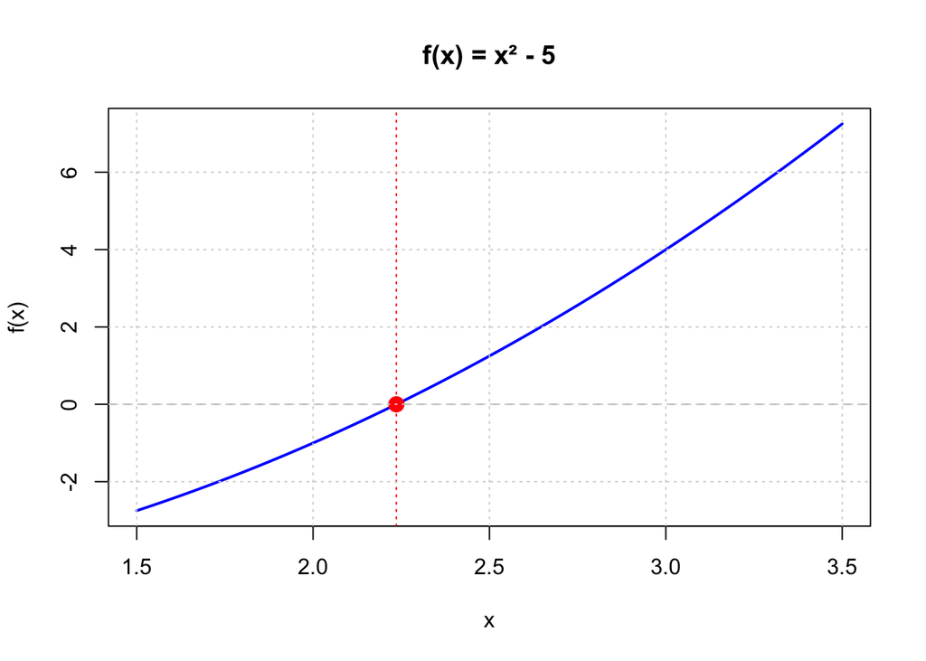

```r
x <- seq(1.5, 3.5, length.out = 500)
y <- f1(x)

plot(x, y, type = "l", main = "f(x) = x² - 5",
     xlab = "x", ylab = "f(x)", lwd = 2, col = "blue")
abline(h = 0, lty = 2, col = "gray")
abline(v = resultado1$raiz, lty = 3, col = "red")
points(resultado1$raiz, f1(resultado1$raiz), col = "red", pch = 19, cex = 1.5)
grid()
```

### Ecuación 2: f(x) = x³ - 4x + 1 en [0,1]

```r
f2 <- function(x) x^3 - 4*x + 1
resultado2 <- biseccion(f2, 0, 1, tol = 1e-6, iter_max = 100)

cat("Raíz aproximada:", resultado2$raiz, "\n")
```

```
## Raíz aproximada: 0.2541018
```

```r
cat("Iteraciones:", resultado2$iteraciones, "\n\n")
```

```
## Iteraciones: 20
```

```r
print(resultado2$tabla, digits = 8)
```

```
##     k         ak         bk         ck          f_ak           f_bk
## 1   1 0.00000000 1.00000000 0.50000000 1.0000000e+00 -2.0000000e+00
## 2   2 0.00000000 0.50000000 0.25000000 1.0000000e+00 -8.7500000e-01
## 3   3 0.25000000 0.50000000 0.37500000 1.5625000e-02 -8.7500000e-01
## 4   4 0.25000000 0.37500000 0.31250000 1.5625000e-02 -4.4726562e-01
## 5   5 0.25000000 0.31250000 0.28125000 1.5625000e-02 -2.1948242e-01
## 6   6 0.25000000 0.28125000 0.26562500 1.5625000e-02 -1.0275269e-01
## 7   7 0.25000000 0.26562500 0.25781250 1.5625000e-02 -4.3758392e-02
## 8   8 0.25000000 0.25781250 0.25390625 1.5625000e-02 -1.4113903e-02
## 9   9 0.25390625 0.25781250 0.25585938 7.4392557e-04 -1.4113903e-02
## 10 10 0.25390625 0.25585938 0.25488281 7.4392557e-04 -6.6879168e-03
## 11 11 0.25390625 0.25488281 0.25439453 7.4392557e-04 -2.9727248e-03
## 12 12 0.25390625 0.25439453 0.25415039 7.4392557e-04 -1.1145816e-03
## 13 13 0.25390625 0.25415039 0.25402832 7.4392557e-04 -1.8537346e-04
## 14 14 0.25402832 0.25415039 0.25408936 2.7926470e-04 -1.8537346e-04
```

[output cut: 27 more lines]

#### Gráfico

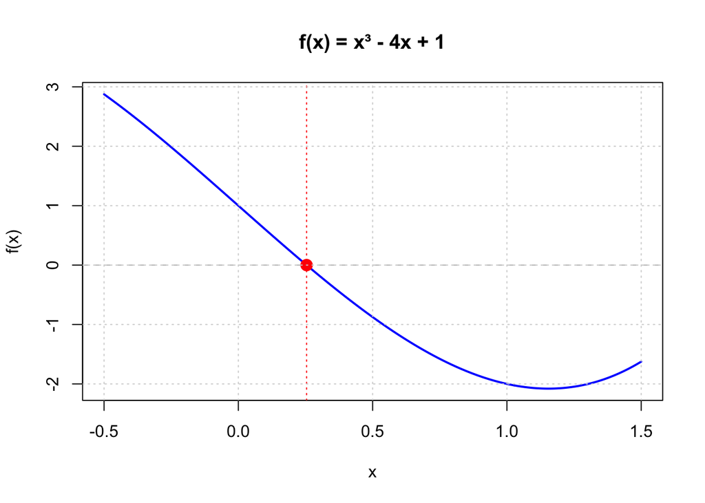

```r
x <- seq(-0.5, 1.5, length.out = 500)
y <- f2(x)

plot(x, y, type = "l", main = "f(x) = x³ - 4x + 1",
     xlab = "x", ylab = "f(x)", lwd = 2, col = "blue")
abline(h = 0, lty = 2, col = "gray")
abline(v = resultado2$raiz, lty = 3, col = "red")
points(resultado2$raiz, f2(resultado2$raiz), col = "red", pch = 19, cex = 1.5)
grid()
```

### Ecuación 3: f(x) = x⁴ - 8x + 2 en [0,3]

```r
f3 <- function(x) x^4 - 8*x + 2
resultado3 <- biseccion(f3, 0, 3, tol = 1e-6, iter_max = 100)
```

```
## Error: no hay cambio de signo en [a,b].
```

```r
cat("Raíz aproximada:", resultado3$raiz, "\n")
```

```
## Raíz aproximada: NA
```

```r
cat("Iteraciones:", resultado3$iteraciones, "\n\n")
```

```
## Iteraciones: NA
```

```r
print(resultado3$tabla, digits = 8)
```

```
## [1] NA
```

#### Gráfico

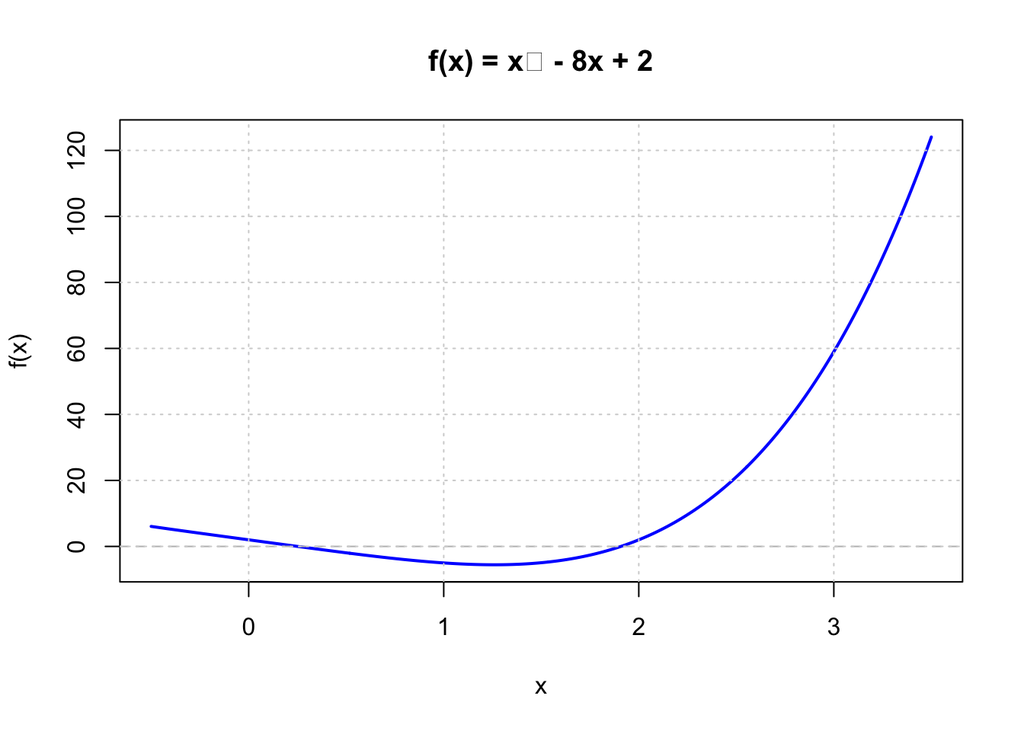

```r
x <- seq(-0.5, 3.5, length.out = 500)
y <- f3(x)

plot(x, y, type = "l", main = "f(x) = x⁴ - 8x + 2",
     xlab = "x", ylab = "f(x)", lwd = 2, col = "blue")
abline(h = 0, lty = 2, col = "gray")
abline(v = resultado3$raiz, lty = 3, col = "red")
points(resultado3$raiz, f3(resultado3$raiz), col = "red", pch = 19, cex = 1.5)
grid()
```

### Ecuación 4: f(x) = e^(-x) - x/2 en [0,2]

```r
f4 <- function(x) exp(-x) - x/2
resultado4 <- biseccion(f4, 0, 2, tol = 1e-6, iter_max = 100)

cat("Raíz aproximada:", resultado4$raiz, "\n")
```

```
## Raíz aproximada: 0.8526049
```

```r
cat("Iteraciones:", resultado4$iteraciones, "\n\n")
```

```
## Iteraciones: 21
```

```r
print(resultado4$tabla, digits = 8)
```

```
##     k         ak         bk         ck          f_ak           f_bk
## 1   1 0.00000000 2.00000000 1.00000000 1.0000000e+00 -8.6466472e-01
## 2   2 0.00000000 1.00000000 0.50000000 1.0000000e+00 -1.3212056e-01
## 3   3 0.50000000 1.00000000 0.75000000 3.5653066e-01 -1.3212056e-01
## 4   4 0.75000000 1.00000000 0.87500000 9.7366553e-02 -1.3212056e-01
## 5   5 0.75000000 0.87500000 0.81250000 9.7366553e-02 -2.0637980e-02
## 6   6 0.81250000 0.87500000 0.84375000 3.7497310e-02 -2.0637980e-02
## 7   7 0.84375000 0.87500000 0.85937500 8.2196406e-03 -2.0637980e-02
## 8   8 0.84375000 0.85937500 0.85156250 8.2196406e-03 -6.2608587e-03
## 9   9 0.85156250 0.85937500 0.85546875 9.6636759e-04 -6.2608587e-03
## 10 10 0.85156250 0.85546875 0.85351562 9.6636759e-04 -2.6504887e-03
## 11 11 0.85156250 0.85351562 0.85253906 9.6636759e-04 -8.4287292e-04
## 12 12 0.85253906 0.85351562 0.85302734 6.1544045e-05 -8.4287292e-04
## 13 13 0.85253906 0.85302734 0.85278320 6.1544045e-05 -3.9071524e-04
## 14 14 0.85253906 0.85278320 0.85266113 6.1544045e-05 -1.6459830e-04
```

[output cut: 29 more lines]

#### Gráfico

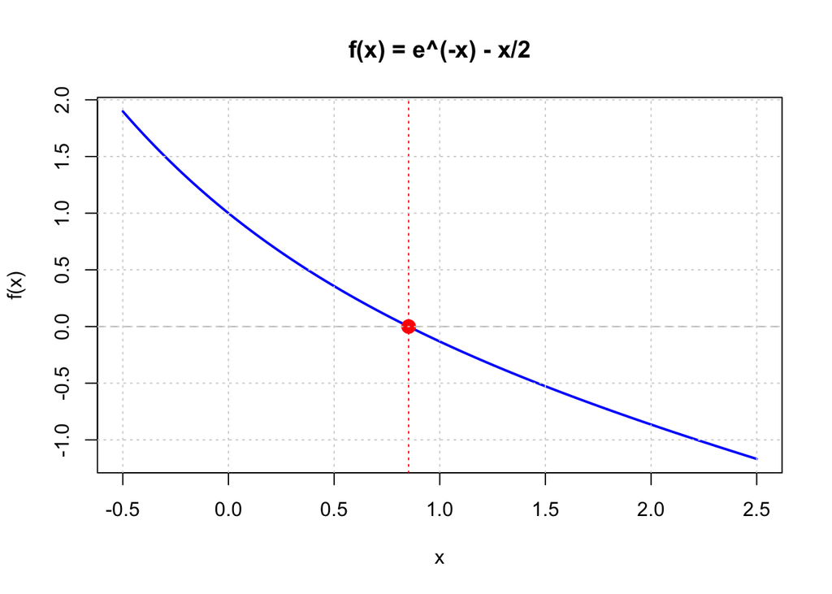

```r
x <- seq(-0.5, 2.5, length.out = 500)
y <- f4(x)

plot(x, y, type = "l", main = "f(x) = e^(-x) - x/2",
     xlab = "x", ylab = "f(x)", lwd = 2, col = "blue")
abline(h = 0, lty = 2, col = "gray")
abline(v = resultado4$raiz, lty = 3, col = "red")
points(resultado4$raiz, f4(resultado4$raiz), col = "red", pch = 19, cex = 1.5)
grid()
```

### Ecuación 5: f(x) = cos(x) - x² en [0,1]

```r
f5 <- function(x) cos(x) - x^2
resultado5 <- biseccion(f5, 0, 1, tol = 1e-6, iter_max = 100)

cat("Raíz aproximada:", resultado5$raiz, "\n")
```

```
## Raíz aproximada: 0.824132
```

```r
cat("Iteraciones:", resultado5$iteraciones, "\n\n")
```

```
## Iteraciones: 20
```

```r
print(resultado5$tabla, digits = 8)
```

```
##     k         ak         bk         ck          f_ak           f_bk
## 1   1 0.00000000 1.00000000 0.50000000 1.0000000e+00 -4.5969769e-01
## 2   2 0.50000000 1.00000000 0.75000000 6.2758256e-01 -4.5969769e-01
## 3   3 0.75000000 1.00000000 0.87500000 1.6918887e-01 -4.5969769e-01
## 4   4 0.75000000 0.87500000 0.81250000 1.6918887e-01 -1.2462814e-01
## 5   5 0.81250000 0.87500000 0.84375000 2.7529312e-02 -1.2462814e-01
## 6   6 0.81250000 0.84375000 0.82812500 2.7529312e-02 -4.7248335e-02
## 7   7 0.81250000 0.82812500 0.82031250 2.7529312e-02 -9.5328213e-03
## 8   8 0.82031250 0.82812500 0.82421875 9.0800933e-03 -9.5328213e-03
## 9   9 0.82031250 0.82421875 0.82226562 9.0800933e-03 -2.0592391e-04
## 10 10 0.82226562 0.82421875 0.82324219 4.4421974e-03 -2.0592391e-04
## 11 11 0.82324219 0.82421875 0.82373047 2.1194146e-03 -2.0592391e-04
## 12 12 0.82373047 0.82421875 0.82397461 9.5706477e-04 -2.0592391e-04
## 13 13 0.82397461 0.82421875 0.82409668 3.7565028e-04 -2.0592391e-04
## 14 14 0.82409668 0.82421875 0.82415771 8.4883147e-05 -2.0592391e-04
```

[output cut: 27 more lines]

#### Gráfico

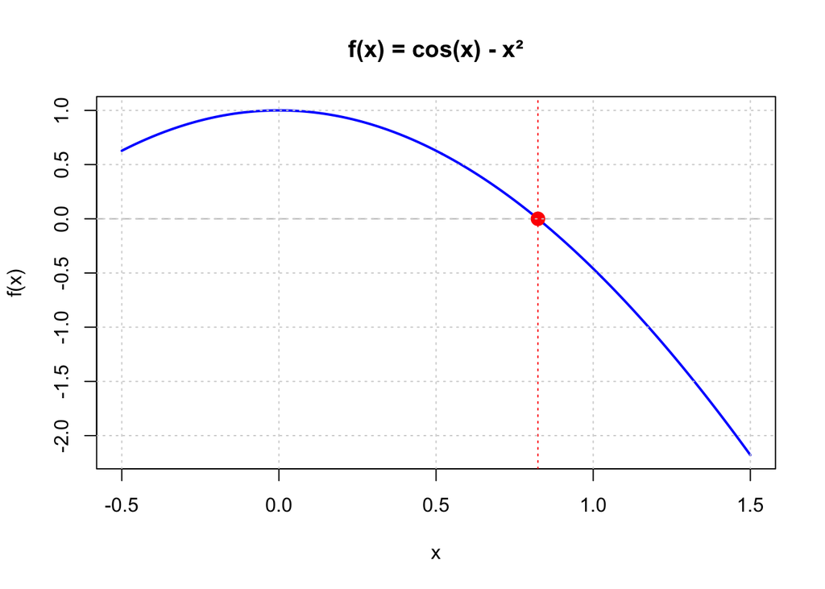

```r
x <- seq(-0.5, 1.5, length.out = 500)
y <- f5(x)

plot(x, y, type = "l", main = "f(x) = cos(x) - x²",
     xlab = "x", ylab = "f(x)", lwd = 2, col = "blue")
abline(h = 0, lty = 2, col = "gray")
abline(v = resultado5$raiz, lty = 3, col = "red")
points(resultado5$raiz, f5(resultado5$raiz), col = "red", pch = 19, cex = 1.5)
grid()
```

### Ecuación 6: f(x) = 3x² - 7x - 2 en [-1, 0]

```r
f6 <- function(x) 3*x^2 - 7*x - 2
resultado6 <- biseccion(f6, -1, 0, tol = 1e-6, iter_max = 100)

cat("Raíz aproximada:", resultado6$raiz, "\n")
```

```
## Raíz aproximada: -0.2573347
```

```r
cat("Iteraciones:", resultado6$iteraciones, "\n\n")
```

```
## Iteraciones: 20
```

```r
print(resultado6$tabla, digits = 8)
```

```
##     k          ak          bk          ck          f_ak           f_bk
## 1   1 -1.00000000  0.00000000 -0.50000000 8.0000000e+00 -2.0000000e+00
## 2   2 -0.50000000  0.00000000 -0.25000000 2.2500000e+00 -2.0000000e+00
## 3   3 -0.50000000 -0.25000000 -0.37500000 2.2500000e+00 -6.2500000e-02
## 4   4 -0.37500000 -0.25000000 -0.31250000 1.0468750e+00 -6.2500000e-02
## 5   5 -0.31250000 -0.25000000 -0.28125000 4.8046875e-01 -6.2500000e-02
## 6   6 -0.28125000 -0.25000000 -0.26562500 2.0605469e-01 -6.2500000e-02
## 7   7 -0.26562500 -0.25000000 -0.25781250 7.1044922e-02 -6.2500000e-02
## 8   8 -0.25781250 -0.25000000 -0.25390625 4.0893555e-03 -6.2500000e-02
## 9   9 -0.25781250 -0.25390625 -0.25585938 4.0893555e-03 -2.9251099e-02
## 10 10 -0.25781250 -0.25585938 -0.25683594 4.0893555e-03 -1.2592316e-02
## 11 11 -0.25781250 -0.25683594 -0.25732422 4.0893555e-03 -4.2543411e-03
## 12 12 -0.25781250 -0.25732422 -0.25756836 4.0893555e-03 -8.3208084e-05
## 13 13 -0.25756836 -0.25732422 -0.25744629 2.0028949e-03 -8.3208084e-05
## 14 14 -0.25744629 -0.25732422 -0.25738525 9.5979869e-04 -8.3208084e-05
```

[output cut: 27 more lines]

#### Gráfico

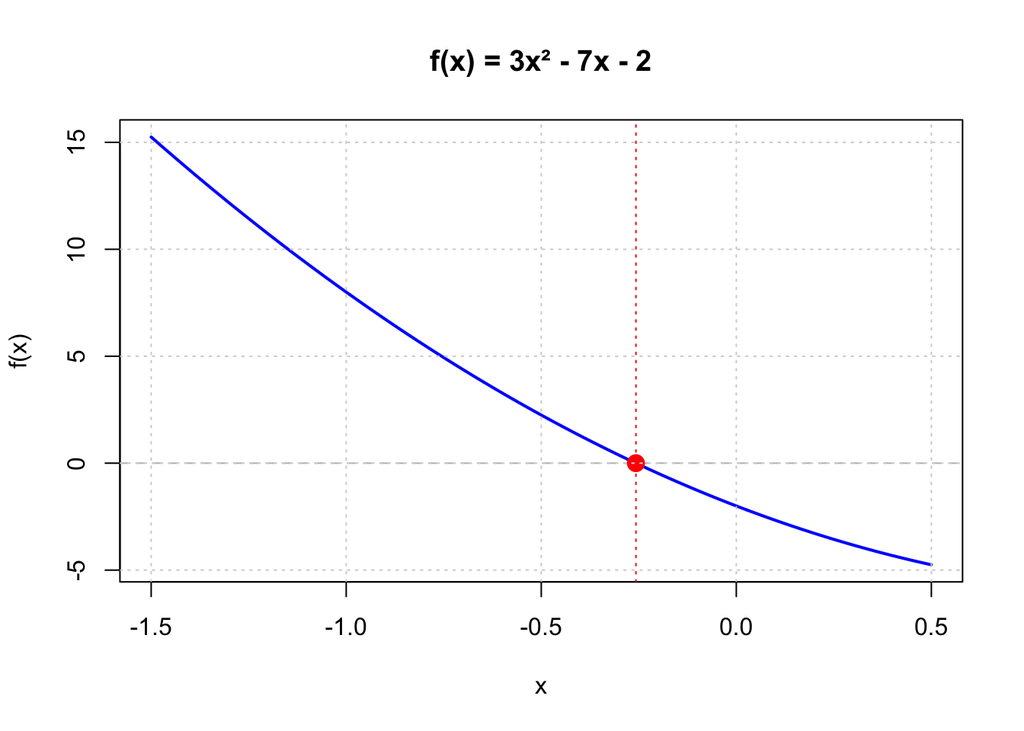

```r
x <- seq(-1.5, 0.5, length.out = 500)
y <- f6(x)

plot(x, y, type = "l", main = "f(x) = 3x² - 7x - 2",
     xlab = "x", ylab = "f(x)", lwd = 2, col = "blue")
abline(h = 0, lty = 2, col = "gray")
abline(v = resultado6$raiz, lty = 3, col = "red")
points(resultado6$raiz, f6(resultado6$raiz), col = "red", pch = 19, cex = 1.5)
grid()
```

### Ecuación 7: f(x) = -4x² + 5x + 6 en [-1, 0]

```r
f7 <- function(x) -4*x^2 + 5*x + 6
resultado7 <- biseccion(f7, -1, 0, tol = 1e-6, iter_max = 100)

cat("Raíz aproximada:", resultado7$raiz, "\n")
```

```
## Raíz aproximada: -0.500001
```

```r
cat("Iteraciones:", resultado7$iteraciones, "\n\n")
```

```
## Iteraciones: 20
```

```r
print(resultado7$tabla, digits = 8)
```

```
##     k          ak   bk          ck       f_ak f_bk      f_ck signo
## 1   1 -1.00000000  0.0 -0.50000000 -3.0000000  6.0 2.5000000     -
## 2   2 -1.00000000 -0.5 -0.75000000 -3.0000000  2.5 0.0000000     +
## 3   3 -0.75000000 -0.5 -0.62500000  0.0000000  2.5 1.3125000     +
## 4   4 -0.62500000 -0.5 -0.56250000  1.3125000  2.5 1.9218750     +
## 5   5 -0.56250000 -0.5 -0.53125000  1.9218750  2.5 2.2148438     +
## 6   6 -0.53125000 -0.5 -0.51562500  2.2148438  2.5 2.3583984     +
## 7   7 -0.51562500 -0.5 -0.50781250  2.3583984  2.5 2.4294434     +
## 8   8 -0.50781250 -0.5 -0.50390625  2.4294434  2.5 2.4647827     +
## 9   9 -0.50390625 -0.5 -0.50195312  2.4647827  2.5 2.4824066     +
## 10 10 -0.50195312 -0.5 -0.50097656  2.4824066  2.5 2.4912071     +
## 11 11 -0.50097656 -0.5 -0.50048828  2.4912071  2.5 2.4956045     +
## 12 12 -0.50048828 -0.5 -0.50024414  2.4956045  2.5 2.4978025     +
## 13 13 -0.50024414 -0.5 -0.50012207  2.4978025  2.5 2.4989013     +
## 14 14 -0.50012207 -0.5 -0.50006104  2.4989013  2.5 2.4994507     +
```

[output cut: 27 more lines]

#### Gráfico

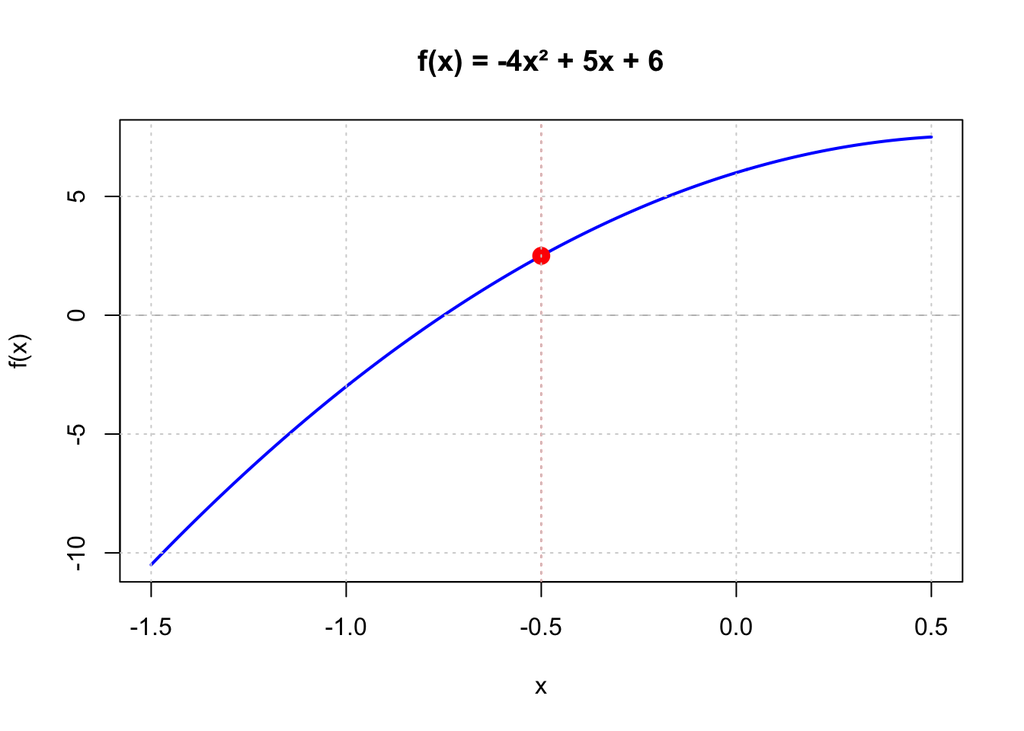

```r
x <- seq(-1.5, 0.5, length.out = 500)
y <- f7(x)

plot(x, y, type = "l", main = "f(x) = -4x² + 5x + 6",
     xlab = "x", ylab = "f(x)", lwd = 2, col = "blue")
abline(h = 0, lty = 2, col = "gray")
abline(v = resultado7$raiz, lty = 3, col = "red")
points(resultado7$raiz, f7(resultado7$raiz), col = "red", pch = 19, cex = 1.5)
grid()
```

### Ecuación 8: f(x) = 2x² + 3x - 5 en [0, 2]

```r
f8 <- function(x) 2*x^2 + 3*x - 5
resultado8 <- biseccion(f8, 0, 2, tol = 1e-6, iter_max = 100)

cat("Raíz aproximada:", resultado8$raiz, "\n")
```

```
## Raíz aproximada: 1.999999
```

```r
cat("Iteraciones:", resultado8$iteraciones, "\n\n")
```

```
## Iteraciones: 21
```

```r
print(resultado8$tabla, digits = 8)
```

```
##     k        ak bk        ck       f_ak f_bk      f_ck signo         error
## 1   1 0.0000000  2 1.0000000 -5.0000000    9 0.0000000     + 2.0000000e+00
## 2   2 1.0000000  2 1.5000000  0.0000000    9 4.0000000     + 1.0000000e+00
## 3   3 1.5000000  2 1.7500000  4.0000000    9 6.3750000     + 5.0000000e-01
## 4   4 1.7500000  2 1.8750000  6.3750000    9 7.6562500     + 2.5000000e-01
## 5   5 1.8750000  2 1.9375000  7.6562500    9 8.3203125     + 1.2500000e-01
## 6   6 1.9375000  2 1.9687500  8.3203125    9 8.6582031     + 6.2500000e-02
## 7   7 1.9687500  2 1.9843750  8.6582031    9 8.8286133     + 3.1250000e-02
## 8   8 1.9843750  2 1.9921875  8.8286133    9 8.9141846     + 1.5625000e-02
## 9   9 1.9921875  2 1.9960938  8.9141846    9 8.9570618     + 7.8125000e-03
## 10 10 1.9960938  2 1.9980469  8.9570618    9 8.9785233     + 3.9062500e-03
## 11 11 1.9980469  2 1.9990234  8.9785233    9 8.9892597     + 1.9531250e-03
## 12 12 1.9990234  2 1.9995117  8.9892597    9 8.9946294     + 9.7656250e-04
## 13 13 1.9995117  2 1.9997559  8.9946294    9 8.9973146     + 4.8828125e-04
## 14 14 1.9997559  2 1.9998779  8.9973146    9 8.9986573     + 2.4414062e-04
## 15 15 1.9998779  2 1.9999390  8.9986573    9 8.9993286     + 1.2207031e-04
## 16 16 1.9999390  2 1.9999695  8.9993286    9 8.9996643     + 6.1035156e-05
## 17 17 1.9999695  2 1.9999847  8.9996643    9 8.9998322     + 3.0517578e-05
## 18 18 1.9999847  2 1.9999924  8.9998322    9 8.9999161     + 1.5258789e-05
## 19 19 1.9999924  2 1.9999962  8.9999161    9 8.9999580     + 7.6293945e-06
## 20 20 1.9999962  2 1.9999981  8.9999580    9 8.9999790     + 3.8146973e-06
## 21 21 1.9999981  2 1.9999990  8.9999790    9 8.9999895     + 1.9073486e-06
```

#### Gráfico

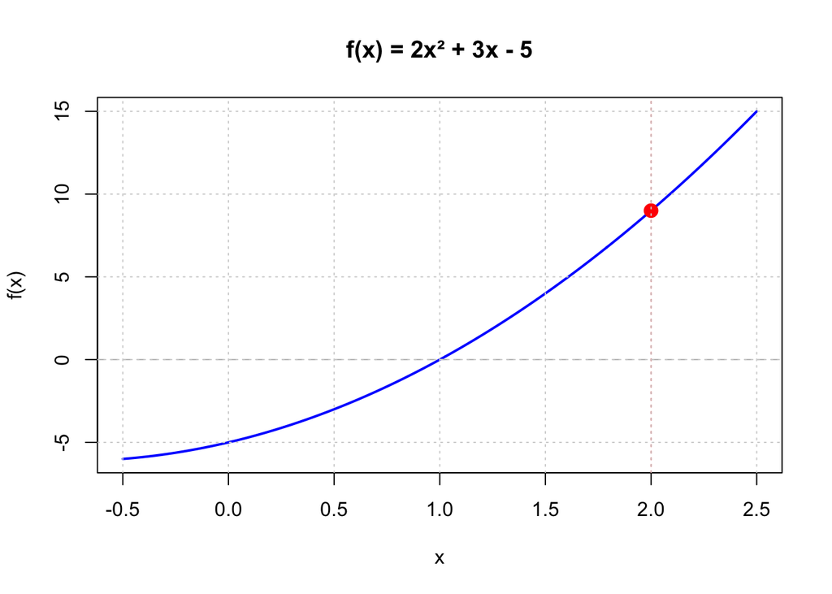

```r
x <- seq(-0.5, 2.5, length.out = 500)
y <- f8(x)

plot(x, y, type = "l", main = "f(x) = 2x² + 3x - 5",
     xlab = "x", ylab = "f(x)", lwd = 2, col = "blue")
abline(h = 0, lty = 2, col = "gray")
abline(v = resultado8$raiz, lty = 3, col = "red")
points(resultado8$raiz, f8(resultado8$raiz), col = "red", pch = 19, cex = 1.5)
grid()
```

### Ecuación 9: f(x) = x³ - 5x + 1 en [0, 1]

```r
f9 <- function(x) x^3 - 5*x + 1
resultado9 <- biseccion(f9, 0, 1, tol = 1e-6, iter_max = 100)

cat("Raíz aproximada:", resultado9$raiz, "\n")
```

```
## Raíz aproximada: 0.2016401
```

```r
cat("Iteraciones:", resultado9$iteraciones, "\n\n")
```

```
## Iteraciones: 20
```

```r
print(resultado9$tabla, digits = 8)
```

```
##     k         ak         bk         ck          f_ak           f_bk
## 1   1 0.00000000 1.00000000 0.50000000 1.0000000e+00 -3.0000000e+00
## 2   2 0.00000000 0.50000000 0.25000000 1.0000000e+00 -1.3750000e+00
## 3   3 0.00000000 0.25000000 0.12500000 1.0000000e+00 -2.3437500e-01
## 4   4 0.12500000 0.25000000 0.18750000 3.7695312e-01 -2.3437500e-01
## 5   5 0.18750000 0.25000000 0.21875000 6.9091797e-02 -2.3437500e-01
## 6   6 0.18750000 0.21875000 0.20312500 6.9091797e-02 -8.3282471e-02
## 7   7 0.18750000 0.20312500 0.19531250 6.9091797e-02 -7.2441101e-03
## 8   8 0.19531250 0.20312500 0.19921875 3.0888081e-02 -7.2441101e-03
## 9   9 0.19921875 0.20312500 0.20117188 1.1812866e-02 -7.2441101e-03
## 10 10 0.20117188 0.20312500 0.20214844 2.2820756e-03 -7.2441101e-03
## 11 11 0.20117188 0.20214844 0.20166016 2.2820756e-03 -2.4815956e-03
## 12 12 0.20117188 0.20166016 0.20141602 2.2820756e-03 -9.9904253e-05
## 13 13 0.20141602 0.20166016 0.20153809 1.0910496e-03 -9.9904253e-05
## 14 14 0.20153809 0.20166016 0.20159912 4.9556369e-04 -9.9904253e-05
```

[output cut: 27 more lines]

#### Gráfico

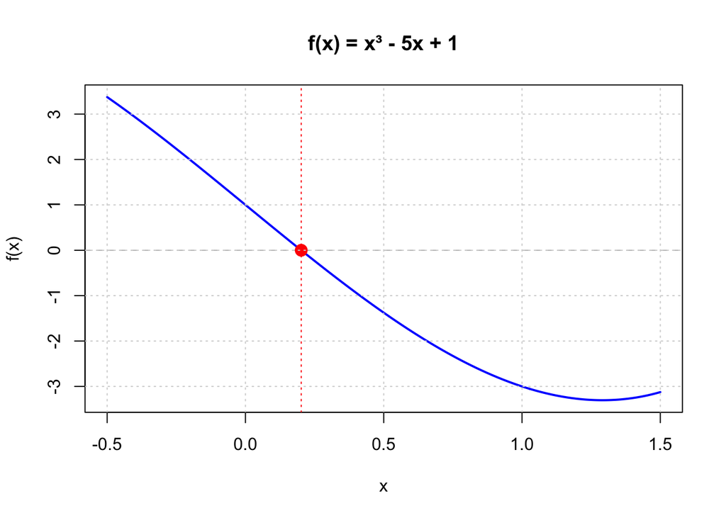

```r
x <- seq(-0.5, 1.5, length.out = 500)
y <- f9(x)

plot(x, y, type = "l", main = "f(x) = x³ - 5x + 1",
     xlab = "x", ylab = "f(x)", lwd = 2, col = "blue")
abline(h = 0, lty = 2, col = "gray")
abline(v = resultado9$raiz, lty = 3, col = "red")
points(resultado9$raiz, f9(resultado9$raiz), col = "red", pch = 19, cex = 1.5)
grid()
```

### Ecuación 10: f(x) = x⁴ - 6x³ + 5x² + 8x - 4 en [0, 1]

```r
f10 <- function(x) x^4 - 6*x^3 + 5*x^2 + 8*x - 4
resultado10 <- biseccion(f10, 0, 1, tol = 1e-6, iter_max = 100)

cat("Raíz aproximada:", resultado10$raiz, "\n")
```

```
## Raíz aproximada: 0.438447
```

```r
cat("Iteraciones:", resultado10$iteraciones, "\n\n")
```

```
## Iteraciones: 20
```

```r
print(resultado10$tabla, digits = 8)
```

```
##     k         ak         bk         ck           f_ak          f_bk
## 1   1 0.00000000 1.00000000 0.50000000 -4.0000000e+00 4.0000000e+00
## 2   2 0.00000000 0.50000000 0.25000000 -4.0000000e+00 5.6250000e-01
## 3   3 0.25000000 0.50000000 0.37500000 -1.7773438e+00 5.6250000e-01
## 4   4 0.37500000 0.50000000 0.43750000 -5.9350586e-01 5.6250000e-01
## 5   5 0.43750000 0.50000000 0.46875000 -8.7738037e-03 5.6250000e-01
## 6   6 0.43750000 0.46875000 0.45312500 -8.7738037e-03 2.7893162e-01
## 7   7 0.43750000 0.45312500 0.44531250 -8.7738037e-03 1.3554865e-01
## 8   8 0.43750000 0.44531250 0.44140625 -8.7738037e-03 6.3498858e-02
## 9   9 0.43750000 0.44140625 0.43945312 -8.7738037e-03 2.7389631e-02
## 10 10 0.43750000 0.43945312 0.43847656 -8.7738037e-03 9.3145948e-03
## 11 11 0.43750000 0.43847656 0.43798828 -8.7738037e-03 2.7205399e-04
## 12 12 0.43798828 0.43847656 0.43823242 -4.2504617e-03 2.7205399e-04
## 13 13 0.43823242 0.43847656 0.43835449 -1.9891004e-03 2.7205399e-04
## 14 14 0.43835449 0.43847656 0.43841553 -8.5849731e-04 2.7205399e-04
```

[output cut: 27 more lines]

**Gráfico:**

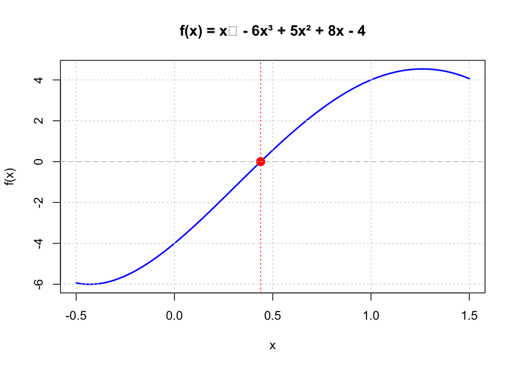

```r
x <- seq(-0.5, 1.5, length.out = 500)
y <- f10(x)

plot(x, y, type = "l", main = "f(x) = x⁴ - 6x³ + 5x² + 8x - 4",
     xlab = "x", ylab = "f(x)", lwd = 2, col = "blue")
abline(h = 0, lty = 2, col = "gray")
abline(v = resultado10$raiz, lty = 3, col = "red")
points(resultado10$raiz, f10(resultado10$raiz), col = "red", pch = 19, cex = 1.5)
grid()
```

## Función Principal del Método de la Secante

```r
secante <- function(f, x0, x1, tol = 1e-5, iter_max = 100) {

  tabla <- data.frame(
    k = numeric(),
    xk_1 = numeric(),
    xk = numeric(),
    xk_1_nuevo = numeric(),
    f_xk_1 = numeric(),
    f_xk = numeric(),
    f_xk_1_nuevo = numeric(),
    error = numeric(),
    stringsAsFactors = FALSE
  )

  iter <- 0
  error <- abs(x1 - x0)

  while(error > tol && iter < iter_max) {
    f_x0 <- f(x0)
    f_x1 <- f(x1)

    if(abs(f_x1 - f_x0) < 1e-15) {
      break
    }

    x2 <- x1 - f_x1 * (x1 - x0) / (f_x1 - f_x0)
    f_x2 <- f(x2)

    tabla <- rbind(tabla, data.frame(
      k = iter + 1,
      xk_1 = x0,
      xk = x1,
      xk_1_nuevo = x2,
      f_xk_1 = f_x0,
      f_xk = f_x1,
      f_xk_1_nuevo = f_x2,
      error = abs(x2 - x1)
    ))

    x0 <- x1
    x1 <- x2
    error <- abs(x2 - x1)
    iter <- iter + 1
  }

  return(list(raiz = x1, iteraciones = iter, tabla = tabla))
}
```

### Ecuación 1: f(x) = x² - 2x - 3, x₀ = 0, x₁ = 3

```r
f1 <- function(x) x^2 - 2*x - 3
resultado1 <- secante(f1, 0, 3, tol = 1e-5, iter_max = 100)

cat("Raíz aproximada:", resultado1$raiz, "\n")
```

```
## Raíz aproximada: 3
```

```r
cat("Iteraciones:", resultado1$iteraciones, "\n\n")
```

```
## Iteraciones: 1
```

```r
print(resultado1$tabla, digits = 8)
```

```
##   k xk_1 xk xk_1_nuevo f_xk_1 f_xk f_xk_1_nuevo error
## 1 1    0  3          3     -3    0            0     0
```

#### Gráfico con secantes

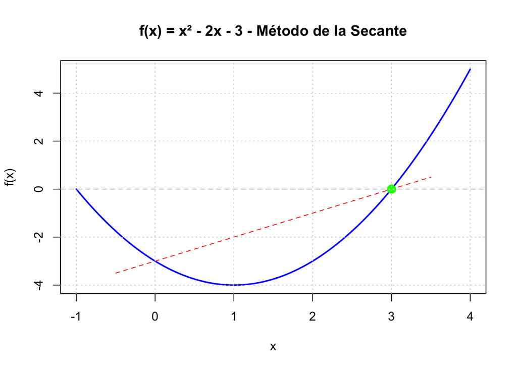

```r
x_plot <- seq(-1, 4, length.out = 500)
y_plot <- f1(x_plot)

plot(x_plot, y_plot, type = "l", main = "f(x) = x² - 2x - 3 - Método de la Secante",
     xlab = "x", ylab = "f(x)", lwd = 2, col = "blue")
abline(h = 0, lty = 2, col = "gray")

x0 <- 0
x1 <- 3
for(i in 1:min(3, nrow(resultado1$tabla))) {
  f_x0 <- f1(x0)
  f_x1 <- f1(x1)
  x2 <- x1 - f_x1 * (x1 - x0) / (f_x1 - f_x0)

  x_secante <- c(x0 - 0.5, x2 + 0.5)
  y_secante <- f_x0 + (f_x1 - f_x0) / (x1 - x0) * (x_secante - x0)

  lines(x_secante, y_secante, col = "red", lty = 2, alpha = 0.6)
  points(x2, 0, col = "red", pch = 19, cex = 1)

  x0 <- x1
  x1 <- x2
}
points(resultado1$raiz, f1(resultado1$raiz), col = "green", pch = 19, cex = 1.5)
grid()
```

### Ecuación 2: f(x) = x⁴ - 10x² + 9, x₀ = 0, x₁ = 2

```r
f2 <- function(x) x^4 - 10*x^2 + 9
resultado2 <- secante(f2, 0, 2, tol = 1e-5, iter_max = 100)

cat("Raíz aproximada:", resultado2$raiz, "\n")
```

```
## Raíz aproximada: 0.75
```

```r
cat("Iteraciones:", resultado2$iteraciones, "\n\n")
```

```
## Iteraciones: 1
```

```r
print(resultado2$tabla, digits = 8)
```

```
##   k xk_1 xk xk_1_nuevo f_xk_1 f_xk f_xk_1_nuevo error
## 1 1    0  2       0.75      9  -15    3.6914062  1.25
```

#### Gráfico con secantes

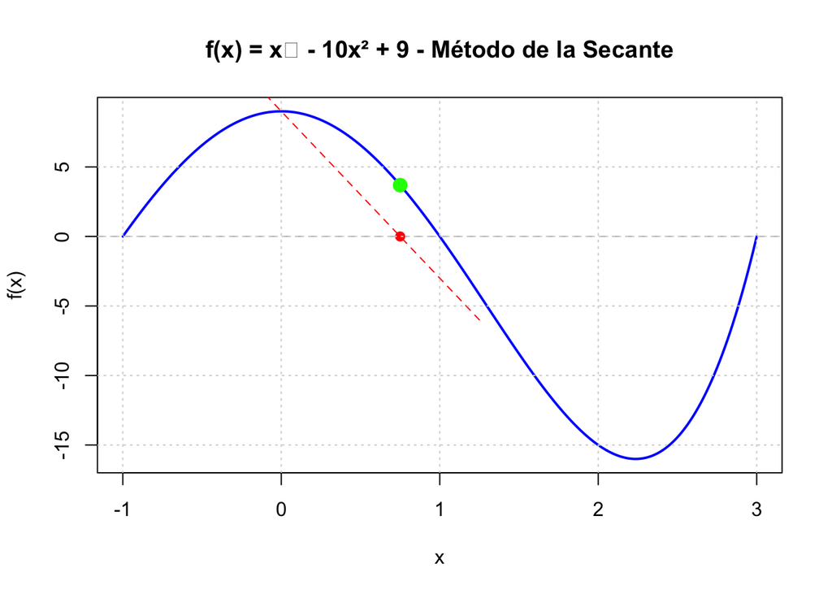

```r
x_plot <- seq(-1, 3, length.out = 500)
y_plot <- f2(x_plot)

plot(x_plot, y_plot, type = "l", main = "f(x) = x⁴ - 10x² + 9 - Método de la Secante",
     xlab = "x", ylab = "f(x)", lwd = 2, col = "blue")
abline(h = 0, lty = 2, col = "gray")

x0 <- 0
x1 <- 2
for(i in 1:min(3, nrow(resultado2$tabla))) {
  f_x0 <- f2(x0)
  f_x1 <- f2(x1)
  x2 <- x1 - f_x1 * (x1 - x0) / (f_x1 - f_x0)

  x_secante <- c(x0 - 0.5, x2 + 0.5)
  y_secante <- f_x0 + (f_x1 - f_x0) / (x1 - x0) * (x_secante - x0)

  lines(x_secante, y_secante, col = "red", lty = 2, alpha = 0.6)
  points(x2, 0, col = "red", pch = 19, cex = 1)

  x0 <- x1
  x1 <- x2
}
points(resultado2$raiz, f2(resultado2$raiz), col = "green", pch = 19, cex = 1.5)
grid()
```

### Ecuación 3: f(x) = 2x² - 5x + 3, x₀ = -1, x₁ = 2

```r
f3 <- function(x) 2*x^2 - 5*x + 3
resultado3 <- secante(f3, -1, 2, tol = 1e-5, iter_max = 100)

cat("Raíz aproximada:", resultado3$raiz, "\n")
```

```
## Raíz aproximada: 2.333333
```

```r
cat("Iteraciones:", resultado3$iteraciones, "\n\n")
```

```
## Iteraciones: 1
```

```r
print(resultado3$tabla, digits = 8)
```

```
##   k xk_1 xk xk_1_nuevo f_xk_1 f_xk f_xk_1_nuevo      error
## 1 1   -1  2  2.3333333     10    1    2.2222222 0.33333333
```

#### Gráfico con secantes

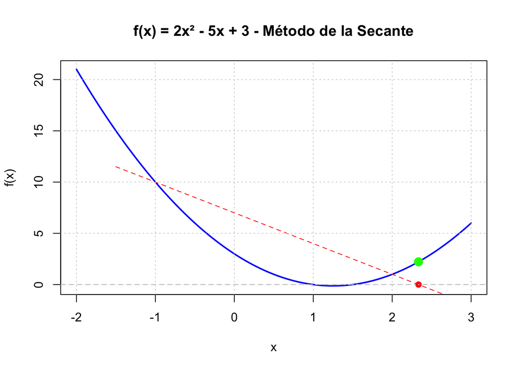

```r
x_plot <- seq(-2, 3, length.out = 500)
y_plot <- f3(x_plot)

plot(x_plot, y_plot, type = "l", main = "f(x) = 2x² - 5x + 3 - Método de la Secante",
     xlab = "x", ylab = "f(x)", lwd = 2, col = "blue")
abline(h = 0, lty = 2, col = "gray")

x0 <- -1
x1 <- 2
for(i in 1:min(3, nrow(resultado3$tabla))) {
  f_x0 <- f3(x0)
  f_x1 <- f3(x1)
  x2 <- x1 - f_x1 * (x1 - x0) / (f_x1 - f_x0)

  x_secante <- c(x0 - 0.5, x2 + 0.5)
  y_secante <- f_x0 + (f_x1 - f_x0) / (x1 - x0) * (x_secante - x0)

  lines(x_secante, y_secante, col = "red", lty = 2, alpha = 0.6)
  points(x2, 0, col = "red", pch = 19, cex = 1)

  x0 <- x1
  x1 <- x2
}
points(resultado3$raiz, f3(resultado3$raiz), col = "green", pch = 19, cex = 1.5)
grid()
```

### Ecuación 4: f(x) = -3x² + 4x + 2, x₀ = -1, x₁ = 3

```r
f4 <- function(x) -3*x^2 + 4*x + 2
resultado4 <- secante(f4, -1, 3, tol = 1e-5, iter_max = 100)

cat("Raíz aproximada:", resultado4$raiz, "\n")
```

```
## Raíz aproximada: -3.5
```

```r
cat("Iteraciones:", resultado4$iteraciones, "\n\n")
```

```
## Iteraciones: 1
```

```r
print(resultado4$tabla, digits = 8)
```

```
##   k xk_1 xk xk_1_nuevo f_xk_1 f_xk f_xk_1_nuevo error
## 1 1   -1  3       -3.5     -5  -13       -48.75   6.5
```

#### Gráfico con secantes

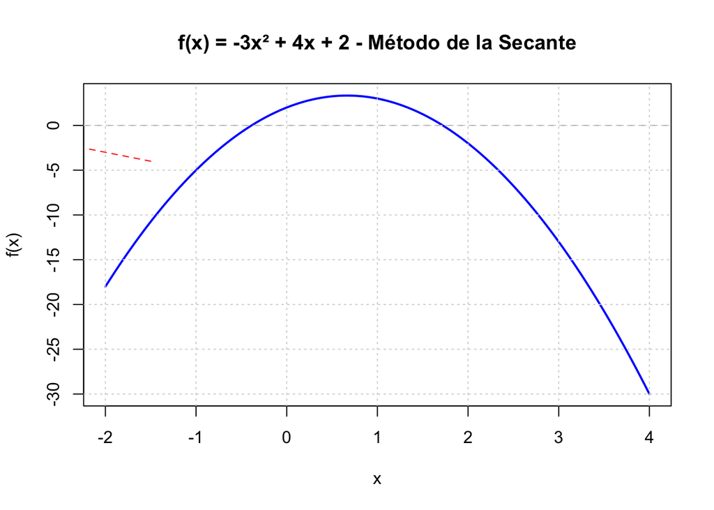

```r
x_plot <- seq(-2, 4, length.out = 500)
y_plot <- f4(x_plot)

plot(x_plot, y_plot, type = "l", main = "f(x) = -3x² + 4x + 2 - Método de la Secante",
     xlab = "x", ylab = "f(x)", lwd = 2, col = "blue")
abline(h = 0, lty = 2, col = "gray")

x0 <- -1
x1 <- 3
for(i in 1:min(3, nrow(resultado4$tabla))) {
  f_x0 <- f4(x0)
  f_x1 <- f4(x1)
  x2 <- x1 - f_x1 * (x1 - x0) / (f_x1 - f_x0)

  x_secante <- c(x0 - 0.5, x2 + 0.5)
  y_secante <- f_x0 + (f_x1 - f_x0) / (x1 - x0) * (x_secante - x0)

  lines(x_secante, y_secante, col = "red", lty = 2, alpha = 0.6)
  points(x2, 0, col = "red", pch = 19, cex = 1)

  x0 <- x1
  x1 <- x2
}
points(resultado4$raiz, f4(resultado4$raiz), col = "green", pch = 19, cex = 1.5)
grid()
```

### Ecuación 5: f(x) = x³ + 4x² - x - 1, x₀ = -3, x₁ = 1.5

```r
f5 <- function(x) x^3 + 4*x^2 - x - 1
resultado5 <- secante(f5, -3, 1.5, tol = 1e-5, iter_max = 100)

cat("Raíz aproximada:", resultado5$raiz, "\n")
```

```
## Raíz aproximada: 41
```

```r
cat("Iteraciones:", resultado5$iteraciones, "\n\n")
```

```
## Iteraciones: 1
```

```r
print(resultado5$tabla, digits = 8)
```

```
##   k xk_1  xk xk_1_nuevo f_xk_1  f_xk f_xk_1_nuevo error
## 1 1   -3 1.5         41     11 9.875        75603  39.5
```

#### Gráfico con secantes

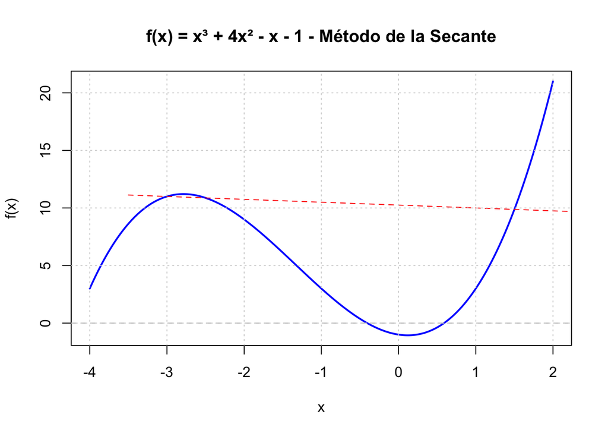

```r
x_plot <- seq(-4, 2, length.out = 500)
y_plot <- f5(x_plot)

plot(x_plot, y_plot, type = "l", main = "f(x) = x³ + 4x² - x - 1 - Método de la Secante",
     xlab = "x", ylab = "f(x)", lwd = 2, col = "blue")
abline(h = 0, lty = 2, col = "gray")

x0 <- -3
x1 <- 1.5
for(i in 1:min(3, nrow(resultado5$tabla))) {
  f_x0 <- f5(x0)
  f_x1 <- f5(x1)
  x2 <- x1 - f_x1 * (x1 - x0) / (f_x1 - f_x0)

  x_secante <- c(x0 - 0.5, x2 + 0.5)
  y_secante <- f_x0 + (f_x1 - f_x0) / (x1 - x0) * (x_secante - x0)

  lines(x_secante, y_secante, col = "red", lty = 2, alpha = 0.6)
  points(x2, 0, col = "red", pch = 19, cex = 1)

  x0 <- x1
  x1 <- x2
}
points(resultado5$raiz, f5(resultado5$raiz), col = "green", pch = 19, cex = 1.5)
grid()
```

### Ecuación 6: f(x) = -3e^(-1.2x+0.4) + 2, x₀ = 0, x₁ = 1

```r
f6 <- function(x) -3*exp(-1.2*x + 0.4) + 2
resultado6 <- secante(f6, 0, 1, tol = 1e-5, iter_max = 100)

cat("Raíz aproximada:", resultado6$raiz, "\n")
```

```
## Raíz aproximada: 0.7915217
```

```r
cat("Iteraciones:", resultado6$iteraciones, "\n\n")
```

```
## Iteraciones: 1
```

```r
print(resultado6$tabla, digits = 8)
```

```
##   k xk_1 xk xk_1_nuevo     f_xk_1       f_xk f_xk_1_nuevo      error
## 1 1    0  1 0.79152173 -2.4754741 0.65201311   0.26884952 0.20847827
```

#### Gráfico con secantes

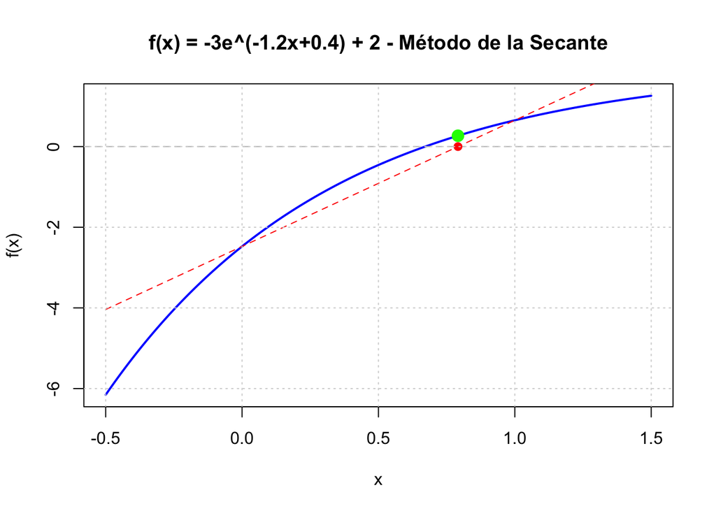

```r
x_plot <- seq(-0.5, 1.5, length.out = 500)
y_plot <- f6(x_plot)

plot(x_plot, y_plot, type = "l", main = "f(x) = -3e^(-1.2x+0.4) + 2 - Método de la Secante",
     xlab = "x", ylab = "f(x)", lwd = 2, col = "blue")
abline(h = 0, lty = 2, col = "gray")

x0 <- 0
x1 <- 1
for(i in 1:min(3, nrow(resultado6$tabla))) {
  f_x0 <- f6(x0)
  f_x1 <- f6(x1)
  x2 <- x1 - f_x1 * (x1 - x0) / (f_x1 - f_x0)

  x_secante <- c(x0 - 0.5, x2 + 0.5)
  y_secante <- f_x0 + (f_x1 - f_x0) / (x1 - x0) * (x_secante - x0)

  lines(x_secante, y_secante, col = "red", lty = 2, alpha = 0.6)
  points(x2, 0, col = "red", pch = 19, cex = 1)

  x0 <- x1
  x1 <- x2
}
points(resultado6$raiz, f6(resultado6$raiz), col = "green", pch = 19, cex = 1.5)
grid()
```

### Ecuación 7: f(x) = -2x⁴ + 3x³ + 7x² - 5x + 1, x₀ = 2, x₁ = 4

```r
f7 <- function(x) -2*x^4 + 3*x^3 + 7*x^2 - 5*x + 1
resultado7 <- secante(f7, 2, 4, tol = 1e-5, iter_max = 100)

cat("Raíz aproximada:", resultado7$raiz, "\n")
```

```
## Raíz aproximada: 2.092437
```

```r
cat("Iteraciones:", resultado7$iteraciones, "\n\n")
```

```
## Iteraciones: 1
```

```r
print(resultado7$tabla, digits = 8)
```

```
##   k xk_1 xk xk_1_nuevo f_xk_1 f_xk f_xk_1_nuevo    error
## 1 1    2  4   2.092437     11 -227    10.330876 1.907563
```

#### Gráfico con secantes

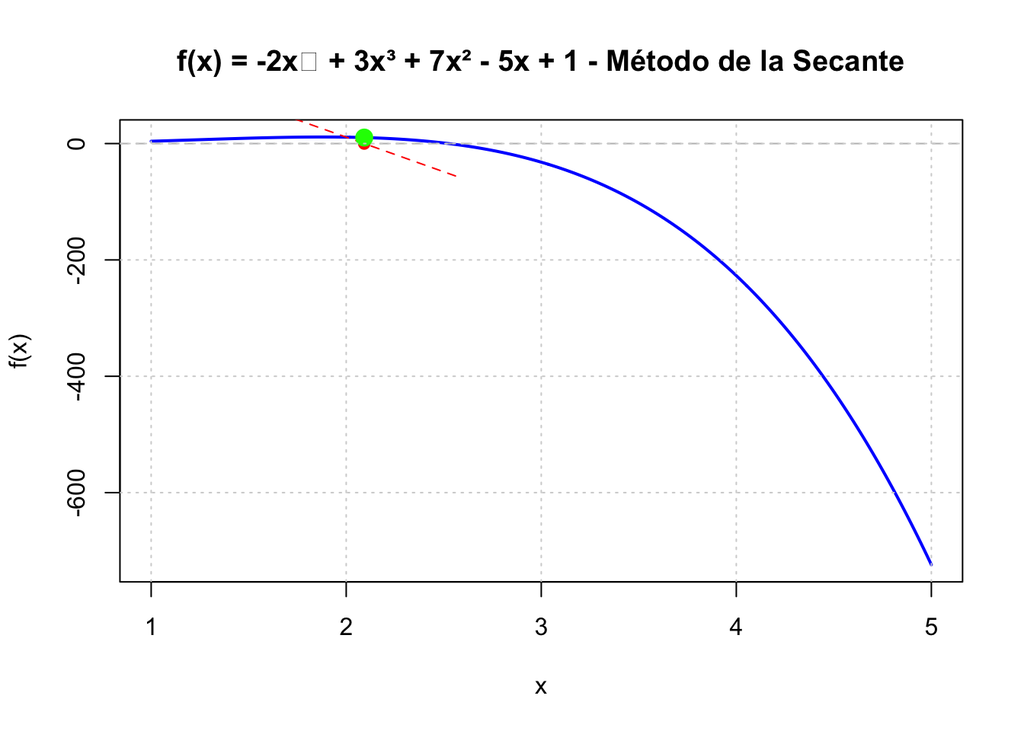

```r
x_plot <- seq(1, 5, length.out = 500)
y_plot <- f7(x_plot)

plot(x_plot, y_plot, type = "l", main = "f(x) = -2x⁴ + 3x³ + 7x² - 5x + 1 - Método de la Secante",
     xlab = "x", ylab = "f(x)", lwd = 2, col = "blue")
abline(h = 0, lty = 2, col = "gray")

x0 <- 2
x1 <- 4
for(i in 1:min(3, nrow(resultado7$tabla))) {
  f_x0 <- f7(x0)
  f_x1 <- f7(x1)
  x2 <- x1 - f_x1 * (x1 - x0) / (f_x1 - f_x0)

  x_secante <- c(x0 - 0.5, x2 + 0.5)
  y_secante <- f_x0 + (f_x1 - f_x0) / (x1 - x0) * (x_secante - x0)

  lines(x_secante, y_secante, col = "red", lty = 2, alpha = 0.6)
  points(x2, 0, col = "red", pch = 19, cex = 1)

  x0 <- x1
  x1 <- x2
}
points(resultado7$raiz, f7(resultado7$raiz), col = "green", pch = 19, cex = 1.5)
grid()
```

### Ecuación 8: f(x) = 4e^(-0.8x-0.5) - 7, x₀ = 0, x₁ = 1.5

```r
f8 <- function(x) 4*exp(-0.8*x - 0.5) - 7
resultado8 <- secante(f8, 0, 1.5, tol = 1e-5, iter_max = 100)

cat("Raíz aproximada:", resultado8$raiz, "\n")
```

```
## Raíz aproximada: -4.046751
```

```r
cat("Iteraciones:", resultado8$iteraciones, "\n\n")
```

```
## Iteraciones: 1
```

```r
print(resultado8$tabla, digits = 8)
```

```
##   k xk_1  xk xk_1_nuevo     f_xk_1       f_xk f_xk_1_nuevo     error
## 1 1    0 1.5 -4.0467514 -4.5738774 -6.2692659    54.787157 5.5467514
```

#### Gráfico con secantes

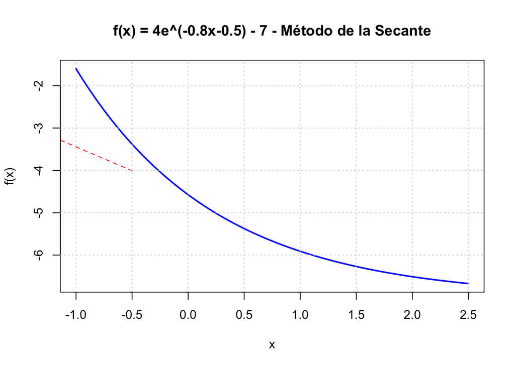

```r
x_plot <- seq(-1, 2.5, length.out = 500)
y_plot <- f8(x_plot)

plot(x_plot, y_plot, type = "l", main = "f(x) = 4e^(-0.8x-0.5) - 7 - Método de la Secante",
     xlab = "x", ylab = "f(x)", lwd = 2, col = "blue")
abline(h = 0, lty = 2, col = "gray")

x0 <- 0
x1 <- 1.5
for(i in 1:min(3, nrow(resultado8$tabla))) {
  f_x0 <- f8(x0)
  f_x1 <- f8(x1)
  if(abs(f_x1 - f_x0) > 1e-15) {
    x2 <- x1 - f_x1 * (x1 - x0) / (f_x1 - f_x0)

    x_secante <- c(x0 - 0.5, x2 + 0.5)
    y_secante <- f_x0 + (f_x1 - f_x0) / (x1 - x0) * (x_secante - x0)

    lines(x_secante, y_secante, col = "red", lty = 2, alpha = 0.6)
    points(x2, 0, col = "red", pch = 19, cex = 1)

    x0 <- x1
    x1 <- x2
  }
}
points(resultado8$raiz, f8(resultado8$raiz), col = "green", pch = 19, cex = 1.5)
grid()
```

### Ecuación 9: f(x) = x² - 2, x₀ = 1, x₁ = 2

```r
f9 <- function(x) x^2 - 2
resultado9 <- secante(f9, 1, 2, tol = 1e-5, iter_max = 100)

cat("Raíz aproximada:", resultado9$raiz, "\n")
```

```
## Raíz aproximada: 1.333333
```

```r
cat("Iteraciones:", resultado9$iteraciones, "\n\n")
```

```
## Iteraciones: 1
```

```r
print(resultado9$tabla, digits = 8)
```

```
##   k xk_1 xk xk_1_nuevo f_xk_1 f_xk f_xk_1_nuevo      error
## 1 1    1  2  1.3333333     -1    2  -0.22222222 0.66666667
```

**Gráfico con secantes:**

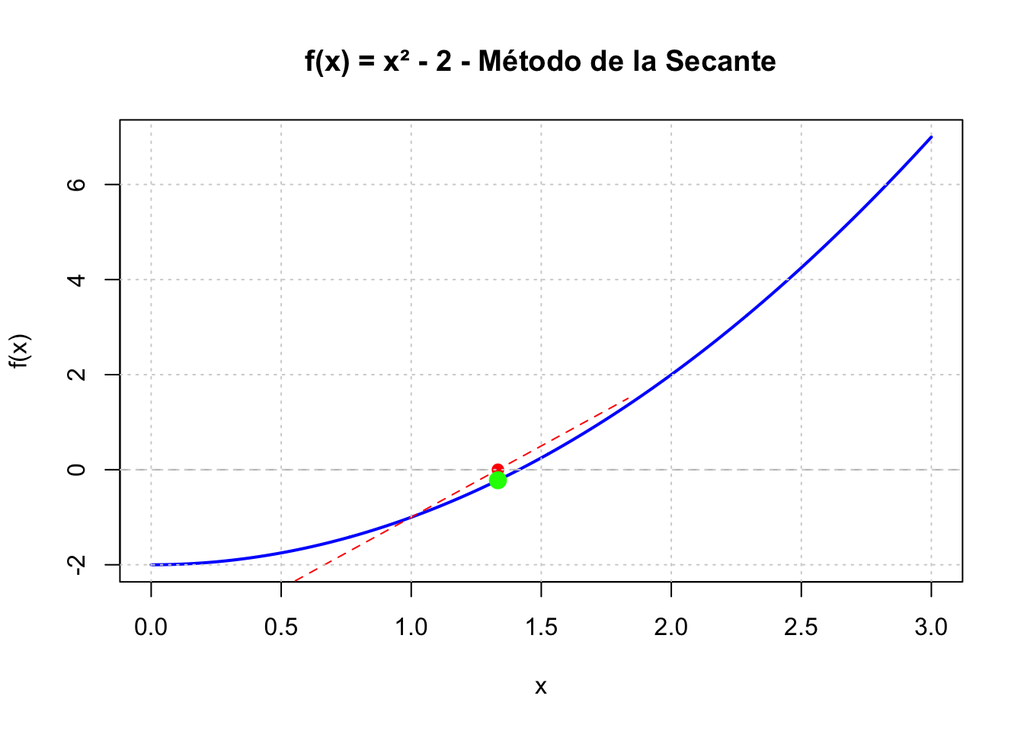

```r
x_plot <- seq(0, 3, length.out = 500)
y_plot <- f9(x_plot)

plot(x_plot, y_plot, type = "l", main = "f(x) = x² - 2 - Método de la Secante",
     xlab = "x", ylab = "f(x)", lwd = 2, col = "blue")
abline(h = 0, lty = 2, col = "gray")

x0 <- 1
x1 <- 2
for(i in 1:min(3, nrow(resultado9$tabla))) {
  f_x0 <- f9(x0)
  f_x1 <- f9(x1)
  x2 <- x1 - f_x1 * (x1 - x0) / (f_x1 - f_x0)

  x_secante <- c(x0 - 0.5, x2 + 0.5)
  y_secante <- f_x0 + (f_x1 - f_x0) / (x1 - x0) * (x_secante - x0)

  lines(x_secante, y_secante, col = "red", lty = 2, alpha = 0.6)
  points(x2, 0, col = "red", pch = 19, cex = 1)

  x0 <- x1
  x1 <- x2
}
points(resultado9$raiz, f9(resultado9$raiz), col = "green", pch = 19, cex = 1.5)
grid()
```

## Función Principal del Método de Newton-Raphson

```r
newton <- function(f, df, x0, tol = 1e-6, iter_max = 100) {

  tabla <- data.frame(
    k = numeric(),
    xk = numeric(),
    f_xk = numeric(),
    df_xk = numeric(),
    error = numeric(),
    stringsAsFactors = FALSE
  )

  iter <- 0
  error <- 1

  while(error > tol && iter < iter_max) {
    f_x0 <- f(x0)
    df_x0 <- df(x0)

    if(abs(df_x0) < 1e-15) {
      cat("Error: derivada muy cerca de cero\n")
      break
    }

    x1 <- x0 - f_x0 / df_x0
    error <- abs(x1 - x0)

    tabla <- rbind(tabla, data.frame(
      k = iter + 1,
      xk = x0,
      f_xk = f_x0,
      df_xk = df_x0,
      error = error
    ))

    x0 <- x1
    iter <- iter + 1
  }

  return(list(raiz = x0, iteraciones = iter, tabla = tabla))
}

# Verificar cambio de signo
verificar_signo <- function(f, a, b) {
  return(f(a) * f(b) < 0)
}
```

### Ecuación 1: f(x) = x³ - 7x + 6, [a,b] = [0,1]

```r
f1 <- function(x) x^3 - 7*x + 6
df1 <- function(x) 3*x^2 - 7

# Verificar cambio de signo
cat("f(0) =", f1(0), ", f(1) =", f1(1), "\n")
```

```
## f(0) = 6 , f(1) = 0
```

```r
cat("Cambio de signo:", verificar_signo(f1, 0, 1), "\n\n")
```

```
## Cambio de signo: FALSE
```

```r
# Seleccionar x0 cercano a la raíz
x0 <- 0.5
resultado1 <- newton(f1, df1, x0, tol = 1e-6, iter_max = 100)

cat("Raíz aproximada:", resultado1$raiz, "\n")
```

```
## Raíz aproximada: 1
```

```r
cat("Iteraciones:", resultado1$iteraciones, "\n\n")
```

```
## Iteraciones: 5
```

```r
print(resultado1$tabla, digits = 8)
```

```
##   k         xk          f_xk      df_xk         error
## 1 1 0.50000000 2.6250000e+00 -6.2500000 4.2000000e-01
## 2 2 0.92000000 3.3868800e-01 -4.4608000 7.5925395e-02
## 3 3 0.99592539 1.6348161e-02 -4.0243978 4.0622628e-03
## 4 4 0.99998766 4.9371254e-05 -4.0000741 1.2342585e-05
## 5 5 1.00000000 4.5701487e-10 -4.0000000 1.1425372e-10
```

#### Gráfico

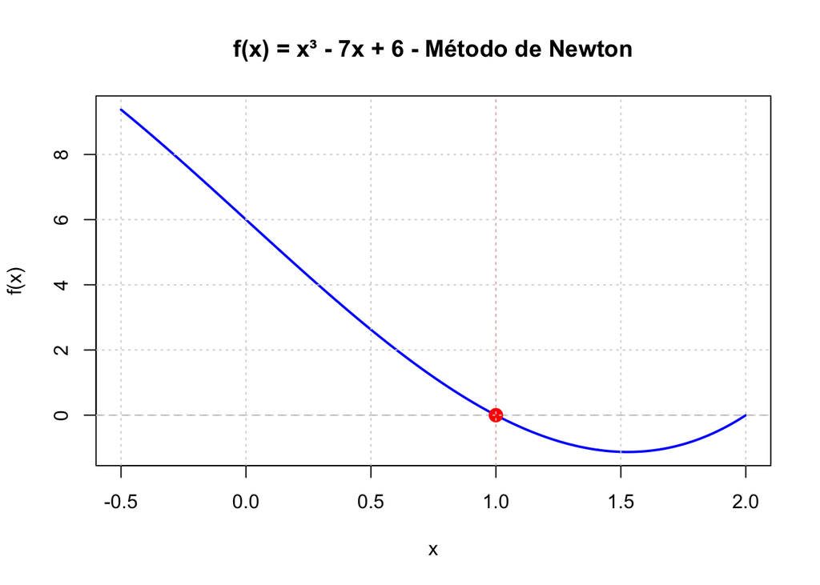

```r
x_plot <- seq(-0.5, 2, length.out = 500)
y_plot <- f1(x_plot)

plot(x_plot, y_plot, type = "l", main = "f(x) = x³ - 7x + 6 - Método de Newton",
     xlab = "x", ylab = "f(x)", lwd = 2, col = "blue")
abline(h = 0, lty = 2, col = "gray")
abline(v = resultado1$raiz, lty = 3, col = "red")
points(resultado1$raiz, f1(resultado1$raiz), col = "red", pch = 19, cex = 1.5)
grid()
```

### Ecuación 2: f(x) = x³ + 2x² - 5, [a,b] = [1,2]

```r
f2 <- function(x) x^3 + 2*x^2 - 5
df2 <- function(x) 3*x^2 + 4*x

# Verificar cambio de signo
cat("f(1) =", f2(1), ", f(2) =", f2(2), "\n")
```

```
## f(1) = -2 , f(2) = 11
```

```r
cat("Cambio de signo:", verificar_signo(f2, 1, 2), "\n\n")
```

```
## Cambio de signo: TRUE
```

```r
# Seleccionar x0 cercano a la raíz
x0 <- 1.5
resultado2 <- newton(f2, df2, x0, tol = 1e-6, iter_max = 100)

cat("Raíz aproximada:", resultado2$raiz, "\n")
```

```
## Raíz aproximada: 1.241897
```

```r
cat("Iteraciones:", resultado2$iteraciones, "\n\n")
```

```
## Iteraciones: 4
```

```r
print(resultado2$tabla, digits = 8)
```

```
##   k        xk          f_xk      df_xk         error
## 1 1 1.5000000 2.8750000e+00 12.7500000 2.2549020e-01
## 2 2 1.2745098 3.1903265e-01  9.9711649 3.1995524e-02
## 3 3 1.2425143 5.9288718e-03  9.6015823 6.1748904e-04
## 4 4 1.2418968 2.1836349e-06  9.5945101 2.2759212e-07
```

#### Gráfico

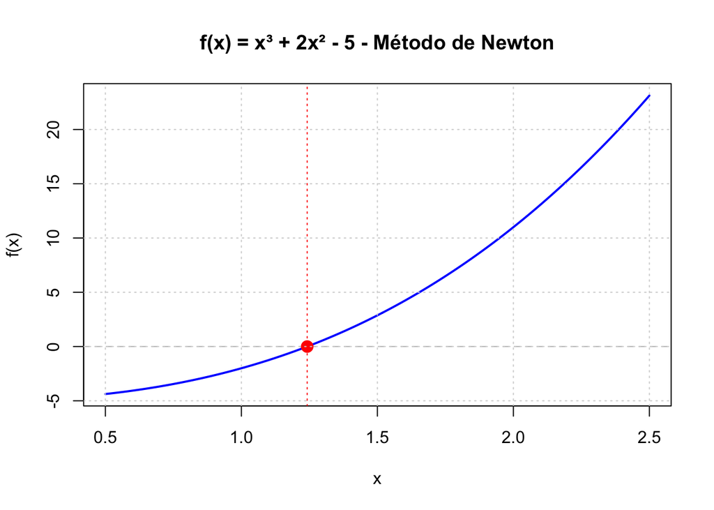

```r
x_plot <- seq(0.5, 2.5, length.out = 500)
y_plot <- f2(x_plot)

plot(x_plot, y_plot, type = "l", main = "f(x) = x³ + 2x² - 5 - Método de Newton",
     xlab = "x", ylab = "f(x)", lwd = 2, col = "blue")
abline(h = 0, lty = 2, col = "gray")
abline(v = resultado2$raiz, lty = 3, col = "red")
points(resultado2$raiz, f2(resultado2$raiz), col = "red", pch = 19, cex = 1.5)
grid()
```

### Ecuación 3: f(x) = x⁴ - 3x³ + 2, [a,b] = [0,1]

```r
f3 <- function(x) x^4 - 3*x^3 + 2
df3 <- function(x) 4*x^3 - 9*x^2

# Verificar cambio de signo
cat("f(0) =", f3(0), ", f(1) =", f3(1), "\n")
```

```
## f(0) = 2 , f(1) = 0
```

```r
cat("Cambio de signo:", verificar_signo(f3, 0, 1), "\n\n")
```

```
## Cambio de signo: FALSE
```

```r
# Seleccionar x0 cercano a la raíz
x0 <- 0.5
resultado3 <- newton(f3, df3, x0, tol = 1e-6, iter_max = 100)

cat("Raíz aproximada:", resultado3$raiz, "\n")
```

```
## Raíz aproximada: 1
```

```r
cat("Iteraciones:", resultado3$iteraciones, "\n\n")
```

```
## Iteraciones: 5
```

```r
print(resultado3$tabla, digits = 8)
```

```
##   k        xk           f_xk      df_xk         error
## 1 1 0.5000000  1.6875000e+00 -1.7500000 9.6428571e-01
## 2 2 1.4642857 -2.8215636e+00 -6.7387026 4.1871021e-01
## 3 3 1.0455755 -2.3400991e-01 -5.2668430 4.4430774e-02
## 4 4 1.0011447 -5.7275707e-03 -5.0068644 1.1439436e-03
## 5 5 1.0000008 -3.9228189e-06 -5.0000047 7.8456304e-07
```

#### Gráfico

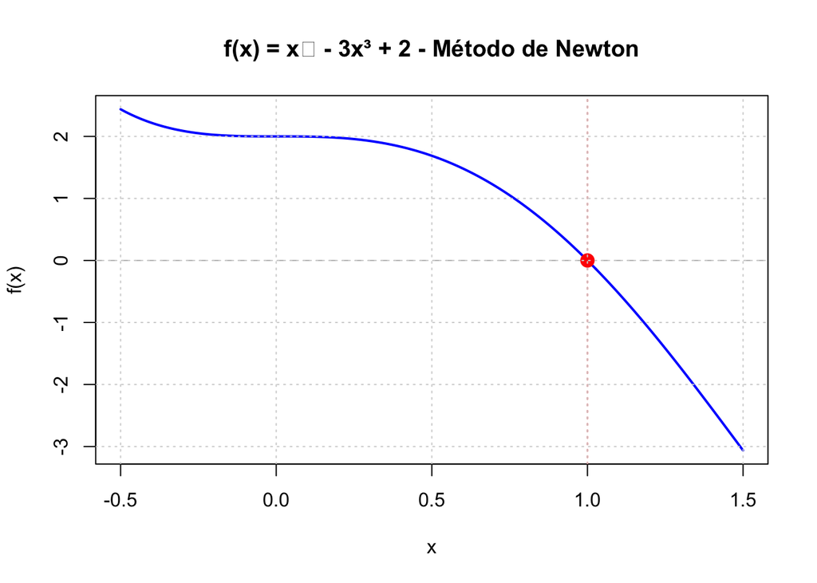

```r
x_plot <- seq(-0.5, 1.5, length.out = 500)
y_plot <- f3(x_plot)

plot(x_plot, y_plot, type = "l", main = "f(x) = x⁴ - 3x³ + 2 - Método de Newton",
     xlab = "x", ylab = "f(x)", lwd = 2, col = "blue")
abline(h = 0, lty = 2, col = "gray")
abline(v = resultado3$raiz, lty = 3, col = "red")
points(resultado3$raiz, f3(resultado3$raiz), col = "red", pch = 19, cex = 1.5)
grid()
```

### Ecuación 4: f(x) = sin(x) - x/3, [a,b] = [0,2]

```r
f4 <- function(x) sin(x) - x/3
df4 <- function(x) cos(x) - 1/3

# Verificar cambio de signo
cat("f(0) =", f4(0), ", f(2) =", f4(2), "\n")
```

```
## f(0) = 0 , f(2) = 0.2426308
```

```r
cat("Cambio de signo:", verificar_signo(f4, 0, 2), "\n\n")
```

```
## Cambio de signo: FALSE
```

```r
# Seleccionar x0 cercano a la raíz
x0 <- 1
resultado4 <- newton(f4, df4, x0, tol = 1e-6, iter_max = 100)

cat("Raíz aproximada:", resultado4$raiz, "\n")
```

```
## Raíz aproximada: -2.278863
```

```r
cat("Iteraciones:", resultado4$iteraciones, "\n\n")
```

```
## Iteraciones: 7
```

```r
print(resultado4$tabla, digits = 8)
```

```
##   k         xk           f_xk       df_xk         error
## 1 1  1.0000000  5.0813765e-01  0.20696897 2.4551393e+00
## 2 2 -1.4551393 -5.0827275e-01 -0.21793395 2.3322330e+00
## 3 3 -3.7873723  1.8642787e+00 -1.13196415 1.6469415e+00
## 4 4 -2.1404308 -1.2862121e-01 -0.87265763 1.4739024e-01
## 5 5 -2.2878211  8.8427769e-03 -0.99047827 8.9277848e-03
## 6 6 -2.2788933  3.0117255e-05 -0.98372272 3.0615594e-05
## 7 7 -2.2788627  3.5599557e-10 -0.98369947 3.6189451e-10
```

#### Gráfico

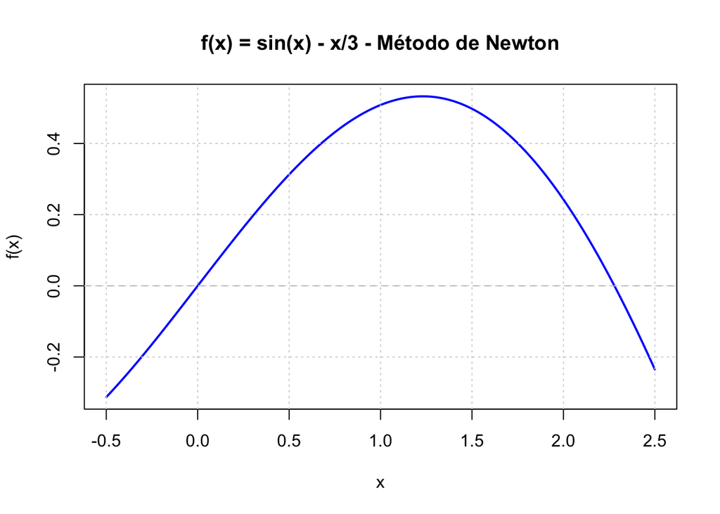

```r
x_plot <- seq(-0.5, 2.5, length.out = 500)
y_plot <- f4(x_plot)

plot(x_plot, y_plot, type = "l", main = "f(x) = sin(x) - x/3 - Método de Newton",
     xlab = "x", ylab = "f(x)", lwd = 2, col = "blue")
abline(h = 0, lty = 2, col = "gray")
abline(v = resultado4$raiz, lty = 3, col = "red")
points(resultado4$raiz, f4(resultado4$raiz), col = "red", pch = 19, cex = 1.5)
grid()
```

### Ecuación 5: f(x) = e^(-x) - x, [a,b] = [0,1]

```r
f5 <- function(x) exp(-x) - x
df5 <- function(x) -exp(-x) - 1

# Verificar cambio de signo
cat("f(0) =", f5(0), ", f(1) =", f5(1), "\n")
```

```
## f(0) = 1 , f(1) = -0.6321206
```

```r
cat("Cambio de signo:", verificar_signo(f5, 0, 1), "\n\n")
```

```
## Cambio de signo: TRUE
```

```r
# Seleccionar x0 cercano a la raíz
x0 <- 0.5
resultado5 <- newton(f5, df5, x0, tol = 1e-6, iter_max = 100)

cat("Raíz aproximada:", resultado5$raiz, "\n")
```

```
## Raíz aproximada: 0.5671433
```

```r
cat("Iteraciones:", resultado5$iteraciones, "\n\n")
```

```
## Iteraciones: 3
```

```r
print(resultado5$tabla, digits = 8)
```

```
##   k         xk          f_xk      df_xk         error
## 1 1 0.50000000 1.0653066e-01 -1.6065307 6.6311003e-02
## 2 2 0.56631100 1.3045098e-03 -1.5676155 8.3216184e-04
## 3 3 0.56714317 1.9648047e-07 -1.5671434 1.2537492e-07
```

#### Gráfico

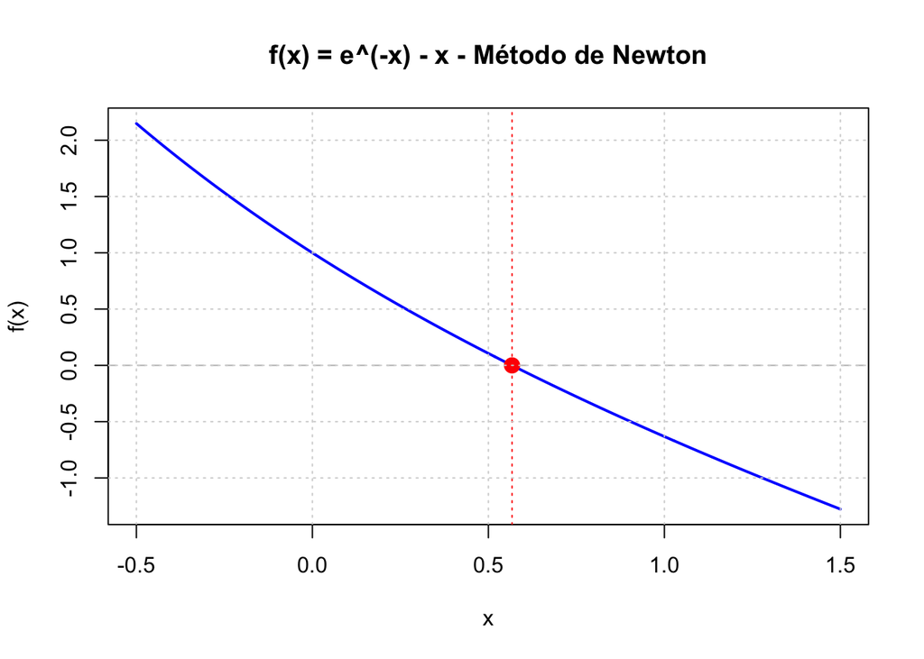

```r
x_plot <- seq(-0.5, 1.5, length.out = 500)
y_plot <- f5(x_plot)

plot(x_plot, y_plot, type = "l", main = "f(x) = e^(-x) - x - Método de Newton",
     xlab = "x", ylab = "f(x)", lwd = 2, col = "blue")
abline(h = 0, lty = 2, col = "gray")
abline(v = resultado5$raiz, lty = 3, col = "red")
points(resultado5$raiz, f5(resultado5$raiz), col = "red", pch = 19, cex = 1.5)
grid()
```

### Ecuación 6: f(x) = x³ - 2x - 5, [a,b] = [2,3]

```r
f6 <- function(x) x^3 - 2*x - 5
df6 <- function(x) 3*x^2 - 2

# Verificar cambio de signo
cat("f(2) =", f6(2), ", f(3) =", f6(3), "\n")
```

```
## f(2) = -1 , f(3) = 16
```

```r
cat("Cambio de signo:", verificar_signo(f6, 2, 3), "\n\n")
```

```
## Cambio de signo: TRUE
```

```r
# Seleccionar x0 cercano a la raíz
x0 <- 2.5
resultado6 <- newton(f6, df6, x0, tol = 1e-6, iter_max = 100)

cat("Raíz aproximada:", resultado6$raiz, "\n")
```

```
## Raíz aproximada: 2.094551
```

```r
cat("Iteraciones:", resultado6$iteraciones, "\n\n")
```

```
## Iteraciones: 5
```

```r
print(resultado6$tabla, digits = 8)
```

```
##   k        xk          f_xk     df_xk         error
## 1 1 2.5000000 5.6250000e+00 16.750000 3.3582090e-01
## 2 2 2.1641791 8.0794513e-01 12.051014 6.7043749e-02
## 3 3 2.0971354 2.8881721e-02 11.193930 2.5801234e-03
## 4 4 2.0945552 4.1864946e-05 11.161485 3.7508402e-06
## 5 5 2.0945515 8.8402174e-11 11.161438 7.9203311e-12
```

**Gráfico:**

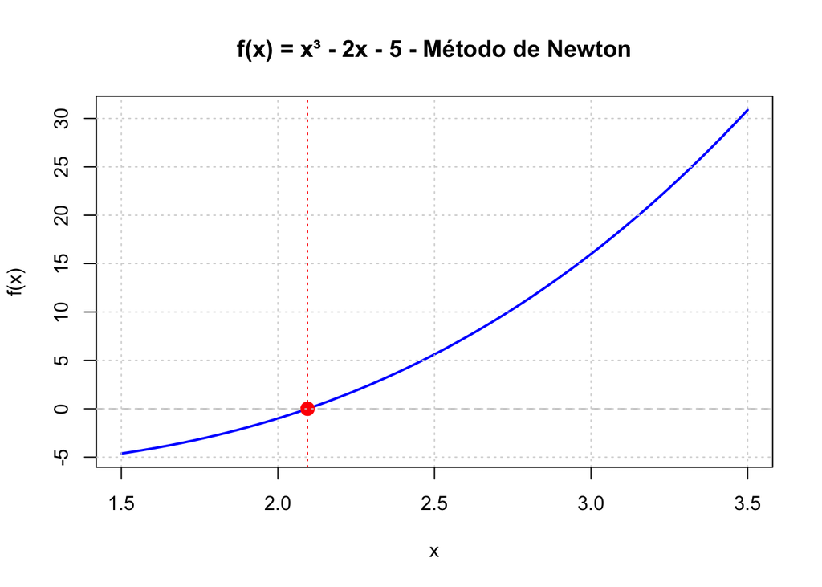

```r
x_plot <- seq(1.5, 3.5, length.out = 500)
y_plot <- f6(x_plot)

plot(x_plot, y_plot, type = "l", main = "f(x) = x³ - 2x - 5 - Método de Newton",
     xlab = "x", ylab = "f(x)", lwd = 2, col = "blue")
abline(h = 0, lty = 2, col = "gray")
abline(v = resultado6$raiz, lty = 3, col = "red")
points(resultado6$raiz, f6(resultado6$raiz), col = "red", pch = 19, cex = 1.5)
grid()
```

### Ecuación 7: f(x) = x⁵ - 3x + 1, [a,b] = [0,1]

```r
f7 <- function(x) x^5 - 3*x + 1
df7 <- function(x) 5*x^4 - 3

# Verificar cambio de signo
cat("f(0) =", f7(0), ", f(1) =", f7(1), "\n")
```

```
## f(0) = 1 , f(1) = -1
```

```r
cat("Cambio de signo:", verificar_signo(f7, 0, 1), "\n\n")
```

```
## Cambio de signo: TRUE
```

```r
# Seleccionar x0 cercano a la raíz
x0 <- 0.5
resultado7 <- newton(f7, df7, x0, tol = 1e-6, iter_max = 100)

cat("Raíz aproximada:", resultado7$raiz, "\n")
```

```
## Raíz aproximada: 0.3347341
```

```r
cat("Iteraciones:", resultado7$iteraciones, "\n\n")
```

```
## Iteraciones: 4
```

```r
print(resultado7$tabla, digits = 8)
```

```
##   k         xk          f_xk      df_xk         error
## 1 1 0.50000000 -4.687500e-01 -2.6875000 1.7441860e-01
## 2 2 0.32558140  2.691427e-02 -2.9438166 9.1426453e-03
## 3 3 0.33472404  2.966998e-05 -2.9372350 1.0101330e-05
## 4 4 0.33473414  3.826750e-11 -2.9372274 1.3028467e-11
```

#### Gráfico

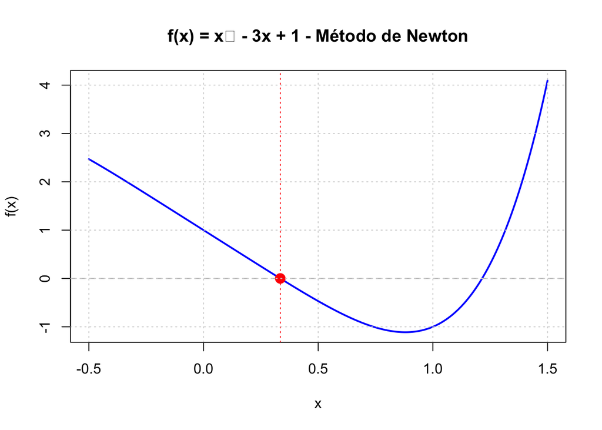

```r
x_plot <- seq(-0.5, 1.5, length.out = 500)
y_plot <- f7(x_plot)

plot(x_plot, y_plot, type = "l", main = "f(x) = x⁵ - 3x + 1 - Método de Newton",
     xlab = "x", ylab = "f(x)", lwd = 2, col = "blue")
abline(h = 0, lty = 2, col = "gray")
abline(v = resultado7$raiz, lty = 3, col = "red")
points(resultado7$raiz, f7(resultado7$raiz), col = "red", pch = 19, cex = 1.5)
grid()
```

### Ecuación 8: f(x) = cos(x) - 2x, [a,b] = [0,1]

```r
f8 <- function(x) cos(x) - 2*x
df8 <- function(x) -sin(x) - 2

# Verificar cambio de signo
cat("f(0) =", f8(0), ", f(1) =", f8(1), "\n")
```

```
## f(0) = 1 , f(1) = -1.459698
```

```r
cat("Cambio de signo:", verificar_signo(f8, 0, 1), "\n\n")
```

```
## Cambio de signo: TRUE
```

```r
# Seleccionar x0 cercano a la raíz
x0 <- 0.5
resultado8 <- newton(f8, df8, x0, tol = 1e-6, iter_max = 100)

cat("Raíz aproximada:", resultado8$raiz, "\n")
```

```
## Raíz aproximada: 0.4501836
```

```r
cat("Iteraciones:", resultado8$iteraciones, "\n\n")
```

```
## Iteraciones: 3
```

```r
print(resultado8$tabla, digits = 8)
```

```
##   k         xk           f_xk      df_xk         error
## 1 1 0.50000000 -1.2241744e-01 -2.4794255 4.9373307e-02
## 2 2 0.45062669 -1.0790505e-03 -2.4355298 4.4304550e-04
## 3 3 0.45018365 -8.8353613e-08 -2.4351309 3.6282901e-08
```

**Gráfico:**

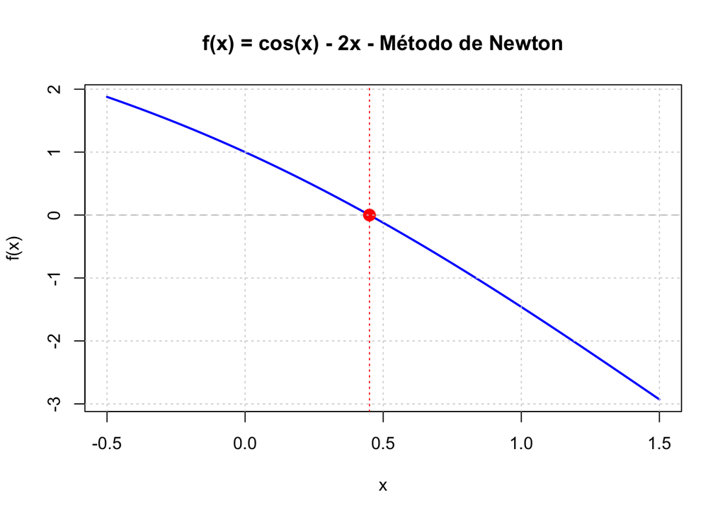

```r
x_plot <- seq(-0.5, 1.5, length.out = 500)
y_plot <- f8(x_plot)

plot(x_plot, y_plot, type = "l", main = "f(x) = cos(x) - 2x - Método de Newton",
     xlab = "x", ylab = "f(x)", lwd = 2, col = "blue")
abline(h = 0, lty = 2, col = "gray")
abline(v = resultado8$raiz, lty = 3, col = "red")
points(resultado8$raiz, f8(resultado8$raiz), col = "red", pch = 19, cex = 1.5)
grid()
```

### Ecuación 9: f(x) = ln(x+2) + x - 1, [a,b] = [-1,0]

```r
f9 <- function(x) log(x + 2) + x - 1
df9 <- function(x) 1/(x + 2) + 1

# Verificar cambio de signo
cat("f(-1) =", f9(-1), ", f(0) =", f9(0), "\n")
```

```
## f(-1) = -2 , f(0) = -0.3068528
```

```r
cat("Cambio de signo:", verificar_signo(f9, -1, 0), "\n\n")
```

```
## Cambio de signo: FALSE
```

```r
# Seleccionar x0 cercano a la raíz
x0 <- -0.5
resultado9 <- newton(f9, df9, x0, tol = 1e-6, iter_max = 100)

cat("Raíz aproximada:", resultado9$raiz, "\n")
```

```
## Raíz aproximada: 0.20794
```

```r
cat("Iteraciones:", resultado9$iteraciones, "\n\n")
```

```
## Iteraciones: 4
```

```r
print(resultado9$tabla, digits = 8)
```

```
##   k          xk           f_xk     df_xk         error
## 1 1 -0.50000000 -1.0945349e+00 1.6666667 6.5672094e-01
## 2 2  0.15672094 -7.4690082e-02 1.4636668 5.1029428e-02
## 3 3  0.20775036 -2.7557489e-04 1.4529498 1.8966581e-04
## 4 4  0.20794003 -3.6899739e-09 1.4529109 2.5397111e-09
```

#### Gráfico

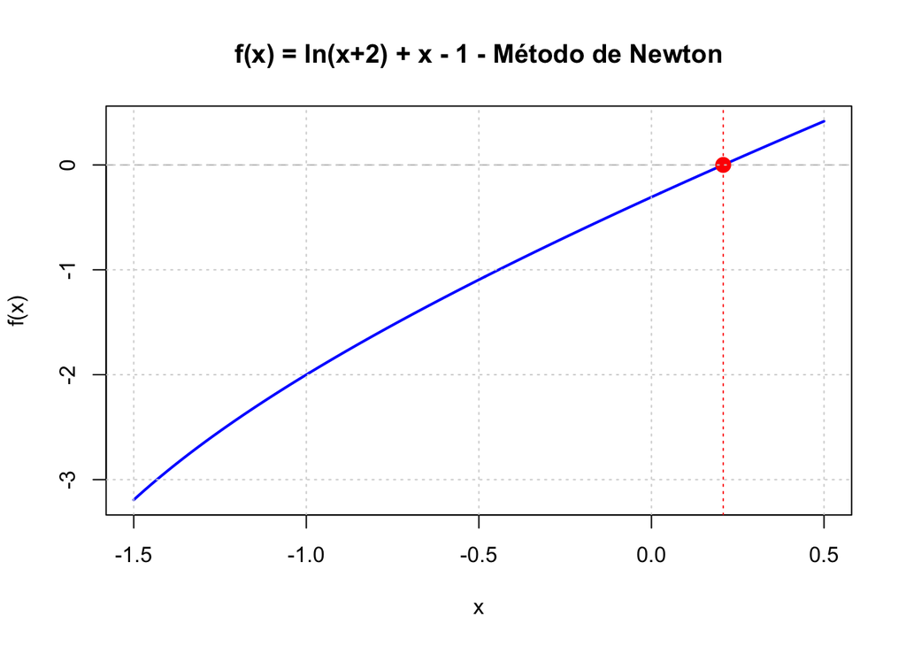

```r
x_plot <- seq(-1.5, 0.5, length.out = 500)
y_plot <- f9(x_plot)

plot(x_plot, y_plot, type = "l", main = "f(x) = ln(x+2) + x - 1 - Método de Newton",
     xlab = "x", ylab = "f(x)", lwd = 2, col = "blue")
abline(h = 0, lty = 2, col = "gray")
abline(v = resultado9$raiz, lty = 3, col = "red")
points(resultado9$raiz, f9(resultado9$raiz), col = "red", pch = 19, cex = 1.5)
grid()
```

### Ecuación 10: f(x) = xe^(-x) - 0.1, [a,b] = [0,1]

```r
f10 <- function(x) x*exp(-x) - 0.1
df10 <- function(x) exp(-x) - x*exp(-x)

# Verificar cambio de signo
cat("f(0) =", f10(0), ", f(1) =", f10(1), "\n")
```

```
## f(0) = -0.1 , f(1) = 0.2678794
```

```r
cat("Cambio de signo:", verificar_signo(f10, 0, 1), "\n\n")
```

```
## Cambio de signo: TRUE
```

```r
# Seleccionar x0 cercano a la raíz
x0 <- 0.5
resultado10 <- newton(f10, df10, x0, tol = 1e-6, iter_max = 100)

cat("Raíz aproximada:", resultado10$raiz, "\n")
```

```
## Raíz aproximada: 0.1118326
```

```r
cat("Iteraciones:", resultado10$iteraciones, "\n\n")
```

```
## Iteraciones: 6
```

```r
print(resultado10$tabla, digits = 8)
```

```
##   k           xk           f_xk      df_xk         error
## 1 1  0.500000000  2.0326533e-01 0.30326533 6.7025575e-01
## 2 2 -0.170255746 -3.0185658e-01 1.38746461 2.1755984e-01
## 3 3  0.047304095 -5.4881481e-02 0.90867879 6.0397009e-02
## 4 4  0.107701105 -3.2956162e-03 0.80119155 4.1133937e-03
## 5 5  0.111814498 -1.4344204e-05 0.79422446 1.8060642e-05
## 6 6  0.111832559 -2.7537000e-10 0.79419397 3.4672891e-10
```

#### Gráfico

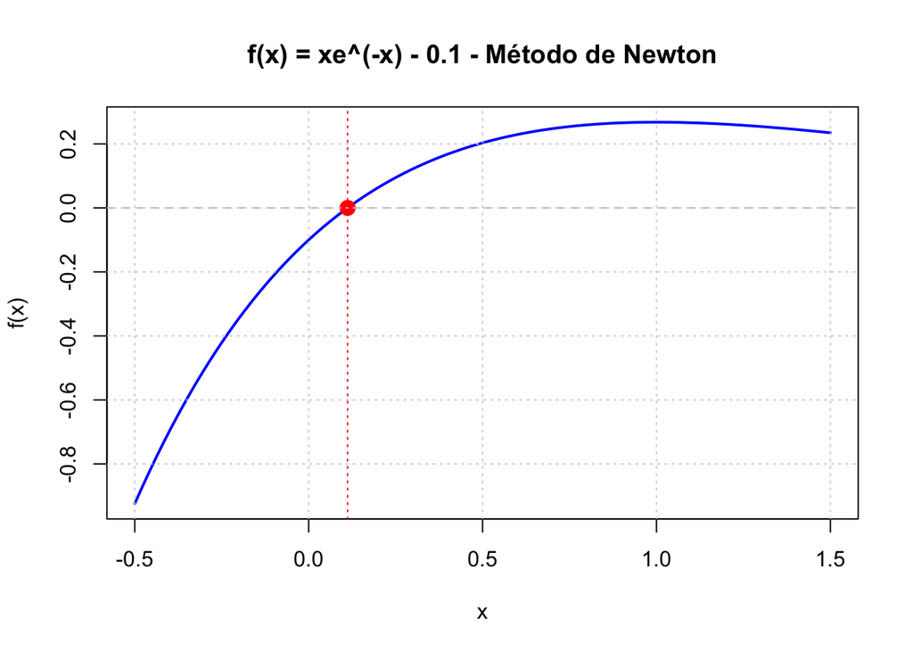

```r
x_plot <- seq(-0.5, 1.5, length.out = 500)
y_plot <- f10(x_plot)

plot(x_plot, y_plot, type = "l", main = "f(x) = xe^(-x) - 0.1 - Método de Newton",
     xlab = "x", ylab = "f(x)", lwd = 2, col = "blue")
abline(h = 0, lty = 2, col = "gray")
abline(v = resultado10$raiz, lty = 3, col = "red")
points(resultado10$raiz, f10(resultado10$raiz), col = "red", pch = 19, cex = 1.5)
grid()
```

## Función Principal del Método del Punto Fijo

```r
punto_fijo <- function(g, dg, x0, tol = 1e-6, iter_max = 100) {

  tabla <- data.frame(
    k = numeric(),
    xk = numeric(),
    g_xk = numeric(),
    dg_xk = numeric(),
    error = numeric(),
    stringsAsFactors = FALSE
  )

  iter <- 0
  error <- 1

  while(iter < iter_max && error > tol) {
    x1 <- g(x0)

    if(is.na(x1) || is.infinite(x1)) {
      cat("Error: g(x0) no válido en iteración", iter + 1, "\n")
      break
    }

    dg_x0 <- dg(x0)

    if(is.na(dg_x0) || is.infinite(dg_x0)) {
      dg_x0 <- NA
    }

    error <- abs(x1 - x0)

    tabla <- rbind(tabla, data.frame(
      k = iter + 1,
      xk = x0,
      g_xk = x1,
      dg_xk = dg_x0,
      error = error
    ))

    x0 <- x1
    iter <- iter + 1
  }

  return(list(raiz = x0, iteraciones = iter, tabla = tabla))
}

# Función auxiliar para verificar convergencia
verificar_convergencia_simple <- function(dg, a, b, puntos = 10) {
  x_test <- seq(a, b, length.out = puntos)
  derivadas <- sapply(x_test, function(x) {
    val <- dg(x)
    if(is.na(val) || is.infinite(val)) return(NA)
    return(abs(val))
  })

  derivadas <- derivadas[!is.na(derivadas)]
  if(length(derivadas) == 0) return(list(converge = FALSE, max_deriv = NA))

  max_deriv <- max(derivadas)
  converge <- max_deriv < 1
  return(list(converge = converge, max_deriv = max_deriv))
}
```

### Ecuación 1: f(x) = cos(x) - x, g(x) = cos(x), x₀ = 0.5

```r
g1 <- function(x) cos(x)
dg1 <- function(x) -sin(x)

convg1 <- verificar_convergencia_simple(dg1, 0, 1)
cat("Convergencia: |g'(x)| < 1\n")
```

```
## Convergencia: |g'(x)| < 1
```

```r
cat("Máx |g'(x)| =", round(convg1$max_deriv, 6), "\n")
```

```
## Máx |g'(x)| = 0.841471
```

```r
cat("¿Converge?:", convg1$converge, "\n\n")
```

```
## ¿Converge?: TRUE
```

```r
resultado1 <- punto_fijo(g1, dg1, 0.5, tol = 1e-6, iter_max = 100)

cat("Raíz aproximada:", resultado1$raiz, "\n")
```

```
## Raíz aproximada: 0.7390848
```

```r
cat("Iteraciones:", resultado1$iteraciones, "\n\n")
```

```
## Iteraciones: 34
```

```r
print(resultado1$tabla, digits = 8)
```

```
##     k         xk       g_xk       dg_xk         error
## 1   1 0.50000000 0.87758256 -0.47942554 3.7758256e-01
## 2   2 0.87758256 0.63901249 -0.76919635 2.3857007e-01
## 3   3 0.63901249 0.80268510 -0.59640308 1.6367261e-01
## 4   4 0.80268510 0.69477803 -0.71922423 1.0790707e-01
## 5   5 0.69477803 0.76819583 -0.64021494 7.3417804e-02
## 6   6 0.76819583 0.71916545 -0.69483887 4.9030385e-02
## 7   7 0.71916545 0.75235576 -0.65875702 3.3190313e-02
## 8   8 0.75235576 0.73008106 -0.68336055 2.2274696e-02
## 9   9 0.73008106 0.74512034 -0.66693004 1.5039278e-02
## 10 10 0.74512034 0.73500631 -0.67806027 1.0114032e-02
## 11 11 0.73500631 0.74182652 -0.67059184 6.8202136e-03
## 12 12 0.74182652 0.73723573 -0.67563562 4.5907972e-03
## 13 13 0.73723573 0.74032965 -0.67224401 3.0939264e-03
## 14 14 0.74032965 0.73824624 -0.67453131 2.0834135e-03
```

[output cut: 20 more lines]

#### Gráfico

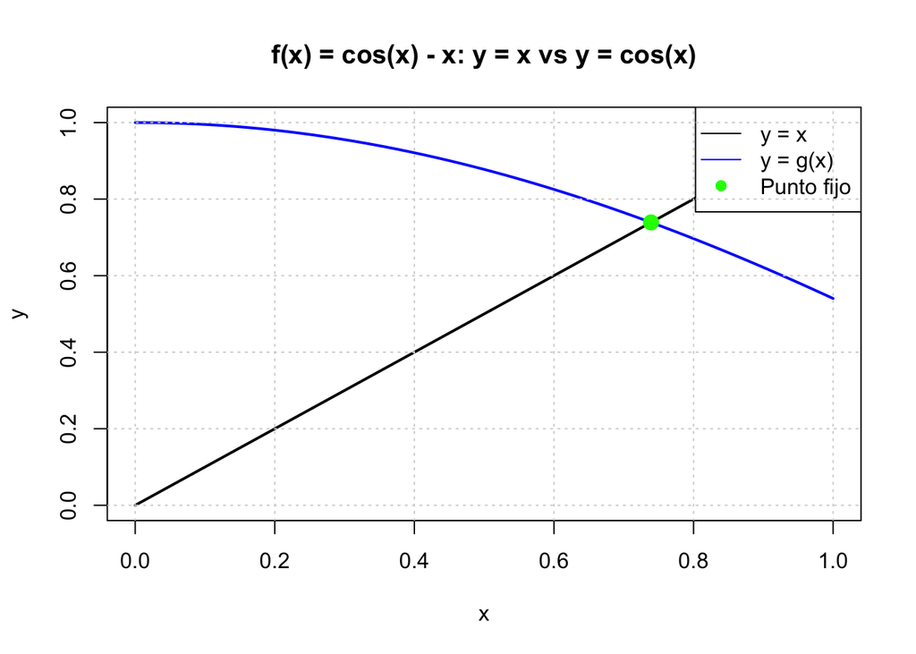

```r
x_plot <- seq(0, 1, length.out = 500)
y_g <- cos(x_plot)
y_x <- x_plot

plot(x_plot, y_x, type = "l", main = "f(x) = cos(x) - x: y = x vs y = cos(x)",
     xlab = "x", ylab = "y", lwd = 2, col = "black", ylim = c(0, 1))
lines(x_plot, y_g, col = "blue", lwd = 2)
points(resultado1$raiz, resultado1$raiz, col = "green", pch = 19, cex = 1.5)
legend("topright", c("y = x", "y = g(x)", "Punto fijo"),
       col = c("black", "blue", "green"), lty = c(1, 1, NA), pch = c(NA, NA, 19))
grid()
```

### Ecuación 2: f(x) = x³ + x - 1, g(x) = 1 - x³, x₀ = 0.6

```r
g2 <- function(x) 1 - x^3
dg2 <- function(x) -3*x^2

convg2 <- verificar_convergencia_simple(dg2, 0, 1)
cat("Convergencia: |g'(x)| < 1\n")
```

```
## Convergencia: |g'(x)| < 1
```

```r
cat("Máx |g'(x)| =", round(convg2$max_deriv, 6), "\n")
```

```
## Máx |g'(x)| = 3
```

```r
cat("¿Converge?:", convg2$converge, "\n\n")
```

```
## ¿Converge?: FALSE
```

```r
resultado2 <- punto_fijo(g2, dg2, 0.6, tol = 1e-6, iter_max = 100)

cat("Raíz aproximada:", resultado2$raiz, "\n")
```

```
## Raíz aproximada: 0
```

```r
cat("Iteraciones:", resultado2$iteraciones, "\n\n")
```

```
## Iteraciones: 100
```

```r
print(resultado2$tabla, digits = 8)
```

```
##       k            xk          g_xk          dg_xk      error
## 1     1 6.0000000e-01 7.8400000e-01 -1.0800000e+00 0.18400000
## 2     2 7.8400000e-01 5.1810970e-01 -1.8439680e+00 0.26589030
## 3     3 5.1810970e-01 8.6091985e-01 -8.0531297e-01 0.34281015
## 4     4 8.6091985e-01 3.6190086e-01 -2.2235489e+00 0.49901899
## 5     5 3.6190086e-01 9.5260104e-01 -3.9291670e-01 0.59070018
## 6     6 9.5260104e-01 1.3556339e-01 -2.7223462e+00 0.81703764
## 7     7 1.3556339e-01 9.9750869e-01 -5.5132302e-02 0.86194530
## 8     8 9.9750869e-01 7.4553176e-03 -2.9850708e+00 0.99005338
## 9     9 7.4553176e-03 9.9999959e-01 -1.6674528e-04 0.99254427
## 10   10 9.9999959e-01 1.2431385e-06 -2.9999975e+00 0.99999834
## 11   11 1.2431385e-06 1.0000000e+00 -4.6361800e-12 0.99999876
## 12   12 1.0000000e+00 0.0000000e+00 -3.0000000e+00 1.00000000
## 13   13 0.0000000e+00 1.0000000e+00  0.0000000e+00 1.00000000
## 14   14 1.0000000e+00 0.0000000e+00 -3.0000000e+00 1.00000000
```

[output cut: 86 more lines]

#### Gráfico

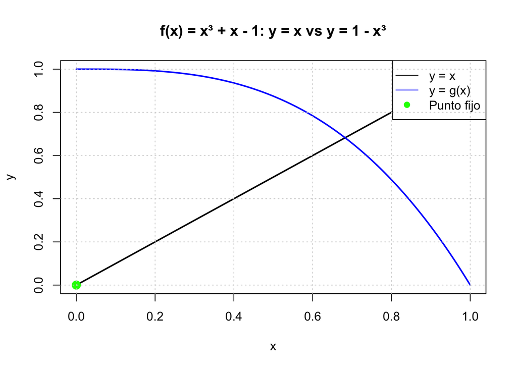

```r
x_plot <- seq(0, 1, length.out = 500)
y_g <- 1 - x_plot^3
y_x <- x_plot

plot(x_plot, y_x, type = "l", main = "f(x) = x³ + x - 1: y = x vs y = 1 - x³",
     xlab = "x", ylab = "y", lwd = 2, col = "black", ylim = c(0, 1))
lines(x_plot, y_g, col = "blue", lwd = 2)
points(resultado2$raiz, resultado2$raiz, col = "green", pch = 19, cex = 1.5)
legend("topright", c("y = x", "y = g(x)", "Punto fijo"),
       col = c("black", "blue", "green"), lty = c(1, 1, NA), pch = c(NA, NA, 19))
grid()
```

### Ecuación 3: f(x) = e^(-x) - x, g(x) = e^(-x), x₀ = 0.7

```r
g3 <- function(x) exp(-x)
dg3 <- function(x) -exp(-x)

convg3 <- verificar_convergencia_simple(dg3, 0, 1)
cat("Convergencia: |g'(x)| < 1\n")
```

```
## Convergencia: |g'(x)| < 1
```

```r
cat("Máx |g'(x)| =", round(convg3$max_deriv, 6), "\n")
```

```
## Máx |g'(x)| = 1
```

```r
cat("¿Converge?:", convg3$converge, "\n\n")
```

```
## ¿Converge?: FALSE
```

```r
resultado3 <- punto_fijo(g3, dg3, 0.7, tol = 1e-6, iter_max = 100)

cat("Raíz aproximada:", resultado3$raiz, "\n")
```

```
## Raíz aproximada: 0.567143
```

```r
cat("Iteraciones:", resultado3$iteraciones, "\n\n")
```

```
## Iteraciones: 23
```

```r
print(resultado3$tabla, digits = 8)
```

```
##     k         xk       g_xk       dg_xk         error
## 1   1 0.70000000 0.49658530 -0.49658530 2.0341470e-01
## 2   2 0.49658530 0.60860532 -0.60860532 1.1202001e-01
## 3   3 0.60860532 0.54410920 -0.54410920 6.4496118e-02
## 4   4 0.54410920 0.58035854 -0.58035854 3.6249337e-02
## 5   5 0.58035854 0.55969766 -0.55969766 2.0660878e-02
## 6   6 0.55969766 0.57138179 -0.57138179 1.1684132e-02
## 7   7 0.57138179 0.56474454 -0.56474454 6.6372494e-03
## 8   8 0.56474454 0.56850536 -0.56850536 3.7608173e-03
## 9   9 0.56850536 0.56637133 -0.56637133 2.1340294e-03
## 10 10 0.56637133 0.56758127 -0.56758127 1.2099437e-03
## 11 11 0.56758127 0.56689495 -0.56689495 6.8632607e-04
## 12 12 0.56689495 0.56728415 -0.56728415 3.8920832e-04
## 13 13 0.56728415 0.56706341 -0.56706341 2.2074875e-04
## 14 14 0.56706341 0.56718860 -0.56718860 1.2519236e-04
## 15 15 0.56718860 0.56711759 -0.56711759 7.1003233e-05
## 16 16 0.56711759 0.56715786 -0.56715786 4.0268612e-05
## 17 17 0.56715786 0.56713503 -0.56713503 2.2838200e-05
## 18 18 0.56713503 0.56714798 -0.56714798 1.2952491e-05
## 19 19 0.56714798 0.56714063 -0.56714063 7.3459317e-06
## 20 20 0.56714063 0.56714480 -0.56714480 4.1661916e-06
## 21 21 0.56714480 0.56714244 -0.56714244 2.3628290e-06
## 22 22 0.56714244 0.56714378 -0.56714378 1.3400622e-06
## 23 23 0.56714378 0.56714302 -0.56714302 7.6000741e-07
```

#### Gráfico

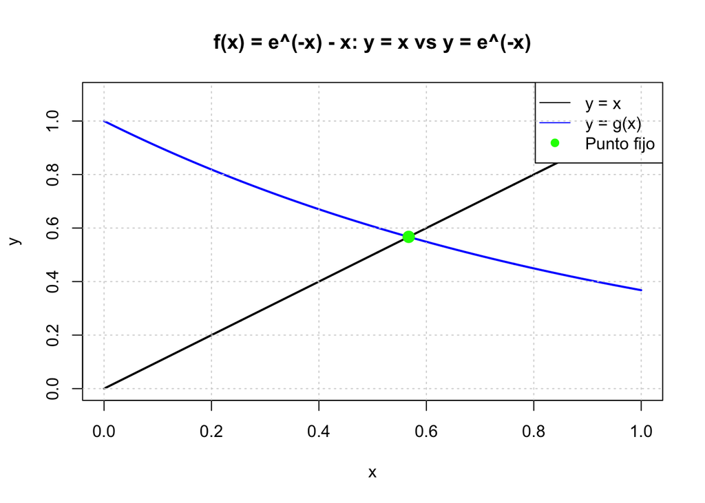

```r
x_plot <- seq(0, 1, length.out = 500)
y_g <- exp(-x_plot)
y_x <- x_plot

plot(x_plot, y_x, type = "l", main = "f(x) = e^(-x) - x: y = x vs y = e^(-x)",
     xlab = "x", ylab = "y", lwd = 2, col = "black", ylim = c(0, 1.1))
lines(x_plot, y_g, col = "blue", lwd = 2)
points(resultado3$raiz, resultado3$raiz, col = "green", pch = 19, cex = 1.5)
legend("topright", c("y = x", "y = g(x)", "Punto fijo"),
       col = c("black", "blue", "green"), lty = c(1, 1, NA), pch = c(NA, NA, 19))
grid()
```

### Ecuación 4: f(x) = x² - 4x + 1, g(x) = (x² + 1)/4, x₀ = 1

```r
g4 <- function(x) (x^2 + 1)/4
dg4 <- function(x) x/2

convg4 <- verificar_convergencia_simple(dg4, 0.5, 1.5)
cat("Convergencia: |g'(x)| < 1\n")
```

```
## Convergencia: |g'(x)| < 1
```

```r
cat("Máx |g'(x)| =", round(convg4$max_deriv, 6), "\n")
```

```
## Máx |g'(x)| = 0.75
```

```r
cat("¿Converge?:", convg4$converge, "\n\n")
```

```
## ¿Converge?: TRUE
```

```r
resultado4 <- punto_fijo(g4, dg4, 1, tol = 1e-6, iter_max = 100)

cat("Raíz aproximada:", resultado4$raiz, "\n")
```

```
## Raíz aproximada: 0.2679492
```

```r
cat("Iteraciones:", resultado4$iteraciones, "\n\n")
```

```
## Iteraciones: 9
```

```r
print(resultado4$tabla, digits = 8)
```

```
##   k         xk       g_xk      dg_xk         error
## 1 1 1.00000000 0.50000000 0.50000000 5.0000000e-01
## 2 2 0.50000000 0.31250000 0.25000000 1.8750000e-01
## 3 3 0.31250000 0.27441406 0.15625000 3.8085938e-02
## 4 4 0.27441406 0.26882577 0.13720703 5.5882931e-03
## 5 5 0.26882577 0.26806682 0.13441288 7.5894585e-04
## 6 6 0.26806682 0.26796496 0.13403341 1.0186810e-04
## 7 7 0.26796496 0.26795130 0.13398248 1.3651135e-05
## 8 8 0.26795130 0.26794948 0.13397565 1.8289663e-06
## 9 9 0.26794948 0.26794923 0.13397474 2.4503611e-07
```

#### Gráfico

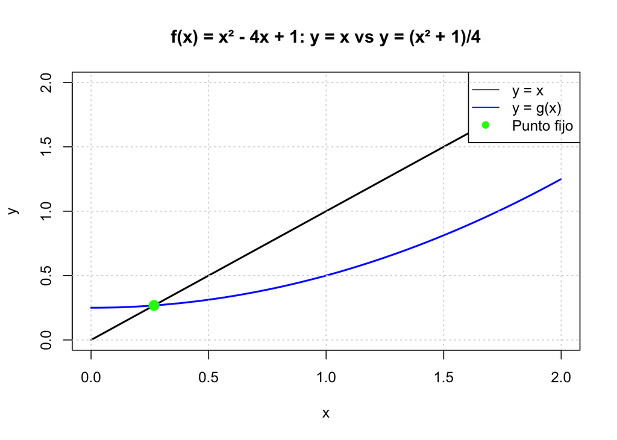

```r
x_plot <- seq(0, 2, length.out = 500)
y_g <- (x_plot^2 + 1)/4
y_x <- x_plot

plot(x_plot, y_x, type = "l", main = "f(x) = x² - 4x + 1: y = x vs y = (x² + 1)/4",
     xlab = "x", ylab = "y", lwd = 2, col = "black", ylim = c(0, 2))
lines(x_plot, y_g, col = "blue", lwd = 2)
points(resultado4$raiz, resultado4$raiz, col = "green", pch = 19, cex = 1.5)
legend("topright", c("y = x", "y = g(x)", "Punto fijo"),
       col = c("black", "blue", "green"), lty = c(1, 1, NA), pch = c(NA, NA, 19))
grid()
```

### Ecuación 5: f(x) = x³ - 2x - 5, g(x) = ³√(2x + 5), x₀ = 2

```r
g5 <- function(x) (2*x + 5)^(1/3)
dg5 <- function(x) (2/3) * (2*x + 5)^(-2/3)

convg5 <- verificar_convergencia_simple(dg5, 1.5, 2.5)
cat("Convergencia: |g'(x)| < 1\n")
```

```
## Convergencia: |g'(x)| < 1
```

```r
cat("Máx |g'(x)| =", round(convg5$max_deriv, 6), "\n")
```

```
## Máx |g'(x)| = 0.166667
```

```r
cat("¿Converge?:", convg5$converge, "\n\n")
```

```
## ¿Converge?: TRUE
```

```r
resultado5 <- punto_fijo(g5, dg5, 2, tol = 1e-6, iter_max = 100)

cat("Raíz aproximada:", resultado5$raiz, "\n")
```

```
## Raíz aproximada: 2.094551
```

```r
cat("Iteraciones:", resultado5$iteraciones, "\n\n")
```

```
## Iteraciones: 7
```

```r
print(resultado5$tabla, digits = 8)
```

```
##   k        xk      g_xk      dg_xk         error
## 1 1 2.0000000 2.0800838 0.15408028 8.0083823e-02
## 2 2 2.0800838 2.0923507 0.15227892 1.2266855e-02
## 3 3 2.0923507 2.0942170 0.15200763 1.8663182e-03
## 4 4 2.0942170 2.0945007 0.15196646 2.8365618e-04
## 5 5 2.0945007 2.0945438 0.15196020 4.3105338e-05
## 6 6 2.0945438 2.0945503 0.15195925 6.5502755e-06
## 7 7 2.0945503 2.0945513 0.15195911 9.9537449e-07
```

#### Gráfico

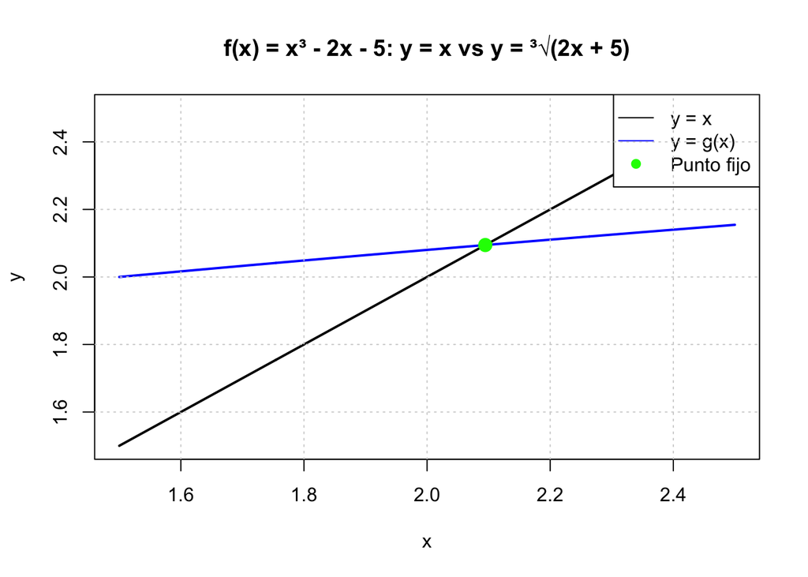

```r
x_plot <- seq(1.5, 2.5, length.out = 500)
y_g <- (2*x_plot + 5)^(1/3)
y_x <- x_plot

plot(x_plot, y_x, type = "l", main = "f(x) = x³ - 2x - 5: y = x vs y = ³√(2x + 5)",
     xlab = "x", ylab = "y", lwd = 2, col = "black", ylim = c(1.5, 2.5))
lines(x_plot, y_g, col = "blue", lwd = 2)
points(resultado5$raiz, resultado5$raiz, col = "green", pch = 19, cex = 1.5)
legend("topright", c("y = x", "y = g(x)", "Punto fijo"),
       col = c("black", "blue", "green"), lty = c(1, 1, NA), pch = c(NA, NA, 19))
grid()
```

### Ecuación 6: f(x) = x² - 3, g(x) = 3/x, x₀ = 1.5

```r
g6 <- function(x) 3/x
dg6 <- function(x) -3/(x^2)

convg6 <- verificar_convergencia_simple(dg6, 1, 2)
cat("Convergencia: |g'(x)| < 1\n")
```

```
## Convergencia: |g'(x)| < 1
```

```r
cat("Máx |g'(x)| =", round(convg6$max_deriv, 6), "\n")
```

```
## Máx |g'(x)| = 3
```

```r
cat("¿Converge?:", convg6$converge, "\n\n")
```

```
## ¿Converge?: FALSE
```

```r
resultado6 <- punto_fijo(g6, dg6, 1.5, tol = 1e-6, iter_max = 100)

cat("Raíz aproximada:", resultado6$raiz, "\n")
```

```
## Raíz aproximada: 1.5
```

```r
cat("Iteraciones:", resultado6$iteraciones, "\n\n")
```

```
## Iteraciones: 100
```

```r
print(resultado6$tabla, digits = 8)
```

```
##       k  xk g_xk      dg_xk error
## 1     1 1.5  2.0 -1.3333333   0.5
## 2     2 2.0  1.5 -0.7500000   0.5
## 3     3 1.5  2.0 -1.3333333   0.5
## 4     4 2.0  1.5 -0.7500000   0.5
## 5     5 1.5  2.0 -1.3333333   0.5
## 6     6 2.0  1.5 -0.7500000   0.5
## 7     7 1.5  2.0 -1.3333333   0.5
## 8     8 2.0  1.5 -0.7500000   0.5
## 9     9 1.5  2.0 -1.3333333   0.5
## 10   10 2.0  1.5 -0.7500000   0.5
## 11   11 1.5  2.0 -1.3333333   0.5
## 12   12 2.0  1.5 -0.7500000   0.5
## 13   13 1.5  2.0 -1.3333333   0.5
## 14   14 2.0  1.5 -0.7500000   0.5
```

[output cut: 86 more lines]

#### Gráfico

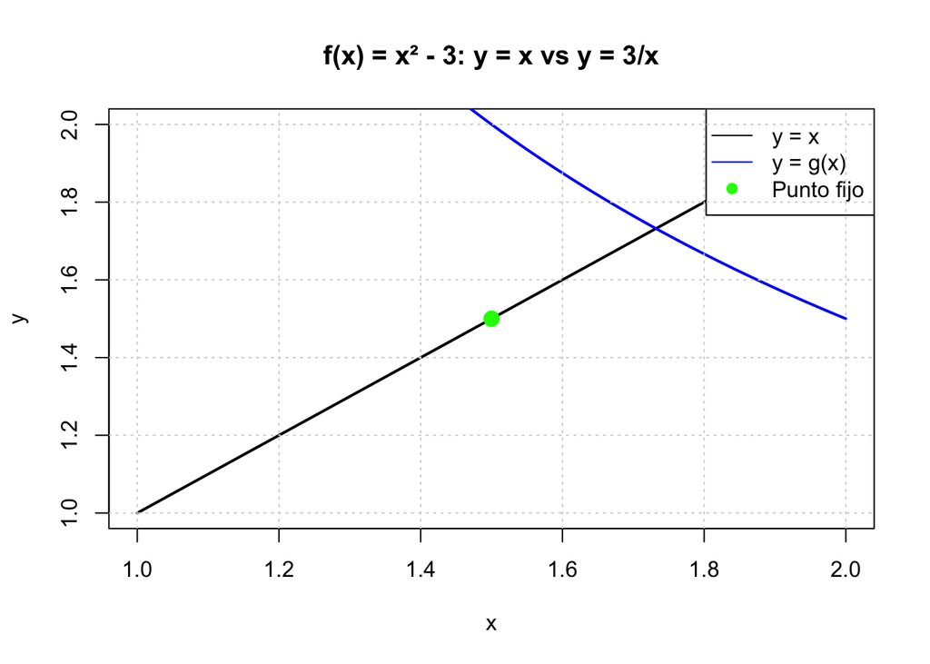

```r
x_plot <- seq(1, 2, length.out = 500)
y_g <- 3/x_plot
y_x <- x_plot

plot(x_plot, y_x, type = "l", main = "f(x) = x² - 3: y = x vs y = 3/x",
     xlab = "x", ylab = "y", lwd = 2, col = "black", ylim = c(1, 2))
lines(x_plot, y_g, col = "blue", lwd = 2)
points(resultado6$raiz, resultado6$raiz, col = "green", pch = 19, cex = 1.5)
legend("topright", c("y = x", "y = g(x)", "Punto fijo"),
       col = c("black", "blue", "green"), lty = c(1, 1, NA), pch = c(NA, NA, 19))
grid()
```

### Ecuación 7: f(x) = ln(x+1) + x - 2, g(x) = 2 - ln(x+1), x₀ = 0.5

```r
g7 <- function(x) 2 - log(x + 1)
dg7 <- function(x) -1/(x + 1)

convg7 <- verificar_convergencia_simple(dg7, 0, 1)
cat("Convergencia: |g'(x)| < 1\n")
```

```
## Convergencia: |g'(x)| < 1
```

```r
cat("Máx |g'(x)| =", round(convg7$max_deriv, 6), "\n")
```

```
## Máx |g'(x)| = 1
```

```r
cat("¿Converge?:", convg7$converge, "\n\n")
```

```
## ¿Converge?: FALSE
```

```r
resultado7 <- punto_fijo(g7, dg7, 0.5, tol = 1e-6, iter_max = 100)

cat("Raíz aproximada:", resultado7$raiz, "\n")
```

```
## Raíz aproximada: 1.20794
```

```r
cat("Iteraciones:", resultado7$iteraciones, "\n\n")
```

```
## Iteraciones: 19
```

```r
print(resultado7$tabla, digits = 8)
```

```
##     k        xk      g_xk       dg_xk         error
## 1   1 0.5000000 1.5945349 -0.66666667 1.0945349e+00
## 2   2 1.5945349 1.0465927 -0.38542554 5.4794216e-01
## 3   3 1.0465927 1.2838237 -0.48861700 2.3723094e-01
## 4   4 1.2838237 1.1741489 -0.43786217 1.0967476e-01
## 5   5 1.1741489 1.2233627 -0.45995010 4.9213804e-02
## 6   6 1.2233627 1.2009792 -0.44976917 2.2383504e-02
## 7   7 1.2009792 1.2110976 -0.45434323 1.0118429e-02
## 8   8 1.2110976 1.2065109 -0.45226406 4.5867046e-03
## 9   9 1.2065109 1.2085875 -0.45320419 2.0765562e-03
## 10 10 1.2085875 1.2076468 -0.45277808 9.4066141e-04
## 11 11 1.2076468 1.2080728 -0.45297100 4.2600159e-04
## 12 12 1.2080728 1.2078799 -0.45288361 1.9294775e-04
## 13 13 1.2078799 1.2079673 -0.45292319 8.7386693e-05
## 14 14 1.2079673 1.2079277 -0.45290526 3.9578676e-05
## 15 15 1.2079277 1.2079456 -0.45291338 1.7925552e-05
## 16 16 1.2079456 1.2079375 -0.45290971 8.1186892e-06
## 17 17 1.2079375 1.2079412 -0.45291137 3.6770399e-06
## 18 18 1.2079412 1.2079395 -0.45291062 1.6653718e-06
## 19 19 1.2079395 1.2079403 -0.45291096 7.5426485e-07
```

#### Gráfico

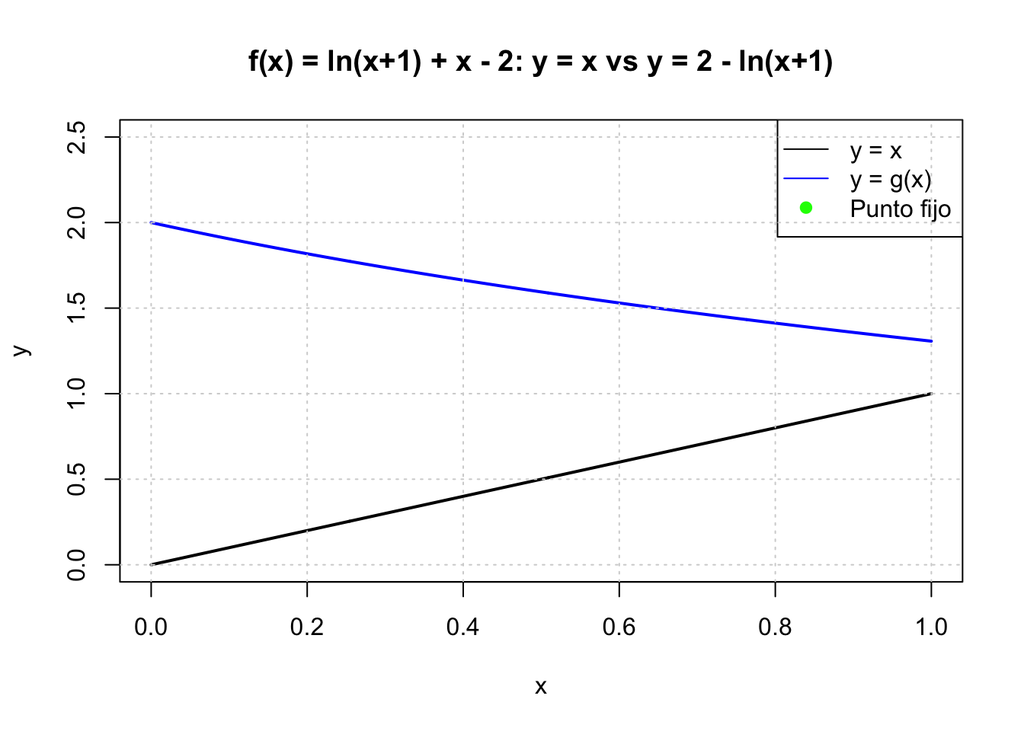

```r
x_plot <- seq(0, 1, length.out = 500)
y_g <- 2 - log(x_plot + 1)
y_x <- x_plot

plot(x_plot, y_x, type = "l", main = "f(x) = ln(x+1) + x - 2: y = x vs y = 2 - ln(x+1)",
     xlab = "x", ylab = "y", lwd = 2, col = "black", ylim = c(0, 2.5))
lines(x_plot, y_g, col = "blue", lwd = 2)
points(resultado7$raiz, resultado7$raiz, col = "green", pch = 19, cex = 1.5)
legend("topright", c("y = x", "y = g(x)", "Punto fijo"),
       col = c("black", "blue", "green"), lty = c(1, 1, NA), pch = c(NA, NA, 19))
grid()
```

### Ecuación 8: f(x) = x³ - 3x + 1, g(x) = ³√(3x - 1), x₀ = 0.8

```r
g8 <- function(x) (3*x - 1)^(1/3)
dg8 <- function(x) (3)^(1/3) * (3*x - 1)^(-2/3)

convg8 <- verificar_convergencia_simple(dg8, 0.5, 1)
cat("Convergencia: |g'(x)| < 1\n")
```

```
## Convergencia: |g'(x)| < 1
```

```r
cat("Máx |g'(x)| =", round(convg8$max_deriv, 6), "\n")
```

```
## Máx |g'(x)| = 2.289428
```

```r
cat("¿Converge?:", convg8$converge, "\n\n")
```

```
## ¿Converge?: FALSE
```

```r
resultado8 <- punto_fijo(g8, dg8, 0.8, tol = 1e-6, iter_max = 100)

cat("Raíz aproximada:", resultado8$raiz, "\n")
```

```
## Raíz aproximada: 1.532088
```

```r
cat("Iteraciones:", resultado8$iteraciones, "\n\n")
```

```
## Iteraciones: 17
```

```r
print(resultado8$tabla, digits = 8)
```

```
##     k        xk      g_xk      dg_xk         error
## 1   1 0.8000000 1.1186889 1.15244903 3.1868894e-01
## 2   2 1.1186889 1.3306460 0.81454550 2.1195706e-01
## 3   3 1.3306460 1.4409565 0.69460626 1.1031047e-01
## 4   4 1.4409565 1.4922368 0.64768658 5.1280366e-02
## 5   5 1.4922368 1.5149193 0.62843649 2.2682499e-02
## 6   6 1.5149193 1.5247391 0.62036795 9.8197361e-03
## 7   7 1.5247391 1.5289513 0.61695448 4.2122053e-03
## 8   8 1.5289513 1.5307510 0.61550459 1.7997456e-03
## 9   9 1.5307510 1.5315187 0.61488769 7.6768705e-04
## 10 10 1.5315187 1.5318459 0.61462502 3.2722525e-04
## 11 11 1.5318459 1.5319854 0.61451314 1.3943670e-04
## 12 12 1.5319854 1.5320448 0.61446549 5.9408832e-05
## 13 13 1.5320448 1.5320701 0.61444518 2.5310511e-05
## 14 14 1.5320701 1.5320809 0.61443653 1.0783024e-05
## 15 15 1.5320809 1.5320855 0.61443285 4.5938403e-06
## 16 16 1.5320855 1.5320874 0.61443128 1.9570835e-06
## 17 17 1.5320874 1.5320883 0.61443061 8.3376184e-07
```

#### Gráfico

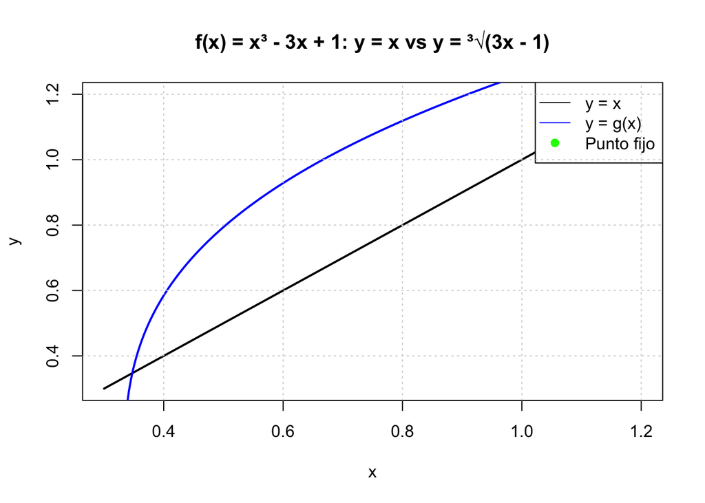

```r
x_plot <- seq(0.3, 1.2, length.out = 500)
y_g <- (3*x_plot - 1)^(1/3)
y_x <- x_plot

plot(x_plot, y_x, type = "l", main = "f(x) = x³ - 3x + 1: y = x vs y = ³√(3x - 1)",
     xlab = "x", ylab = "y", lwd = 2, col = "black", ylim = c(0.3, 1.2))
lines(x_plot, y_g, col = "blue", lwd = 2)
points(resultado8$raiz, resultado8$raiz, col = "green", pch = 19, cex = 1.5)
legend("topright", c("y = x", "y = g(x)", "Punto fijo"),
       col = c("black", "blue", "green"), lty = c(1, 1, NA), pch = c(NA, NA, 19))
grid()
```

### Ecuación 9: f(x) = x - sin(x) - 1, g(x) = sin(x) + 1, x₀ = 1

```r
g9 <- function(x) sin(x) + 1
dg9 <- function(x) cos(x)

convg9 <- verificar_convergencia_simple(dg9, 0.5, 1.5)
cat("Convergencia: |g'(x)| < 1\n")
```

```
## Convergencia: |g'(x)| < 1
```

```r
cat("Máx |g'(x)| =", round(convg9$max_deriv, 6), "\n")
```

```
## Máx |g'(x)| = 0.877583
```

```r
cat("¿Converge?:", convg9$converge, "\n\n")
```

```
## ¿Converge?: TRUE
```

```r
resultado9 <- punto_fijo(g9, dg9, 1, tol = 1e-6, iter_max = 100)

cat("Raíz aproximada:", resultado9$raiz, "\n")
```

```
## Raíz aproximada: 1.934563
```

```r
cat("Iteraciones:", resultado9$iteraciones, "\n\n")
```

```
## Iteraciones: 14
```

```r
print(resultado9$tabla, digits = 8)
```

```
##     k        xk      g_xk       dg_xk         error
## 1   1 1.0000000 1.8414710  0.54030231 8.4147098e-01
## 2   2 1.8414710 1.9635907 -0.26738159 1.2211974e-01
## 3   3 1.9635907 1.9238431 -0.38277149 3.9747672e-02
## 4   4 1.9238431 1.9383236 -0.34575822 1.4480587e-02
## 5   5 1.9383236 1.9332187 -0.35930897 5.1049825e-03
## 6   6 1.9332187 1.9350408 -0.35454025 1.8220979e-03
## 7   7 1.9350408 1.9343932 -0.35624339 6.4755885e-04
## 8   8 1.9343932 1.9346237 -0.35563825 2.3049264e-04
## 9   9 1.9346237 1.9345417 -0.35585366 8.1996823e-05
## 10 10 1.9345417 1.9345709 -0.35577703 2.9175728e-05
## 11 11 1.9345709 1.9345605 -0.35580430 1.0380452e-05
## 12 12 1.9345605 1.9345642 -0.35579459 3.6933589e-06
## 13 13 1.9345642 1.9345629 -0.35579805 1.3140835e-06
## 14 14 1.9345629 1.9345633 -0.35579682 4.6754754e-07
```

#### Gráfico

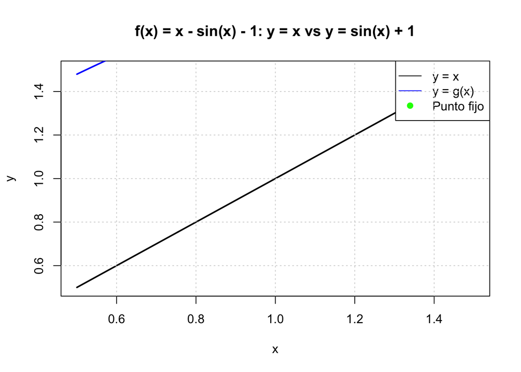

```r
x_plot <- seq(0.5, 1.5, length.out = 500)
y_g <- sin(x_plot) + 1
y_x <- x_plot

plot(x_plot, y_x, type = "l", main = "f(x) = x - sin(x) - 1: y = x vs y = sin(x) + 1",
     xlab = "x", ylab = "y", lwd = 2, col = "black", ylim = c(0.5, 1.5))
lines(x_plot, y_g, col = "blue", lwd = 2)
points(resultado9$raiz, resultado9$raiz, col = "green", pch = 19, cex = 1.5)
legend("topright", c("y = x", "y = g(x)", "Punto fijo"),
       col = c("black", "blue", "green"), lty = c(1, 1, NA), pch = c(NA, NA, 19))
grid()
```

### Ecuación 10: f(x) = x² - 2, g(x) = 2/x, x₀ = 1.5

```r
g10 <- function(x) 2/x
dg10 <- function(x) -2/(x^2)

convg10 <- verificar_convergencia_simple(dg10, 1, 2)
cat("Convergencia: |g'(x)| < 1\n")
```

```
## Convergencia: |g'(x)| < 1
```

```r
cat("Máx |g'(x)| =", round(convg10$max_deriv, 6), "\n")
```

```
## Máx |g'(x)| = 2
```

```r
cat("¿Converge?:", convg10$converge, "\n\n")
```

```
## ¿Converge?: FALSE
```

```r
resultado10 <- punto_fijo(g10, dg10, 1.5, tol = 1e-6, iter_max = 100)

cat("Raíz aproximada:", resultado10$raiz, "\n")
```

```
## Raíz aproximada: 1.5
```

```r
cat("Iteraciones:", resultado10$iteraciones, "\n\n")
```

```
## Iteraciones: 100
```

```r
print(resultado10$tabla, digits = 8)
```

```
##       k        xk      g_xk       dg_xk      error
## 1     1 1.5000000 1.3333333 -0.88888889 0.16666667
## 2     2 1.3333333 1.5000000 -1.12500000 0.16666667
## 3     3 1.5000000 1.3333333 -0.88888889 0.16666667
## 4     4 1.3333333 1.5000000 -1.12500000 0.16666667
## 5     5 1.5000000 1.3333333 -0.88888889 0.16666667
## 6     6 1.3333333 1.5000000 -1.12500000 0.16666667
## 7     7 1.5000000 1.3333333 -0.88888889 0.16666667
## 8     8 1.3333333 1.5000000 -1.12500000 0.16666667
## 9     9 1.5000000 1.3333333 -0.88888889 0.16666667
## 10   10 1.3333333 1.5000000 -1.12500000 0.16666667
## 11   11 1.5000000 1.3333333 -0.88888889 0.16666667
## 12   12 1.3333333 1.5000000 -1.12500000 0.16666667
## 13   13 1.5000000 1.3333333 -0.88888889 0.16666667
## 14   14 1.3333333 1.5000000 -1.12500000 0.16666667
```

[output cut: 86 more lines]

#### Gráfico

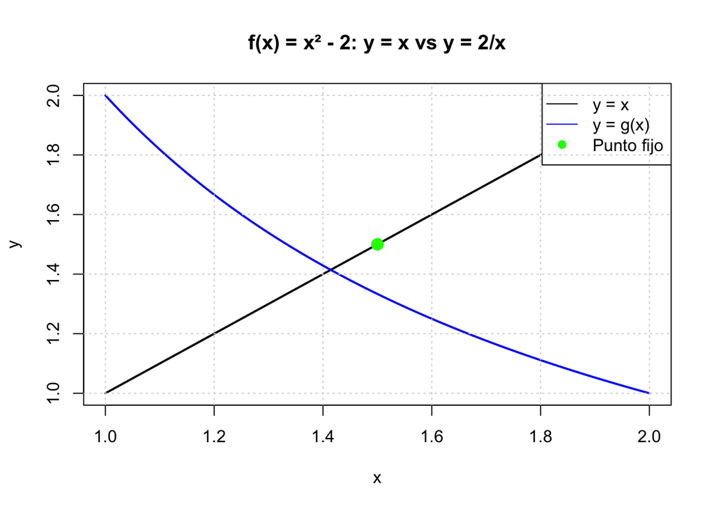

```r
x_plot <- seq(1, 2, length.out = 500)
y_g <- 2/x_plot
y_x <- x_plot

plot(x_plot, y_x, type = "l", main = "f(x) = x² - 2: y = x vs y = 2/x",
     xlab = "x", ylab = "y", lwd = 2, col = "black", ylim = c(1, 2))
lines(x_plot, y_g, col = "blue", lwd = 2)
points(resultado10$raiz, resultado10$raiz, col = "green", pch = 19, cex = 1.5)
legend("topright", c("y = x", "y = g(x)", "Punto fijo"),
       col = c("black", "blue", "green"), lty = c(1, 1, NA), pch = c(NA, NA, 19))
grid()
```

# Interpolación y aproximación

# Practicas de clase

## Agosto

### Practica del dia 13

#### OPERADORES LOGICOS

```r
17<5
```

```
## [1] FALSE
```

```r
17>5
```

```
## [1] TRUE
```

```r
17<=5
```

```
## [1] FALSE
```

```r
17>=5
```

```
## [1] TRUE
```

```r
17!=5
```

```
## [1] TRUE
```

```r
17==5
```

```
## [1] FALSE
```

#### OPERADORES ARITMETICOS

##### SUMA, RESTA, MULTIPLICACION, DIVISION, POTENCIA, MODULO, DIVISION ENTERA

```r
17+5
```

```
## [1] 22
```

```r
17*5
```

```
## [1] 85
```

```r
17*5
```

```
## [1] 85
```

```r
17^5
```

```
## [1] 1419857
```

```r
17%/%5
```

```
## [1] 3
```

```r
17%%5
```

```
## [1] 2
```

#### LOGARITMOS Y EXPONENCIALES

```r
log(1)
```

```
## [1] 0
```

```r
log(12)
```

```
## [1] 2.484907
```

```r
log(12,2)
```

```
## [1] 3.584963
```

```r
exp(12)
```

```
## [1] 162754.8
```

```r
exp(1)
```

```
## [1] 2.718282
```

#### FUNCIONES TRIGONOMETRICAS

```r
sin(45 * pi / 180) # Convertir grados a radianes
```

```
## [1] 0.7071068
```

```r
cos(45 * pi / 180) # Convertir grados a radianes
```

```
## [1] 0.7071068
```

```r
tan(45 * pi / 180) # Convertir grados a radianes
```

```
## [1] 1
```

```r
asin(0.96)
```

```
## [1] 1.287002
```

```r
acos(0.97)
```

```
## [1] 0.2455655
```

```r
atan(0.45)
```

```
## [1] 0.4228539
```

#### FUNCIONES VARIAS

```r
abs(-34)
```

```
## [1] 34
```

```r
sqrt(8)
```

```
## [1] 2.828427
```

```r
floor(1.56)
```

```
## [1] 1
```

```r
ceiling(1.56)
```

```
## [1] 2
```

```r
max(4,7,2,12)
```

```
## [1] 12
```

```r
min(4,7,2,12)
```

```
## [1] 2
```

```r
sign(-45)
```

```
## [1] -1
```

#### EJERCICIOS DE PRACTICA

##### 1. calcular la expresion cos(pi/6+pi/2)+e^2

```r
cos(pi/6 + pi/2) + exp(1)^2
```

```
## [1] 6.889056
```

##### 2. calcular la expresion cos(pi/6+pi/2)+e^2*log(5)+arc cos(1/raiz(2))

```r
cos(pi/6 + pi/2) + exp(1)^2 * log(5) + acos(1/sqrt(2))
```

```
## [1] 12.17763
```

##### 3. introducir las siguientes expresiones:

###### a) 1/7

```r
1/7
```

```
## [1] 0.1428571
```

###### b) options(digits=3); 1/7

```r
options(digits = 3); 1/7
```

```
## [1] 0.143
```

###### c) options(digits=6); 1/7

```r
options(digits = 6); 1/7
```

```
## [1] 0.142857
```

###### d) round(67.45)

```r
round(67.45)
```

```
## [1] 67
```

###### e) round(75.324568,2)

```r
round(75.324568, 2)
```

```
## [1] 75.32
```

###### f) options(digits=7);

```r
options(digits = 7); # No es necesario poner 1, solo se cambia la opción
```

###### g) signif(56.345458234234,2)

```r
signif(56.345458234234, 2)
```

```
## [1] 56
```

###### h) signif(56.345458234234)

```r
signif(56.345458234234)
```

```
## [1] 56.3455
```

###### i) exp(-30)

```r
exp(-30)
```

```
## [1] 9.357623e-14
```

###### j) options(scipen= 999)

```r
options(scipen = 999)
```

###### k) exp(-30)

```r
exp(-30)
```

```
## [1] 0.00000000000009357623
```

###### l) options(scipen=0)

```r
options(scipen = 0)
```

### Practica del dia 20

#### DEFINICION DE CONSTANTES

```r
e = exp(1);
x = 0.0034
e <- exp(1)
x <- 0.034;
x0 = e^(2*x)
```

#### TRABAJO EN CLASE (Ejemplo de Discriminante)

```r
a_eq <- 1; # Usamos a_eq para no  confundir con el lado 'a' del triángulo
b_eq <- 3;
c_eq <- 8;
# El cálculo original de 'raiz' tenía un error (a*a*c en lugar de 4*a*c para un discriminante cuadrático)
# Asumiendo que 'raiz' es solo un valor para experimentar con abs y cat.
raiz <- b_eq^2 - a_eq * a_eq * c_eq; # Esto NO es un discriminante de ecuación cuadrática
disc <- abs(raiz); # El nombre 'disc' aquí podría ser confuso dado el contexto
texto <-"El valor de la expresión b^2 - a^2*c es :"; # Ajuste de texto para claridad
cat(texto, raiz, "\n"); # Agregamos salto de línea
```

```
## El valor de la expresión b^2 - a^2*c es : 1
```

```r
disc_val <- raiz; # Usamos un nombre de variable más claro
abs_disc <- abs(raiz);
```

#### Cat, Paste, Paste0

```r
paste("La expresión evaluada con paste es:", disc_val)
```

```
## [1] "La expresión evaluada con paste es: 1"
```

```r
paste0("La expresión evaluada con paste0 es:", disc_val)
```

```
## [1] "La expresión evaluada con paste0 es:1"
```

```r
x0 <-1;
x1 <-x0-pi*x0+1;
print(x1);
```

```
## [1] -1.141593
```

```r
x1_2<-x1^2;
x1_3<-x1^3;
texto1<-"El valor de";
texto2<-" al cuadrado es:";
paste(texto1, x1, texto2, x1_2);
```

```
## [1] "El valor de -1.14159265358979  al cuadrado es: 1.30323378673019"
```

```r
ls();
```

[output not shown]

[output cut: 100 more lines]

```r
rm(list=ls()); # Limpiamos el ambiente para el siguiente bloque, si es necesario
ls();
```

```
## character(0)
```

```r
x0 <-1;
x1 <-x0-pi*x0+1;
cat("X0 es ", x0, "X1 es ", x1, "\n"); # Agregamos salto de línea
```

```
## X0 es  1 X1 es  -1.141593
```

```r
cat("X0 es ", x0, "\n", "X1 es ", x1, "\n");
```

```
## X0 es  1
##  X1 es  -1.141593
```

#### Funciones Trigonométricas y Parámetros del Triángulo

```r
# Lados del triángulo
lado_a <- 4;
lado_b <- 5;
lado_c <- sqrt(41); # Si es un triángulo rectángulo con a y b como catetos, c sería la hipotenusa

# Ángulos del triángulo (en grados)
# r es el ángulo recto (90 grados)
angulo_r_deg <- 90;
angulo_B_deg <- 51.34;
angulo_A_deg <- 38.66; # Cambié Alafa a angulo_A_deg para consistencia

# Convertir ángulos a radianes para funciones trigonométricas de R
angulo_r_rad <- angulo_r_deg * pi / 180;
angulo_B_rad <- angulo_B_deg * pi / 180;
angulo_A_rad <- angulo_A_deg * pi / 180;

cat("\n--- Análisis del Triángulo ---\n")
```

```
##
## --- Análisis del Triángulo ---
```

```r
# 1. Calcular el tercer ángulo si dos son conocidos
# Suponiendo que angulo_r_deg es el ángulo recto (90 grados)
angulo_C_calculado_deg <- 180 - angulo_A_deg - angulo_B_deg;

cat("Ángulo A (dado):", angulo_A_deg, "grados\n")
```

```
## Ángulo A (dado): 38.66 grados
```

```r
cat("Ángulo B (dado):", angulo_B_deg, "grados\n")
```

```
## Ángulo B (dado): 51.34 grados
```

```r
cat("Ángulo C (calculado, si A y B son los otros):", angulo_C_calculado_deg, "grados\n")
```

```
## Ángulo C (calculado, si A y B son los otros): 90 grados
```

```r
# Verificar si la suma de los ángulos dados es 180 (para cualquier triángulo)
suma_angulos_dados <- angulo_A_deg + angulo_B_deg + angulo_r_deg; # r como el tercer ángulo

cat("Suma de los 3 ángulos (A, B, R):", suma_angulos_dados, "grados\n")
```

```
## Suma de los 3 ángulos (A, B, R): 180 grados
```

```r
if (abs(suma_angulos_dados - 180) < 0.01) { # Pequeña tolerancia para errores de punto flotante
  cat("Los ángulos sumados dan aproximadamente 180 grados. Triángulo válido por ángulos.\n")
} else {
  cat("Los ángulos NO suman 180 grados. ¡Hay un problema con los ángulos o no es un triángulo!\n")
}
```

```
## Los ángulos sumados dan aproximadamente 180 grados. Triángulo válido por ángulos.
```

##### Verificación de Teorema de Pitágoras (si es Rectángulo)

```r
cat("\n--- Verificación de Teorema de Pitágoras (si es Rectángulo) ---\n")
```

```
##
## --- Verificación de Teorema de Pitágoras (si es Rectángulo) ---
```

```r
if (abs(lado_a^2 + lado_b^2 - lado_c^2) < 0.01) {
  cat("El Teorema de Pitágoras se cumple (a^2 + b^2 = c^2). Es un triángulo rectángulo.\n")
  cat("Catetos:", lado_a, "y", lado_b, ", Hipotenusa:", lado_c, "\n")
} else {
  cat("El Teorema de Pitágoras NO se cumple con los lados dados. No es un triángulo rectángulo o los lados no corresponden.\n")
  cat("a^2 + b^2 =", lado_a^2 + lado_b^2, ", c^2 =", lado_c^2, "\n")
}
```

```
## El Teorema de Pitágoras se cumple (a^2 + b^2 = c^2). Es un triángulo rectángulo.
## Catetos: 4 y 5 , Hipotenusa: 6.403124
```

##### Cálculos Trigonométricos para Triángulo Rectángulo

```r
cat("\n--- Cálculos Trigonométricos para Triángulo Rectángulo ---\n")
```

```
##
## --- Cálculos Trigonométricos para Triángulo Rectángulo ---
```

```r
# Usando los ángulos A y B dados y un lado, podemos calcular los otros.
# Si lado_a es el opuesto a angulo_A_deg y lado_b el adyacente, y lado_c la hipotenusa.
# sin(A) = opuesto / hipotenusa  => hipotenusa = opuesto / sin(A)
# cos(A) = adyacente / hipotenusa => hipotenusa = adyacente / cos(A)

hipotenusa_calculada_sinA <- lado_a / sin(angulo_A_rad)
hipotenusa_calculada_cosB <- lado_a / cos(angulo_B_rad) # Asumiendo B es el otro ángulo agudo

cat("Lado a:", lado_a, "\n")
```

```
## Lado a: 4
```

```r
cat("Lado b:", lado_b, "\n")
```

```
## Lado b: 5
```

```r
cat("Lado c (hipotenusa):", lado_c, "\n")
```

```
## Lado c (hipotenusa): 6.403124
```

```r
cat("Hipotenusa calculada con lado a y sin(A):", hipotenusa_calculada_sinA, "\n")
```

```
## Hipotenusa calculada con lado a y sin(A): 6.403097
```

```r
cat("Hipotenusa calculada con lado a y cos(B):", hipotenusa_calculada_cosB, "\n")
```

```
## Hipotenusa calculada con lado a y cos(B): 6.403097
```

## Septiembre

### Practica del dia 3

#### CREACION DE VECTORES

##### Vector con valores específicos

```r
x1 <- c(1.2,1-5.1-9,1-10); (x1)
```

```
## [1]   1.2 -13.1  -9.0
```

##### Secuencia numérica del 1 al 20

```r
x2 <- (1:20); (x2)
```

```
##  [1]  1  2  3  4  5  6  7  8  9 10 11 12 13 14 15 16 17 18 19 20
```

##### Secuencia con incrementos de 0.1

```r
x3<- seq(1,20,by=0.1); (x3)
```

```
##   [1]  1.0  1.1  1.2  1.3  1.4  1.5  1.6  1.7  1.8  1.9  2.0  2.1  2.2  2.3  2.4
##  [16]  2.5  2.6  2.7  2.8  2.9  3.0  3.1  3.2  3.3  3.4  3.5  3.6  3.7  3.8  3.9
##  [31]  4.0  4.1  4.2  4.3  4.4  4.5  4.6  4.7  4.8  4.9  5.0  5.1  5.2  5.3  5.4
##  [46]  5.5  5.6  5.7  5.8  5.9  6.0  6.1  6.2  6.3  6.4  6.5  6.6  6.7  6.8  6.9
##  [61]  7.0  7.1  7.2  7.3  7.4  7.5  7.6  7.7  7.8  7.9  8.0  8.1  8.2  8.3  8.4
##  [76]  8.5  8.6  8.7  8.8  8.9  9.0  9.1  9.2  9.3  9.4  9.5  9.6  9.7  9.8  9.9
##  [91] 10.0 10.1 10.2 10.3 10.4 10.5 10.6 10.7 10.8 10.9 11.0 11.1 11.2 11.3 11.4
## [106] 11.5 11.6 11.7 11.8 11.9 12.0 12.1 12.2 12.3 12.4 12.5 12.6 12.7 12.8 12.9
## [121] 13.0 13.1 13.2 13.3 13.4 13.5 13.6 13.7 13.8 13.9 14.0 14.1 14.2 14.3 14.4
## [136] 14.5 14.6 14.7 14.8 14.9 15.0 15.1 15.2 15.3 15.4 15.5 15.6 15.7 15.8 15.9
## [151] 16.0 16.1 16.2 16.3 16.4 16.5 16.6 16.7 16.8 16.9 17.0 17.1 17.2 17.3 17.4
## [166] 17.5 17.6 17.7 17.8 17.9 18.0 18.1 18.2 18.3 18.4 18.5 18.6 18.7 18.8 18.9
## [181] 19.0 19.1 19.2 19.3 19.4 19.5 19.6 19.7 19.8 19.9 20.0
```

##### Secuencia descendente con decrementos de 0.1

```r
x4 <- seq(20,1,by=-0.1); (x4)
```

```
##   [1] 20.0 19.9 19.8 19.7 19.6 19.5 19.4 19.3 19.2 19.1 19.0 18.9 18.8 18.7 18.6
##  [16] 18.5 18.4 18.3 18.2 18.1 18.0 17.9 17.8 17.7 17.6 17.5 17.4 17.3 17.2 17.1
##  [31] 17.0 16.9 16.8 16.7 16.6 16.5 16.4 16.3 16.2 16.1 16.0 15.9 15.8 15.7 15.6
##  [46] 15.5 15.4 15.3 15.2 15.1 15.0 14.9 14.8 14.7 14.6 14.5 14.4 14.3 14.2 14.1
##  [61] 14.0 13.9 13.8 13.7 13.6 13.5 13.4 13.3 13.2 13.1 13.0 12.9 12.8 12.7 12.6
##  [76] 12.5 12.4 12.3 12.2 12.1 12.0 11.9 11.8 11.7 11.6 11.5 11.4 11.3 11.2 11.1
##  [91] 11.0 10.9 10.8 10.7 10.6 10.5 10.4 10.3 10.2 10.1 10.0  9.9  9.8  9.7  9.6
## [106]  9.5  9.4  9.3  9.2  9.1  9.0  8.9  8.8  8.7  8.6  8.5  8.4  8.3  8.2  8.1
## [121]  8.0  7.9  7.8  7.7  7.6  7.5  7.4  7.3  7.2  7.1  7.0  6.9  6.8  6.7  6.6
## [136]  6.5  6.4  6.3  6.2  6.1  6.0  5.9  5.8  5.7  5.6  5.5  5.4  5.3  5.2  5.1
## [151]  5.0  4.9  4.8  4.7  4.6  4.5  4.4  4.3  4.2  4.1  4.0  3.9  3.8  3.7  3.6
## [166]  3.5  3.4  3.3  3.2  3.1  3.0  2.9  2.8  2.7  2.6  2.5  2.4  2.3  2.2  2.1
## [181]  2.0  1.9  1.8  1.7  1.6  1.5  1.4  1.3  1.2  1.1  1.0
```

##### Vector con elementos repetidos

```r
x5 <- rep(1,times=10); (x5)
```

```
##  [1] 1 1 1 1 1 1 1 1 1 1
```

#### LONGITUD DE VECTORES

```r
n1 <- length(x1); (n1)
```

```
## [1] 3
```

```r
n2 <- length(x2); (n2)
```

```
## [1] 20
```

```r
n3 <- length(x3); (n3)
```

```
## [1] 191
```

```r
n4 <- length(x4); (n4)
```

```
## [1] 191
```

```r
n5 <- length(x5); (n5)
```

```
## [1] 10
```

#### GENERACION DE NUMEROS ALEATORIOS

##### Generación de 100 números aleatorios uniformes entre -3 y 3

```r
x <- runif(100,-3,3); (x)
```

```
##   [1]  2.00177715 -1.38533225  0.16731047  0.48261888  1.53172410 -0.34761303
##   [7] -1.15837671  2.64646832  1.05329041  1.34311460 -0.05893576  2.37630092
##  [13] -1.38308634 -1.57861908 -2.06262622 -1.75957805  2.26833905 -1.15087472
##  [19]  2.58380221  2.69884183 -2.49376007  2.07194324 -2.31710255  2.02348163
##  [25] -0.53525308  2.48000021 -1.29173375  0.62943611  0.15856085  2.77678160
##  [31] -1.02311351 -0.11288566  1.10172345  0.04448966  1.71712997  0.56929713
##  [37]  0.43570153 -0.25376038 -2.89943589  0.17763798 -1.97176349  2.05600672
##  [43] -0.07085778  0.50312919  0.26709495  2.44261308  1.12761540 -1.05816854
##  [49] -0.33149163 -0.90272749 -2.68167412  2.24817047 -1.20922717 -1.17499111
##  [55]  0.69035241  1.80094636  1.32131437 -0.10943824  2.10826667 -1.09439680
##  [61]  0.42137437 -2.83287221 -0.49383036  1.08993543 -1.46885565 -1.69621251
##  [67] -1.28424207  2.56791516 -1.75939070 -1.80547109  2.01000284 -2.47694844
##  [73] -1.12037679 -1.03945875 -1.08604915  0.93055232  1.10907629 -2.91724948
##  [79] -0.65958179 -0.35905791 -1.04419198 -0.74801339 -0.24024676 -0.68919548
##  [85]  0.32077812  1.51759159 -1.74913832  2.19878362 -2.16565413 -1.18307376
##  [91]  1.41236459  2.54679684  0.43375699 -0.23876890 -1.54215605  1.18684883
##  [97]  1.59134626 -0.13136478  0.29301107  1.48478122
```

#### EJEMPLO DE REDONDEO Y TRUNCAMIENTO

##### Generación de 20 números aleatorios entre -1 y 1

```r
x <- runif(20,-1,1); (x)
```

```
##  [1]  0.58159947  0.10613157  0.28684853 -0.42016998 -0.05474222 -0.56748966
##  [7]  0.10497108 -0.41517634  0.55566835 -0.61654060  0.09565890  0.60468193
## [13]  0.99505769  0.60985750 -0.52297742 -0.60136732 -0.85931693  0.09739368
## [19] -0.49149219 -0.26450823
```

```r
xx <- 100*x; (xx)
```

```
##  [1]  58.159947  10.613157  28.684853 -42.016998  -5.474222 -56.748966
##  [7]  10.497108 -41.517634  55.566835 -61.654060   9.565890  60.468193
## [13]  99.505769  60.985750 -52.297742 -60.136732 -85.931693   9.739368
## [19] -49.149219 -26.450823
```

##### Fijamos la semilla para generar números aleatorios

```r
set.seed(123)
x <- runif(20,-1,1); (x)
```

```
##  [1] -0.42484496  0.57661027 -0.18204616  0.76603481  0.88093457 -0.90888700
##  [7]  0.05621098  0.78483809  0.10287003 -0.08677053  0.91366669 -0.09333169
## [13]  0.35514127  0.14526680 -0.79415063  0.79964994 -0.50782453 -0.91588093
## [19] -0.34415856  0.90900730
```

```r
xx <- 100*x; (xx)
```

```
##  [1] -42.484496  57.661027 -18.204616  76.603481  88.093457 -90.888700
##  [7]   5.621098  78.483809  10.287003  -8.677053  91.366669  -9.333169
## [13]  35.514127  14.526680 -79.415063  79.964994 -50.782453 -91.588093
## [19] -34.415856  90.900730
```

```r
x_red2 <- round(xx,2); (x_red2)
```

```
##  [1] -42.48  57.66 -18.20  76.60  88.09 -90.89   5.62  78.48  10.29  -8.68
## [11]  91.37  -9.33  35.51  14.53 -79.42  79.96 -50.78 -91.59 -34.42  90.90
```

```r
x_red3 <- round(xx,3); (x_red3)
```

```
##  [1] -42.484  57.661 -18.205  76.603  88.093 -90.889   5.621  78.484  10.287
## [10]  -8.677  91.367  -9.333  35.514  14.527 -79.415  79.965 -50.782 -91.588
## [19] -34.416  90.901
```

#### GENERACION DE MUESTRAS

##### Generamos una nueva variable con 500 datos

```r
y <- runif(500,-10,10); (y)
```

```
##   [1]  7.79078632  3.85606812  2.81013628  9.88539553  3.11411598  4.17060936
##   [7]  0.88132049  1.88284041 -4.21680525 -7.05772705  9.26048465  8.04598090
##  [13]  3.81410557  5.90934835 -9.50772631 -0.44408058  5.16919075 -5.67184128
##  [19] -3.63637985 -5.36748429 -7.14399955 -1.70907328 -1.72551347 -2.62309098
##  [25] -6.95110505 -7.22387873 -5.33931801 -0.68075099 -4.68054719  7.15655431
##  [31] -9.08337667 -1.15599852  5.97849691 -7.56201480  1.21895968 -5.86937221
##  [37] -7.44936700  5.06615729  7.90090718 -2.51074448  3.30230389 -8.10318678
##  [43] -2.32060724 -4.51232711  6.29280078 -1.02967317  6.20128706  6.24779019
##  [49]  5.88684642 -1.20336625  5.08950317  2.58442263  4.20364803 -9.98750453
##  [55] -0.49366852 -5.59762230 -2.40366925  2.25542007 -2.96404182 -7.77729151
##  [61] -5.12761055  3.36111175 -1.64706441  5.76391668 -7.94270711 -1.30214517
##  [67]  9.69913960  7.86102229  7.72938122 -6.49894699 -7.38608617  3.06203850
##  [73] -3.12967055  3.13516256 -3.59253515 -6.24617761  5.64588603 -8.12810027
##  [79] -0.66441917  0.23010920  1.99977919 -3.34352919 -0.22773933  9.08947655
##  [85] -0.34195206  7.80700444  8.28876374  2.17469965 -1.78620447 -7.05810618
```

[output cut: 69 more lines]

```r
head(y,10)
```

```
##  [1]  7.7907863  3.8560681  2.8101363  9.8853955  3.1141160  4.1706094
##  [7]  0.8813205  1.8828404 -4.2168053 -7.0577271
```

```r
tail(y,10)
```

```
##  [1] -0.7057245 -8.3493764  7.2021369 -2.0867872  4.7179870 -6.5651319
##  [7] -0.9047674  5.4040952 -8.7470000  6.3016299
```

```r
redoy1 <- round(y,3); (redoy1)
```

```
##   [1]  7.791  3.856  2.810  9.885  3.114  4.171  0.881  1.883 -4.217 -7.058
##  [11]  9.260  8.046  3.814  5.909 -9.508 -0.444  5.169 -5.672 -3.636 -5.367
##  [21] -7.144 -1.709 -1.726 -2.623 -6.951 -7.224 -5.339 -0.681 -4.681  7.157
##  [31] -9.083 -1.156  5.978 -7.562  1.219 -5.869 -7.449  5.066  7.901 -2.511
##  [41]  3.302 -8.103 -2.321 -4.512  6.293 -1.030  6.201  6.248  5.887 -1.203
##  [51]  5.090  2.584  4.204 -9.988 -0.494 -5.598 -2.404  2.255 -2.964 -7.777
##  [61] -5.128  3.361 -1.647  5.764 -7.943 -1.302  9.699  7.861  7.729 -6.499
##  [71] -7.386  3.062 -3.130  3.135 -3.593 -6.246  5.646 -8.128 -0.664  0.230
##  [81]  2.000 -3.344 -0.228  9.089 -0.342  7.807  8.289  2.175 -1.786 -7.058
##  [91]  8.706 -3.975 -8.786  8.955  4.412 -7.154  0.986  9.082  1.710 -1.910
## [101]  2.958 -3.604 -3.846 -5.605 -2.610  9.684 -6.916 -8.179 -7.162  3.800
## [111]  2.385  7.828  3.460  4.742  0.423  3.197  6.436  5.726  9.596 -1.211
## [121] -3.766 -1.811 -9.791 -6.323  6.855 -5.377 -5.218 -8.466 -5.086  4.643
## [131]  6.949 -0.049 -2.242 -5.071 -7.778 -2.200  1.439 -5.662 -1.105 -5.640
## [141]  0.046 -2.922  3.000 -2.506 -2.891  0.674  4.807 -5.578 -1.745 -4.686
```

[output cut: 35 more lines]

```r
head(redoy1,15)
```

```
##  [1]  7.791  3.856  2.810  9.885  3.114  4.171  0.881  1.883 -4.217 -7.058
## [11]  9.260  8.046  3.814  5.909 -9.508
```

```r
tail(redoy1,15)
```

```
##  [1] -6.440  0.721  0.079  8.901 -3.174 -0.706 -8.349  7.202 -2.087  4.718
## [11] -6.565 -0.905  5.404 -8.747  6.302
```

```r
muestra_1 <- sample(redoy1,500);
head(muestra_1,10)
```

```
##  [1]  5.977 -9.645  0.721  2.885  3.965  3.564 -3.715  1.439 -3.232 -4.479
```

```r
tail(muestra_1,10)
```

```
##  [1]  7.807  1.699 -2.839 -4.340  4.166 -5.377  1.205  8.046 -5.245  2.027
```

##### Convertimos todos a números positivos

```r
muestra_2 <- abs(muestra_1)
head(muestra_2,15)
```

```
##  [1] 5.977 9.645 0.721 2.885 3.965 3.564 3.715 1.439 3.232 4.479 8.179 1.883
## [13] 4.742 5.172 4.681
```

```r
tail(muestra_2,15)
```

```
##  [1] 8.559 8.301 2.555 2.057 0.154 7.807 1.699 2.839 4.340 4.166 5.377 1.205
## [13] 8.046 5.245 2.027
```

#### EJEMPLO ADICIONAL DE REDONDEO

```r
l <- runif(15,-1,1); (l)
```

```
##  [1] -0.7300072 -0.2250035  0.5769439  0.3858273  0.1885459 -0.7522847
##  [7]  0.1101562 -0.1011772  0.5323331 -0.9478046 -0.6096571  0.7624691
## [13] -0.7803968  0.9371019 -0.2296028
```

```r
digi2 <- (l*100); (digi2)
```

```
##  [1] -73.00072 -22.50035  57.69439  38.58273  18.85459 -75.22847  11.01562
##  [8] -10.11772  53.23331 -94.78046 -60.96571  76.24691 -78.03968  93.71019
## [15] -22.96028
```

```r
redol <- round(digi2,0); (redol)
```

```
##  [1] -73 -23  58  39  19 -75  11 -10  53 -95 -61  76 -78  94 -23
```

### Practica del dia 10

#### EJEMPLO DE FUNCION

##### Función para calcular el discriminante

```r
Discriminante <- function(a,b,c){
  soluciones <- b^2-4*a*c
  if(soluciones < 0){
    resp <- "No hay solución real"
  } else {
    resp <- "Sí hay solución real"
  }
  cat(resp, "- Discriminante:", soluciones, "\n")
  return(soluciones)
}
```

##### Prueba de la función discriminante

```r
Intento1 <- Discriminante(5,2,3);
```

```
## No hay solución real - Discriminante: -56
```

#### MATRICES

##### Creación de una matriz 3x3

```r
valores <- c(15,3,-2,13,27,10,8,-4,11);
A <- matrix(valores, nrow = 3); (A)
```

```
##      [,1] [,2] [,3]
## [1,]   15   13    8
## [2,]    3   27   -4
## [3,]   -2   10   11
```

```r
tA <- matrix(t(valores), nrow = 3)
(tA)
```

```
##      [,1] [,2] [,3]
## [1,]   15   13    8
## [2,]    3   27   -4
## [3,]   -2   10   11
```

##### Creación del vector b

```r
b <- c(-3,2,-1)
b <- matrix(b, nrow = 3); (b)
```

```
##      [,1]
## [1,]   -3
## [2,]    2
## [3,]   -1
```

##### Combinación de columnas: matriz aumentada Ab

```r
Ab <- cbind(A,b);
(Ab)
```

```
##      [,1] [,2] [,3] [,4]
## [1,]   15   13    8   -3
## [2,]    3   27   -4    2
## [3,]   -2   10   11   -1
```

##### Combinación de columnas: bA

```r
bA <- cbind(b,A);
(bA)
```

```
##      [,1] [,2] [,3] [,4]
## [1,]   -3   15   13    8
## [2,]    2    3   27   -4
## [3,]   -1   -2   10   11
```

##### Combinación de filas: Abt

```r
Abt <- rbind(A, t(b));
(Abt)
```

```
##      [,1] [,2] [,3]
## [1,]   15   13    8
## [2,]    3   27   -4
## [3,]   -2   10   11
## [4,]   -3    2   -1
```

##### Combinación de filas: btA

```r
btA <- rbind(t(b),A);
(btA)
```

```
##      [,1] [,2] [,3]
## [1,]   -3    2   -1
## [2,]   15   13    8
## [3,]    3   27   -4
## [4,]   -2   10   11
```

#### ACCESO A ELEMENTOS DE LA MATRIZ

##### Extracción de filas y columnas

```r
r1 <- Ab [1,];
r2 <- Ab [2,];
r3 <- Ab [3,];
c1 <- Ab [,1];
c2 <- Ab [,2];
c3 <- Ab [,3];
```

##### Extracción de elementos individuales

```r
a11 <- Ab [1,1];
a22 <- Ab [2,2];
a32 <- Ab [3,2];
a23 <- Ab [2,3];
a14 <- Ab [1,4];
a24 <- Ab [2,4];
```

#### ELIMINACION GAUSSIANA SIMPLE

##### Primera fase: eliminación hacia adelante (paso 1)

```r
m1 <- -Ab[2,1]/Ab[1,1]; (m1)
```

```
## [1] -0.2
```

```r
m2 <- -Ab[3,1]/Ab[1,1]; (m2)
```

```
## [1] 0.1333333
```

```r
A1 <- Ab[1,]; (A1)
```

```
## [1] 15 13  8 -3
```

```r
A2 <- m1*Ab[1,]+Ab[2,];(A2)
```

```
## [1]  0.0 24.4 -5.6  2.6
```

```r
A3 <- m2*Ab[1,]+Ab[3,]; (A3)
```

```
## [1]  0.00000 11.73333 12.06667 -1.40000
```

```r
NuevaA <- rbind(A1,A2,A3); (NuevaA)
```

```
##    [,1]     [,2]     [,3] [,4]
## A1   15 13.00000  8.00000 -3.0
## A2    0 24.40000 -5.60000  2.6
## A3    0 11.73333 12.06667 -1.4
```

##### Primera fase: eliminación hacia adelante (paso 2)

```r
Ab <- NuevaA
m3 <- -Ab[3,2]/Ab[2,2]
A3 <- m3*Ab[2,]+Ab[3,];(A3)
```

```
## [1]  0.000000  0.000000 14.759563 -2.650273
```

```r
A1 <- Ab[1,]
A2 <- Ab[2,]
NuevaA <- rbind(A1,A2,A3); (NuevaA)
```

```
##    [,1] [,2]     [,3]      [,4]
## A1   15 13.0  8.00000 -3.000000
## A2    0 24.4 -5.60000  2.600000
## A3    0  0.0 14.75956 -2.650273
```

##### Segunda fase: sustitución hacia atrás (paso 1)

```r
Ab <- NuevaA
m4 <- -Ab[2,3]/Ab[3,3]
m5 <- -Ab[1,3]/Ab[3,3]
A2 <- m4*Ab[3,]+Ab[2,]; (A2)
```

```
## [1]  0.000000 24.400000  0.000000  1.594447
```

```r
A1 <- m5*Ab[3,]+Ab[1,]; (A1)
```

```
## [1] 15.000000 13.000000  0.000000 -1.563495
```

```r
A3 <- Ab[3,]
NuevaA <- rbind(A1,A2,A3); (NuevaA)
```

```
##    [,1] [,2]     [,3]      [,4]
## A1   15 13.0  0.00000 -1.563495
## A2    0 24.4  0.00000  1.594447
## A3    0  0.0 14.75956 -2.650273
```

##### Segunda fase: sustitución hacia atrás (paso 2)

```r
Ab <- NuevaA
m6 <- -Ab[1,2]/Ab[2,2]
A1 <- m6*Ab[2,]+Ab[1,]; (A1)
```

```
## [1] 15.000000  0.000000  0.000000 -2.412995
```

```r
A2 <- Ab[2,]
A3 <- Ab[3,]
```

##### Mostrar la matriz final para ver los valores exactos

```r
NuevaA <- rbind(A1,A2,A3); (NuevaA)
```

```
##    [,1] [,2]     [,3]      [,4]
## A1   15  0.0  0.00000 -2.412995
## A2    0 24.4  0.00000  1.594447
## A3    0  0.0 14.75956 -2.650273
```

##### Obtener los valores de las variables desde la matriz final

```r
x1 <- NuevaA[1,4] / NuevaA[1,1]
x2 <- NuevaA[2,4] / NuevaA[2,2]
x3 <- NuevaA[3,4] / NuevaA[3,3]
```

##### Mostrar los resultados

```r
cat("x1 =", x1, "\n")
```

```
## x1 = -0.1608663
```

```r
cat("x2 =", x2, "\n")
```

```
## x2 = 0.06534617
```

```r
cat("x3 =", x3, "\n")
```

```
## x3 = -0.1795631
```